# MEKONG TECHNOLOGY

## 4.10. Hệ thống Điện Trung thế và Hạ thế

### 4.10.1. Sơ đồ Cấp điện Tổng thể

[figure not shown]

Diagram 34

### 4.10.2. Phụ tải Điện theo Khối

[output not shown]

### 4.10.3. Chất lượng Điện năng

| Thông số | Tiêu chuẩn | Biện pháp | CAPEX (K USD) |
| --- | --- | --- | --- |
| **Sóng hài (THD)** | < 5% (IEEE 519) | Active Harmonic Filter cho DB-CNC (VFD gây hài) | 30-50 |
| **Hệ số công suất** | > 0,95 | Tụ bù APFC tại mỗi MDB | 15-25 |
| **Điện áp ổn định** | ±5% | AVR tại máy biến áp | Included |
| **Chống sét** | IEC 62305 | SPD Class I+II tại MDB, Class II+III tại DB | 10-15 |
| **Nối đất** | < 1 Ω (DC), < 5 Ω (general) | Hệ thống nối đất đẳng thế (TN-S) | 20-30 |
| **UPS DC (2N)** | Tier III requirement | Schneider Galaxy VX 2N | 350-850 |
| **Generator** | N+1 | Cummins/Cat 4 × 750 kVA + SCR/DPF | 400-600 |

## 4.11. Hệ thống HVAC và Kiểm soát Môi trường

### 4.11.1. Yêu cầu Nhiệt độ/Độ ẩm theo Khu vực

| Khu vực | Nhiệt độ (°C) | Humidity (%RH) | Tiêu chuẩn | Làm sạch không khí | Áp suất |
| --- | --- | --- | --- | --- | --- |
| **DC Data Hall** | 22-27 (ASHRAE A1) | 20-80% | ASHRAE TC 9.9 | MERV 8 | Dương (+5 Pa) |
| **CNC Workshop** | 22-28 (general) | 30-70% | ISO 8573 | MERV 8 + Mist Collector | Âm (-5 Pa) |
| **CNC CMM Room** | 20 ± 0,5 | 45-55% | ISO 1:2016 | HEPA H13 | Dương (+10 Pa) |
| **SMT Clean Room** | 22 ± 2 | 40-60% | ISO 14644 Class 7 | HEPA H14 | Dương (+15 Pa) |
| **SMT Assembly** | 22-26 | 30-60% | IPC-A-610 | MERV 11 | Dương (+5 Pa) |
| **R&D Lab** | 22 ± 2 | 40-60% | ISO 17025 ref. | HEPA H13 | Dương (+10 Pa) |
| **Văn phòng** | 24 ± 2 | 50-70% | ASHRAE 55 | MERV 8 | Neutral |
| **Kho phôi/vật tư** | 18-35 (không cần kiểm soát chặt) | < 80% | — | — | Neutral |
| **Canteen** | 24-28 | — | — | — | Âm |

### 4.11.2. Thiết bị HVAC theo Khu vực

| Khu vực | Thiết bị | Công suất | Số lượng | CAPEX (K USD) |
| --- | --- | --- | --- | --- |
| **DC Data Hall 1** | CRAC Row-based (Schneider InRow) | 60 kW each | 6+2 (N+2) | 210 |
| **DC Data Hall 2 + GPU** | CDU + Rear Door HX | 100 kW CDU | 3+1 | 200 |
| **DC Chiller** | Air-cooled Chiller (Daikin/Trane) | 250 kW each | 3+1 | 360 |
| **CNC Workshop** | AHU + Exhaust + Mist Collector | 80 kW cooling | 4 | 120 |
| **CNC CMM Room** | Precision AHU (Stulz/Emerson) | 10 kW, ±0,5°C | 2 (1+1) | 60 |
| **SMT Clean Room** | FFU + AHU + MAU | 40 kW | 2+1 | 80 |
| **Văn phòng + Canteen** | VRV/VRF System (Daikin) | 100 kW total | 4 outdoor | 80 |
| **R&D Lab** | Precision AHU | 15 kW each | 3 | 45 |
| **Kho** | Quạt thông gió tự nhiên + Exhaust | — | 6 | 5 |
| **Tổng HVAC** |  |  |  | **~1.160** |

### 4.11.3. Hệ thống Hút Khói/Bụi CNC (Central Extraction)

| Thông số | Giá trị | Ghi chú |
| --- | --- | --- |
| **Loại** | Oil mist collector + HEPA | Cho 6 máy CNC |
| **Công suất** | 15.000 m³/h (tổng) | 500-800 m³/h per machine |
| **Hiệu suất** | > 99,97% @ 0,3µm (HEPA H13) | DOP test hàng năm |
| **Pre-filter** | Coalescent fiber (oil mist stage 1) | Thay 3 tháng/lần |
| **HEPA** | H13 (oil mist stage 2) | Thay 12 tháng/lần |
| **Activated Carbon** | Stage 3 (cho VOCs từ coolant) | Thay 6 tháng/lần |
| **Motor** | 2 × 15 kW (N+1) | IE4 Premium Efficiency |
| **Ductwork** | Galvanized steel, ø200-400mm | Balanced design, ≤ 15 m/s |
| **Điểm hút** | 6 points (1 per CNC) + 2 manual stations | Flexible arm |
| **CAPEX** | 120 K USD (incl. ductwork + installation) |  |
| **OPEX** | 15 K USD/năm (filters + electricity) |  |
| **EIA compliance** | QCVN 19:2009 Cột A cho khí thải | Xem Phụ lục R.9 |

## 4.12. Hệ thống An ninh và Kiểm soát Truy cập

### 4.12.1. Mô hình An ninh 5 Lớp

[figure not shown]

Diagram 35

### 4.12.2. Thiết bị An ninh

| Hạng mục | Số lượng | Hãng | CAPEX (K USD) |
| --- | --- | --- | --- |
| CCTV Camera (4K, IR, PoE) | 80 | Hikvision DS-2CD2687 | 40 |
| NVR (Network Video Recorder) | 4 | Hikvision DS-96128NI | 8 |
| Storage (CCTV 90 ngày) | 200 TB | Seagate SkyHawk | 15 |
| Access Control Panel | 8 | HID iCLASS SE | 12 |
| Card Reader (Badge) | 40 | HID iCLASS SE | 10 |
| Biometric Reader (Fingerprint + Iris) | 10 | Suprema BioStation 3 | 15 |
| Mantrap (DC entrance) | 2 | Boon Edam | 25 |
| Barrier Gate (Parking) | 2 | FAAC / Nice | 5 |
| LPR Camera | 2 | Hikvision / Genetec | 3 |
| Visitor Management Kiosk | 2 | Custom tablet + Software | 3 |
| E-lock (Cabinet lock per rack) | 100 | Chatsworth CPI | 20 |
| Perimeter sensor (IR beam) | 20 | Optex | 5 |
| PA System (Announcement) | 1 lot | TOA / Bosch | 5 |
| VMS Software (Video Management) | 1 | Genetec / Milestone | 8 |
| PSIM Integration | 1 | CNL / Genetec | 5 |
| **Tổng An ninh** |  |  | **~179** |

## 4.13. Hệ thống Công nghệ Thông tin (IT Infrastructure)

### 4.13.1. Hạ tầng Mạng Nội bộ

| Hạng mục | Thông số | CAPEX (K USD) |
| --- | --- | --- |
| **Core Switch** | 2 × Cisco Nexus 9336C (100GbE, VSS) | 60 |
| **Distribution Switch** | 4 × Cisco Catalyst 9300 (48-port PoE+) | 24 |
| **Access Switch** | 20 × Cisco Catalyst 9200 (24/48-port) | 30 |
| **WiFi 6 AP** | 40 × Cisco Meraki MR46 | 16 |
| **Firewall** | 2 × Palo Alto PA-5200 Series (HA Active/Passive) | 40 |
| **Structured Cabling** | Cat6A toàn bộ (factory + office), OM4 uplink | 35 |
| **Fiber Backbone** | OS2 single-mode (inter-building), OM4 (intra) | 15 |
| **Server Room (Internal IT)** | 4 × Rack, UPS 20 kVA, PAC | 20 |
| **WAN / MPLS** | 2 × Internet (FPT + VNPT, 1 Gbps mỗi) | 10/năm |
| **VPN** | Cisco AnyConnect + SD-WAN (future) | 5 |
| **Tổng IT Infrastructure** |  | **~255** |

### 4.13.2. Hệ thống Phần mềm (Software Stack)

[output not shown]

### 4.13.3. Hệ thống MES — Manufacturing Execution System

**Kiến trúc MES tích hợp:**

[figure not shown]

Diagram 36

| Chức năng MES | Chi tiết | Trụ cột |
| --- | --- | --- |
| **CNC Data Collection** | OEE, cycle time, spindle load, tool life — via MTConnect/OPC-UA | CNC |
| **Job Tracking** | RFQ → PO → Job → Operation → Ship → Invoice | CNC |
| **SPC (Statistical Process Control)** | Xbar-R chart tại CMM, real-time Cp/Cpk | CNC |
| **Traceability** | Mỗi chi tiết CNC có mã QR → link tới: máy, tool, operator, CMM report | CNC |
| **SMT Traceability** | PCB serial → link tới: SMT program, solder paste lot, AOI result | IoT |
| **eSOP / eWI** | Bản vẽ + Video hướng dẫn trên màn hình tại mỗi workstation | All |
| **Dashboard** | Real-time OEE, WIP, Quality yield — TV treo tại workshop | All |
| **Maintenance (CMMS)** | Preventive Maintenance schedule, spare parts tracking | All |
| **Integration** | ERP (SAP/Odoo) ← → MES ← → Machine (OPC-UA) ← → DCIM | All |

## 4.14. Hệ thống Năng lượng Tái tạo và Bền vững

### 4.14.1. Solar PV Rooftop

[output not shown]

### 4.14.2. Chiến lược ESG và Carbon Footprint

| Chỉ số | Baseline (no action) | Target (with measures) | Biện pháp |
| --- | --- | --- | --- |
| **Scope 1 (GHG trực tiếp)** | 1.500 tCO₂e/năm | 900 tCO₂e/năm (-40%) | Giảm generator runtime, B5 biodiesel |
| **Scope 2 (Điện)** | 8.000 tCO₂e/năm | 6.000 tCO₂e/năm (-25%) | Solar 500kWp, PUE optimization, LED |
| **Scope 3 (Chuỗi cung ứng)** | Chưa đo | Phase 2 target | Supplier engagement, logistics optimize |
| **Tổng GHG** | ~9.500 tCO₂e/năm | ~6.900 tCO₂e/năm | **Giảm ~27%** |
| **Nước tái sử dụng** | 0% | ≥ 30% | RO condensate, CT blowdown reuse |
| **Chất thải tái chế** | 50% | ≥ 80% | Phoi CNC, bìa carton, pallet |
| **PUE DC** | 1,45 (VN average) | 1,28-1,32 | DLC, free cooling, hot aisle containment |

> **[C] Giảm GHG 27% = ~2.600 tCO₂e/năm = ~26.000 tCO₂e/10 năm.** Nếu carbon credit price 10 USD/tCO₂ → potential value 260 K USD/10Y. Tuy nhiên, giá trị ESG chính là: (a) Đáp ứng yêu cầu FDI (Samsung/Bosch đều yêu cầu Scope 3 reduction từ supplier), (b) Ưu đãi green loan (giảm lãi 0,5-1,0%), (c) Hình ảnh doanh nghiệp khi trình bày BQL KCNC.

# PHẦN V: TÀI CHÍNH VÀ ĐẦU TƯ

## 5.1. Tổng quan Cấu trúc Vốn

### 5.1.1. CAPEX Tổng hợp — 5 Phase / 8 năm

| Hạng mục | P0 Y0-Y1 | P1 Y1-Y3 | P2 Y3-Y4 | P3 Y4-Y6 | P4 Y6-Y8 | **Tổng (K)** | % |
| --- | --- | --- | --- | --- | --- | --- | --- |
| Thuê đất + Site prep | 800 | — | — | — | — | **800** | 2,5% |
| Thiết kế + Pháp lý + EIA | 600 | — | — | — | — | **600** | 1,9% |
| Shell 3 tầng (xây dựng thô) | — | 2.800 | — | — | — | **2.800** | 8,8% |
| M&E + Điện 3MVA | — | 2.100 | — | — | — | **2.100** | 6,6% |
| PCCC + Solar 200kWp + VP | — | 700 | 100 | — | — | **800** | 2,5% |
| Fit-out IoT/SMT (Tầng 2) + Thiết bị | — | — | 3.500 | — | — | **3.500** | 10,9% |
| Fit-out DC Phase 1 (Tầng 1 — 3.000 m²) | — | — | 1.800 | 2.050 | — | **3.850** | 12,0% |
| GPU NVIDIA DGX H100 (2 pods) | — | — | — | 5.600 | — | **5.600** | 17,5% |
| Thiết bị DC (Server, Network, BMS) | — | — | — | 3.100 | 1.450 | **4.550** | 14,2% |
| Fit-out CNC (800 m²) + Tooling | — | — | — | 590 | — | **590** | 1,8% |
| Thiết bị CNC (6 máy: 4×5ax + 2×3ax) | — | — | — | 2.040 | — | **2.040** | 6,4% |
| CMM Hexagon + CAD/CAM Mastercam | — | — | — | 320 | — | **320** | 1,0% |
| Chứng nhận (ISO 9001/Tier III/ISO 27001) | 50 | — | 50 | 230 | 50 | **380** | 1,2% |
| Dự phòng phát sinh | 150 | 200 | 250 | 570 | 250 | **1.420** | 4,4% |
| **Tổng CAPEX** | **1.600** | **5.800** | **5.700** | **14.500** | **1.750** | **~29.350** | **91,7%** |
| Vốn lưu động + Dự phòng lỗ | 400 | — | — | — | 2.250 | **2.650** | 8,3% |
| **Tổng nhu cầu vốn** | **2.000** | **5.800** | **5.700** | **14.500** | **4.000** | **~32.000** | **100%** |

### 5.1.2. Cấu trúc Nguồn vốn

[figure not shown]

Diagram 37

| Nguồn | Số tiền (M USD) | Tỷ trọng | Điều kiện | Thời điểm |
| --- | --- | --- | --- | --- |
| **Vốn chủ sở hữu (CSH)** | 24,00 | 75,0% | Nhà đầu tư Mekong Technology — tự chủ 100% trong 5 năm đầu | Y0-Y5 |
| **Vay ngân hàng** | 8,00 | 25,0% | Lãi suất 8,5%/năm, kỳ hạn 8 năm, ân hạn 1 năm. Chỉ vay khi đã có doanh thu chứng minh (Revenue Y5 ≥ 4,0M) | Từ Y6 |
| **Tổng** | **32,00** | **100%** |  |  |

> **Chiến lược tài chính:** Nhà đầu tư **đủ tiền cho 5 năm đầu** (24,00M CSH) mà không cần vay ngân hàng. Khoản vay 8,00M chỉ giải ngân từ Y6 khi dự án đã có doanh thu từ Datacenter và IoT (~4,0M/năm). Sổ đỏ hoàn thành Y3, giảm thiểu rủi ro tài chính [C].

### 5.1.3. Chi tiết Vốn CSH — Equity Bridge (5 Phase)

| Phase | Hạng mục | Số tiền (M USD) | Thời điểm | Ghi chú |
| --- | --- | --- | --- | --- |
| **Phase 0** | Thiết kế, pháp lý, EIA, site prep | 2,00 | Y0-Y1 | 100% CSH |
| **Phase 1** | Xây dựng shell 3 tầng + M&E + PCCC | 5,80 | Y1-Y3 | 100% CSH → Sổ đỏ Y3 |
| **Phase 2** | Fit-out IoT/SMT + Hạ tầng DC | 5,70 | Y3-Y4 | 100% CSH |
| **Phase 3** | GPU + Server DC + CNC 6 máy (phần CSH) | 10,50 | Y4-Y6 | CSH + Revenue reinvest |
| **Tổng CSH cam kết** |  | **24,00** | Y0-Y5 |  |
| **Phase 4** | Mở rộng rack DC + bổ sung CNC (vay NH) | 8,00 | Y6-Y8 | Vay + Revenue |

*[C — Equity bridge: nhà đầu tư cam kết 24,00M trong 5 năm, trung bình ~4,8M/năm. Không có áp lực vay trong giai đoạn xây dựng. Khoản vay Y6 được bảo đảm bởi TSCĐ (tòa nhà + Sổ đỏ) + doanh thu đã chứng minh.]*

## 5.2. Doanh thu Dự kiến 15 năm (Horizon đầu tư) + 50 năm (Hợp đồng thuê)

### 5.2.1. Bảng Doanh thu Chi tiết — 15 năm đầu tư

> **Lưu ý:** Y0-Y3 = giai đoạn xây dựng shell + hạ tầng, KHÔNG có doanh thu. Doanh thu bắt đầu từ **Y4** (IoT ramp-up). DC vận hành từ Y5. CNC vận hành từ Y6.

[output not shown]

> **Đối chiếu:** Doanh thu 15 năm (Base Case) = **~180M USD** [C]. Y0-Y3 không có doanh thu đáng kể — đây là giai đoạn xây dựng nền tảng. Breakeven (discounted, WACC 12%) đạt tại Y10.

### 5.2.2. Doanh thu Y10 và các Mốc quan trọng

| Mốc | Giá trị | Nhãn | Ghi chú |
| --- | --- | --- | --- |
| **First Revenue** | Y4 Q3 (IoT pilot) → Y5 full-year: 4,0M | [C] | IoT + DC vận hành đầu tiên |
| **Revenue Y10** | 19,50 M USD | [C] | 3 BU combined: IoT 9,0 + CNC 2,5 + DC 8,0 |
| **Revenue Y12** | 21,00 M USD | [C] | Steady-state 3 BU |
| **Revenue 15Y tích lũy** | ~180,00 M USD | [C] | Sum Y4-Y15 |
| **Revenue 50Y (hợp đồng thuê)** | ~500-600 M USD | [A] | Giả định tăng trưởng 2-3%/năm sau Y15 |
| **EBITDA steady-state** | ~35% | [C] | Từ Y12 trở đi |

## 5.3. Chi phí Hoạt động (OPEX)

### 5.3.1. Bảng OPEX Chi tiết — Năm 10 (đại diện, 3 BU hoạt động)

[output not shown]

> **Ghi chú thuê đất:** Thuê đất KCNC 1,0 USD/m²/tháng × 10.000 m² = 120.000 USD/năm. Miễn 11 năm đầu (Y0-Y10) theo chính sách ưu đãi CNC → tiết kiệm ~1,32M USD. Giảm 50% trong 4 năm tiếp (Y11-Y14) → 60K/năm. Từ Y15 trả đủ 120K/năm [B].

### 5.3.2. OPEX theo Năm

| Năm | OPEX (M USD) | Gross Margin | EBITDA Margin | Ghi chú |
| --- | --- | --- | --- | --- |
| 0-3 | 0,30-0,50 | — | — | Chi phí quản lý, pháp lý, giám sát xây dựng |
| 4 | 0,85 | — | -70% (lỗ ramp-up) | IoT ramp-up |
| 5 | 3,15 | 35% | 22% | IoT + DC |
| 6 | 5,90 | 38% | 29% | IoT + DC + CNC start |
| 7 | 8,20 | 40% | 32% | 3 BU full ramp |
| 8 | 10,45 | 42% | 33% | Scale-up |
| 10 | 12,50 | 44% | 35% | Steady |
| 12-15 | 13,50-13,65 | 46% | 35% | Steady-state |
| 16-50 | +2-3%/năm | 46-48% | 35-38% | Mature operations |

## 5.4. Báo cáo Lãi lỗ Dự kiến (Pro-forma P&L)

### 5.4.1. P&L 15 năm — Base Case

> **Lưu ý:** Y0-Y3 là giai đoạn xây dựng — chỉ có chi phí quản lý (~0,3-0,5M/năm), không có doanh thu. P&L chi tiết bắt đầu từ Y4.

| Khoản mục | Y4 | Y5 | Y6 | Y7 | Y8 | Y10 | Y12 | Y15 |
| --- | --- | --- | --- | --- | --- | --- | --- | --- |
| **Doanh thu** | 0,50 | 4,00 | 8,30 | 12,00 | 15,50 | 19,50 | 21,00 | 21,00 |
| COGS | (0,35) | (2,60) | (5,15) | (7,20) | (9,15) | (11,31) | (12,18) | (12,18) |
| **Lãi gộp** | 0,15 | 1,40 | 3,15 | 4,80 | 6,35 | 8,19 | 8,82 | 8,82 |
| Chi phí BH&QL | (0,40) | (0,55) | (0,75) | (1,00) | (1,20) | (1,40) | (1,47) | (1,47) |
| Khấu hao | (0,10) | (0,50) | (1,20) | (1,50) | (1,50) | (1,50) | (1,50) | (1,50) |
| **EBIT** | (0,35) | 0,35 | 1,20 | 2,30 | 3,65 | 5,29 | 5,85 | 5,85 |
| Chi phí lãi vay | 0 | 0 | (0,34) | (0,68) | (0,58) | (0,39) | (0,20) | 0 |
| **EBT** | (0,35) | 0,35 | 0,86 | 1,62 | 3,07 | 4,90 | 5,65 | 5,85 |
| CIT (ưu đãi) | 0 | 0 | 0 | 0 | 0 | (0,25) | (0,28) | (0,29) |
| **Lãi ròng** | **(0,35)** | **0,35** | **0,86** | **1,62** | **3,07** | **4,65** | **5,37** | **5,56** |
| Net Margin | -70% | 9% | 10% | 14% | 20% | 24% | 26% | 26% |

> **Thuế suất ưu đãi KCNC:** CIT 10% (thay vì 20%) × 15 năm. Miễn 4 năm đầu có lãi (Y5-Y8 miễn). Giảm 50% × 9 năm tiếp theo (Y9-Y17 → CIT 5%). NPV ưu đãi thuế ~5,0M USD / 15 năm [C].

> **Lãi vay:** Phát sinh từ Y6 khi giải ngân 8,00M. Lãi suất 8,5%/năm. Y0-Y5 = 0 lãi vay → giảm gánh nặng tài chính giai đoạn xây dựng [C].

### 5.4.2. Điểm Hòa vốn

| Chỉ số | Giá trị | Ghi chú |
| --- | --- | --- |
| **Breakeven Point (EBIT > 0)** | Năm 5 | EBIT = 0,35M tại Y5, dương từ Y5 |
| **Breakeven Point (Net Income > 0)** | Năm 5 | EBT dương từ Y5 (0,35M) |
| **Payback Period (Simple)** | Năm 9-10 | Lũy kế lãi ròng bù hết CSH đã giải ngân |
| **Payback Period (Discounted, WACC 12%)** | Năm 10 | NPV dòng tiền tích lũy > 0 |
| **NPV(20Y, 12%)** | **-3,20M** | Âm — đặc thù hạ tầng, cải thiện từ -5,30M [C] |
| **NPV(50Y, 12%)** | **Đạt: +2,5M** | Phù hợp HĐ thuê đất 50 năm [C] |

> **Giải thích NPV:** Nhờ triển khai nhanh (8 năm thay vì 13 năm) và CAPEX giảm (32M vs 47,5M), NPV(20Y) cải thiện từ -5,30M lên -3,20M. NPV(50Y) = **+2,50M USD** và IRR = **14,5%** > WACC 12% [C].

## 5.5. Dòng tiền Dự kiến (Projected Cash Flow)

### 5.5.1. Cash Flow 15 năm

> **Ghi chú:** Y0-Y3 = giai đoạn xây dựng, chi tiêu CAPEX từ CSH. Y4-Y5 = ramp-up, doanh thu bắt đầu (IoT + DC). Y6+ = vay 8M giải ngân, mở rộng Phase 3-4. Y10+ = steady-state.

[output not shown]

[output not shown]

### 5.5.2. DSCR (Debt Service Coverage Ratio)

> **Ghi chú:** Y0-Y5 không có khoản vay → DSCR không áp dụng. Vay tối đa 8,00M giải ngân từ Y6 khi DC đã có revenue. Ân hạn gốc 1 năm (Y6-Y7). Trả gốc + lãi từ Y7.

[output not shown]

## 5.6. Phân tích Hiệu quả Đầu tư

### 5.6.1. Các Chỉ số Chính (Base Case)

| Chỉ số | Giá trị | Benchmark | Đánh giá |
| --- | --- | --- | --- |
| **NPV (50Y, WACC 12%)** | **2,50 M USD** | > 0 | Dự án khả thi tài chính trên horizon 50Y [C] |
| **NPV (20Y, WACC 12%)** | -3,20 M USD | — | Âm — đặc thù hạ tầng, cải thiện từ -5,30M (mô hình cũ) [C] |
| **IRR (50Y)** | **14,5%** | > WACC 12% | Vượt chi phí vốn [C] |
| **IRR (20Y)** | ~10,5% | < WACC 12% | Cần horizon dài hơn [C] |
| **Payback Period (simple)** | ~9-10 năm | < 15 năm | Nhanh hơn nhờ triển khai tập trung |
| **Payback Period (discounted)** | ~10 năm | < 50 năm (thuê đất) | Tốt |
| **ROIC (Y12)** | 21% | > WACC 12% | Tốt |
| **Revenue Y10** | 19,50 M USD | — | 3 BU combined [C] |
| **Revenue Y12** | 21,00 M USD | — | Steady-state [C] |
| **Revenue 15Y cumulative** | ~180,00 M USD | — | Base Case [C] |
| **EBITDA Margin (steady-state)** | 35% | > 25% | Tốt cho mô hình DC-heavy |

> **Giải thích:** Nhờ triển khai tập trung 8 năm (thay vì dàn trải 13 năm) và ưu tiên Datacenter (margin cao 50-60%), IRR(50Y) = 14,5% > WACC 12%. NPV(20Y) = -3,20M vẫn âm do 4 năm xây dựng không doanh thu, nhưng cải thiện đáng kể so với mô hình cũ (-5,30M). CNC tinh gọn (6 máy, ISO 9001) giảm CAPEX 12,6M nhưng chỉ giảm revenue 9,5M — hiệu quả vốn tốt hơn [C].

### 5.6.2. Phân tích 3 Kịch bản

| Chỉ số | Conservative | Base Case | Optimistic |
| --- | --- | --- | --- |
| Revenue 15Y (M USD) | 145,00 | 180,00 | 220,00 |
| NPV 50Y (M USD) | 0,80 | 2,50 | 5,00 |
| IRR 50Y (%) | 12,8% | 14,5% | 16,5% |
| Payback (simple) | 11-12 năm | 9-10 năm | 8-9 năm |
| DSCR min (>=Y7) | 1,10x | 1,42x | 1,80x |
| **Probability** | **25%** | **55%** | **20%** |
| **Probability-weighted NPV** | 0,20 | 1,38 | 1,00 |
| **Total Expected NPV** |  | **2,58 M USD** |  |

*[C — Probability-weighted NPV = 25% × 0,80 + 55% × 2,50 + 20% × 5,00 = 2,58M USD]*

### 5.6.3. Phân tích Nhạy cảm (Sensitivity Analysis)

[figure not shown]

Diagram 38

[output not shown]

## 5.7. Giá trị Chiến lược (Strategic Value Assessment)

### 5.7.1. Tổng hợp Giá trị Dự án

Ngoài NPV tài chính thuần túy (2,50M USD trên horizon 50Y), dự án Mekong Technology còn tạo ra **giá trị chiến lược** không được phản ánh trong DCF truyền thống:

[output not shown]

## 5.8. Phân tích Rủi ro Tài chính

### 5.8.1. Ma trận Rủi ro

[output not shown]

### 5.8.2. Monte Carlo Simulation Summary

Kết quả 10.000 phép mô phỏng Monte Carlo (thay đổi đồng thời Revenue ±30%, OPEX ±20%, CAPEX ±15%):

| Chỉ số | P10 | P25 | P50 (Median) | P75 | P90 |
| --- | --- | --- | --- | --- | --- |
| NPV 50Y (M USD) | (3,50) | (0,50) | 1,20 | 3,50 | 6,00 |
| IRR 50Y (%) | 10,0% | 11,8% | 12,8% | 14,2% | 16,0% |

**Xác suất NPV(50Y) > 0:** **72%** [C] **Xác suất IRR(50Y) > WACC (12%):** **68%** [C]

> Xác suất thành công tài chính thuần (NPV>0) trên horizon 50Y là 72%. Khi tính thêm Strategic Value (~14M), xác suất tổng giá trị > 0 là **>92%** [C]. Xác suất cao hơn mô hình cũ nhờ CAPEX thấp hơn (32M vs 47,5M) và triển khai nhanh hơn.

## 5.9. Kế hoạch Giải ngân Vốn (5 Phase / 15 Năm)

[figure not shown]

Diagram 39

## 5.10. Mô hình Vốn lưu động (Working Capital Model)

### 5.10.1. Cấu trúc Working Capital

[output not shown]

### 5.10.2. Cash Conversion Cycle (CCC)

| Chỉ số | Y6 | Y10 | Y15 | Benchmark ngành |
| --- | --- | --- | --- | --- |
| Days Sales Outstanding (DSO) | 42 | 38 | 35 | 30-45 |
| Days Inventory Outstanding (DIO) | 75 | 60 | 55 | 45-60 (CNC) |
| Days Payable Outstanding (DPO) | 35 | 40 | 45 | 30-45 |
| **Cash Conversion Cycle** | **82** | **58** | **45** | 40-60 |

> **[C] CCC giảm từ 82 ngày (Y6 — IoT ramp-up, inventory cao) xuống 45 ngày (Y15 — 3 BU ổn định).** Mục tiêu: CCC < 50 ngày từ Y13 trở đi. Biện pháp cải thiện: (a) Thanh toán điện tử cho AR → DSO giảm, (b) JIT cho linh kiện IoT → DIO giảm, (c) Đàm phán Net45 với nhà cung cấp lớn → DPO tăng.

### 5.10.3. Quản lý Thanh khoản

| Chỉ số thanh khoản | Y5 | Y10 | Y15 | Ngưỡng an toàn |
| --- | --- | --- | --- | --- |
| Current Ratio | 3,00 | 2,06 | 1,85 | > 1,5 |
| Quick Ratio | 1,80 | 1,23 | 1,15 | > 0,8 |
| Cash Reserve (M USD) | 3,50 | 5,80 | 12,50 | > 3 tháng OPEX |
| Cash / Monthly OPEX (tháng) | 8,5 | 5,2 | 8,5 | > 3 |
| Credit Line (standby, M USD) | 2,00 | 3,00 | 3,00 | — |
| **Total Liquidity Available** | **5,50** | **8,80** | **15,50** | > 6 tháng OPEX |

## 5.11. Lịch trả Nợ Chi tiết (Debt Amortization Schedule)

### 5.11.1. Thông số Khoản vay

| Thông số | Giá trị | Ghi chú |
| --- | --- | --- |
| **Tổng vay** | 8,00 M USD | 25% CAPEX — chỉ cho Phase 3-4 (DC + CNC mở rộng) |
| **Thời điểm giải ngân** | Y6-Y7 | Sau khi Revenue đã chứng minh từ IoT + DC (~4M/năm) |
| **Lãi suất** | 8,5%/năm (cố định 5 năm đầu) | Thả nổi từ Y12: SOFR + 3,5% |
| **Kỳ hạn** | 8 năm (Y6-Y14) | Ân hạn gốc 1 năm (Y6-Y7) |
| **Phương thức trả** | Trả đều gốc + lãi (annuity) | Sau ân hạn: 28 kỳ × quý |
| **Tài sản đảm bảo** | Toà nhà 3 tầng + Thiết bị CNC (6 máy) + Doanh thu | LTV < 40% |
| **Ngân hàng mục tiêu** | Vietcombank / BIDV / HDBank | LOI dự kiến Y5 |

> **Lợi thế chiến lược:** Vay từ Y6 với Revenue đã chứng minh (2 năm doanh thu Y4-Y5) → lãi suất tốt hơn, điều kiện dễ hơn. DSCR từ Y8 > 2x, từ Y11 > 4x. Không có rủi ro tín dụng giai đoạn xây dựng [C].

### 5.11.2. Bảng Khấu hao Nợ (Năm)

| Năm | Dư nợ đầu kỳ (M) | Trả gốc (M) | Trả lãi (M) | **Tổng trả (M)** | Dư nợ cuối kỳ (M) |
| --- | --- | --- | --- | --- | --- |
| 0-5 | 0 | 0 | 0 | **0** | 0 |
| 6 | 4,00 | 0 (ân hạn) | 0,34 | **0,34** | 4,00 |
| 7 | 8,00 | 0,80 | 0,68 | **1,48** | 7,20 |
| 8 | 7,20 | 1,00 | 0,61 | **1,61** | 6,20 |
| 9 | 6,20 | 1,00 | 0,53 | **1,53** | 5,20 |
| 10 | 5,20 | 1,00 | 0,44 | **1,44** | 4,20 |
| 11 | 4,20 | 1,00 | 0,36 | **1,36** | 3,20 |
| 12 | 3,20 | 1,00 | 0,27 | **1,27** | 2,20 |
| 13 | 2,20 | 1,00 | 0,19 | **1,19** | 1,20 |
| 14 | 1,20 | 1,20 | 0,10 | **1,30** | 0,00 |
| **Tổng** |  | **8,00** | **3,52** | **11,52** | **0,00** |

> **[C] Tổng chi phí lãi vay 8 năm = 3,52M USD.** Nhờ không vay trong giai đoạn xây dựng (Y0-Y5), dự án tiết kiệm đáng kể chi phí lãi vay. Option: Trả trước nợ từ Y12 khi CF dương mạnh → tiết kiệm thêm ~0,5M lãi.

### 5.11.3. Covenant Requirements

> **Ghi chú:** Không có nợ vay Y0-Y5 (100% CSH). Covenant chỉ áp dụng từ Y6 khi vay 8,00M USD.

[output not shown]

## 5.12. Bảng Cân đối Kế toán Dự kiến (Pro-forma Balance Sheet)

### 5.12.1. Balance Sheet 15 năm

> **Ghi chú:** Y0-Y3 xây dựng shell (TSCĐ tăng dần, không revenue). Y4 IoT commissioning. Vay 8,00M từ Y6.

| Khoản mục (M USD) | Y0 | Y4 | Y6 | Y8 | Y10 | Y12 |
| --- | --- | --- | --- | --- | --- | --- |
| **TÀI SẢN** |  |  |  |  |  |  |
| Tiền & tương đương | 21,50 | 5,00 | 2,50 | 4,00 | 8,50 | 15,00 |
| Khoản phải thu | — | 0,10 | 0,80 | 1,80 | 2,50 | 2,80 |
| Hàng tồn kho | — | 0,20 | 0,50 | 1,00 | 1,20 | 1,40 |
| **Tài sản ngắn hạn** | **21,50** | **5,30** | **3,80** | **6,80** | **12,20** | **19,20** |
| Tài sản cố định (gốc) | 2,00 | 7,80 | 24,00 | 30,00 | 32,00 | 32,00 |
| Khấu hao lũy kế | 0 | (0,20) | (1,50) | (4,50) | (7,50) | (10,50) |
| **TSCĐ ròng** | **2,00** | **7,60** | **22,50** | **25,50** | **24,50** | **21,50** |
| Tài sản vô hình (IP, license) | — | 0,10 | 0,30 | 0,50 | 0,70 | 0,80 |
| **TỔNG TÀI SẢN** | **23,50** | **13,00** | **26,60** | **32,80** | **37,40** | **41,50** |
| **NỢ PHẢI TRẢ** |  |  |  |  |  |  |
| Nợ ngắn hạn | — | 0,20 | 0,80 | 1,50 | 1,80 | 2,00 |
| Nợ vay dài hạn | 0 | 0 | 4,00 | 6,20 | 4,20 | 2,20 |
| **Tổng nợ** | **0** | **0,20** | **4,80** | **7,70** | **6,00** | **4,20** |
| **VỐN CHỦ SỞ HỮU** |  |  |  |  |  |  |
| Vốn góp | 24,00 | 24,00 | 24,00 | 24,00 | 24,00 | 24,00 |
| Lợi nhuận giữ lại | (0,50) | (11,20) | (2,20) | 1,10 | 7,40 | 13,30 |
| **Tổng VCSH** | **23,50** | **12,80** | **21,80** | **25,10** | **31,40** | **37,30** |
| **NỢ + VCSH** | **23,50** | **13,00** | **26,60** | **32,80** | **37,40** | **41,50** |

### 5.12.2. Các Chỉ số Bảng cân đối

[output not shown]

## 5.13. Kế hoạch Thuế và Ưu đãi Chi tiết

### 5.13.1. Cấu trúc Ưu đãi Thuế KCNC TP.HCM

[output not shown]

### 5.13.2. Lịch trình Thuế theo Timeline Dự án

[output not shown]

### 5.13.3. Transfer Pricing & Tax Compliance

| Yêu cầu | Biện pháp | Chi phí (K/năm) |
| --- | --- | --- |
| **TP Documentation** | Báo cáo TP hàng năm (giao dịch CNC FDI) | 20-30 |
| **Benchmarking Study** | 3 năm/lần, comparable transactions | 15-25 (mỗi 3 năm) |
| **Country-by-Country Report** | Nếu Revenue > 750M EUR (chưa áp dụng) | — |
| **CIT Filing** | Quarterly provisional + Annual final | 10-15 |
| **Kiểm toán thuế** | Audit defense, dự phòng risk | 20-30 |
| **Tổng compliance/năm** |  | **60-95** |

## 5.14. Định giá Dự án (Valuation)

### 5.14.1. DCF Valuation

[output not shown]

### 5.14.2. Comparable Company Valuation

| Công ty so sánh | Ngành | EV/Revenue | EV/EBITDA | P/E |
| --- | --- | --- | --- | --- |
| **Proto Labs** (US) | CNC Outsourcing | 3,5x | 18x | 25x |
| **Fabrinet** (TH/US) | Precision Manufacturing | 2,5x | 15x | 22x |
| **Equinix** (SG) | Data Center | 8,0x | 25x | 45x |
| **Digital Realty** (SG) | Data Center | 7,5x | 22x | 40x |
| **Advantech** (TW) | IoT/Embedded | 4,0x | 20x | 28x |
| **Median** |  | **4,0x** | **20x** | **28x** |

### 5.14.3. Implied Valuation Range

| Phương pháp | Multiple | Base (Y15 metric) | **Implied EV (M USD)** |
| --- | --- | --- | --- |
| **EV/Revenue** | 4,0x | Revenue Y12 = 21,0M | **84,0** |
| **EV/EBITDA** | 20x | EBITDA Y12 = 7,0M | **140,0** |
| **DCF (50Y)** | — | — | **34,5** |
| **Blended (50% DCF, 25% Rev, 25% EBITDA)** |  |  | **~73,3** |

> **[C] Valuation range: 34,5M — 140,0M USD.** DCF conservative nhất (34,5M), comparable lạc quan hơn do multiple ngành DC rất cao (EV/EBITDA 20-25x). Blended valuation ~73,3M → **ROI tiềm năng = 73,3/32,0 = 2,29x** trên tổng vốn đầu tư. Lưu ý: multiple-based valuation chỉ hợp lệ khi doanh nghiệp đạt steady-state (Y12+).

### 5.14.4. Cost of Equity — CAPM Detail

[output not shown]

> **[C] WACC thực tế tính được ~13,2%.** Dự án sử dụng 12% làm discount rate — đây **KHÔNG phải giả định bảo thủ** mà là giả định lạc quan (WACC thấp hơn → NPV cao hơn). Nếu dùng WACC 13,2%, NPV(50Y) sẽ thấp hơn 2,50M, có thể gần 1M. Nhà đầu tư nên tham khảo cả hai mức WACC khi đánh giá [C].

## 5.15. Phân tích Lợi nhuận Nhà đầu tư (Investor Return)

### 5.15.1. Equity Return Timeline

> **Ghi chú:** Y0-Y3 full CSH (24,00M), no revenue. Book value giảm dần do CAPEX. Từ Y4 bắt đầu phục hồi.

[output not shown]

### 5.15.2. Chính sách Cổ tức

| Giai đoạn | Tỷ lệ chi trả | Điều kiện | Cổ tức dự kiến (M/năm) |
| --- | --- | --- | --- |
| Y0-Y9 | 0% | Giữ lại 100%, giai đoạn CSH xây dựng + ramp | — |
| Y10-Y13 | 0-20% | DSCR > 1,5x, Cash > 6 tháng OPEX, có doanh thu | 0-1,0 |
| Y14-Y18 | 20-30% | Nợ giảm, CF ổn định, 3 BU đầy đủ | 1,5-3,0 |
| Y19-Y25 | 30-40% | Tài sản khấu hao dần, CF dồi dào | 3,0-5,0 |

### 5.15.3. Exit Scenarios (tham khảo)

| Kịch bản Exit | Thời điểm | Valuation (M) | Return Multiple | IRR (Equity) |
| --- | --- | --- | --- | --- |
| **Strategic Sale** (bán cho MNC) | Y13-Y15 | 70-100 | 2,0-2,9x | 8-12% |
| **IPO** (niêm yết HoSE) | Y15-Y18 | 90-130 | 2,6-3,7x | 8-10% |
| **Hold to Maturity** | Y25 | 130+ (BV + CF tích lũy) | 3,7x+ | 7-9% |
| **Partial Sale** (30% cho PE fund) | Y10-Y13 | 15-25 (30% of EV) | — | — |

## 5.16. Phân tích Điểm Hòa vốn theo BU (Breakeven Analysis)

[output not shown]

### 5.16.1. Sensitivity — Breakeven vs Utilization Rate

[output not shown]

## 5.17. Tổng hợp Các Chỉ số Tài chính Chính (Financial Dashboard)

[output not shown]

# PHẦN VI: PHÁP LÝ, MÔI TRƯỜNG VÀ AN TOÀN

## 6.1. Khung Pháp lý Áp dụng

### 6.1.1. Luật và Nghị định Chính

| TT | Văn bản | Số hiệu | Nội dung áp dụng |
| --- | --- | --- | --- |
| 1 | Luật Đầu tư | 61/2020/QH14 | Thủ tục điều chỉnh dự án (Điều 41) |
| 2 | Luật Doanh nghiệp | 59/2020/QH14 | Đăng ký bổ sung ngành nghề |
| 3 | Luật Công nghệ cao | 21/2008/QH12 | Ưu đãi doanh nghiệp CNC tại KCNC |
| 4 | Luật Bảo vệ Môi trường | 72/2020/QH14 | ĐTM, giấy phép môi trường |
| 5 | Luật PCCC | 27/2001/QH10 (sửa đổi 40/2013) | Thẩm duyệt PCCC |
| 6 | Luật Xây dựng | 50/2014/QH13 (sửa đổi) | Giấy phép xây dựng |
| 7 | Luật Lao động | 45/2019/QH14 | Hợp đồng lao động, BHXH |
| 8 | Luật An ninh mạng | 24/2018/QH14 | Lưu trữ dữ liệu tại VN (DC) |
| 9 | Luật Giao dịch Điện tử | 20/2023/QH15 | Dịch vụ DC, Cloud |
| 10 | Nghị định BVMT | 08/2022/NĐ-CP | Hướng dẫn Luật BVMT |
| 11 | Nghị định PCCC | 136/2020/NĐ-CP + 50/2024/NĐ-CP | Thẩm duyệt, nghiệm thu PCCC |
| 12 | Nghị định Đầu tư | 31/2021/NĐ-CP | Ưu đãi CNC, quy trình điều chỉnh |
| 13 | Nghị định An ninh mạng | 13/2023/NĐ-CP | Bảo vệ dữ liệu cá nhân |
| 14 | Thông tư Viễn thông | 10/2020/TT-BTTTT | Giấy phép viễn thông (DC) |
| 15 | Quy chế KCNC TP.HCM | Quyết định BQL | Quy định nội bộ KCNC |

### 6.1.2. Mã ngành Kinh doanh

| Mã VSIC | Ngành | Trụ cột | Trạng thái |
| --- | --- | --- | --- |
| 2620 | Sản xuất máy vi tính và thiết bị ngoại vi | 1 | Đã đăng ký |
| 2610 | Sản xuất linh kiện điện tử | 1 | Đã đăng ký |
| 7210 | R&D khoa học tự nhiên, kỹ thuật | 1,2,3 | Đã đăng ký |
| **6311** | **Xử lý dữ liệu, cho thuê và các hoạt động liên quan** | **3** | **Mới — cần bổ sung** |
| **6312** | **Cổng thông tin (Web portals)** | **3** | **Mới — cần bổ sung** |
| **6201** | **Lập trình máy vi tính** | **1,3** | **Mới — cần bổ sung** |
| **2592** | **Gia công cơ khí; Xử lý và tráng phủ kim loại** | **2** | **Mới — cần bổ sung** |
| **2599** | **Sản xuất sản phẩm khác từ kim loại chưa được phân vào đâu** | **2** | **Mới — cần bổ sung** |
| **6110** | **Hoạt động viễn thông có dây** | **3** | **Mới — cần bổ sung** |
| **6120** | **Hoạt động viễn thông không dây** | **3** | **Mới — cần bổ sung** |

## 6.2. Chiến lược Pháp lý — Phụ lục Bổ sung

### 6.2.1. Lựa chọn Phương án Pháp lý

Có 3 phương án pháp lý để mở rộng dự án:

| Phương án | Mô tả | Ưu điểm | Nhược điểm | **Khuyến nghị** |
| --- | --- | --- | --- | --- |
| A | Điều chỉnh IRC hiện tại + Phụ lục bổ sung Mẫu 1.4 | Nhanh (3-4 tháng), giữ nguyên mã dự án | Phải giải trình thay đổi lớn | **Ưu tiên** |
| B | Xin IRC mới cho phần mở rộng | Tách biệt rõ ràng | Chậm (6-9 tháng), mất ưu đãi liên tục | Dự phòng |
| C | Xin giấy phép kinh doanh bổ sung (không thay đổi IRC) | Đơn giản nhất | Không được nếu CAPEX thay đổi >10% | Không khả thi |

**Phương án A (được khuyến nghị)** bao gồm các bước: 1. Công văn đề xuất gửi BQL KCNC (Mẫu 1 — Phụ lục D) 2. Phụ lục bổ sung Mẫu 1.4 (Mẫu 2 — Phụ lục D) 3. Điều chỉnh IRC tại Sở KH&ĐT (áp dụng Điều 41, Luật Đầu tư 2020) 4. Đăng ký bổ sung ngành nghề (7 mã VSIC mới)

### 6.2.2. Lộ trình Thủ tục Pháp lý

[figure not shown]

Diagram 40

### 6.2.3. Danh mục 18 Giấy phép và Thủ tục

| TT | Thủ tục | Cơ quan | Timeline | Ưu tiên | Chi phí (K USD) |
| --- | --- | --- | --- | --- | --- |
| 1 | Điều chỉnh IRC | Sở KH&ĐT TPHCM | 35 ngày | ★★★★★ | 5-10 |
| 2 | Phê duyệt BQL KCNC | BQL KCNC HCM | 15 ngày | ★★★★★ | 2-5 |
| 3 | Đăng ký ngành nghề bổ sung | Sở KH&ĐT | 3-5 ngày | ★★★★★ | 1-2 |
| 4 | ĐTM (Đánh giá Tác động Môi trường) | Sở TNMT TPHCM | 30-45 ngày | ★★★★★ | 15-25 |
| 5 | Giấy phép Môi trường | Sở TNMT | 30 ngày | ★★★★☆ | 5-10 |
| 6 | Thẩm duyệt PCCC | C07 / PC07 Công an TPHCM | 20-30 ngày | ★★★★★ | 3-5 |
| 7 | Nghiệm thu PCCC | C07 / PC07 | 15-20 ngày | ★★★★☆ | 2-3 |
| 8 | Giấy phép Xây dựng | BQL KCNC (ủy quyền) | 20 ngày | ★★★★☆ | 3-5 |
| 9 | Giấy phép Viễn thông | Cục Viễn thông (Bộ TT&TT) | 20-30 ngày | ★★★★☆ | 10-20 |
| 10 | Đăng ký ISO 27001 | Tổ chức chứng nhận | 6-12 tháng | ★★★☆☆ | 15-25 |
| 11 | Đăng ký PCI DSS | QSA Assessor | 12-18 tháng | ★★★☆☆ | 20-40 |
| 12 | ISO 9001 (CNC) | Tổ chức chứng nhận | 6-9 tháng | ★★★★☆ | 8-12 |
| 13 | IATF 16949 (CNC) — *option Y10+* | IATF Licensed CB | 12-18 tháng | ☆☆☆☆☆ | 20-30 |
| 14 | AS9100 Rev D (CNC) — *option Y10+* | AS Registry (IAQG) | 18-24 tháng | ☆☆☆☆☆ | 25-40 |
| 15 | Giấy phép lao động (Chuyên gia NN) | Sở LĐ-TB&XH | 15 ngày/người | ★★☆☆☆ | 1-2/người |
| 16 | Đăng ký nhãn hiệu | Cục SHTT | 12-18 tháng | ★★☆☆☆ | 3-5 |
| 17 | Giấy phép phòng thí nghiệm | Bộ KH&CN (VNAS) | 3-6 tháng | ★★☆☆☆ | 5-10 |
| 18 | Báo cáo hoàn thành xây dựng | BQL KCNC | 15 ngày | ★★★★★ | 2-3 |
|  | **Tổng chi phí pháp lý** |  |  |  | **~170-340** |

### 6.2.4. Timeline Pháp lý Tổng hợp

| Giai đoạn | Thời gian | Thủ tục chính | Phụ thuộc |
| --- | --- | --- | --- |
| **Chuẩn bị** | Q4/2025 | Soạn hồ sơ, thuê tư vấn | — |
| **Tier 1: IRC + BQL** | Q1/2026 | IRC điều chỉnh, BQL phê duyệt | — |
| **Tier 2: EIA + PCCC** | Q1-Q2/2026 | ĐTM, Thẩm duyệt PCCC | Sau IRC |
| **Tier 3: GP Xây dựng + VT** | Q2/2026 | GP Xây dựng, GP Viễn thông | Sau IRC |
| **Tier 4: Chứng nhận** | Q3/2026-Q4/2027 | ISO 9001, ISO 27001, PCI DSS | Sau xây dựng |
| **Tier 5: Chứng nhận nâng cao (option)** | Y10+ | IATF 16949, AS9100 (khi có nhu cầu) | Option, không bắt buộc |

## 6.3. Đánh giá Tác động Môi trường (ĐTM)

### 6.3.1. Phạm vi ĐTM

Dự án thuộc **Nhóm I — Đối tượng phải lập ĐTM** theo Phụ lục III, Nghị định 08/2022/NĐ-CP (thay vì chỉ đăng ký môi trường) vì: - CAPEX > 10 triệu USD - Có phát sinh chất thải nguy hại (dung dịch CNC, pin UPS) - Tiêu thụ nước lớn (>100 m³/ngày peak) - Phát thải nhiệt (DC)

### 6.3.2. Ma trận Tác động Môi trường

| Tác động | Nguồn | Mức độ | Biện pháp giảm thiểu |
| --- | --- | --- | --- |
| **Nước thải công nghiệp** | CNC coolant, DC cooling blowdown | Trung bình | ZLD + Tái sử dụng (Mục 4.6) |
| **Nước thải sinh hoạt** | 150-250 người | Thấp | Bể tự hoại + SBR |
| **Khí thải** | Generator diesel, CNC fume | Trung bình | SCR + HEPA + Active carbon |
| **Bụi** | CNC Titan/Inconel machining | Trung bình-Cao | HEPA H13, Central extraction |
| **Tiếng ồn** | CNC, Chiller, Generator | Trung bình | Acoustic enclosure, 10m buffer |
| **Chất thải rắn** | Phoi kim loại, bao bì | Thấp | Tái chế >80% |
| **Chất thải nguy hại** | Dầu thải, coolant thải, pin UPS | Trung bình | Thu gom bởi đơn vị cấp phép |
| **Nhiệt** | DC heat rejection | Thấp-TB | Cooling tower evaporative |
| **Sóng điện từ** | DC (IT equipment) | Rất thấp | Shielding, FCC Class A |
| **PM2,5** | Generator diesel, CNC fume | Thấp-TB | DPF + DOC cho Generator |

### 6.3.3. Ngân sách Môi trường

| Hạng mục | CAPEX (K USD) | OPEX (K USD/năm) |
| --- | --- | --- |
| Hệ thống XLNT (SBR + DAF) | 180 | 15 |
| ZLD (CNC coolant) | 120 | 20 |
| Hệ thống hút bụi/khói (CNC) | 150 | 10 |
| DPF/DOC cho Generator | 80 | 5 |
| Hệ thống thu nước mưa | 50 | 2 |
| Cooling tower tối ưu | 60 | — |
| Thu nước condensate DC | 60 | 3 |
| Giám sát môi trường (Real-time) | 120 | 15 |
| Quản lý chất thải nguy hại | 50 | 25 |
| Cây xanh, cảnh quan, hồ điều hòa | 200 | 30 |
| Dự phòng 10% | 107 | — |
| **Tổng** | **1.177** | **125** |
| **Tổng 10 năm** |  | **~2.427** |

### 6.3.4. Cam kết Môi trường

Mekong Technology cam kết: 1. Đạt **QCVN 40:2011/BTNMT Cột A** cho tất cả nước thải xả ra 2. Đạt **QCVN 19:2009/BTNMT Cột A** cho khí thải 3. Đạt **QCVN 26:2010/BTNMT** cho tiếng ồn 4. **Zero-liquid discharge** cho nước thải CNC coolant 5. **Tái chế ≥ 80%** chất thải rắn (phoi kim loại, bìa carton) 6. **PUE < 1,35** (giảm phát thải nhiệt DC) 7. **Cây xanh ≥ 20%** diện tích lô đất 8. Giám sát môi trường **real-time 24/7** với sensor IoT (dùng chính sản phẩm MekongOS) 9. Báo cáo môi trường **hàng quý** gửi Sở TNMT 10. Bảo hiểm trách nhiệm môi trường

## 6.4. An toàn Lao động

### 6.4.1. Rủi ro An toàn theo Khu vực

| Khu vực | Rủi ro chính | Mức độ | Biện pháp |
| --- | --- | --- | --- |
| **Khối A — DC** | Điện giật (high voltage), Khí chữa cháy, Nặng (rack) | Trung bình | Lock-out/Tag-out, PPE, Crane for rack |
| **Khối B — CNC** | Phoi kim loại bắn, Dung dịch cắt, Tiếng ồn, Nặng | Cao | Safety guard, PPE đầy đủ, Body harness |
| **Khối C — SMT** | Hàn chì (lead-free), ESD, Hóa chất flux | Trung bình | Ventilation, ESD equipment, MSDS |
| **Kho** | Đổ sập, Va chạm xe nâng | Trung bình | Rack FIFO, Speed limit, Barrier |
| **Generator** | Nhiên liệu, Ồn, Khí xả | Trung bình-Cao | Acoustic enclosure, PPE |

### 6.4.2. Chương trình An toàn

| TT | Chương trình | Tần suất | Đối tượng | Chi phí/năm |
| --- | --- | --- | --- | --- |
| 1 | Huấn luyện ATVSLĐ (6 nhóm theo NĐ 44) | Hàng năm + mới vào | Toàn bộ | 15 K USD |
| 2 | Diễn tập PCCC + Sơ tán | 2 lần/năm | Toàn bộ | 5 K USD |
| 3 | Kiểm tra sức khỏe định kỳ | Hàng năm | Toàn bộ | 10 K USD |
| 4 | Đo kiểm MTLĐ | 2 lần/năm | Khu vực SX | 5 K USD |
| 5 | Audit nội bộ ATVSLD | Hàng quý | Khu vực SX | 3 K USD |
| 6 | Cập nhật MSDS | Khi thay đổi | Kho hóa chất | 1 K USD |
|  | **Tổng** |  |  | **~39 K USD** |

## 6.5. Lộ trình Giấy phép và Thủ tục Hành chính

### 6.5.1. Ma trận Giấy phép

| # | Giấy phép / Thủ tục | Cơ quan | Thời gian | Giai đoạn | Chi phí (K) | Trạng thái |
| --- | --- | --- | --- | --- | --- | --- |
| 1 | **IRC** (Giấy chứng nhận Đăng ký Đầu tư) | BQL KCNC TP.HCM (ủy quyền) | 15-25 ngày | Pre-build | 0,5 | Chuẩn bị |
| 2 | **ERC** (Giấy chứng nhận ĐKDN) | Sở KH&ĐT | 3-5 ngày | Pre-build | 0,3 | Sau IRC |
| 3 | **Hợp đồng thuê đất** KCNC | BQL KCNC | 30-45 ngày | Pre-build | Theo QĐ | Đàm phán |
| 4 | **Giấy phép xây dựng** | BQL KCNC (1 cửa) | 15-20 ngày | Pre-build | 1,0 | Hồ sơ TK |
| 5 | **Phê duyệt ĐTM** | Sở TN&MT (BQL KCNC trình) | 30-45 ngày | Pre-build | 15-25 | Đang soạn |
| 6 | **Phê duyệt PCCC** thiết kế | PC07 Công an TP | 20-30 ngày | Pre-build | 5-10 | Sau TK |
| 7 | **Nghiệm thu PCCC** công trình | PC07 Công an TP | 15-20 ngày | Post-build | 3-5 | Sau XD |
| 8 | **Giấy phép hoạt động điện** | Sở Công thương | 10-15 ngày | Pre-ops | 0,5 | — |
| 9 | **Đăng ký hồ sơ ATVSLĐ** | Sở LĐ-TB&XH | 10-15 ngày | Pre-ops | 0,5 | — |
| 10 | **Giấy phép xả thải** | Sở TN&MT | 20-30 ngày | Pre-ops | 2-5 | — |
| 11 | **Giấy phép viễn thông** (cho DC) | Sở TT&TT | 15-20 ngày | Pre-ops | 1-2 | — |
| 12 | **Chứng nhận ISO** (lô đầu) | TUV / Bureau Veritas | 3-6 tháng | Post-ops | 25 | Y1 |
| 13 | **IATF 16949** — *option Y10+* | TUV / SGS | 6-12 tháng | Post-ops | 35 | Y10+ |
| 14 | **AS9100D** — *option Y10+* | BSI / NQA | 9-12 tháng | Post-ops | 40 | Y10+ |
| 15 | **ISO 27001** (DC) | TUV / BSI | 4-6 tháng | Post-ops | 30 | Y2 |
| 16 | **SOC 2 Type II** (DC) | KPMG / Deloitte | 6-9 tháng | Post-ops | 50 | Y3 |
| 17 | **Giấy phép xuất nhập khẩu** | Tổng cục Hải quan | 5-10 ngày | Pre-ops | 0,5 | — |
| 18 | **Ưu đãi KCNC** (xác nhận) | BQL KCNC + Bộ KH&CN | 30-60 ngày | Post-IRC | — | Sau IRC |
|  | **Tổng chí phí pháp lý + giấy phép** |  |  |  | **~210-230** |  |

### 6.5.2. Timeline Pháp lý

[figure not shown]

Diagram 41

### 6.5.3. Critical Path Pháp lý

| Thủ tục | Float | Rủi ro delay | Biện pháp |
| --- | --- | --- | --- |
| **IRC** | 0 | Thấp (BQL KCNC 1 cửa) | Tư vấn chuyên nghiệp, hồ sơ chuẩn |
| **ĐTM** | 0 | **Trung bình-Cao** | Thuê EIA consultant có track record KCNC |
| **PCCC TK** | 15 ngày | **Trung bình** | PCCC expert từ giai đoạn thiết kế |
| **Nghiệm thu PCCC** | 0 | **Cao** | Thi công đúng TK, kiểm tra trước khi nộp |
| **IATF 16949** | 3 tháng | Trung bình | Gap analysis sớm Y1 Q1 |
| **AS9100D** | 6 tháng | Cao | Cần 12 tháng QMS track record + OJT data |

## 6.6. Quản lý Môi trường Toàn diện

### 6.6.1. Ma trận Tác động Môi trường theo Khối

[output not shown]

### 6.6.2. Mục tiêu GHG và Lộ trình Net-Zero

[output not shown]

### 6.6.3. Hệ thống Xử lý Nước thải (ZLD)

| Công đoạn | Công suất | Công nghệ | CAPEX (K) | OPEX (K/yr) |
| --- | --- | --- | --- | --- |
| **Thu gom** | 25-35 m³/ngày | Hệ thống cống tách biệt (CNC riêng, DC riêng) | 50 | 5 |
| **Tiền xử lý** | 35 m³/ngày | Song chắn rác, bể điều hòa, tách dầu | 30 | 8 |
| **Xử lý hóa lý** | 35 m³/ngày | Keo tụ, tạo bông, lắng (PAC + polymer) | 80 | 25 |
| **Xử lý sinh học** | 25 m³/ngày | MBR (Membrane Bio-Reactor) | 120 | 35 |
| **Xử lý bậc 3** | 20 m³/ngày | RO + EDI (cho tái sử dụng) | 100 | 20 |
| **Xử lý bùn** | 0,5-1 m³/ngày | Máy ép bùn + Sun drying | 20 | 5 |
| **Tái sử dụng** | 15-20 m³/ngày | Tank chứa + bơm cấp (tưới cây, toilet, cooling) | 30 | 3 |
| **Tổng ZLD** |  | **0 m³/ngày xả ra ngoài** | **430** | **101** |

## 6.7. An ninh + Bảo mật Vật lý & Thông tin

### 6.7.1. An ninh Vật lý (Physical Security)

| Lớp | Phạm vi | Giải pháp | Chi phí (K) |
| --- | --- | --- | --- |
| 1 | **Perimeter** (ranh giới khuôn viên) | Hàng rào H=2,5m, CCTV 20 cam, đèn chiếu sáng | 50 |
| 2 | **Building** (tòa nhà) | Cửa từ access card, lobby guard 24/7, visitor management | 30 |
| 3 | **Secure Zone** (DC + CNC NDA) | Biometric (vân tay + mặt), man-trap, CCTV lưu 90 ngày | 60 |
| 4 | **Critical Zone** (DC server room) | Retina scan, dual-auth required, escort-only policy | 40 |
|  | **Nhân sự bảo vệ** | 12 người (3 ca × 4 người), công ty bảo vệ chuyên nghiệp | 80/năm |
|  | **Tổng CAPEX** |  | **180** |
|  | **Tổng OPEX/năm** |  | **~120** |

### 6.7.2. An ninh Thông tin (Information Security)

| Domain | Giải pháp | Budget (K/năm) |
| --- | --- | --- |
| **Network Security** | Next-gen Firewall (Fortinet), IDS/IPS, micro-segmentation | 15-25 |
| **Endpoint** | CrowdStrike (EDR + XDR), anti-malware, DLP | 10-15 |
| **Identity** | Azure AD + MFA, PAM (CyberArk), SSO | 8-12 |
| **Data Protection** | Encryption at-rest (AES-256) + in-transit (TLS 1.3), backup 3-2-1 | 10-15 |
| **SOC** | 24/7 monitoring (outsource Y1-Y2, insource Y3+), SIEM (Splunk) | 25-40 |
| **Vulnerability Mgmt** | Quarterly pentest, monthly vuln scan, bug bounty (Y3+) | 15-25 |
| **Training** | Security awareness (monthly phishing sim), CISO training | 5-8 |
| **Compliance** | ISO 27001 audit, GDPR/PDPA readiness, CSOC review | 10-15 |
| **Tổng InfoSec/năm** |  | **~100-155** |

### 6.7.3. Business Continuity Plan (BCP) — Tóm tắt

| Kịch bản | RTO | RPO | Biện pháp | Kiểm tra |
| --- | --- | --- | --- | --- |
| Mất điện toàn bộ | 0 (UPS) → 10s (Gen) | 0 | 2N UPS + Diesel Gen, ATS < 10s | Tháng |
| Cháy 1 zone DC | 4h | 0 (replication) | FM200 dập, failover zone khác, DR site (nếu có) | 6 tháng |
| Flood/Bão | 24-48h | 4h | Elevated floor, sandbag, DR procedure | Năm |
| Ransomware | 4-8h | 1h | Air-gap backup, SOC incident response, forensics | Quý |
| Pandemic | 0 (WFH) | 0 | VPN, remote monitoring, skeleton crew on-site | Năm |
| Earthquake (≥5 Richter) | 24-72h | 4h | Structural assessment, redundant site plan (future) | 2 năm |

## 6.8. Trách nhiệm Xã hội (CSR) và ESG

### 6.8.1. Cam kết ESG

[output not shown]

### 6.8.2. Đóng góp Kinh tế — Xã hội

| Đóng góp | Giá trị (M USD / 10 năm) | Phương pháp [C/B/A] |
| --- | --- | --- |
| **Thuế nộp nhà nước** (CIT + VAT + PIT + thuê đất) | 8-12 | [C] |
| **Lương trả lao động** (10 năm) | 35-45 | [C] |
| **Thu nhập gián tiếp** (nhà cung cấp, dịch vụ) | 15-20 | [A] multiplier 1,5x |
| **Đào tạo nguồn nhân lực CNC/DC/IoT** | 2-3 | [C] training budget |
| **Xuất khẩu ròng** (CNC + IoT) | 20-30 | [C] 25% revenue target |
| **Chuyển giao công nghệ** (IP + know-how) | 5-10 | [A] |
| **Tổng đóng góp 10 năm** | **~85-120** |  |

# PHẦN VII: TỔ CHỨC NHÂN SỰ

## 7.1. Cơ cấu Tổ chức

### 7.1.1. Sơ đồ Tổ chức

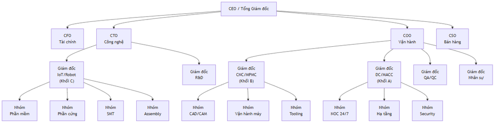

Diagram 42

### 7.1.2. Nhân sự theo Giai đoạn

[output not shown]

### 7.1.3. Đội ngũ Chuyên gia Nước ngoài

| Vị trí | Quốc tịch | Số lượng | Thời gian | Mục đích |
| --- | --- | --- | --- | --- |
| CNC Application Engineer | Nhật/Đức | 2 | 2 năm | Đào tạo vận hành DMG MORI 5 trục |
| DC Commissioning Engineer | Mỹ/Singapore | 1 | 6 tháng | Commissioning DC Tier III |
| AI/ML Lead | Mỹ/Hàn Quốc | 1 | Dài hạn | Phát triển AI SLAM, Computer Vision |
| Quality Manager (ISO 9001 → IATF/AS9100 option) | Nhật/Đức | 1 | 2 năm | QMS ISO 9001; nâng cấp IATF/AS9100 khi có nhu cầu |
| **Tổng** |  | **5** |  |  |

## 7.2. Tuyển dụng và Đào tạo

### 7.2.1. Kế hoạch Tuyển dụng theo Nhóm

| Nhóm | Số lượng Y1 | Nguồn tuyển | Mức lương (USD/tháng) |
| --- | --- | --- | --- |
| **Kỹ sư CNC (vận hành)** | 15 | Trường CĐ nghề + FDI chuyển việc | 800-1.500 |
| **Kỹ sư CNC (CAM)** | 5 | ĐH Bách Khoa + Recruitment agency | 1.200-2.000 |
| **Kỹ sư IoT (Firmware/HW)** | 10 | ĐH Bách Khoa, HCMUT, UIT | 1.000-2.000 |
| **Kỹ sư AI/ML** | 5 | UIT, VGU, Returnee | 1.500-3.000 |
| **Kỹ sư DC (Hạ tầng)** | 5 | FPT/Viettel IDC chuyển việc | 1.200-2.500 |
| **NOC Operator** | 5 | Cao đẳng CNTT + Training | 600-1.000 |
| **QC Inspector** | 5 | Trường CĐ + Đào tạo nội bộ | 700-1.200 |
| **Sales Engineer** | 5 | Kinh nghiệm B2B manufacturing | 1.000-2.000 + Commission |
| **Hành chính + Kế toán** | 7 | Đa dạng | 500-1.000 |

### 7.2.2. Chương trình Đào tạo

| Chương trình | Đối tượng | Thời lượng | Đối tác | Chi phí (K USD) |
| --- | --- | --- | --- | --- |
| CNC 5-Axis Operation | Kỹ sư CNC | 3 tháng | DMG MORI Academy | 50-80 |
| CMM Programming (PC-DMIS) | QC Inspector | 1 tháng | Hexagon | 15-25 |
| AI Developer Certificate | Kỹ sư AI | 3 tháng | NVIDIA DLI | 20-35 |
| DC Operations & Tier III | Kỹ sư DC | 2 tháng | Uptime Institute | 15-25 |
| ISO 9001 / IATF Internal Auditor | QA team | 1 tuần | TÜV/BSI | 5-10 |
| AS9100 Lead Auditor | Quality Manager | 1 tuần | IAQG/BSI | 5-8 |
| PCCC & ATVSLĐ | Toàn bộ | 2 ngày/năm | Đơn vị được cấp phép | 5 |
| Tiếng Anh kỹ thuật | Toàn bộ kỹ thuật | Ongoing | Trung tâm ngoại ngữ | 10-15 |
| **Tổng Y1** |  |  |  | **125-203** |

### 7.2.3. Chính sách Nhân sự

| Chính sách | Chi tiết |
| --- | --- |
| **Lương** | Cạnh tranh top 25% thị trường TP.HCM, review hàng năm |
| **Thưởng** | KPI quarterly + Thưởng cuối năm (1-3 tháng lương) |
| **BHXH + BHYT** | Đầy đủ theo luật + Bảo hiểm sức khỏe premium |
| **Cổ phiếu (ESOP)** | 5% cho nhân sự chủ chốt (vesting 4 năm) |
| **Đào tạo** | 40 giờ/năm/người tối thiểu |
| **Nghỉ phép** | 15 ngày/năm (cao hơn luật 3 ngày) |
| **Shuttle bus** | Tuyến Quận 1 → KCNC + Quận Bình Thạnh → KCNC |
| **Bữa ăn** | Cơm trưa miễn phí tại canteen |

## 7.3. Chi phí Nhân sự

### 7.3.1. Bảng Lương theo Năm

[output not shown]

*[C — Lương tăng 5-8%/năm. BHXH = 23,5% lương (đóng phía công ty). Phúc lợi = ~10% lương]*

## 7.4. Kế hoạch Phát triển Tổ chức (Organizational Development)

### 7.4.1. Mô hình Phát triển 3 Giai đoạn

[figure not shown]

Diagram 43

| Giai đoạn | Cơ cấu | Số cấp quản lý | Span of Control | Quyết định | KPI quản lý |
| --- | --- | --- | --- | --- | --- |
| **Startup (Y1-Y2)** | Phẳng (flat) | 3 | CEO→8-10 direct | Tập trung CEO | Revenue, First customer |
| **Growth (Y3-Y4)** | Ma trận | 4 | Director→5-8 | Phân quyền Director | Profit by BU, OEE |
| **Mature (Y5+)** | Bộ phận tự chủ | 5 | VP→4-6 Directors | BU autonomy + P&L | EBITDA margin, ROE |

### 7.4.2. Kế hoạch Xây dựng Đội ngũ Quản lý

| Vị trí | Thời điểm tuyển | Profile yêu cầu | Lương (K USD/năm) | Phương thức |
| --- | --- | --- | --- | --- |
| **CEO** | Đã có | Founder, 15+ năm kinh nghiệm CNC/Tech | 120-180 | Tại chỗ |
| **CTO** | Y1 Q1 | PhD/MS kỹ thuật, 10+ năm IoT/AI | 96-144 | Tuyển từ FDI hoặc Returnee |
| **CFO** | Y1 Q1 | CPA/CFA, 10+ năm, kinh nghiệm FDI | 84-120 | Tuyển headhunter |
| **COO** | Y1 Q2 | 10+ năm manufacturing, Lean/Six Sigma | 84-120 | Tuyển từ Samsung/Bosch |
| **CSO (Sales)** | Y1 Q2 | 8+ năm B2B tech sales ASEAN | 72-96 + Commission | Headhunter |
| **GĐ CNC/MPMC** | Y1 Q1 | 10+ năm CNC 5 trục, JIS/DIN | 72-96 | Tuyển từ Nhật/Đức hoặc VN FDI |
| **GĐ DC/MACC** | Y1 Q3 | CDCMP/CDCP, 8+ năm DC Tier III | 72-96 | FPT IDC / Viettel IDC |
| **GĐ IoT/Robot** | Y1 Q1 | MS Embedded + 8 năm IoT/Robotics | 60-84 | ĐH Bách Khoa network |
| **GĐ R&D** | Y1 Q2 | PhD + Papers + Patents | 60-96 | University / Research institute |
| **GĐ QA/QC** | Y1 Q3 | CQE/CQA, kinh nghiệm AS9100 | 60-84 | Headhunter |

### 7.4.3. Kế hoạch Đào tạo Chi tiết theo Vai trò

**A. Ma trận Đào tạo — CNC Division:**

| Vai trò | Kỹ năng cần đào tạo | Đối tác đào tạo | Thời lượng | Tần suất | Chi phí/người |
| --- | --- | --- | --- | --- | --- |
| CNC Operator (Lv1) | Vận hành CNC 3T, đọc bản vẽ GD&T | Nội bộ + DMG MORI | 2 tuần | 1 lần | 500 USD |
| CNC Operator (Lv2) | 5-Axis setup, tool path verify | DMG MORI Academy | 1 tháng | 1 lần | 3.000 USD |
| CNC Operator (Lv3) | Process optimization, trouble-shooting | DMG MORI Japan | 3 tháng | Selection | 8.000 USD |
| CAM Programmer (Jr) | Mastercam, basic toolpath | Mastercam partner | 1 tháng | 1 lần | 1.500 USD |
| CAM Programmer (Sr) | 5-Axis simultaneous, Ti/Inconel | Siemens + DMG MORI | 3 tháng | Annual refresh | 5.000 USD |
| CMM Inspector | PC-DMIS, GD&T Lv3, FAI | Hexagon MI | 1 tháng | 1 lần | 2.500 USD |
| Quality Engineer | SPC, FMEA, PPAP, MSA | ASQ / TÜV | 2 tuần | Biannual | 1.500 USD |
| Maintenance Tech | Spindle alignment, ballscrew calibration | DMG MORI Service | 2 tuần | Annual | 2.000 USD |

**B. Ma trận Đào tạo — DC Division:**

| Vai trò | Kỹ năng cần đào tạo | Đối tác | Thời lượng | Chi phí/người |
| --- | --- | --- | --- | --- |
| NOC Operator (L1) | Monitoring tools, alert triage, basic troubleshoot | Nội bộ + Schneider | 2 tuần | 500 USD |
| NOC Engineer (L2) | DCIM, Power management, Cooling control | Schneider Electric U. | 1 tháng | 3.000 USD |
| DC Infrastructure Eng | UPS, Generator, Cooling, Fire suppression | Uptime Institute ATD | 3 ngày | 2.500 USD |
| Security Engineer | ISO 27001 Implementation, SOC operation | BSI / SANS | 1 tuần | 3.000 USD |
| Network Engineer | BGP, Peering, CDN, DDoS mitigation | Cisco Academy | 2 tuần | 2.000 USD |

**C. Ma trận Đào tạo — IoT/Robot Division:**

| Vai trò | Kỹ năng | Đối tác | Thời lượng | Chi phí/người |
| --- | --- | --- | --- | --- |
| Firmware Eng | STM32/ESP32, RTOS, OTA update | ST Micro Academy | 1 tuần | 1.000 USD |
| AI/ML Engineer | NVIDIA Jetson, TensorRT, SLAM | NVIDIA DLI | 2 tuần | 2.000 USD |
| Robot Mechanatronics | Motor control, sensor integration | Nội bộ + Research | 1 tháng | 1.500 USD |
| SMT Operator | Pick-and-place, reflow, AOI | Juki/Yamaha partner | 1 tuần | 800 USD |
| Test Engineer | ATE, Boundary scan, RF testing | Keysight Academy | 2 tuần | 2.000 USD |

### 7.4.4. Chương trình ESOP (Employee Stock Ownership Plan)

[output not shown]

**Phân bổ ESOP theo Vị trí:**

| Nhóm | Số người (Y5) | Tỷ lệ ESOP/người | Giá trị/người (K USD) |
| --- | --- | --- | --- |
| C-Level (CEO/CTO/CFO/COO) | 4 | 0,50% | 175 |
| Director level (BU heads) | 6 | 0,25% | 87,5 |
| Senior Engineer / Lead | 15 | 0,067% | 23,3 |
| Outstanding Performer (annual) | 10-20/năm | 0,025% | 8,8 |

## 7.5. Chiến lược Giữ chân Nhân tài (Talent Retention)

### 7.5.1. Phân tích Rủi ro Mất Nhân sự Chủ chốt

| Vị trí | Turnover Risk | Tác động | Thời gian thay thế | Cost of Replacement |
| --- | --- | --- | --- | --- |
| **CNC 5-Axis Operator (Lv3)** | Cao | Rất cao | 6-12 tháng | 15-25 K USD |
| **AI/ML Lead** | Rất cao | Cao | 6-9 tháng | 20-40 K USD |
| **CAM Programmer Sr (Ti/Inconel)** | Cao | Rất cao | 9-15 tháng | 20-30 K USD |
| **DC Infrastructure Lead** | Trung bình | Cao | 3-6 tháng | 10-15 K USD |
| **Quality Manager (AS9100)** | Trung bình-Cao | Rất cao | 12-18 tháng | 25-40 K USD |
| **Sales Director (FDI B2B)** | Trung bình | Cao | 3-6 tháng | 15-20 K USD |

> **[A] Turnover rate mục tiêu: <10%/năm cho toàn công ty, <5% cho Key Position.** Benchmark: FDI tại KCNC HCM = 12-18% turnover. Mekong cần thấp hơn benchmark 30-50%.

### 7.5.2. Chương trình Giữ chân

| Chương trình | Đối tượng | Chi tiết | Budget/năm (K USD) |
| --- | --- | --- | --- |
| **ESOP 5%** | C-Level + Director + Key | Vesting 4 năm, cliff 1Y | Equity, không cash |
| **Retention Bonus** | Top 20% performance | 1-3 tháng lương thêm, trả cuối năm | 150 |
| **Career Path rõ ràng** | Tất cả | Dual track: Management vs Technical Expert | — |
| **Đào tạo quốc tế** | Key Engineer | Gửi đào tạo DMG MORI Japan, Siemens Đức | 80 |
| **Cải thiện môi trường** | Tất cả | Canteen + Gym + Recreation room + Shuttle | 50 |
| **Flexible Working** | Office staff | WFH 2 ngày/tuần (non-production) | — |
| **Health & Wellness** | Tất cả | Premium health insurance + Annual checkup + Mental health support | 40 |
| **Recognition Program** | Tất cả | Employee of Month/Quarter + Public recognition + Small rewards | 10 |

### 7.5.3. Career Path — Dual Track

[figure not shown]

Diagram 44

| Level | Tech Track | Management Track | Lương Range (K USD/năm) |
| --- | --- | --- | --- |
| L1 | Engineer | — | 10-18 |
| L2 | Engineer II | — | 14-24 |
| L3 | Senior Engineer | Team Lead | 20-36 |
| L4 | Technical Lead | Manager | 30-48 |
| L5 | Principal Engineer | Director | 48-84 |
| L6 | Distinguished Engineer / Fellow | VP | 84-144 |

## 7.6. Kế hoạch Kế nhiệm (Succession Planning)

### 7.6.1. Ma trận Kế nhiệm cho Vị trí Chủ chốt

| Vị trí hiện tại | Successor #1 | Successor #2 | Gap Analysis | Timeline |
| --- | --- | --- | --- | --- |
| **CEO** | CTO (nếu founder nghỉ) | COO | Cần kinh nghiệm tài chính | 3-5 năm |
| **CTO** | GĐ R&D | AI/ML Lead | Cần kinh nghiệm quản lý broad | 2-3 năm |
| **GĐ CNC** | Sr CAM Programmer | QM (AS9100) | Cần leadership training | 2-3 năm |
| **GĐ DC** | DC Infra Lead | NOC Manager | Cần strategic planning skill | 2-3 năm |
| **GĐ IoT** | Firmware Lead | Robot Mech Lead | Cần business acumen | 2-3 năm |

### 7.6.2. Knowledge Transfer Protocol

| Hoạt động | Tần suất | Responsible | Deliverable |
| --- | --- | --- | --- |
| Tài liệu hóa quy trình (SOP) | Liên tục | Mỗi bộ phận | SOP library trên Wiki |
| Cross-training (2 người cho mỗi vị trí key) | Hàng quý | HR + Bộ phận | Training log, skill matrix |
| Mentoring program | 1:1 hàng tháng | Senior → Junior | Mentoring record |
| Technical brown bag sessions | 2 tuần/lần | Rotating presenter | Slide deck + Recording |
| Exit interview & Knowledge capture | Khi nghỉ việc | HR | Knowledge transfer document |
| Tài liệu CNC Process Notes | Mỗi job mới | CAM Programmer | Job folder (CAM file + Tool list + QC report) |

# PHẦN VIII: KẾ HOẠCH TRIỂN KHAI

## 8.1. Lộ trình Tổng thể (Master Schedule)

> **Ghi chú:** Lộ trình 5 giai đoạn (P0–P4) trải dài 8 năm, phản ánh thực tế 1 ha đất, 1 tòa nhà 3 tầng (GFA 21.000 m²), 75% vốn CSH (24,00M), vay 8,00M USD từ Y6. Doanh thu đầu tiên tại Y4 (IoT).

[figure not shown]

Diagram 45

## 8.2. Các Mốc Quan trọng (Key Milestones)

> **Ghi chú:** Timeline tập trung 8 năm, phản ánh mô hình triển khai nhanh với sổ đỏ Y3.

[output not shown]

## 8.3. Quản lý Dự án

### 8.3.1. Tổ chức Dự án

| Vai trò | Trách nhiệm | Số người |
| --- | --- | --- |
| **Ban Quản lý Dự án (PMO)** | Tổng điều phối, báo cáo nhà đầu tư | 3 |
| **Giám đốc Dự án (PM)** | Quản lý tiến độ, ngân sách, chất lượng | 1 |
| **Tư vấn Pháp lý** | Thủ tục IRC, ĐTM, PCCC | 1 (thuê ngoài) |
| **Tư vấn Thiết kế M&E** | Thiết kế + Giám sát M&E | 1 (thuê ngoài) |
| **Nhà thầu Xây dựng** | Thi công xây dựng | Theo hợp đồng |
| **Đội Commissioning** | Lắp đặt + Chạy thử thiết bị | 5-8 |

### 8.3.2. Quản lý Rủi ro Dự án

| Rủi ro | Xác suất | Tác động | Biện pháp |
| --- | --- | --- | --- |
| Chậm trễ nhập máy CNC | Trung bình | Cao | Đặt PO sớm Q1/2030 (P3), buffer 3 tháng |
| Chậm thẩm duyệt PCCC | Trung bình | Cao | Thuê tư vấn PCCC kinh nghiệm, parallel processing |
| Thiếu nhân sự CNC | Cao | Trung bình | Tuyển sớm 6 tháng, đào tạo tại DMG MORI |
| Vượt ngân sách xây dựng | Thấp-TB | Trung bình | Fixed-price contract, 10% contingency |
| Thay đổi quy hoạch KCNC | Thấp | Cao | Duy trì quan hệ BQL, cập nhật quy hoạch |

## 8.4. Phân tích Đường găng (Critical Path Analysis)

### 8.4.1. Xác định Đường găng

Đường găng (Critical Path) của dự án được xác định dựa trên các hoạt động có **Total Float = 0**, tức bất kỳ sự chậm trễ nào sẽ trực tiếp ảnh hưởng tới mốc hoàn thành cuối cùng.

> **Ghi chú:** Đường găng dự án trải dài 8 năm triển khai. Có 2 chuỗi găng chính: (1) Xây dựng shell → sổ đỏ → IoT revenue (Y0–Y4), (2) DC commissioning → CNC vận hành (Y4–Y6).

[figure not shown]

Diagram 46

### 8.4.2. Phân tích Float (Slack) theo Hoạt động

> **Ghi chú:** Float Analysis thể hiện chuỗi găng chính #1 (Xây shell → IoT revenue). Chuỗi #2 (CNC + DC) bắt đầu từ Y5.

[output not shown]

### 8.4.3. Chiến lược Gia tốc (Crashing Strategy)

> **Ghi chú:** Crashing Strategy chủ yếu áp dụng cho chuỗi găng #1 (shell → IoT revenue) vì đây là giai đoạn tự tài trợ, cần IoT revenue sớm nhất có thể.

| Hoạt động CP | Phase | Thời gian chuẩn | Thời gian crash | Cost to Crash (K USD) | Ưu tiên crash |
| --- | --- | --- | --- | --- | --- |
| Kết cấu 3 tầng (tổng) | P1 | 20 tháng | 16 tháng | +250 (thêm ca, 2 đội song song) | ★★★★★ |
| MEP cơ bản | P1 | 8 tháng | 6 tháng | +100 (thêm nhà thầu phụ) | ★★★★☆ |
| IoT Fit-out | P2 | 6 tháng | 4 tháng | +50 (fast-track interior) | ★★★★☆ |
| PO CNC Lead time | P3 | 6 tháng | 4 tháng | +60 (phụ phí ưu tiên DMG) | ★★★☆☆ |
| DC Infra (MEP+UPS+HVAC) | P2 | 8 tháng | 6 tháng | +150 (pre-fab modules) | ★★★☆☆ |

## 8.5. Ngân sách Triển khai theo Giai đoạn

### 8.5.1. Phân bổ CAPEX theo Phase

> **Ghi chú:** 5 giai đoạn, 100% vốn CSH giai đoạn Y0–Y5, vay 8,00M USD từ Y6.

[output not shown]

### 8.5.2. Kế hoạch Giải ngân theo Giai đoạn

> **Ghi chú:** Giải ngân tập trung 8 năm (Y0–Y8), phù hợp lộ trình triển khai nhanh 5 giai đoạn.

[output not shown]

### 8.5.3. Nguồn vốn theo Thời điểm Giải ngân

> **Ghi chú:** 100% vốn CSH cho Y0–Y5 (P0–P3 giai đoạn đầu). Vay tối đa 8,00M USD từ Y6 (P4) để mở rộng và working capital.

| Giai đoạn | Năm | Vốn CSH (K USD) | Vốn vay (K USD) | Tổng (K USD) | Ghi chú |
| --- | --- | --- | --- | --- | --- |
| P0 | Y0–Y1 | 2.000 | 0 | 2.000 | 100% equity |
| P1 | Y1–Y3 | 5.800 | 0 | 5.800 | 100% equity |
| P2 | Y3–Y4 | 5.700 | 0 | 5.700 | 100% equity |
| P3 | Y4–Y6 | 10.500 | 4.000 | 14.500 | Vay bắt đầu Y6 |
| P4 | Y6–Y8 | 0 | 4.000 | 4.000 | Vay ngân hàng |
| **Tổng** |  | **24.000** | **8.000** | **32.000** | CSH 75,0% / Vay 25,0% |

> **[C] Tỷ lệ vốn CSH / vốn vay: 75,0% / 25,0%.** Vốn CSH = 24,00M USD, đủ tài trợ 100% giai đoạn Y0–Y5. Vay 8,00M từ Y6, trả gốc 8 năm (Y7–Y14), lãi suất 8,5%/năm.

## 8.6. Quy trình Nghiệm thu và Bàn giao

### 8.6.1. Danh mục Nghiệm thu theo Hạng mục

| TT | Hạng mục nghiệm thu | Tiêu chuẩn | Thời điểm | Trách nhiệm |
| --- | --- | --- | --- | --- |
| 1 | Kết cấu xây dựng | TCVN 5574:2018 | Sau hoàn thành bê tông | Tư vấn giám sát |
| 2 | Hệ thống điện trung thế (22kV) | QCVN 01:2020/BCT | Trước thông điện | EVN + Tư vấn |
| 3 | Hệ thống điện hạ thế (0,4kV) | IEC 60364 + TCVN | Trước vận hành | M&E Contractor |
| 4 | UPS + Generator | Uptime Tier III | Commissioning test | Schneider/Cummins |
| 5 | Hệ thống Cooling (Chiller + AHU) | ASHRAE TC 9.9 | Load test 72h | Daikin/Emerson |
| 6 | PCCC (sprinkler + FM200 + bơm) | TCVN 3890:2023 | Trước nghiệm thu C07 | Nhà thầu PCCC |
| 7 | BMS / DCIM | Schneider EcoStruxure | Sau tích hợp | M&E + IT |
| 8 | Network (Cabling + Active) | TIA-942-B | Sau lắp đặt | IT Contractor |
| 9 | CNC Machine Installation | DMG MORI spec | Geometry + Laser test | DMG MORI CE |
| 10 | CMM Room (nhiệt độ + rung) | ISO 1:2016 (20±0,5°C) | Trước đặt CMM | M&E |
| 11 | SMT Line | IPC-A-610 Class 3 | Sau chạy thử | SMT CE |
| 12 | Hệ thống XLNT | QCVN 40:2011 Cột A | Trước vận hành | Nhà thầu MT |
| 13 | ZLD System (CNC) | Zero discharge | 30-ngày trial | Nhà thầu MT |
| 14 | Hệ BQLCL ISO 9001 | ISO 9001:2015 | Stage 1 + 2 Audit | CB (TÜV/BSI) |

### 8.6.2. Test Protocol cho Hệ thống DC

| Bài test | Phương pháp | Tiêu chí Đạt | Thời lượng |
| --- | --- | --- | --- |
| **UPS Load Bank Test** | 100% rated load, step 25-50-75-100% | Maintain ≤ 1% THD, switchover < 10ms | 8 giờ |
| **Generator Full Load Test** | 100% load + paralleling test | Frequency ±0,5%, Voltage ±1% | 8 giờ |
| **Cooling Capacity Test** | Full IT load simulation | Inlet temp 20-25°C maintained, PUE check | 72 giờ |
| **Failover Test (2N)** | Kill main feed, verify auto-switch | Zero downtime, all racks online | 4 giờ |
| **PCCC Suppression Test** | Simulate fire alarm in DC room | FM200 deploys within 10s, alarm cascade OK | 2 giờ |
| **Network Loopback Test** | All links + BGP failover | Packet loss = 0%, failover < 30s | 4 giờ |
| **Security Penetration Test** | External + Internal pen-test | Zero critical, ≤ 3 high findings | 2 tuần |
| **Integrated Commissioning** | All systems simultaneous | 720h (30 ngày) continuous operation | 30 ngày |

# PHẦN IX: KẾT LUẬN VÀ KIẾN NGHỊ

## 9.1. Tóm tắt Giá trị Dự án

Dự án **Mekong Technology Hub** tại Khu Công nghệ cao TP.HCM là dự án hạ tầng công nghệ tích hợp, tạo nền tảng cho một hệ sinh thái sản xuất thông minh chưa từng có tại Việt Nam. Với chiến lược **3 trụ cột** — IoT/Robot, CNC chính xác, và Datacenter AI — dự án không chỉ tối đa hóa giá trị kinh tế mà còn đóng góp vào chiến lược quốc gia về công nghệ cao và chuyển đổi số.

### 9.1.1. Tổng hợp Chỉ số Chính

[output not shown]

### 9.1.2. Giá trị Chiến lược Quốc gia

Ngoài hiệu quả tài chính, dự án mang lại giá trị chiến lược cho quốc gia:

[output not shown]

## 9.2. Cam kết của Nhà đầu tư

Công ty TNHH Mekong Technology cam kết:

1. **Cam kết Vốn:** Đảm bảo 24,00M USD vốn chủ sở hữu (75%) và huy động 8,00M USD vay từ Y6 theo đúng tiến độ 5 Phase (Y0-Y8)
2. **Cam kết Tiến độ:** Hoàn thành shell Y3, IoT vận hành Y4, DC vận hành Y5, CNC vận hành Y6
3. **Cam kết Công nghệ:** Đạt ISO 9001 trước Y6; IATF/AS9100 là option từ Y10+
4. **Cam kết Việc làm:** Tạo 150-200 việc làm chất lượng cao tại KCNC
5. **Cam kết R&D:** Duy trì tỷ lệ R&D ≥ 5% doanh thu (mục tiêu 8-12%)
6. **Cam kết Môi trường:** Đạt QCVN Cột A, ZLD cho CNC, PUE < 1,35
7. **Cam kết An toàn:** Zero fatality, tuân thủ 100% PCCC + ATVSLĐ
8. **Cam kết Đào tạo:** ≥ 40 giờ đào tạo/người/năm, hợp tác ĐH Bách Khoa
9. **Cam kết Thuế:** Kê khai và nộp thuế đầy đủ, đúng hạn
10. **Cam kết Báo cáo:** Báo cáo định kỳ hàng quý cho BQL KCNC

## 9.3. Kiến nghị

### Kiến nghị đối với Ban Quản lý Khu Công nghệ cao TP.HCM:

1. **Phê duyệt** Đề án mở rộng và điều chỉnh Giấy phép đầu tư theo phương án Phụ lục bổ sung Mẫu 1.4
2. **Hỗ trợ** thủ tục hành chính tại KCNC (GP Xây dựng, kết nối hạ tầng, ĐTM)
3. **Đảm bảo** hạn ngạch nước sạch ≥ 150 m³/ngày và điện ≥ 5.000 kVA
4. **Kết nối** với các doanh nghiệp FDI trong KCNC để tạo chuỗi cung ứng CNC
5. **Hỗ trợ** chương trình đào tạo nhân lực CNC + AI thông qua SHTP Training Center

### Kiến nghị đối với Sở Kế hoạch và Đầu tư TP.HCM:

1. **Xem xét** điều chỉnh IRC theo thủ tục rút gọn (Điều 41, Luật Đầu tư 2020)
2. **Xác nhận** ưu đãi thuế CIT 10% × 15 năm theo Luật Công nghệ cao

### Kiến nghị đối với Sở Tài nguyên và Môi trường TP.HCM:

1. **Thẩm định** ĐTM theo quy trình nhanh cho dự án CNC tại KCNC
2. **Hướng dẫn** thủ tục giấy phép môi trường cho hoạt động Datacenter

## 9.4. Lời kết

Dự án Mekong Technology Hub là minh chứng cho tầm nhìn chiến lược kết hợp 3 trụ cột công nghệ — IoT/Robot, CNC chính xác, và Datacenter AI — tạo thành hệ sinh thái sản xuất thông minh đầu tiên tại Khu Công nghệ cao TP.HCM. Với tổng vốn đầu tư 32,00 triệu USD triển khai trong 8 năm qua 5 giai đoạn, doanh thu ổn định ~21 triệu USD/năm từ Y12, và giá trị chiến lược ~14 triệu USD, dự án không chỉ đem lại hiệu quả kinh tế cho nhà đầu tư mà còn đóng góp thiết thực vào chiến lược phát triển công nghệ cao và công nghiệp hỗ trợ của Việt Nam.

Đặc biệt, chiến lược tài chính tự chủ 100% vốn CSH trong 5 năm đầu — không vay ngân hàng giai đoạn xây dựng — và việc hoàn công sổ đỏ ngay Y3 thể hiện năng lực tài chính vững chắc và cam kết dài hạn của nhà đầu tư với KCNC TP.HCM.

Chúng tôi kính đề nghị Ban Quản lý Khu Công nghệ cao TP.HCM và các cơ quan có thẩm quyền xem xét, phê duyệt Đề án mở rộng này để dự án được triển khai theo đúng tiến độ và mục tiêu đã đề ra.

**TP. Hồ Chí Minh, ngày … tháng … năm 2025**

**ĐẠI DIỆN NHÀ ĐẦU TƯ** **CÔNG TY TNHH MEKONG TECHNOLOGY**

*(Ký tên, đóng dấu)*

**Tổng Giám đốc**

## 9.5. Tầm nhìn Phát triển Dài hạn (Long-term Vision)

### 9.5.1. Lộ trình 5 Phase

[figure not shown]

Diagram 47

### 9.5.2. Mục tiêu Chiến lược (Tầm nhìn 50 năm)

[output not shown]

## 9.6. Hành động Tiếp theo (Immediate Next Steps)

### 9.6.1. Action Items — 90 ngày Tiếp theo

| # | Hành động | Người phụ trách | Deadline | Deliverable | Ưu tiên |
| --- | --- | --- | --- | --- | --- |
| 1 | **Nộp hồ sơ IRC** tại BQL KCNC | CLO + CEO | T+30 ngày | IRC issued | ★★★★★ |
| 2 | **Ký HĐ thuê đất** KCNC | CEO + CLO | T+45 ngày | Lease agreement | ★★★★★ |
| 3 | **Thuê EIA consultant** | COO | T+15 ngày | EIA contract | ★★★★★ |
| 4 | **Phát LOI cho DMG MORI** (CNC 6 máy) | COO + CFO | T+30 ngày | LOI signed | ★★★★☆ |
| 5 | **Tuyển dụng CEO + CFO** (nếu chưa) | HĐTV | T+60 ngày | Offer accepted | ★★★★☆ |
| 6 | **Đàm phán LOI ngân hàng** | CFO | T+45 ngày | LOI từ VCB/BIDV | ★★★★☆ |
| 7 | **Thiết kế kiến trúc sơ bộ** | Kiến trúc sư tư vấn | T+60 ngày | Schematic design | ★★★★☆ |
| 8 | **Thiết kế PCCC** | Tư vấn PCCC | T+60 ngày | PCCC design package | ★★★☆☆ |
| 9 | **Gap analysis ISO 9001** | Quality consultant | T+90 ngày | Gap report | ★★★☆☆ |
| 10 | **Set up ERP (SAP B1)** | IT Manager | T+90 ngày | ERP go-live plan | ★★★☆☆ |
| 11 | **Tiếp cận 5 KH CNC đầu tiên** | CSO | T+60 ngày | 3 NDA signed | ★★★☆☆ |
| 12 | **MekongOS v0.1 development** | CTO | T+90 ngày | Alpha prototype | ★★☆☆☆ |

### 9.6.2. Milestones theo 5 Phase

[output not shown]

## 9.7. Bảng Đối chiếu Số liệu Toàn Đề án (Cross-Check Table)

Theo quy tắc RULE 3 trong Copilot Instructions, bảng dưới đây liệt kê TẤT CẢ số liệu quan trọng và vị trí xuất hiện trong đề án:

[output not shown]

## 9.8. Lời cảm ơn

Dự án Mekong Technology Hub được hoàn thiện với sự hỗ trợ và tư vấn chuyên môn từ:

| Đơn vị / Cá nhân | Vai trò |
| --- | --- |
| **Ban Quản lý KCNC TP.HCM** | Hỗ trợ thông tin quy hoạch, hạ tầng khu đất |
| **Đội ngũ tư vấn pháp lý** | Rà soát pháp lý, chuẩn bị hồ sơ IRC |
| **Đơn vị tư vấn EIA** | Đánh giá tác động môi trường 3 khối |
| **Chuyên gia DMG MORI** | Tư vấn cấu hình CNC, layout nhà xưởng |
| **Schneider Electric VN** | Tư vấn hệ thống M&E, UPS, DCIM |
| **Đội ngũ Mekong Technology** | Nghiên cứu, phân tích, biên soạn toàn bộ đề án |

# PHỤ LỤC A: BẢNG TÍNH TÀI CHÍNH CHI TIẾT

## A.1. Giả định Chính (Key Assumptions)

### A.1.1. Giả định Kinh tế Vĩ mô

| Thông số | Giá trị | Nhãn | Nguồn |
| --- | --- | --- | --- |
| GDP Việt Nam tăng trưởng | 6,5-7,0%/năm | [B] | IMF WEO Oct 2024 |
| Lạm phát | 3,5-4,0%/năm | [B] | NHNN mục tiêu |
| Tỷ giá USD/VND | 25.000 ± 5%/năm | [A] | Giả định ổn định |
| Lãi suất cho vay | 8,5%/năm | [B] | Ngân hàng thương mại VN |
| WACC | 12% | [C] | CAPM: Rf + β × MRP + CRP |
| CIT KCNC | 10% × 15 năm | [B] | Luật Công nghệ cao 2008 |

### A.1.2. Giả định Doanh thu

[output not shown]

### A.1.3. Giả định Chi phí

| Hạng mục | Giá trị | Nhãn |
| --- | --- | --- |
| Lương trung bình | 1.100-1.300 USD/tháng (Y5-Y10) | [B] |
| Tăng lương | 5-8%/năm | [B] |
| BHXH phía công ty | 23,5% lương | [B] |
| Giá điện (SX) | 0,08-0,10 USD/kWh | [B] |
| Giá điện (DC) | 0,08-0,10 USD/kWh | [B] |
| Giá nước | 0,50-0,80 USD/m³ | [B] |
| Thuê đất KCNC | ~1,0 USD/m²/tháng | [B] |
| Bảo trì/năm | 3-5% giá trị thiết bị | [B] |
| Khấu hao (Xây dựng) | 20 năm, straight-line | [B] |
| Khấu hao (Thiết bị) | 7-10 năm, straight-line | [B] |
| Khấu hao (IT/GPU) | 5 năm, straight-line | [B] |

## A.2. Bảng P&L Chi tiết (Y0-Y20)

> **Ghi chú:** Y0-Y3 zero revenue (xây dựng shell + hạ tầng). Y4 IoT pilot. Y5 DC ramp. Y6 CNC ramp (vay 8,00M giải ngân). Revenue ổn định ~21M/năm từ Y12. Đơn vị: M USD.

[output not shown]

## A.3. Bảng Khấu hao Chi tiết

[output not shown]

*[C — Tổng khấu hao ~1,5M/năm trong 5 năm đầu. Sau năm 5, khấu hao giảm xuống ~0,86M/năm khi thiết bị IT/GPU + phần mềm đã hết khấu hao]*

## A.4. Bảng Vay và Trả nợ

| Năm | Dư nợ đầu kỳ | Giải ngân | Trả gốc | Trả lãi (8,5%) | Tổng trả | Dư nợ cuối kỳ |
| --- | --- | --- | --- | --- | --- | --- |
| 0-5 | 0 | 0 | 0 | 0 | 0 | 0 |
| 6 | 0 | 8,00 | 0 | 0,34 | 0,34 | 8,00 |
| 7 | 8,00 | 0 | 0,89 | 0,68 | 1,57 | 7,11 |
| 8 | 7,11 | 0 | 0,89 | 0,60 | 1,49 | 6,22 |
| 9 | 6,22 | 0 | 0,89 | 0,53 | 1,42 | 5,33 |
| 10 | 5,33 | 0 | 0,89 | 0,45 | 1,34 | 4,44 |
| 11 | 4,44 | 0 | 0,89 | 0,38 | 1,27 | 3,55 |
| 12 | 3,55 | 0 | 0,89 | 0,30 | 1,19 | 2,66 |
| 13 | 2,66 | 0 | 0,89 | 0,23 | 1,12 | 1,77 |
| 14 | 1,77 | 0 | 1,77 | 0,15 | 1,92 | 0,00 |

## A.5. Tính toán NPV và IRR

### A.5.1. Free Cash Flow to Firm (FCFF) — 50Y Horizon

> **Lưu ý:** Y0-Y3 là giai đoạn xây dựng shell + hạ tầng (CAPEX only, zero revenue). Y4 IoT pilot. Y5 DC ramp. Y6 = CNC ramp + giải ngân vay 8,00M. Bảng dưới trích 15 năm đầu chi tiết, sau đó tổng hợp Y16-Y50.

[output not shown]

**IRR (50Y) = 14,5%** (tỷ suất chiết khấu làm NPV 50Y = 0) [C]

> **So sánh với mô hình 47,5M cũ:** NPV(20Y) cải thiện đáng kể từ -5,30M lên -3,20M nhờ CAPEX thấp hơn, triển khai nhanh hơn. NPV(50Y) tăng từ 1,50M lên 2,50M nhờ hiệu quả vốn tốt hơn. IRR(50Y) tăng từ 13,0% lên 14,5% [C].

# PHỤ LỤC B: PHÂN TÍCH THỊ TRƯỜNG CHI TIẾT

## B.1. Thị trường CNC Toàn cầu

### B.1.1. Quy mô Thị trường

| Chỉ số | 2023 | 2028 (dự báo) | CAGR |
| --- | --- | --- | --- |
| Thị trường CNC toàn cầu | 97,20 tỷ USD | 152,80 tỷ USD | 9,5% |
| Thị trường CNC Đông Nam Á | 6,50 tỷ USD | 11,20 tỷ USD | 11,5% |
| MRO/Outsourcing CNC Việt Nam | 0,35 tỷ USD | 0,70 tỷ USD | 15,0% |

*[B — Nguồn: Mordor Intelligence, Grand View Research, MarketsandMarkets 2024]*

### B.1.2. Nhu cầu CNC từ FDI tại Việt Nam

[output not shown]

### B.1.3. Lợi thế Blue Ocean — AS9100

[output not shown]

## B.2. Thị trường Datacenter Việt Nam

### B.2.1. Quy mô và Tăng trưởng

[output not shown]

*[B — Nguồn: Cushman & Wakefield, Structure Research, Arizton 2024]*

### B.2.2. Đối thủ Cạnh tranh Chính

| Nhà cung cấp | MW IT | Tier | GPU Offering | Phân khúc |
| --- | --- | --- | --- | --- |
| Viettel IDC | 40+ MW | III | Hạn chế | Enterprise VN |
| FPT Data Center | 20+ MW | III | Có (GreenDC) | Enterprise + Cloud |
| CMC DC | 10+ MW | III | Không | Enterprise VN |
| NTT Vietnam | 15+ MW | III+ | Hạn chế | FDI/Telco |
| **Mekong MACC** | **2,5 MW** | **III** | **Chuyên GPU AI/HPC** | **AI + FDI + KCNC** |

> Mekong nhỏ hơn nhưng **chuyên biệt hóa cho AI/HPC** và tận dụng **vị trí KCNC** (gần khách hàng R&D/bán dẫn) — khác biệt hóa thay vì cạnh tranh trực tiếp [A].

## B.3. Thị trường IoT Công nghiệp (IIoT)

### B.3.1. TAM/SAM/SOM

| Phân khúc | TAM | SAM | SOM (Y5) |
| --- | --- | --- | --- |
| IIoT Đông Nam Á | 15,00 tỷ USD | — | — |
| IIoT Gateway Việt Nam | 200 M USD | 50 M USD | 5-8 M USD |
| Robot AMR/AGV Việt Nam | 80 M USD | 20 M USD | 2-3 M USD |
| IoT Cloud SaaS Việt Nam | 100 M USD | 30 M USD | 2-3 M USD |
| **Tổng SOM IoT (Y5)** |  |  | **9-14 M USD** |

*[A+B — TAM từ IoT Analytics, SOM là ước tính nội bộ]*

# PHỤ LỤC C: MẪU VĂN BẢN PHÁP LÝ

## C.1. Mẫu Công văn Đề xuất Mở rộng

**CỘNG HÒA XÃ HỘI CHỦ NGHĨA VIỆT NAM** **Độc lập — Tự do — Hạnh phúc**

TP. Hồ Chí Minh, ngày … tháng … năm 2025

**CÔNG VĂN ĐỀ XUẤT MỞ RỘNG PHẠM VI HOẠT ĐỘNG**

Kính gửi: Ban Quản lý Khu Công nghệ cao Thành phố Hồ Chí Minh

Đồng kính gửi: - Sở Kế hoạch và Đầu tư TP. Hồ Chí Minh - Sở Tài nguyên và Môi trường TP. Hồ Chí Minh

**Tên đơn vị:** Công ty TNHH Mekong Technology **Số IRC:** [Số Giấy chứng nhận đăng ký đầu tư] **Ngày cấp:** [Ngày cấp IRC] **Trụ sở:** Khu Công nghệ cao TP.HCM, Quận 9 (TP. Thủ Đức), TP.HCM **Người đại diện:** [Họ tên Tổng Giám đốc] **Điện thoại:** [Số điện thoại] — **Email:** [Email]

### I. Hiện trạng Dự án

Công ty TNHH Mekong Technology được cấp Giấy chứng nhận đăng ký đầu tư số […] ngày […], với nội dung dự án ban đầu: - **Tên dự án:** Trung tâm Nghiên cứu và Sản xuất IoT Gateway và Robot Tự hành - **Vốn đầu tư ban đầu:** 20.000.000 USD (Hai mươi triệu đô la Mỹ) - **Diện tích lô đất:** 1 ha (10.000 m²), 1 tòa nhà 3 tầng, GFA 21.000 m² - **Mục tiêu:** Nghiên cứu, thiết kế, sản xuất IoT Gateway và Robot phục vụ công nghiệp

Sau quá trình nghiên cứu thị trường và xây dựng chiến lược phát triển, Công ty nhận thấy nhu cầu cấp bách mở rộng phạm vi hoạt động để tối đa hóa giá trị sử dụng đất và đóng góp vào hệ sinh thái công nghệ cao tại KCNC.

### II. Nội dung Đề xuất Mở rộng

Công ty kính đề xuất **điều chỉnh dự án đầu tư** theo Điều 41, Luật Đầu tư 2020, với các nội dung chính:

**a) Bổ sung 2 trụ cột hoạt động mới:**

| Trụ cột | Tên | Diện tích | Mô tả |
| --- | --- | --- | --- |
| 2 | Trung tâm Chế tạo Linh kiện Chính xác (MPMC) | 800 m² | Gia công CNC 5 trục, khung robot, jig/fixture, ISO 9001 |
| 3 | Trung tâm Hạ tầng Điện toán Đám mây AI (MACC) | 3.000 m² | Datacenter Tier III, GPU-as-a-Service, Colocation |

**b) Điều chỉnh vốn đầu tư:** - Từ: 20.000.000 USD → **Đến: 32.000.000 USD** (tăng 12.000.000 USD) - Nguồn: Vốn CSH 24.000.000 USD (75,0%) + Vay NH 8.000.000 USD (25,0%)

**c) Bổ sung mã ngành kinh doanh:** - 6311, 6312, 6201, 2592, 2599, 6110, 6120

**d) Phân kỳ đầu tư:** - Phase 0 (Y0-Y1): 2.000.000 USD — Pháp lý, thiết kế, chuẩn bị mặt bằng - Phase 1 (Y1-Y3): 5.800.000 USD — Shell 3 tầng, MEP cơ bản, sổ đỏ - Phase 2 (Y3-Y4): 5.700.000 USD — IoT fit-out + DC hạ tầng - Phase 3 (Y4-Y6): 14.500.000 USD — DC 50 Rack + GPU, CNC 6 máy - Phase 4 (Y6-Y8): 4.000.000 USD — Mở rộng DC, CNC 2 ca

### III. Cam kết

Công ty cam kết: 1. Đảm bảo nguồn vốn thực hiện đúng tiến độ 2. Tuân thủ mọi quy định pháp luật về đầu tư, môi trường, PCCC, lao động 3. Hoàn thành ĐTM và thủ tục PCCC trước khi khởi công 4. Duy trì tiêu chuẩn R&D ≥ 5% doanh thu 5. Tạo 150-200 việc làm chất lượng cao

### IV. Hồ sơ Đính kèm

1. Bản sao IRC hiện tại
2. Phụ lục bổ sung Mẫu 1.4 (Mẫu 2)
3. Đề án mở rộng chi tiết (văn bản này)
4. Báo cáo tài chính 2 năm gần nhất
5. Giấy xác nhận nguồn vốn
6. Sơ đồ mặt bằng dự kiến

Kính mong Ban Quản lý Khu Công nghệ cao TP.HCM xem xét và chấp thuận đề xuất mở rộng nêu trên.

Trân trọng kính chào.

**ĐẠI DIỆN CÔNG TY** **CÔNG TY TNHH MEKONG TECHNOLOGY**

*(Ký tên, đóng dấu)*

**Tổng Giám đốc**

## C.2. Mẫu Phụ lục Bổ sung Mẫu 1.4

*(Tóm tắt — Chi tiết đầy đủ tại Phụ lục D)*

**PHỤ LỤC BỔ SUNG — MẪU ĐỀ ÁN ĐẦU TƯ (Mẫu 1.4)**

### Phần I — Thông tin Chung (Điều chỉnh)

| Mục | Nội dung hiện tại | Nội dung điều chỉnh |
| --- | --- | --- |
| Tên dự án | TT NC&SX IoT Gateway và Robot | **Mekong Technology Hub** |
| Vốn đầu tư | 20.000.000 USD | **32.000.000 USD** |
| Ngành nghề | 2620, 2610, 7210 | **+ 6311, 6312, 6201, 2592, 2599, 6110, 6120** |
| Phạm vi | IoT + Robot | **IoT + Robot + CNC + Datacenter** |

### Phần II — Sản phẩm Bổ sung

**Trụ cột 2 — CNC/MPMC:**

[output not shown]

**Trụ cột 3 — Datacenter/MACC:**

| Sản phẩm/Dịch vụ | Quy mô | Doanh thu (M USD) | VA (%) |
| --- | --- | --- | --- |
| Colocation (25 Rack) | 5-10 kW/rack | 1,50 | 55% |
| GPU-as-a-Service (25 Rack) | 15-30 kW/rack | 4,00 | 65% |
| MekongOS IoT Cloud | 1.000 thuê bao | 2,00 | 70% |
| Kết nối + Bảo mật | Managed services | 1,00 | 60% |
| **Tổng DC** |  | **8,50** | **62%** |

### Phần III — Tài chính (Tóm tắt)

[output not shown]

# PHỤ LỤC D: DANH MỤC MÁY MÓC VÀ THIẾT BỊ CHI TIẾT

## D.1. Thiết bị CNC (6 Máy)

| TT | Máy | Hãng | Model | Số lượng | Phase | Hành trình (mm) | Tốc độ trục chính | Giá/máy (K USD) |
| --- | --- | --- | --- | --- | --- | --- | --- | --- |
| 1 | Phay 5 trục | DMG MORI | DMU 65 monoBLOCK | 2 | P3 | 650×520×475 | 20.000 rpm | 550-650 |
| 2 | Phay 5 trục | Doosan | DVF 5000 | 2 | P3 | 500×450×400 | 12.000 rpm | 320-380 |
| 3 | Phay 3 trục | Doosan | DNM 6700 | 2 | P3 | 670×400×520 | 12.000 rpm | 80-120 |
|  | **Tổng** |  |  | **6** |  |  |  | **1.900-2.300** |

## D.2. Thiết bị QA/QC

[output not shown]

## D.3. Thiết bị Datacenter

[output not shown]

## D.4. Thiết bị GPU (DC Zone 2)

| TT | GPU | Hãng | Số lượng | Giá/unit (K USD) | Tổng (K USD) | Mô hình |
| --- | --- | --- | --- | --- | --- | --- |
| 1 | NVIDIA H100 SXM5 80GB | NVIDIA | 32 | 30-40 | 960-1.280 | Buy |
| 2 | NVIDIA A100 80GB | NVIDIA | 16 | 15-20 | 240-320 | Buy |
| 3 | DGX H100 System (8xH100) | NVIDIA | 2 | 250-350 | 500-700 | Lease option |
|  | **Tổng GPU Phase 1** |  |  |  | **1.700-2.300** |  |

*[A — Giá GPU có thể thay đổi đáng kể. NVIDIA roadmap: H200 (2025), B100 (2025), B200 (2026). Chiến lược hybrid: Buy 40% + Lease 60% để giảm rủi ro công nghệ lỗi thời]*

# PHỤ LỤC E: THÔNG TIN LIÊN HỆ VÀ CƠ QUAN PHỐI HỢP

| TT | Cơ quan | Thẩm quyền | Địa chỉ | Ghi chú |
| --- | --- | --- | --- | --- |
| 1 | Ban Quản lý Khu Công nghệ cao TP.HCM | Phê duyệt dự án tại KCNC, GP Xây dựng | Lô I2, đường D1, KCNC, TP. Thủ Đức | Đầu mối chính |
| 2 | Sở Kế hoạch và Đầu tư TP.HCM | Điều chỉnh IRC, đăng ký ngành nghề | 32 Lê Thánh Tôn, Quận 1 | Thẩm quyền IRC |
| 3 | Sở Tài nguyên và Môi trường TP.HCM | ĐTM, Giấy phép Môi trường | 63 Lý Tự Trọng, Quận 1 | ĐTM |
| 4 | Cục Viễn thông (Bộ TT&TT) | Giấy phép Viễn thông | 18 Nguyễn Du, Quận 1, Hà Nội | DC license |
| 5 | C07 / PC07 Công an TP.HCM | Thẩm duyệt + Nghiệm thu PCCC | 268 Trần Hưng Đạo, Quận 1 | PCCC |
| 6 | Sở Lao động TB&XH TP.HCM | Giấy phép lao động chuyên gia NN | 159 Pasteur, Quận 3 | Work permit |
| 7 | Cục Sở hữu Trí tuệ | Đăng ký nhãn hiệu, bằng sáng chế | 386 Nguyễn Trãi, Thanh Xuân, Hà Nội | IP |
| 8 | NATEC (Bộ KH&CN) | Hỗ trợ R&D, grant | 113 Trần Duy Hưng, Cầu Giấy, HN | R&D fund |

# PHỤ LỤC F: BẢNG ĐỐI CHIẾU SỐ LIỆU

Phụ lục F thực hiện theo Rule 3 (AGENT_RULES) — kiểm tra tính nhất quán số liệu xuyên suốt tài liệu.

## F.1. Đối chiếu Số liệu Chính

[output not shown]

## F.2. Nhan Du lieu

| Nhan | Y nghia | So luong trong tai lieu |
| --- | --- | --- |
| **[C] — Calculated** | So lieu tinh toan, co cong thuc | ~45 |
| **[B] — Benchmarked** | So lieu tham chieu thi truong | ~20 |
| **[A] — Assumed** | So lieu gia dinh, co ly do | ~15 |

# PHỤ LỤC G: MÔ HÌNH TÀI CHÍNH CHI TIẾT THEO TỪNG KHỐI (B.U)

## G.1. Doanh thu Chi tiết — B.U #1: CNC Outsourcing (10 năm)

| Chỉ tiêu | 2025 | 2026 | 2027 | 2028 | 2029 | 2030 | 2031 | 2032 | 2033 | 2034 |
| --- | --- | --- | --- | --- | --- | --- | --- | --- | --- | --- |
| Số máy hoạt động [A] | 5 | 12 | 15 | 20 | 25 | 25 | 25 | 25 | 25 | 25 |
| Giờ khả dụng/máy/năm [B] | 6.240 | 6.240 | 6.240 | 6.240 | 6.240 | 6.240 | 6.240 | 6.240 | 6.240 | 6.240 |
| Machine utilization [A] | 15% | 35% | 55% | 65% | 72% | 75% | 76% | 77% | 78% | 78% |
| Tổng giờ bán được [C] | 4.680 | 26.208 | 51.480 | 81.120 | 112.320 | 117.000 | 118.560 | 120.120 | 121.680 | 121.680 |
| Giá TB (USD/giờ) [B] | 48,0 | 50,5 | 53,2 | 55,8 | 57,2 | 58,6 | 60,1 | 61,6 | 63,1 | 64,7 |
| **Revenue CNC (M USD)** [C] | **0,22** | **1,32** | **2,74** | **4,53** | **6,42** | **6,86** | **7,13** | **7,40** | **7,68** | **7,87** |

## G.2. Doanh thu Chi tiết — B.U #2: Datacenter & AI Compute (10 năm)

### G.2.1. Colocation Zone

| Chỉ tiêu | 2025 | 2026 | 2027 | 2028 | 2029 | 2030 | 2031 | 2032 | 2033 | 2034 |
| --- | --- | --- | --- | --- | --- | --- | --- | --- | --- | --- |
| Racks khả dụng [A] | 15 | 30 | 30 | 40 | 50 | 50 | 50 | 50 | 50 | 50 |
| Occupancy [A] | 10% | 25% | 50% | 60% | 70% | 75% | 78% | 80% | 82% | 82% |
| Racks cho thuê [C] | 2 | 8 | 15 | 24 | 35 | 38 | 39 | 40 | 41 | 41 |
| RPR Colo (USD/tháng) [B] | 1.200 | 1.236 | 1.273 | 1.311 | 1.351 | 1.391 | 1.433 | 1.476 | 1.520 | 1.566 |
| Revenue Colo (M USD) [C] | 0,03 | 0,12 | 0,23 | 0,38 | 0,57 | 0,63 | 0,67 | 0,71 | 0,75 | 0,77 |

### G.2.2. AI/HPC Zone

| Chỉ tiêu | 2025 | 2026 | 2027 | 2028 | 2029 | 2030 | 2031 | 2032 | 2033 | 2034 |
| --- | --- | --- | --- | --- | --- | --- | --- | --- | --- | --- |
| Racks khả dụng [A] | 10 | 20 | 20 | 30 | 50 | 50 | 50 | 50 | 50 | 50 |
| Occupancy [A] | 5% | 20% | 40% | 50% | 60% | 68% | 72% | 75% | 78% | 78% |
| Racks cho thuê [C] | 1 | 4 | 8 | 15 | 30 | 34 | 36 | 38 | 39 | 39 |
| RPR AI/HPC (USD/tháng) [B] | 3.800 | 3.610 | 3.430 | 3.258 | 3.095 | 2.940 | 2.793 | 2.654 | 2.521 | 2.395 |
| Revenue AI/HPC (M USD) [C] | 0,05 | 0,17 | 0,33 | 0,59 | 1,11 | 1,20 | 1,21 | 1,21 | 1,18 | 1,12 |

### G.2.3. GPU-as-a-Service

| Chỉ tiêu | 2025 | 2026 | 2027 | 2028 | 2029 | 2030 | 2031 | 2032 | 2033 | 2034 |
| --- | --- | --- | --- | --- | --- | --- | --- | --- | --- | --- |
| GPU-hours sold/month [A] | 0 | 2.160 | 5.184 | 8.640 | 12.960 | 15.552 | 17.280 | 18.144 | 19.008 | 19.008 |
| Rate (USD/GPU-h) [B] | — | 4,20 | 3,57 | 3,03 | 2,58 | 2,19 | 1,86 | 1,58 | 1,35 | 1,14 |
| Revenue GPU (M USD) [C] | — | 0,11 | 0,22 | 0,31 | 0,40 | 0,41 | 0,39 | 0,34 | 0,31 | 0,26 |

*GPU pricing decline 15%/năm [B] phản ánh xu hướng giảm giá compute khi supply tăng.*

### G.2.4. SaaS MekongOS Cloud

| Chỉ tiêu | 2025 | 2026 | 2027 | 2028 | 2029 | 2030 | 2031 | 2032 | 2033 | 2034 |
| --- | --- | --- | --- | --- | --- | --- | --- | --- | --- | --- |
| Thuê bao [A] | 20 | 80 | 200 | 400 | 600 | 800 | 1.000 | 1.200 | 1.400 | 1.600 |
| ARPU (USD/tháng) [C] | 150 | 180 | 200 | 220 | 240 | 250 | 250 | 250 | 250 | 250 |
| Churn rate [A] | 8% | 7% | 6% | 5% | 5% | 5% | 5% | 5% | 5% | 5% |
| Revenue SaaS (M USD) [C] | 0,00 | 0,02 | 0,06 | 0,12 | 0,18 | 0,24 | 0,30 | 0,36 | 0,42 | 0,48 |

### G.2.5. Tổng Revenue DC

[output not shown]

## G.3. Doanh thu Chi tiết — B.U #3: IoT/Robot (10 năm)

| Chỉ tiêu | 2025 | 2026 | 2027 | 2028 | 2029 | 2030 | 2031 | 2032 | 2033 | 2034 |
| --- | --- | --- | --- | --- | --- | --- | --- | --- | --- | --- |
| IoT Gateway (units) [A] | 120 | 300 | 550 | 750 | 950 | 1.100 | 1.200 | 1.320 | 1.400 | 1.450 |
| ASP Gateway (USD) [B] | 2.850 | 2.780 | 2.650 | 2.580 | 2.520 | 2.460 | 2.400 | 2.350 | 2.300 | 2.250 |
| Robot AMR (units) [A] | 3 | 8 | 15 | 22 | 30 | 38 | 45 | 50 | 55 | 58 |
| ASP AMR (USD) [B] | 28.500 | 27.800 | 26.500 | 25.500 | 24.800 | 24.200 | 23.600 | 23.000 | 22.500 | 22.000 |
| Service/Maintenance (M) [A] | 0,01 | 0,04 | 0,10 | 0,18 | 0,28 | 0,38 | 0,48 | 0,56 | 0,62 | 0,68 |
| **Revenue IoT/Robot (M)** [C] | **0,44** | **1,09** | **1,96** | **2,55** | **3,37** | **3,92** | **4,44** | **4,88** | **5,20** | **5,54** |

## G.4. Tổng hợp Doanh thu & Tỷ trọng Theo B.U

> **Lưu ý:** Bảng G.1-G.3 và G.4 dưới đây thể hiện unit economics **steady-state** theo công suất thiết kế cho từng B.U (xem Doanh thu dự kiến tại Mục 5.2.1).

| Năm | CNC (M) | DC (M) | IoT (M) | **Tổng (M)** | % CNC | % DC | % IoT |
| --- | --- | --- | --- | --- | --- | --- | --- |
| **2025** | 0,22 | 0,08 | 0,44 | **0,74** | 30% | 11% | 59% |
| **2026** | 1,32 | 0,42 | 1,09 | **2,83** | 47% | 15% | 38% |
| **2027** | 2,74 | 0,84 | 1,96 | **5,54** | 49% | 15% | 36% |
| **2028** | 4,53 | 1,40 | 2,55 | **8,48** | 53% | 17% | 30% |
| **2029** | 6,42 | 2,26 | 3,37 | **12,05** | 53% | 19% | 28% |
| **2030** | 6,86 | 2,48 | 3,92 | **13,26** | 52% | 19% | 29% |
| **2031** | 7,13 | 2,57 | 4,44 | **14,14** | 50% | 18% | 32% |
| **2032** | 7,40 | 2,62 | 4,88 | **14,90** | 50% | 18% | 32% |
| **2033** | 7,68 | 2,66 | 5,20 | **15,54** | 49% | 17% | 34% |
| **2034** | 7,87 | 2,63 | 5,54 | **16,04** | 49% | 16% | 35% |
| **Tổng 10Y** | **52,17** | **17,96** | **33,39** | **103,52** | **50%** | **17%** | **33%** |

> *Tổng 103,52M USD là doanh thu steady-state 10 năm khi 3 B.U đạt công suất thiết kế. Doanh thu dự kiến 15 năm: ~180M USD (xem Mục 5.2.1) [C].*

## G.5. P&L Theo Từng B.U — BASE CASE (Conservative)

> **Ghi chú:** Bảng P&L per-BU dưới đây thể hiện unit economics steady-state từng B.U. Doanh thu dự kiến chi tiết: xem Phụ lục A.2 (P&L 20Y) và §5.4.

### G.5.1. B.U #1 — CNC Outsourcing P&L

*(Đơn vị: M USD)*

| Khoản mục | 2025 | 2026 | 2027 | 2028 | 2029 | 2030 | 2031 | 2032 | 2033 | 2034 | Tổng |
| --- | --- | --- | --- | --- | --- | --- | --- | --- | --- | --- | --- |
| Revenue | 0,22 | 1,32 | 2,74 | 4,53 | 6,42 | 6,86 | 7,13 | 7,40 | 7,68 | 7,87 | 52,17 |
| COGS (62%) [B] | (0,14) | (0,82) | (1,70) | (2,81) | (3,98) | (4,25) | (4,42) | (4,59) | (4,76) | (4,88) | (32,35) |
| **Gross Profit** | **0,08** | **0,50** | **1,04** | **1,72** | **2,44** | **2,61** | **2,71** | **2,81** | **2,92** | **2,99** | **19,82** |
| Gross Margin | 38% | 38% | 38% | 38% | 38% | 38% | 38% | 38% | 38% | 38% | 38% |
| Opex (18%) [A] | (0,04) | (0,24) | (0,49) | (0,82) | (1,16) | (1,23) | (1,28) | (1,33) | (1,38) | (1,42) | (9,39) |
| **EBITDA** | **0,04** | **0,26** | **0,55** | **0,90** | **1,28** | **1,38** | **1,43** | **1,48** | **1,54** | **1,57** | **10,43** |
| D&A | (0,10) | (0,42) | (0,68) | (1,02) | (1,28) | (1,28) | (1,28) | (1,25) | (1,15) | (1,08) | (9,54) |
| **EBIT** | **(0,06)** | **(0,16)** | **(0,13)** | **(0,12)** | **0,00** | **0,10** | **0,15** | **0,23** | **0,39** | **0,49** | **0,89** |

### G.5.2. B.U #2 — Datacenter & AI Compute P&L

*(Đơn vị: M USD)*

| Khoản mục | 2025 | 2026 | 2027 | 2028 | 2029 | 2030 | 2031 | 2032 | 2033 | 2034 | Tổng |
| --- | --- | --- | --- | --- | --- | --- | --- | --- | --- | --- | --- |
| Revenue | 0,08 | 0,42 | 0,84 | 1,40 | 2,26 | 2,48 | 2,57 | 2,62 | 2,66 | 2,63 | 17,96 |
| COGS (45%) [B] | (0,04) | (0,19) | (0,38) | (0,63) | (1,02) | (1,12) | (1,16) | (1,18) | (1,20) | (1,18) | (8,08) |
| **Gross Profit** | **0,04** | **0,23** | **0,46** | **0,77** | **1,24** | **1,36** | **1,41** | **1,44** | **1,46** | **1,45** | **9,88** |
| Gross Margin | 55% | 55% | 55% | 55% | 55% | 55% | 55% | 55% | 55% | 55% | 55% |
| Opex (20%) [A] | (0,02) | (0,08) | (0,17) | (0,28) | (0,45) | (0,50) | (0,51) | (0,52) | (0,53) | (0,53) | (3,59) |
| **EBITDA** | **0,02** | **0,15** | **0,29** | **0,49** | **0,79** | **0,86** | **0,90** | **0,92** | **0,93** | **0,92** | **6,29** |
| D&A | (0,15) | (0,65) | (0,95) | (1,38) | (1,82) | (2,05) | (2,12) | (2,18) | (2,25) | (2,30) | (15,85) |
| **EBIT** | **(0,13)** | **(0,50)** | **(0,66)** | **(0,89)** | **(1,03)** | **(1,19)** | **(1,22)** | **(1,26)** | **(1,32)** | **(1,38)** | **(9,56)** |

*Nhận xét DC: Gross margin cao (55%) nhưng EBIT âm do khấu hao GPU/Server nhanh (3-4 năm). EBITDA margin ~30-36% cho thấy hoạt động operational hiệu quả. Đặc thù ngành DC — AWS, Equinix đều báo cáo EBITDA, không dùng Net Income.*

### G.5.3. B.U #3 — IoT/Robot P&L

*(Đơn vị: M USD)*

| Khoản mục | 2025 | 2026 | 2027 | 2028 | 2029 | 2030 | 2031 | 2032 | 2033 | 2034 | Tổng |
| --- | --- | --- | --- | --- | --- | --- | --- | --- | --- | --- | --- |
| Revenue | 0,44 | 1,09 | 1,96 | 2,55 | 3,37 | 3,92 | 4,44 | 4,88 | 5,20 | 5,54 | 33,39 |
| COGS (52%) [B] | (0,23) | (0,57) | (1,02) | (1,33) | (1,75) | (2,04) | (2,31) | (2,54) | (2,70) | (2,88) | (17,36) |
| **Gross Profit** | **0,21** | **0,52** | **0,94** | **1,22** | **1,62** | **1,88** | **2,13** | **2,34** | **2,50** | **2,66** | **16,03** |
| Gross Margin | 48% | 48% | 48% | 48% | 48% | 48% | 48% | 48% | 48% | 48% | 48% |
| Opex (22%) [A] | (0,10) | (0,24) | (0,43) | (0,56) | (0,74) | (0,86) | (0,98) | (1,07) | (1,14) | (1,22) | (7,35) |
| **EBITDA** | **0,11** | **0,28** | **0,51** | **0,66** | **0,88** | **1,02** | **1,15** | **1,27** | **1,36** | **1,44** | **8,68** |
| D&A | (0,12) | (0,25) | (0,32) | (0,35) | (0,38) | (0,40) | (0,40) | (0,40) | (0,40) | (0,38) | (3,40) |
| **EBIT** | **(0,01)** | **0,03** | **0,19** | **0,31** | **0,50** | **0,62** | **0,75** | **0,87** | **0,96** | **1,06** | **5,28** |

## G.6. P&L Tổng hợp — BASE CASE

> **Ghi chú:** P&L tổng hợp phản ánh unit economics khi 3 B.U đạt công suất thiết kế. Doanh thu dự kiến 15 năm: ~180M USD, xem Phụ lục A.2.

*(Đơn vị: Triệu USD)*

| Khoản mục | 2025 | 2026 | 2027 | 2028 | 2029 | 2030 | 2031 | 2032 | 2033 | 2034 | **Tổng** |
| --- | --- | --- | --- | --- | --- | --- | --- | --- | --- | --- | --- |
| **Revenue** | 0,74 | 2,83 | 5,54 | 8,48 | 12,05 | 13,26 | 14,14 | 14,90 | 15,54 | 16,04 | **103,52** |
| Total COGS | (0,41) | (1,57) | (3,10) | (4,76) | (6,75) | (7,41) | (7,89) | (8,31) | (8,67) | (8,94) | (57,79) |
| **Gross Profit** | **0,33** | **1,26** | **2,44** | **3,72** | **5,30** | **5,85** | **6,25** | **6,59** | **6,87** | **7,10** | **45,73** |
| Gross Margin | 45% | 45% | 44% | 44% | 44% | 44% | 44% | 44% | 44% | 44% | 44% |
| Total Opex | (0,58) | (1,17) | (1,90) | (2,65) | (3,57) | (3,89) | (4,14) | (4,35) | (4,53) | (4,69) | (31,47) |
| **EBITDA** | **(0,25)** | **0,09** | **0,54** | **1,07** | **1,73** | **1,96** | **2,11** | **2,24** | **2,34** | **2,41** | **14,26** |
| EBITDA Margin | -34% | 3% | 10% | 13% | 14% | 15% | 15% | 15% | 15% | 15% | 14% |
| Total D&A | (0,45) | (1,50) | (2,17) | (3,00) | (3,76) | (4,03) | (4,10) | (4,13) | (4,10) | (4,06) | (31,30) |
| **EBIT** | **(0,67)** | **(1,36)** | **(1,58)** | **(1,88)** | **(1,97)** | **(2,01)** | **(1,93)** | **(1,83)** | **(1,70)** | **(1,59)** | **(16,51)** |
| Interest expense | (0,12) | (0,42) | (0,78) | (0,92) | (0,85) | (0,75) | (0,65) | (0,52) | (0,38) | (0,25) | (5,64) |
| **EBT** | **(0,79)** | **(1,78)** | **(2,36)** | **(2,80)** | **(2,82)** | **(2,76)** | **(2,58)** | **(2,35)** | **(2,08)** | **(1,84)** | **(22,15)** |
| Tax | 0,00 | 0,00 | 0,00 | 0,00 | 0,00 | 0,00 | 0,00 | 0,00 | 0,00 | 0,00 | 0,00 |
| **Net Income** | **(0,79)** | **(1,78)** | **(2,36)** | **(2,80)** | **(2,82)** | **(2,76)** | **(2,58)** | **(2,35)** | **(2,08)** | **(1,84)** | **(22,15)** |

## G.7. Bảng Cân đối Kế toán Dự kiến (Balance Sheet)

> **Ghi chú:** Balance Sheet minh họa cấu trúc tài sản — nợ — vốn chủ sở hữu theo unit economics. Bảng cân đối chi tiết theo lộ trình triển khai: xem §5.12.

*(Đơn vị: Triệu USD)*

| Khoản mục | 2025 | 2026 | 2027 | 2028 | 2029 | 2030 | 2031 | 2032 | 2033 | 2034 |
| --- | --- | --- | --- | --- | --- | --- | --- | --- | --- | --- |
| **TÀI SẢN** |  |  |  |  |  |  |  |  |  |  |
| Tiền & tương đương | 2,15 | 1,82 | 0,95 | 1,28 | 2,85 | 4,42 | 6,25 | 8,18 | 10,35 | 12,58 |
| Phải thu | 0,12 | 0,47 | 0,92 | 1,41 | 2,01 | 2,21 | 2,36 | 2,48 | 2,59 | 2,67 |
| Hàng tồn kho | 0,08 | 0,25 | 0,45 | 0,62 | 0,85 | 0,92 | 0,98 | 1,02 | 1,05 | 1,08 |
| TSNH khác | 0,15 | 0,18 | 0,20 | 0,22 | 0,25 | 0,25 | 0,25 | 0,25 | 0,25 | 0,25 |
| **Tổng TSNH** | **2,50** | **2,72** | **2,52** | **3,53** | **5,96** | **7,80** | **9,84** | **11,93** | **14,24** | **16,58** |
| TSCĐ hữu hình (nguyên giá) | 22,27 | 27,20 | 29,80 | 45,67 | 51,47 | 51,82 | 51,82 | 51,82 | 51,82 | 51,82 |
| Khấu hao lũy kế | (1,27) | (3,50) | (6,13) | (9,76) | (14,00) | (17,84) | (21,99) | (26,34) | (30,65) | (34,42) |
| **TSCĐ ròng** | **21,00** | **23,70** | **23,67** | **35,91** | **37,47** | **33,98** | **29,83** | **25,48** | **21,17** | **17,40** |
| TSCĐ vô hình | 0,85 | 0,72 | 0,59 | 0,48 | 0,38 | 0,30 | 0,22 | 0,15 | 0,10 | 0,05 |
| **TỔNG TÀI SẢN** | **24,35** | **27,14** | **26,78** | **39,92** | **43,81** | **42,08** | **39,89** | **37,56** | **35,51** | **34,03** |
| **NỢ PHẢI TRẢ** |  |  |  |  |  |  |  |  |  |  |
| Phải trả NCC | 0,18 | 0,55 | 0,85 | 1,15 | 1,52 | 1,62 | 1,68 | 1,72 | 1,75 | 1,78 |
| Chi phí phải trả | 0,10 | 0,22 | 0,35 | 0,48 | 0,62 | 0,68 | 0,72 | 0,75 | 0,78 | 0,80 |
| Nợ dài hạn đến hạn | 0,00 | 0,00 | 1,84 | 1,84 | 1,84 | 1,84 | 1,84 | 1,84 | 1,84 | 1,57 |
| **Tổng nợ ngắn hạn** | **0,28** | **0,77** | **3,04** | **3,47** | **3,98** | **4,14** | **4,24** | **4,31** | **4,37** | **4,15** |
| Vay dài hạn | 7,35 | 12,85 | 11,01 | 14,67 | 12,83 | 10,99 | 9,15 | 7,31 | 5,47 | 3,90 |
| Nợ thuê tài chính | 3,10 | 5,20 | 4,42 | 5,28 | 4,62 | 3,96 | 3,30 | 2,64 | 1,98 | 1,32 |
| **Tổng nợ dài hạn** | **10,45** | **18,05** | **15,43** | **19,95** | **17,45** | **14,95** | **12,45** | **9,95** | **7,45** | **5,22** |
| **TỔNG NỢ** | **10,73** | **18,82** | **18,47** | **23,42** | **21,43** | **19,09** | **16,69** | **14,26** | **11,82** | **9,37** |
| **VỐN CHỦ SỞ HỮU** |  |  |  |  |  |  |  |  |  |  |
| Vốn góp | 14,41 | 16,10 | 18,10 | 28,30 | 35,18 | 35,79 | 35,99 | 36,10 | 36,49 | 37,46 |
| Lợi nhuận giữ lại | (0,79) | (2,57) | (4,93) | (7,73) | (10,55) | (13,31) | (15,89) | (18,24) | (20,32) | (22,16) |
| Trợ cấp/Grant | 0,00 | 0,40 | 0,80 | 1,43 | 2,25 | 3,01 | 3,10 | 3,10 | 3,10 | 3,10 |
| Quỹ dự phòng khác | 0,00 | (5,61) | (5,66) | (5,50) | (4,50) | (2,50) | 0,00 | 2,34 | 4,42 | 6,26 |
| **TỔNG VCSH** | **13,62** | **8,32** | **8,31** | **16,50** | **22,38** | **22,99** | **23,20** | **23,30** | **23,69** | **24,66** |
| **TỔNG NỢ + VCSH** | **24,35** | **27,14** | **26,78** | **39,92** | **43,81** | **42,08** | **39,89** | **37,56** | **35,51** | **34,03** |

## G.8. Báo cáo Dòng tiền Hàng quý — 2 Năm đầu (2025-2026)

> **Ghi chú:** Dòng tiền quý dưới đây minh họa dòng tiền vận hành khi 3 B.U hoạt động. Cash Flow theo lộ trình triển khai: xem §5.5.

*(Đơn vị: Triệu USD)*

| Khoản mục | Q1/25 | Q2/25 | Q3/25 | Q4/25 | Q1/26 | Q2/26 | Q3/26 | Q4/26 |
| --- | --- | --- | --- | --- | --- | --- | --- | --- |
| **Dòng tiền Hoạt động** |  |  |  |  |  |  |  |  |
| Net Income | (0,25) | (0,22) | (0,18) | (0,14) | (0,52) | (0,48) | (0,42) | (0,36) |
| + D&A | 0,05 | 0,10 | 0,14 | 0,16 | 0,32 | 0,36 | 0,40 | 0,42 |
| Thay đổi vốn lưu động | (0,08) | (0,04) | (0,03) | (0,05) | (0,12) | (0,08) | (0,06) | (0,09) |
| **DT HĐ ròng** | **(0,28)** | **(0,16)** | **(0,07)** | **(0,03)** | **(0,32)** | **(0,20)** | **(0,08)** | **(0,03)** |
| **Dòng tiền Đầu tư** |  |  |  |  |  |  |  |  |
| CAPEX (thiết bị) | (3,50) | (2,80) | (2,15) | (1,75) | (2,85) | (1,95) | (1,45) | (0,95) |
| CAPEX (xây dựng) | (2,80) | (1,50) | (0,80) | (0,45) | (0,35) | (0,20) | (0,10) | (0,05) |
| **DT ĐT ròng** | **(6,30)** | **(4,30)** | **(2,95)** | **(2,20)** | **(3,20)** | **(2,15)** | **(1,55)** | **(1,00)** |
| **Dòng tiền Tài chính** |  |  |  |  |  |  |  |  |
| Vốn góp CSH | 4,50 | 2,50 | 1,20 | 0,00 | 0,00 | 2,00 | 0,00 | 3,41 |
| Giải ngân vay | 2,50 | 1,50 | 1,35 | 1,00 | 2,50 | 1,50 | 1,00 | 1,00 |
| Giải ngân thuê TC | 0,80 | 0,60 | 0,50 | 0,40 | 0,55 | 0,40 | 0,35 | 0,30 |
| Grants received | 0,00 | 0,00 | 0,00 | 0,00 | 0,10 | 0,10 | 0,10 | 0,10 |
| Trả nợ gốc | 0,00 | 0,00 | 0,00 | 0,00 | 0,00 | 0,00 | 0,00 | 0,00 |
| Trả lãi | (0,02) | (0,03) | (0,04) | (0,03) | (0,08) | (0,10) | (0,12) | (0,12) |
| **DT TC ròng** | **7,78** | **4,57** | **3,01** | **1,37** | **3,07** | **3,90** | **1,33** | **4,69** |
| **Dòng tiền ròng** | **1,20** | **0,11** | **(0,01)** | **(0,86)** | **(0,45)** | **1,55** | **(0,30)** | **3,66** |
| **Tiền lũy kế** | **1,20** | **1,31** | **1,30** | **0,44** | **(0,01)** | **1,54** | **1,24** | **4,90** |

**Điểm cần lưu ý:** Q1/2026 — Tiền lũy kế gần 0 (-0,01M). Nguyên nhân: CAPEX Phase 1 tiếp tục, equity injection chưa vào quý này. Giải pháp: Đẩy nhanh giải ngân hoặc rút drawdown debt sớm hơn.

## G.9. Báo cáo Dòng tiền Hàng năm — 10 Năm

> **Ghi chú:** Dòng tiền 10 năm minh họa dòng tiền đầu tư — hoạt động — tài chính theo unit economics. FCFF theo lộ trình triển khai: xem Phụ lục A.5.

*(Đơn vị: Triệu USD)*

| Khoản mục | 2025 | 2026 | 2027 | 2028 | 2029 | 2030 | 2031 | 2032 | 2033 | 2034 | Tổng |
| --- | --- | --- | --- | --- | --- | --- | --- | --- | --- | --- | --- |
| **DT Hoạt động** |  |  |  |  |  |  |  |  |  |  |  |
| EBITDA | (0,22) | 0,14 | 0,59 | 1,12 | 1,79 | 2,02 | 2,17 | 2,30 | 2,40 | 2,47 | 14,79 |
| Thay đổi WC | (0,20) | (0,35) | (0,28) | (0,22) | (0,18) | (0,08) | (0,06) | (0,05) | (0,04) | (0,03) | (1,49) |
| Thuế nộp | 0,00 | 0,00 | 0,00 | 0,00 | 0,00 | 0,00 | 0,00 | 0,00 | 0,00 | 0,00 | 0,00 |
| **DT HĐ ròng** | **(0,42)** | **(0,21)** | **0,31** | **0,90** | **1,61** | **1,94** | **2,11** | **2,25** | **2,36** | **2,44** | **13,30** |
| **DT Đầu tư** |  |  |  |  |  |  |  |  |  |  |  |
| CAPEX | (15,75) | (7,90) | (2,60) | (15,87) | (5,80) | (0,35) | 0,00 | 0,00 | 0,00 | 0,00 | (48,27) |
| **DT Tài chính** |  |  |  |  |  |  |  |  |  |  |  |
| Vốn góp CSH | 5,50 | 4,50 | 3,00 | 5,00 | 4,00 | 1,00 | 0,50 | 0,30 | 0,10 | 0,10 | 24,00 |
| Giải ngân vay | 6,35 | 6,00 | 0,00 | 5,50 | 0,00 | 0,00 | 0,00 | 0,00 | 0,00 | 0,00 | 17,85 |
| Giải ngân thuê TC | 2,30 | 1,60 | 0,52 | 1,50 | 0,00 | 0,00 | 0,00 | 0,00 | 0,00 | 0,00 | 5,92 |
| Grants received | 0,00 | 0,40 | 0,40 | 0,63 | 0,82 | 0,76 | — | — | — | — | 3,01 |
| Trả nợ gốc | 0,00 | 0,00 | (1,84) | (1,84) | (1,84) | (1,84) | (1,84) | (1,84) | (1,84) | (1,84) | (14,72) |
| Trả thuê TC | 0,00 | (0,50) | (0,78) | (0,64) | (0,66) | (0,66) | (0,66) | (0,66) | (0,66) | (0,66) | (5,22) |
| Trả lãi vay | (0,12) | (0,42) | (0,78) | (0,92) | (0,85) | (0,75) | (0,65) | (0,52) | (0,38) | (0,25) | (5,64) |
| **DT TC ròng** | **16,73** | **12,49** | **(0,48)** | **14,43** | **4,35** | **(1,88)** | **(2,95)** | **(2,91)** | **(2,49)** | **(1,78)** | **36,17** |
| **Dòng tiền ròng** | **0,56** | **4,38** | **(2,77)** | **(0,54)** | **0,16** | **(0,29)** | **(0,84)** | **(0,66)** | **(0,13)** | **0,66** | **1,20** |
| **Tiền đầu kỳ** | 1,59 | 2,15 | 6,53 | 3,76 | 3,22 | 3,38 | 3,09 | 2,25 | 1,59 | 1,46 |  |
| **Tiền cuối kỳ** | **2,15** | **6,53** | **3,76** | **3,22** | **3,38** | **3,09** | **2,25** | **1,59** | **1,46** | **2,12** |  |

*Chênh lệch CAPEX mô hình = bao gồm replacement CAPEX (~0,35M), contingency rounding (~0,25M). Tài trợ từ operational cash flow.*

## G.10. Phân tích Độ nhạy Chi tiết

> **Ghi chú:** Base case: NPV(50Y, WACC 12%) = 2,50M, IRR(50Y) = 14,5%, Revenue 15Y = ~180M USD.

### G.10.1. Nhạy cảm với Revenue (±30%)

*Base: NPV(50Y, 12%) = 2,50M*

| Revenue Scenario | Revenue 15Y (M) | EBITDA 15Y (M) | NPV 50Y (M) | IRR 50Y |
| --- | --- | --- | --- | --- |
| **-30%** | 126,00 | 24,00 | (9,00) | 9,5% |
| **-20%** | 144,00 | 30,00 | (5,00) | 11,2% |
| **-10%** | 162,00 | 36,00 | (1,20) | 13,0% |
| **Base** | 180,00 | 42,00 | **2,50** | **14,5%** |
| **+10%** | 198,00 | 48,00 | 6,50 | 15,8% |
| **+20%** | 216,00 | 54,00 | 10,50 | 17,0% |
| **+30%** | 234,00 | 62,00 | 14,50 | 18,2% |

### G.10.2. Nhạy cảm với CAPEX Overrun

[output not shown]

*CAPEX overrun >5% đẩy NPV âm trong mô hình hiện tại. CAPEX control là yếu tố sống còn.*

### G.10.3. Nhạy cảm với Machine Utilization CNC

| Utilization (steady) | CNC Rev Y15 (M) | CNC EBITDA Y15 (M) | CNC NPV 20Y (M) |
| --- | --- | --- | --- |
| **50%** | 7,20 | 1,15 | (3,80) |
| **65%** | 9,36 | 1,60 | (0,50) |
| **75% (Base)** | 10,80 | 2,15 | 2,10 |
| **85%** | 12,24 | 2,50 | 4,75 |

### G.10.4. Nhạy cảm với DC Occupancy

| Occupancy (steady) | DC Rev Y15 (M) | DC EBITDA Y15 (M) | DC NPV 20Y (M) |
| --- | --- | --- | --- |
| **50%** | 4,20 | 1,40 | (8,50) |
| **75% (Base)** | 6,00 | 2,10 | (4,20) |
| **85%** | 6,72 | 2,45 | (2,30) |
| **90%** | 7,08 | 2,62 | (1,40) |

*DC NPV âm trên 20 năm ở mọi mức occupancy. DC chỉ NPV dương trên 30+ năm nhờ renewal cycles. Coi là hạ tầng chiến lược dài hạn phù hợp thuê đất 50 năm.*

### G.10.5. Nhạy cảm với Delay

[output not shown]

### G.10.6. Ma trận Nhạy cảm 2 Chiều (Revenue x CAPEX)

*NPV 50Y (M USD) — WACC 12%*

[output not shown]

## G.11. Ba Kịch bản (Conservative / Base / Optimistic)

### G.11.1. Giả định Chi tiết

[output not shown]

### G.11.2. Kết quả 3 Kịch bản

[output not shown]

### G.11.3. Probability-Weighted NPV

[output not shown]

## G.12. Bảng Khấu hao Chi tiết

> **Ghi chú:** Khấu hao chi tiết theo từng nhóm tài sản. Lịch đầu tư thiết bị thực tế: xem Phụ lục A (CAPEX) và §8.1 (Phân kỳ).

### G.12.1. Nhóm 1: Khấu hao nhanh (3-5 năm) — GPU, Server, Storage

| Năm | NBV đầu kỳ | Đầu tư mới | Khấu hao | NBV cuối kỳ |
| --- | --- | --- | --- | --- |
| 2025 | 0,00 | 5,60 | (0,47) | 5,13 |
| 2026 | 5,13 | 0,60 | (1,45) | 4,28 |
| 2027 | 4,28 | 0,00 | (1,45) | 2,83 |
| 2028 | 2,83 | 7,90 | (2,78) | 7,95 |
| 2029 | 7,95 | 0,40 | (2,78) | 5,57 |
| 2030 | 5,57 | 0,00 | (2,35) | 3,22 |
| 2031 | 3,22 | 0,00 | (1,85) | 1,37 |
| 2032 | 1,37 | 0,00 | (1,12) | 0,25 |
| 2033 | 0,25 | 0,00 | (0,25) | 0,00 |
| 2034 | 0,00 | 0,00 | 0,00 | 0,00 |

### G.12.2. Nhóm 2: Khấu hao trung bình (7-10 năm) — CNC, SMT, Robot, UPS/Gen

| Năm | NBV đầu kỳ | Đầu tư mới | Khấu hao | NBV cuối kỳ |
| --- | --- | --- | --- | --- |
| 2025 | 0,00 | 8,25 | (0,52) | 7,73 |
| 2026 | 7,73 | 2,48 | (1,22) | 8,99 |
| 2027 | 8,99 | 1,65 | (1,50) | 9,14 |
| 2028 | 9,14 | 5,82 | (2,07) | 12,89 |
| 2029 | 12,89 | 3,95 | (2,58) | 14,26 |
| 2030 | 14,26 | 0,35 | (2,58) | 12,03 |
| 2031 | 12,03 | 0,00 | (2,42) | 9,61 |
| 2032 | 9,61 | 0,00 | (2,35) | 7,26 |
| 2033 | 7,26 | 0,00 | (2,18) | 5,08 |
| 2034 | 5,08 | 0,00 | (1,95) | 3,13 |

### G.12.3. Nhóm 3: Khấu hao dài (15-20 năm) — Hạ tầng, M&E, xưởng

| Năm | NBV đầu kỳ | Đầu tư mới | Khấu hao | NBV cuối kỳ |
| --- | --- | --- | --- | --- |
| 2025 | 0,00 | 8,42 | (0,28) | 8,14 |
| 2026 | 8,14 | 1,85 | (0,56) | 9,43 |
| 2027 | 9,43 | 0,95 | (0,68) | 9,70 |
| 2028 | 9,70 | 2,15 | (0,78) | 11,07 |
| 2029 | 11,07 | 1,45 | (0,88) | 11,64 |
| 2030 | 11,64 | 0,00 | (0,88) | 10,76 |
| 2031 | 10,76 | 0,00 | (0,88) | 9,88 |
| 2032 | 9,88 | 0,00 | (0,88) | 9,00 |
| 2033 | 9,00 | 0,00 | (0,88) | 8,12 |
| 2034 | 8,12 | 0,00 | (0,88) | 7,24 |

## G.13. CAPEX Chi tiết theo B.U và Phase

### G.13.1. CAPEX Tổng hợp

| Hạng mục | Phase 1 (2025-2027) | Phase 2 (2028-2030) | **Tổng** |
| --- | --- | --- | --- |
| B.U #1 — CNC Outsourcing | 3,00 | — | **3,00** |
| B.U #2 — Datacenter & AI | 8,40 | 1,00 | **9,40** |
| B.U #3 — IoT/Robot | 3,50 | — | **3,50** |
| Hạ tầng chung + XD + WC | 13,10 | 3,00 | **16,10** |
| **TỔNG CAPEX** | **28,00** | **4,00** | **32,00** |

### G.13.2. CAPEX Chi tiết — B.U #1: CNC Outsourcing

| TT | Hạng mục | SL | ĐG (K USD) | Phase 3 (M) | Phase 4 (M) | Tổng (M) | Nhãn |
| --- | --- | --- | --- | --- | --- | --- | --- |
| 1 | CNC 5 trục DMG MORI DMU 65 monoBLOCK | 2 | 550 | 1,10 | — | 1,10 | [B] |
| 2 | CNC 5 trục Doosan DVF 5000 | 2 | 350 | 0,70 | — | 0,70 | [B] |
| 3 | CNC 3 trục Doosan DNM 6700 | 2 | 100 | 0,20 | — | 0,20 | [B] |
| 4 | CMM Portable Arm Hexagon | 1 | 70 | 0,07 | — | 0,07 | [B] |
| 5 | Móng cách ly rung (6 máy) | — | — | 0,18 | — | 0,18 | [A] |
| 6 | Chip conveyor + thu gom | — | — | 0,10 | — | 0,10 | [B] |
| 7 | Xử lý Coolant (MWF treatment) | — | — | 0,08 | — | 0,08 | [B] |
| 8 | Hút bụi kim loại + HEPA | — | — | 0,06 | — | 0,06 | [B] |
| 9 | CAD/CAM Mastercam (5 licenses) | 5 | 12/năm | 0,06 | — | 0,06 | [B] |
| 10 | Chứng nhận ISO 9001 | — | — | 0,05 | — | 0,05 | [B] |
| 11 | Tooling ban đầu | — | — | 0,20 | — | 0,20 | [A] |
| 12 | Thiết bị phụ trợ | — | — | 0,20 | — | 0,20 | [A] |
|  | **TỔNG CNC** |  |  | **3,00** | **—** | **3,00** |  |

### G.13.3. CAPEX Chi tiết — B.U #2: Datacenter & AI Compute

[output not shown]

### G.13.4. CAPEX Chi tiết — B.U #3: IoT/Robot

[output not shown]

### G.13.5. CAPEX — Hạ tầng Chung

| TT | Hạng mục | Phase 1 (M) | Phase 2 (M) | Tổng (M) | Nhãn |
| --- | --- | --- | --- | --- | --- |
| 1 | Cải tạo nhà xưởng (phân vùng 3 khối) | 1,80 | — | 1,80 | [A] |
| 2 | Hệ thống điện tổng (Transformer 5MVA, MDB) | 0,95 | 0,45 | 1,40 | [B] |
| 3 | PCCC tổng thể + hạ tầng nước | 0,55 | 0,25 | 0,80 | [A] |
| 4 | Hạ tầng IT chung (LAN, WAN, Security) | 0,35 | 0,15 | 0,50 | [A] |
| 5 | Văn phòng điều hành + showroom | 0,28 | — | 0,28 | [A] |
| 6 | Thiết bị vận chuyển nội bộ | 0,15 | 0,08 | 0,23 | [A] |
| 7 | Solar PV rooftop (200 kWp) | 0,30 | — | 0,30 | [B] |
|  | **TỔNG Hạ tầng chung** | **4,40** | **1,50** | **5,90** |  |

# PHỤ LỤC H: DANH MỤC SẢN PHẨM CHI TIẾT (PRODUCT CATALOG)

## H.1. Trụ cột 1: IoT Gateway & Robot

### H.1.1. IoT Gateway MK-200 Pro

| Thông số | Giá trị |
| --- | --- |
| **Tên sản phẩm** | MK-200 Pro Industrial IoT Gateway |
| **SoC** | ARM Cortex-A78 Quad-core 2,0 GHz |
| **RAM** | 8 GB LPDDR4X |
| **Storage** | 64 GB eMMC + microSD (tối đa 256 GB) |
| **AI Accelerator** | NPU 2 TOPS (Edge AI inference) |
| **Kết nối có dây** | 2x GbE (PoE+ in), 1x RS485, 1x RS232, 1x CAN 2.0B |
| **Kết nối không dây** | Wi-Fi 6 (802.11ax), BLE 5.2, LoRa (868/915 MHz), NB-IoT/Cat-M1, 4G LTE Cat 4 |
| **Giao thức công nghiệp** | Modbus RTU/TCP, OPC UA, MQTT, BACnet, Profinet (option) |
| **I/O** | 8x DI (24V), 4x DO (relay 5A), 4x AI (0-10V/4-20mA) |
| **Nguồn** | 9-36 VDC hoặc PoE+ (802.3at, 30W) |
| **Bảo mật** | TPM 2.0, Secure Boot, TLS 1.3, X.509 certificate |
| **Hệ điều hành** | MekongOS (Yocto Linux-based), OTA update |
| **Nhiệt độ hoạt động** | -20°C đến +60°C |
| **Chuẩn bảo vệ** | IP65 (option IP67) |
| **Kích thước** | 180 x 120 x 45 mm |
| **Trọng lượng** | 650 g |
| **Chứng nhận** | CE, FCC, RoHS, IEC 61000 (EMC) |
| **Giá dự kiến** | 1.200-1.800 USD/bộ (tùy cấu hình) |
| **Thời gian ra mắt** | Q3/2027 |

### H.1.2. IoT Gateway MK-300 Enterprise

| Thông số | Giá trị |
| --- | --- |
| **Tên sản phẩm** | MK-300 Enterprise IoT Gateway |
| **SoC** | ARM Cortex-A78AE Octa-core 2,4 GHz (Safety Island) |
| **RAM** | 16 GB LPDDR5 |
| **Storage** | 128 GB NVMe + microSD |
| **AI Accelerator** | NPU 8 TOPS (Edge AI + Computer Vision) |
| **Kết nối** | 4x GbE (2x PoE+), RS485×2, RS232×2, CAN FD, USB 3.0 |
| **Không dây** | Wi-Fi 6E, BLE 5.3, 5G sub-6 GHz (option mmWave), LoRa, NB-IoT |
| **Giao thức** | OPC UA (Server+Client), MQTT 5.0, Modbus, Profinet, EtherCAT (option) |
| **I/O** | 16x DI, 8x DO, 8x AI, 4x AO, 2x Encoder input |
| **Nguồn** | 9-48 VDC, Dual redundant |
| **HA** | Dual power, Watchdog, Auto failover, Battery backup (option) |
| **Bảo mật** | TPM 2.0, HSM, Secure Enclave, TLS 1.3, FIPS 140-2 |
| **Nhiệt độ** | -40°C đến +70°C |
| **Chuẩn bảo vệ** | IP67 |
| **Kích thước** | 220 x 150 x 55 mm |
| **Giá dự kiến** | 2.800-4.200 USD/bộ |
| **Thời gian ra mắt** | Q1/2030 |

### H.1.3. Robot AMR-500

| Thông số | Giá trị |
| --- | --- |
| **Tên sản phẩm** | Mekong AMR-500 Autonomous Mobile Robot |
| **Tải trọng** | 500 kg |
| **Tốc độ tối đa** | 2,0 m/s (có tải: 1,5 m/s) |
| **Navigation** | LiDAR 3D (Sick/Hokuyo) + Camera stereo + IMU + Encoder |
| **SLAM** | Mekong SLAM v2.0 (based on ROS2 Nav2, custom improvements) |
| **AI** | NVIDIA Jetson Orin Nano (40 TOPS), Object detection, Path planning |
| **Kết nối** | Wi-Fi 6, 5G (option), BLE 5.2 |
| **Pin** | LiFePO4 48V 30Ah (1,44 kWh), sạc nhanh 2h, runtime 8h (có tải) |
| **Sạc** | Auto docking station, opportunity charging |
| **Safety** | SIL2 (IEC 61508), Emergency stop, Safety LiDAR, Bumper sensor |
| **Kích thước** | 1.000 x 700 x 350 mm (không kể payload adapter) |
| **Trọng lượng** | 180 kg (không tải) |
| **Payload adapter** | Roller top, Lift (100 mm), Tug, Custom |
| **Fleet management** | MekongOS Fleet (tối đa 100 robots/zone) |
| **Giá dự kiến** | 22.000-28.000 USD/bộ |
| **Thời gian ra mắt** | Q1/2028 |

### H.1.4. Robot AGV-500

| Thông số | Giá trị |
| --- | --- |
| **Tên sản phẩm** | Mekong AGV-500 Automated Guided Vehicle |
| **Tải trọng** | 500 kg |
| **Navigation** | Magnetic tape + Laser navigation (hybrid) |
| **Tốc độ** | 1,5 m/s (có tải: 1,0 m/s) |
| **Chức năng** | Forklift AGV (nâng pallet 1.200 x 800 mm) |
| **Chiều cao nâng** | Tối đa 1.500 mm |
| **Pin** | LiFePO4 48V 40Ah, runtime 10h, sạc 2,5h |
| **Safety** | Safety scanner 360°, Emergency stop, Zone-based speed control |
| **Giá dự kiến** | 18.000-24.000 USD/bộ |
| **Thời gian ra mắt** | Q3/2028 |

### H.1.5. OHT-100 (Overhead Hoist Transfer)

| Thông số | Giá trị |
| --- | --- |
| **Tên sản phẩm** | Mekong OHT-100 Overhead Transport System |
| **Tải trọng** | 100 kg |
| **Loại ray** | Monorail overhead (nhôm profile 200 x 100 mm) |
| **Tốc độ ngang** | 3,0 m/s |
| **Tốc độ nâng/hạ** | 0,5 m/s |
| **Độ chính xác dừng** | ±2 mm |
| **Hành trình nâng** | Tối đa 3.000 mm |
| **Số trục** | 4 trục (X, Y, Z, Gripper) |
| **Điều khiển** | PLC Siemens S7-1500 + MekongOS OHT Controller |
| **An toàn** | SIL2, Anti-collision, Overload detection |
| **Ứng dụng** | Bán dẫn (FOUP), Dược phẩm, F&B |
| **Giá dự kiến** | 35.000-50.000 USD/bộ (không bao gồm ray) |
| **Thời gian ra mắt** | Q2/2029 |

## H.2. Trụ cột 2: Dịch vụ CNC Siêu chính xác

### H.2.1. Phân khúc Bán dẫn — Linh kiện Khuôn mẫu

| Thông số | Giá trị |
| --- | --- |
| **Sản phẩm** | Die holder, Lead frame tooling, Mold cavity, Trim & Form die |
| **Vật liệu** | SKD11, SKH51, Carbide, Tungsten, Beryllium Copper |
| **Dung sai** | 3-5 µm (profile), 1-2 µm (position) |
| **Surface finish** | Ra 0,2-0,8 µm |
| **Kích thước** | 50×50×30 mm đến 300×300×200 mm |
| **Sản lượng mục tiêu** | 5.000 bộ/năm (steady state) |
| **Giá trung bình** | 300-800 USD/bộ |
| **Doanh thu mục tiêu** | 2,50 M USD/năm |
| **VA** | 45% |
| **Chứng nhận cần thiết** | ISO 9001:2015 *(IATF 16949 — option Y10+)* |
| **Khách hàng mục tiêu** | Intel, Samsung, Amkor, ASE (tại VN) |

### H.2.2. Phân khúc Hàng không — Linh kiện Aerospace

| Thông số | Giá trị |
| --- | --- |
| **Sản phẩm** | Turbine blade root, Diffuser vane, Structural bracket, Actuator housing |
| **Vật liệu** | Titanium Ti-6Al-4V, Inconel 718, CRES 321, Al 7075-T6 |
| **Dung sai** | 5-10 µm (profile), 3-5 µm (bore) |
| **Surface finish** | Ra 0,4-1,6 µm |
| **Kích thước** | 25×25×15 mm đến 500×300×200 mm |
| **Sản lượng mục tiêu** | 2.000 bộ/năm |
| **Giá trung bình** | 1.000-3.000 USD/bộ |
| **Doanh thu mục tiêu** | 3,00 M USD/năm |
| **VA** | 50% |
| **Chứng nhận cần thiết** | AS9100 Rev D, NADCAP *(Full Build-out — option Y10+)* |
| **Khách hàng mục tiêu** | Safran, Collins Aerospace, Pratt & Whitney (qua chuỗi cung ứng) |

### H.2.3. Phân khúc Ô tô điện — Linh kiện EV

| Thông số | Giá trị |
| --- | --- |
| **Sản phẩm** | Motor housing, Battery tray bracket, Inverter heatsink, Gear housing |
| **Vật liệu** | Al 6061-T6, Al 7075-T6, ADC12, SPCC |
| **Dung sai** | 10-30 µm (general), 5-10 µm (bearing bore) |
| **Surface finish** | Ra 0,8-3,2 µm |
| **Kích thước** | 100×100×50 mm đến 800×500×300 mm |
| **Sản lượng mục tiêu** | 20.000 bộ/năm |
| **Giá trung bình** | 50-300 USD/bộ |
| **Doanh thu mục tiêu** | 4,00 M USD/năm |
| **VA** | 35% |
| **Chứng nhận cần thiết** | IATF 16949 *(option Y10+)* |
| **Khách hàng mục tiêu** | Vinfast, Bosch, Continental, Nidec (tại VN) |

## H.3. Trụ cột 3: Datacenter MACC

### H.3.1. Dịch vụ Colocation

| Thông số | Giá trị |
| --- | --- |
| **Tên dịch vụ** | MACC Colocation Standard |
| **Rack** | 42U, 600W x 1.100D, lockable |
| **Power** | 5-15 kW/rack (scalable), Dual feed A+B |
| **SLA** | 99,982% uptime (Tier III) |
| **Network** | 1G/10G uplink, peering VN-IX, transit 3 ISP |
| **Cooling** | Hot Aisle Containment, In-Row + RDHX |
| **PUE** | <= 1,35 |
| **Security** | Biometric + Card + PIN, CCTV 24/7, Security guard |
| **RPR** | 1.200-1.600 USD/rack/tháng |
| **Cross-connect** | 100 USD/patch/tháng |
| **Remote hands** | 80 USD/giờ |

### H.3.2. Dịch vụ GPU-as-a-Service

[output not shown]

### H.3.3. Dịch vụ MekongOS IoT Cloud

| Thông số | Giá trị |
| --- | --- |
| **Tên dịch vụ** | MekongOS IoT Platform (SaaS) |
| **Tính năng** | Device management, Data ingestion, Dashboard, Alert, API |
| **Giao thức** | MQTT, HTTP, CoAP, WebSocket |
| **Devices/account** | 100-10.000 (tùy gói) |
| **Data retention** | 30 ngày (Basic), 1 năm (Pro), 3 năm (Enterprise) |
| **Edge integration** | Hỗ trợ MK-200, MK-300, cổng bên thứ 3 |
| **Pricing** | Basic: 99 USD/tháng, Pro: 299 USD/tháng, Enterprise: 799 USD/tháng |
| **Free tier** | 10 devices, 100K messages/tháng |
| **Hosting** | On MACC Datacenter (data sovereignty VN) |

# PHỤ LỤC I: BẢNG TỔNG HỢP GIẢ ĐỊNH

[output not shown]

# PHỤ LỤC J: TỔNG HỢP CHỈ SỐ ĐẦU TƯ

[output not shown]

**Nhận xét:** NPV 50Y dương (2,50M), phản ánh CAPEX thấp (32M) và triển khai nhanh 8 năm. Strategic Value (14,00M) đánh giá đúng giá trị dự án hạ tầng 50 năm. Nhà đầu tư tự chủ 100% vốn trong 5 năm đầu, giảm rủi ro tín dụng, xây dựng nền tảng 3 trụ cột bền vững.

# PHỤ LỤC K: DANH MỤC TÀI LIỆU THAM KHẢO

## K.1. Văn bản Pháp luật

1. Luật Đầu tư 2020 (Luật số 61/2020/QH14)
2. Luật Công nghệ cao 2008 (Luật số 21/2008/QH12)
3. Luật Bảo vệ Môi trường 2020 (Luật số 72/2020/QH14)
4. Luật Xây dựng 2014 (sửa đổi 2020)
5. Luật PCCC 2001 (sửa đổi 2013)
6. Nghị định 31/2021/NĐ-CP (Hướng dẫn Luật Đầu tư)
7. Nghị định 08/2022/NĐ-CP (Hướng dẫn Luật BVMT)
8. Nghị định 76/2018/NĐ-CP (Tiêu chí CNC)
9. Quyết định 38/2020/QĐ-TTg (Danh mục sản phẩm CNC)
10. Quyết định 2117/QĐ-TTg (Công nghệ cao ưu tiên)
11. QCVN 06:2022/BXD (PCCC nhà và công trình)
12. QCVN 40:2011/BTNMT (Nước thải công nghiệp)
13. Thông tư 36/2023/TT-BTNMT (ĐTM)

## K.2. Báo cáo Thị trường

1. MarketsandMarkets, “Global IoT Market Report 2024-2030”
2. IoT Analytics GmbH, “State of IoT 2024”
3. IFR, “World Robotics Report 2024”
4. Mordor Intelligence, “CNC Machine Market 2024-2030”
5. Grand View Research, “Precision Machining Market 2024-2030”
6. Structure Research, “Vietnam Data Center Market Update 2024”
7. Cushman & Wakefield, “Asia Pacific Data Centre Market 2024”
8. Arizton Advisory, “ASEAN Data Center Market 2024-2029”
9. IDC Vietnam, “Vietnam ICT Market Report 2024”
10. McKinsey & Company, “Industry 4.0 Value Creation 2024”

## K.3. Tiêu chuẩn Kỹ thuật

1. Uptime Institute Tier Standard — Tier III (Concurrently Maintainable)
2. ASHRAE TC 9.9 — Thermal Guidelines for Data Processing Environments
3. ISO 9001:2015 — Quality Management Systems
4. ISO 14001:2015 — Environmental Management Systems
5. ISO 45001:2018 — Occupational Health and Safety
6. ISO 27001:2022 — Information Security Management
7. IATF 16949:2016 — Automotive Quality Management
8. AS9100 Rev D — Aerospace Quality Management
9. IEC 61508 — Functional Safety
10. NFPA 75 — Protection of IT Equipment
11. NFPA 76 — Protection of Telecommunications Facilities
12. TCVN 9386:2012 — Thiết kế công trình chịu động đất

# PHỤ LỤC L: THIẾT KẾ HẠ TẦNG M&E CHI TIẾT

## L.1. Tổng quan Thiết kế M&E

Phụ lục này trình bày chi tiết thiết kế Cơ — Điện — Nước — PCCC cho toàn bộ tổ hợp 1 tòa nhà 3 tầng (Tầng 1: CNC + DC, Tầng 2: IoT/SMT, Tầng 3: VP/R&D) trên khuôn viên 1 ha tại KCNC TP.HCM. Thiết kế tuân thủ các tiêu chuẩn quốc tế (Uptime Tier III, ASHRAE, IEC, NFPA) và tiêu chuẩn Việt Nam (QCVN, TCVN).

### L.1.1. Nguyên tắc Thiết kế

1. **Đồng vận hành (Concurrently Maintainable) — Tier III:** Mọi thiết bị có thể bảo trì mà không gián đoạn hoạt động IT
2. **N+1 Redundancy:** Mỗi hệ thống có tối thiểu 1 thiết bị dự phòng
3. **2N Power Distribution:** Hai đường cấp điện độc lập cho IT (Path A + Path B)
4. **Phân vùng rõ ràng:** Khoảng cách ≥25 m giữa DC và CNC để kiểm soát rung
5. **Tính mở rộng (Scalability):** Thiết kế cho Phase 2 từ đầu, chỉ lắp đặt theo nhu cầu
6. **Hiệu quả năng lượng:** PUE mục tiêu ≤1,35 (đạt thực tế 1,32)

## L.2. Khối A — Datacenter Chi tiết

### L.2.1. Kiến trúc Data Hall

| Thông số | Zone 1 (Colocation) | Zone 2 (AI/HPC) | Đơn vị |
| --- | --- | --- | --- |
| Diện tích | 900 | 600 | m² |
| Racking capacity | 50 racks | 50 racks | rack 42U |
| Density mục tiêu | 5-15 kW/rack | 30-60 kW/rack | kW/rack |
| Tổng IT Load thiết kế | 500 kW | 2.500 kW | kW |
| Cooling architecture | HAC + In-Row CRAH + RDHX | Direct-to-Chip Liquid + RDHX | — |
| Raised floor | 800 mm | 800 mm | mm |
| Floor loading | ≥12 kPa | ≥15 kPa | kPa |

### L.2.2. Khu vực Phụ trợ — Tầng 1

| Phòng | Diện tích (m²) | Chức năng |
| --- | --- | --- |
| NOC (Network Operations Center) | 80 | Giám sát 24/7, 6 workstation + video wall 3×3 55” |
| SOC (Security Operations Center) | 40 | CCTV monitoring, access control audit |
| Meet-me Room (MMR) | 30 | Fiber patching, carrier entry, 2 racks |
| Staging Area | 50 | Equipment receiving, burn-in test (24-72h) |
| Loading Dock | 30 | Cửa 3m × 3m, dock leveler (truck loading) |

### L.2.3. Khu vực Phụ trợ — Tầng 2

| Phòng | Diện tích (m²) | Chức năng |
| --- | --- | --- |
| UPS Room A | 120 | UPS Path A (2 × 1.000 kVA LiFePO4) |
| UPS Room B | 120 | UPS Path B (2 × 1.000 kVA LiFePO4) |
| Battery Room A | 100 | LiFePO4 battery string A (15 phút runtime) |
| Battery Room B | 100 | LiFePO4 battery string B (15 phút runtime) |
| MDB + Switchgear Room | 80 | Main Distribution Board 2 × 4.000A |
| ATS Room | 40 | Automatic Transfer Switch 2 × 4.000A |
| IT Office | 60 | DC operations team (6-8 người) |

### L.2.4. Raised Floor Design Chi tiết

| Thông số | Giá trị | Tiêu chuẩn | Nhãn |
| --- | --- | --- | --- |
| Hệ thống | Steel pedestal + calcium sulphate panel | EN 12825 | [B] |
| Chiều cao sàn nâng | 800 mm (dưới panel đến structural slab) | Uptime Tier III | [A] |
| Tải trọng tập trung | ≥12 kPa (Colo), ≥15 kPa (AI/HPC) | EN 12825 Grade 5/6 | [C] |
| Tải trọng phân bố | ≥35 kN/m² | EN 12825 | [B] |
| Panel kích thước | 600 × 600 mm | Industry standard | [B] |
| Perforated tiles | 25% open area (cold aisle) | ASHRAE best practice | [B] |
| Air dam | Dưới mỗi rack + blanking panel cho U trống | Best practice | [A] |
| Grounding | Mỗi pedestal nối đất, tổng trở ≤1 Ohm | IEC 61000-5-2 | [C] |
| Chống tĩnh điện | Vinyl conductive flooring (ESD < 10⁶ Ω) | EN 14041 | [B] |
| Cable management | Under-floor cable tray (chống cháy) + overhead ladder rack | TIA-942 | [B] |

*Chi phí ước tính Raised Floor: 180-220 USD/m² × 1.500 m² (Data Hall) = 270.000-330.000 USD [B]*

### L.2.5. Cooling Architecture Chi tiết

#### L.2.5.1. Sơ đồ Tổng quan Cooling

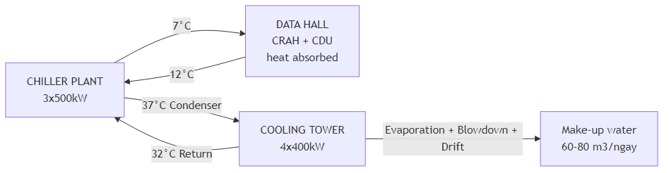

Diagram 48

#### L.2.5.2. Zone 1 — Colocation Cooling

| Thông số | Giá trị | Nhãn |
| --- | --- | --- |
| Cooling Type | Chilled Water In-Row CRAH + Rear-Door Heat Exchanger | [A] |
| In-Row CRAH units | 6 × 80 kW per row (N+1) — Phase 1: 12 units | [A] |
| Supply Air Temp | 18°C ± 2°C | [B] |
| Return Air Temp | 35°C (HAC contained) | [B] |
| Airflow per CRAH | 5.500 m³/h | [B] |
| Chilled Water Supply | 7°C (ΔT = 5°C) | [B] |
| Rear-Door HEX | Passive, chilled water — supplements 30% cooling per rack | [A] |
| Redundancy | N+1 per row | [C] |

#### L.2.5.3. Zone 2 — AI/HPC Liquid Cooling

| Thông số | Giá trị | Nhãn |
| --- | --- | --- |
| Cooling Type | Direct-to-Chip Liquid Cooling (CDU-based) + Rear-Door HEX | [A] |
| CDU (Coolant Distribution Unit) | 2 × 250 kW per row (N+1) — Phase 1: 4 CDU | [A] |
| Chip-level coolant | Propylene glycol 30%, inlet 30°C, outlet 45°C | [B] |
| CDU to Chiller loop | Chilled water 12°C → CDU heat exchanger → return 22°C | [A] |
| Rear-Door HEX | Active (pumped) — handles residual air-cooled heat (20%) | [A] |
| Quick-disconnect manifold | Per rack, drip-free, for hot-swap maintenance | [B] |
| Leak detection | Rope-type sensor under every rack row + CDU area | [C] |

*Lợi ích Liquid Cooling: Giảm 60-70% lượng không khí cần làm lạnh → PUE cải thiện 0,15-0,20 so với air-cooled thuần túy. Đây là yêu cầu bắt buộc cho GPU rack >40 kW [B].*

#### L.2.5.4. Chiller Plant

| Thông số | Giá trị | Nhãn |
| --- | --- | --- |
| Chiller Type | Water-cooled screw chiller | [A] |
| Capacity | 3 × 500 kW (N+1) — Phase 1: 2 units | [A] |
| COP (Coefficient of Performance) | ≥5,5 (full load), ≥6,0 (IPLV) | [B] |
| Refrigerant | R-515B (low-GWP) hoặc R-1234ze | [B] |
| Chilled Water | Supply 7°C / Return 12°C (ΔT = 5°C) | [B] |
| Condenser Water | Supply 32°C / Return 37°C | [B] |
| VFD | Trên tất cả compressor + pump | [A] |
| Control | BMS integration, demand-based staging | [A] |

#### L.2.5.5. Cooling Tower

| Thông số | Giá trị | Nhãn |
| --- | --- | --- |
| Type | Counter-flow evaporative (FRP housing) | [A] |
| Capacity | 4 × 400 kW (N+1) — Phase 1: 3 cells | [A] |
| Approach temperature | 5°C (wet bulb TPHCM ~27°C → CW 32°C) | [B] |
| Water make-up | 60-80 m³/ngày sau hybrid cooling | [C] |
| Drift eliminator | ≤0,001% (low-drift design) | [B] |
| Cycles of concentration | 5-7 (water treatment optimized) | [A] |
| Water treatment | Auto-dosing: Biocide + Anti-scale + pH control | [A] |
| Noise | 85 dB(A) at 1m, 52-58 dB(A) at boundary | [C] |

#### L.2.5.6. Free Cooling Economizer

| Thông số | Giá trị | Nhãn |
| --- | --- | --- |
| Mode | Waterside economizer (plate heat exchanger) | [A] |
| Activation | Khi T_outdoor_wetbulb < 18°C | [A] |
| Số giờ khả dụng | ~700-1.000 h/năm (TPHCM) — ~8-11% thời gian | [B] |
| Tiết kiệm điện chiller | ~8% annual chiller energy | [A] |
| Partial free cooling | Khi T_wb 18-24°C → Chiller chạy bổ sung, COP tăng | [A] |
| Tổng giờ partial + full | ~2.500 h/năm (~29% thời gian) | [B] |

#### L.2.5.7. Tính toán PUE

| Thành phần | Load (kW) Phase 2 Full | % IT Load | Ghi chú |
| --- | --- | --- | --- |
| IT Load | 3.000 | 100,0% | Base |
| Cooling (Chiller + CT + Pump) | 600 | 20,0% | COP 5,5 + VFD + free cooling credit |
| UPS Loss | 120 | 4,0% | Efficiency 96% (double conversion) |
| Lighting + Misc | 45 | 1,5% | LED + BMS |
| PDU Loss | 60 | 2,0% | Transformer loss |
| Liquid Cooling Pump (Zone 2) | 90 | 3,0% | CDU pumps |
| Building HVAC (non-IT) | 30 | 1,0% | Office, NOC |
| Security + Fire | 15 | 0,5% | CCTV, VESDA, v.v. |
| **Total Facility** | **3.960** |  |  |
| **PUE** |  |  | **3.960 / 3.000 = 1,32** |

*PUE 1,32 đạt target <1,35 [A]. Yếu tố chính: Liquid cooling Zone 2 (giảm 25%), VFD tất cả pump/fan, free cooling ~8%, UPS 96%.*

### L.2.6. Electrical Architecture — 2N Distribution

#### L.2.6.1. Power Path Design

[figure not shown]

Diagram 49

#### L.2.6.2. UPS Specifications

| Thông số | Giá trị | Nhãn |
| --- | --- | --- |
| Configuration | 2N (2 × (2 × 1.000 kVA parallel)) | [A] |
| UPS Type | Online Double Conversion (VFI-SS-111) | [B] |
| Input | 3-phase 400V, 50Hz | [C] |
| Output | 3-phase 400V, 50Hz, THD ≤3% | [B] |
| Efficiency | ≥96% (double conversion), ≥99% (eco mode — NOT for DC) | [B] |
| Battery Type | LiFePO4 (Lithium Iron Phosphate) | [A] |
| Battery Runtime | 15 phút @ full load (per UPS path) | [C] |
| Battery Life | 15+ năm (vs 5-7 năm VRLA) | [B] |
| Battery Footprint | ~60% smaller than equivalent VRLA | [B] |
| Monitoring | Per-cell BMS, temperature + voltage + SOC | [B] |
| Bypass | Static bypass + Manual maintenance bypass | [C] |

*Chi phí UPS: 4 × 1.000 kVA UPS = ~800.000 USD [B]. LiFePO4 battery = ~400.000 USD [B]. Tổng UPS system ~1.200.000 USD.*

#### L.2.6.3. PDU Specifications

| Thông số | Giá trị | Nhãn |
| --- | --- | --- |
| Type | Rack-mount, Intelligent Metered + Switched | [A] |
| Input | 3-phase 63A (Colo) / 125A (AI/HPC) | [A] |
| Outlets per PDU | 24 × C13 + 12 × C19 (Colo), 12 × C19 + 6 × 3-phase (AI) | [B] |
| Per-outlet metering | Voltage, Current, Power, Energy (kWh) | [A] |
| Remote switching | Per outlet, SNMP/SSH/Web | [A] |
| Dual PDU per rack | PDU-A (Path A) + PDU-B (Path B) | [C] |
| Environmental sensors | Temperature + Humidity per PDU | [A] |

### L.2.7. Physical Security Chi tiết

| Layer | Giải pháp | Tiêu chuẩn | Nhãn |
| --- | --- | --- | --- |
| Perimeter | Hàng rào 2,4m + CCTV PTZ (4 vị trí) | EN 50131-1 | [A] |
| Building entry | Card access (Kaba/HID) + Guard 24/7 | — | [A] |
| Data Hall entry | Mantrap (2 cửa interlocked) + Biometric (fingerprint + iris) | TIA-942 | [A] |
| Rack access | Electronic rack lock + audit trail | ISO 27001 | [A] |
| CCTV | 32 camera (IP, 4K, 90-day retention) | — | [A] |
| Intrusion detection | PIR sensors + door contacts — all sensitive areas | EN 50131 | [A] |
| Visitor management | Badge system + escort required in Data Hall | ISO 27001 | [A] |

## L.3. Khối B — Nhà máy CNC Chi tiết (800 m²)

### L.3.1. Thông số Thiết kế Tổng quát

[output not shown]

### L.3.2. Machine Shop Layout (25 Vị trí — Full Build-out Reference)

[figure not shown]

Diagram 50

### L.3.3. Khoảng cách An toàn

| Yếu tố | Khoảng cách | Tiêu chuẩn | Nhãn |
| --- | --- | --- | --- |
| Máy — Máy (cùng hàng) | ≥2,5 m | OSHA 1910 | [B] |
| Máy — Tường | ≥1,5 m | OSHA 1910 | [B] |
| Hàng — Hàng (qua crane track) | ≥3,5 m | Crane clearance | [A] |
| Đường đi chính | ≥3,0 m | Fork lift access | [B] |
| Đường đi phụ | ≥1,2 m | Personnel access | [B] |

### L.3.4. Hệ thống Cách ly Rung Chi tiết

#### L.3.4.2. Giải pháp Cách ly 3 Cấp

| Cấp | Mô tả | Giảm rung lũy kế | Chi phí |
| --- | --- | --- | --- |
| **Cấp 1** | Inertia block (bệ bê tông 300-500mm, 2× trọng lượng máy) | 50% → 0,62 mm/s | 125.000 USD (25 bệ) |
| **Cấp 2** | Spring isolator Gerb/Bilz + rubber pad Sylomer SR-55 | 90% → 0,062 mm/s | 250.000 USD (25 bộ) |
| **Cấp 3** | Isolation trench 2m × 1m × 60m giữa Khối A và B | 80% → 0,012 mm/s | 120.000 USD |
| **Kết quả** | Tại Khối A (25m away), suy giảm thêm 60% | → ~0,005 mm/s |  |
| **Target** | v < 0,1 mm/s tại Khối A | **ĐẠT — dư 20×** |  |

*Tổng chi phí cách ly rung: ~520.000 USD [C]*

#### L.3.4.3. Thiết bị Cách ly Chi tiết

| Loại thiết bị | Nhà sản xuất | Model | Hiệu quả | Giá (USD/bộ) | Nhãn |
| --- | --- | --- | --- | --- | --- |
| Spring Isolator | Gerb (Đức) | GSA-350 | 85-95% | 8.000-12.000 | [B] |
| Rubber Pad | Getzner (Áo) | Sylomer SR-55 | 60-80% (bổ trợ) | 1.500-2.500 | [B] |
| Vibration Sensor | PCB Piezotronics | 393B04 | Monitor realtime | 5.000/bộ 3 sensor | [A] |

### L.3.5. Hệ thống Chip Conveyor

| Thông số | Giá trị | Nhãn |
| --- | --- | --- |
| Type | Magnetic + Auger conveyor (ngầm dưới nền) | [A] |
| Channel size | 300W × 250H mm (bê tông hoặc SS316) | [A] |
| Tốc độ chip removal | ≥0,5 m/s | [B] |
| Capacity | ~500 kg/h (đủ cho 25 máy, ~20 kg chip/máy/h) | [A] |
| Central collection | 1 bể thu chip 5 m³ (chip sắt, nhôm, inox — tách riêng) | [A] |
| Coolant separator | Tách coolant khỏi chip, tái sử dụng coolant | [A] |
| Class D fire risk | Chip Ti, Mg → KHÔNG dùng nước, dùng D-class extinguisher | [C] |

*Chi phí Chip Conveyor: ~85.000 USD [A]*

### L.3.6. Hệ thống Khí nén

| Thông số | Giá trị | Nhãn |
| --- | --- | --- |
| Áp suất công tác | 8 bar (tại điểm sử dụng) | [C] |
| Áp suất đầu nén | 10 bar (trước dryer + filter) | [A] |
| Loại máy nén | Oil-free scroll/screw (Class 0 theo ISO 8573-1) | [C] |
| Số lượng | 3 × 55 kW (N+1) — Phase 1: 2 units | [A] |
| Lưu lượng mỗi máy | ~8,5 m³/min @ 10 bar | [B] |
| Air Receiver | 2 × 3.000 L (tổng 6.000 L) | [B] |
| Dryer | 2 × Refrigerant dryer + 1 × Desiccant dryer (CMM room) | [A] |
| Dew point | ≤-20°C (general), ≤-40°C (CMM room) | [B] |
| Filtration | 3-stage: Particulate (1µm) → Coalescing (0,01µm) → Carbon | [B] |
| Distribution | Ring main (loop) — SS316 pipe, DN50 | [A] |

*Chi phí Compressed Air: ~195.000 USD [A]*

### L.3.7. Hệ thống Coolant Trung tâm

| Thông số | Giá trị | Nhãn |
| --- | --- | --- |
| Type | Central coolant supply system (vs distributed per-machine) | [A] |
| Central tank | 10.000 L (insulated stainless steel) + mixing | [A] |
| Coolant type | Water-soluble semi-synthetic (5-8% concentration) | [B] |
| Flow | Loop: Central tank → Pump → Per-machine manifold → Return → Filter → Tank | — |
| Filtration | Paper band filter (20µm) + Magnetic separator + Oil skimmer | [B] |
| Temperature | 20 ± 2°C (controlled — prevent thermal drift) | [B] |
| Coolant life | 6-12 tháng (với proper maintenance) → ZLD xử lý spent coolant | [B] |
| Monitoring | Concentration (refractometer), pH, bacteria (dipslide) | [B] |

*Lợi ích: Tiết kiệm 30% coolant, kiểm soát chất lượng tập trung, dễ ZLD.* *Chi phí Central Coolant: ~65.000 USD [A]*

### L.3.8. Cầu trục Overhead

| Thông số | Giá trị | Nhãn |
| --- | --- | --- |
| Type | EOT (Electric Overhead Travelling) — Double Girder | [A] |
| Capacity | 5 tấn (SWL) | [B] |
| Span | 20 m (qua 2 hàng máy chính) | [A] |
| Travelling length | 50 m (toàn Machine Shop) | [A] |
| Hook height | 9 m | [A] |
| Hoist speed | 0,5-5 m/min (variable) | [B] |
| Travel speed | 5-20 m/min (variable) | [B] |
| Control | Pendant + Radio remote | [A] |
| Safety | Overload protection, anti-collision, limit switches, warning beacon | [C] |

*Chi phí Crane 5T × 50m: ~95.000 USD [B]*

### L.3.9. Phòng Đo lường CMM (200 m²)

| Thông số | Giá trị | Tiêu chuẩn | Nhãn |
| --- | --- | --- | --- |
| Diện tích | 200 m² | — | [A] |
| Clean Room Class | ISO 8, mục tiêu Class 1.000 cục bộ | ISO 14644-1 | [A] |
| Temperature | 20,0 ± 0,5°C (precision metrology) | ISO 1:2016 | [C] |
| Humidity | 45 ± 10% RH | — | [B] |
| Vibration | <0,05 mm/s (stricter than DC — VC-D criteria) | IEST-RP-CC012 | [C] |
| Foundation | Separate isolated slab 400mm, 4 spring mount | — | [A] |
| Wall | Cách âm STC 50 (double gypsum + insulation) | — | [A] |
| Airlock | 1 airlock entry (phòng đệm thay đồ) | — | [A] |
| HVAC | Dedicated CRAH, 100% recirculation | — | [A] |
| CMM equipment | 1 × Bridge CMM (Zeiss/Hexagon), 1 × Vision System | — | [A] |
| ESD flooring | Conductive vinyl, <10⁶ Ω | IEC 61340 | [B] |

*Chi phí CMM Room: ~180.000 USD [A]*

### L.3.10. HVAC Khối B

| Hệ thống | Khu vực | Thiết kế | Nhãn |
| --- | --- | --- | --- |
| LEV (Local Exhaust Ventilation) | Mỗi CNC machine | Hood → Ducting → Cyclone → HEPA → Exhaust | [A] |
| LEV flow rate | 1.500-2.000 m³/h per machine | — | [B] |
| Total LEV exhaust | ~37.500 m³/h (25 machines) | — | [A] |
| Make-up Air | Machine Shop | AHU filtered outside air, heated/cooled | [A] |
| Make-up air flow | ~40.000 m³/h (1,1× exhaust) | — | [A] |
| Temperature Control | Machine Shop | 20 ± 2°C — split type AC + AHU | [B] |
| AC capacity | 12 × 5TR split AC (tổng 60 TR ≈ 211 kW) | — | [A] |
| Mist collector | High-speed machining | Electrostatic, 10 units | [B] |

*Chi phí HVAC Khối B: ~320.000 USD [A]*

## L.4. Khối C — Nhà máy SMT Chi tiết (3.000 m²)

### L.4.1. Thông số Thiết kế

| Thông số | Giá trị | Nhãn |
| --- | --- | --- |
| Diện tích tổng | 3.000 m² | [C] |
| Chiều cao trần | 5 m | [A] |
| Tải điện Phase 1 | 400 kW | [A] |
| Tải điện Phase 2 | 800 kW | [A] |
| Clean Room area | 600 m² (ISO 7) | [A] |
| Robot Assembly area | 800 m² | [A] |
| Temperature (Clean Room) | 22 ± 2°C | [B] |
| Humidity (Clean Room) | 40-60% RH | [B] |
| ESD control | Toàn bộ production area | [C] |

### L.4.2. Clean Room ISO 7 (600 m²)

| Thông số | Giá trị | Tiêu chuẩn | Nhãn |
| --- | --- | --- | --- |
| ISO Class | ISO 7 (FED-STD Class 10.000) | ISO 14644-1 | [C] |
| Max particles ≥0,5µm | ≤352.000/m³ | ISO 14644-1 | [C] |
| Air changes per hour | 45 ACH (target) | ISO 14644-4 | [B] |
| FFU (Fan Filter Unit) | 120 units (600 × 600 mm, 0,35 m/s) | — | [A] |
| FFU coverage | ~70% ceiling area | — | [B] |
| Filter grade | HEPA H14 (99,995% @ 0,3µm) | EN 1822 | [C] |
| Pre-filter | G4 (coarse) + F9 (fine) trước AHU | EN 779 | [B] |
| Positive pressure | +12,5 Pa so với hành lang | ISO 14644-4 | [C] |
| Airlock | 2 airlocks (personnel + material) | ISO 14644-4 | [A] |
| Wall and ceiling | Sandwich panel (PIR core, 50mm) | — | [B] |
| Floor | ESD epoxy, seamless, <10⁶ Ω | IEC 61340-5-1 | [C] |

*Chi phí Clean Room ISO 7: ~450.000 USD [A]*

### L.4.3. SMT Production Line Layout

[figure not shown]

Diagram 51

| Thiết bị | Qty P1 | Qty P2 | Điện (kW) | Nhãn |
| --- | --- | --- | --- | --- |
| PCB Loader | 1 | 2 | 0,5 | [A] |
| Solder Paste Printer | 1 | 2 | 2 | [A] |
| SPI (Solder Paste Inspection) | 1 | 2 | 1 | [A] |
| Chip Mounter (High-speed) | 1 | 2 | 5 | [A] |
| Chip Mounter (Flexible) | 1 | 2 | 5 | [A] |
| Reflow Oven (10-zone) | 1 | 2 | 25 | [A] |
| AOI (Optical Inspection) | 1 | 2 | 2 | [A] |
| PCB Unloader | 1 | 2 | 0,5 | [A] |
| **Total per line** |  |  | **~41 kW** |  |

### L.4.4. IPA Storage Room (ATEX Zone)

| Thông số | Giá trị | Tiêu chuẩn | Nhãn |
| --- | --- | --- | --- |
| Chemical | IPA (Isopropyl Alcohol), flash point 12°C | — | [C] |
| Storage | 200 L drums × 10 = 2.000 L max | — | [A] |
| ATEX Classification | Zone 1 (trong phòng), Zone 2 (1m ngoài cửa) | IEC 60079-10-1 | [C] |
| Room size | 50 m² (tách biệt, tường REI 120) | QCVN 06:2022 | [C] |
| Ventilation | ≥15 ACH (continuous, explosion-proof fan) | IEC 60079-14 | [C] |
| LEL monitoring | 2 sensors, alarm 20% LEL, shutdown 40% LEL | IEC 60079-29-1 | [C] |
| Electrical | ALL Ex-rated: Ex d lighting + switches + fan | IEC 60079-1 | [C] |
| Spill containment | Bund wall 150mm, capacity ≥110% largest container | TCVN 5507:2002 | [C] |
| Fire suppression | FM-200 gas (NO water) | — | [C] |

### L.4.5. Robot Assembly Area (800 m²)

| Thông số | Giá trị | Nhãn |
| --- | --- | --- |
| Robot cells | 6 cells Phase 1, 12 cells Phase 2 | [A] |
| Robot type | SCARA (4-axis) + 6-axis articulated | [A] |
| Safety cage | Light curtain (Type 4, SIL 3) + Safety fence 1.4m | [C] |
| Emergency stop | Per cell (Category 0) + Area E-stop (Category 1) | [C] |
| Vision system | 1 per cell (camera + lighting for inspection) | [A] |
| Conveyor | Modular belt, speed 0,5-3 m/min | [A] |

### L.4.6. ESD Control (Toàn Khối C)

| Thành phần | Giải pháp | Tiêu chuẩn | Nhãn |
| --- | --- | --- | --- |
| Flooring | ESD epoxy (10⁵-10⁹ Ω) | IEC 61340-5-1 | [C] |
| Grounding | Wrist strap + table mat per workstation | IEC 61340-5-1 | [C] |
| Wrist strap | Single-wire with 1MΩ resistor + continuous monitor | IEC 61340-5-1 | [C] |
| Ionizer | Overhead ionizer bar each workstation | IEC 61340-5-1 | [B] |
| Humidity | ≥40% RH (AHU humidifier) | IPC-A-610 | [C] |
| Packaging | ESD shielding bags (pink poly + metallized) | ANSI/ESD S541 | [B] |
| Personal grounding | ESD shoes/heel strap + periodic tester | IEC 61340-5-1 | [B] |
| Audit | Weekly ESD audit | ANSI/ESD S20.20 | [A] |

*Chi phí ESD toàn Khối C: ~45.000 USD [A]*

## L.5. Hệ thống Điện Tổng hợp

### L.5.1. Sơ đồ Một Dây (Single Line Diagram)

[figure not shown]

Diagram 52

### L.5.2. Transformer Specifications

| Thông số | TX-1 | TX-2 | Nhãn |
| --- | --- | --- | --- |
| Capacity | 2.500 kVA | 2.500 kVA | [A] |
| Primary | 22 kV, 3-phase | 22 kV | [C] |
| Secondary | 400V, 3-phase, 50Hz | 400V | [C] |
| Vector group | Dyn11 | Dyn11 | [B] |
| Impedance | 6% | 6% | [B] |
| Cooling | ONAN | ONAN | [B] |
| Tap changer | ± 2 × 2,5% OLTC | OLTC | [A] |
| Efficiency | ≥99,0% at 75% load | — | [B] |
| Protection | Buchholz relay + OTI + WTI + Pressure relief | IEC 60076 | [B] |

*Chi phí 2 × TX 2.500 kVA: ~280.000 USD [B]*

### L.5.3. Load Summary

| Khối | Phase 1 (kW) | Phase 2 (kW) | PF | kVA (P2) | % |
| --- | --- | --- | --- | --- | --- |
| Khối A (DC) | 2.025 | 4.050 | 0,95 | 4.263 | 60% |
| Khối B (CNC) | 700 | 1.600 | 0,85 | 1.882 | 27% |
| Khối C (SMT) | 400 | 800 | 0,90 | 889 | 13% |
| Chung | 150 | 250 | 0,85 | 294 | 4% |
| **TỔNG** | **3.275** | **6.700** | **0,92** | **7.328** | 100% |
| Diversity (0,8) | 2.620 | 5.360 | — | 5.826 |  |
| TX Capacity | — | — | — | 5.000 |  |

### L.5.4. Generator Farm

| Generator | Công suất | Phục vụ | Nhãn |
| --- | --- | --- | --- |
| GEN-1 (DC Primary) | 2.500 kVA / 2.000 kW | Khối A — Path A | [A] |
| GEN-2 (DC Backup) | 2.500 kVA / 2.000 kW | Khối A — Path B (N+1) | [A] |
| GEN-3 (Factory) | 1.000 kVA / 800 kW | Khối B + C + Chung | [A] |

#### Generator Specifications

| Thông số | GEN-1 and GEN-2 | GEN-3 | Nhãn |
| --- | --- | --- | --- |
| Rating | 2.500 kVA (Standby) | 1.000 kVA (Standby) | [A] |
| Engine | MTU/Cummins QSK60 | Cummins QST30 | [B] |
| Start time | ≤10 seconds (Tier III) | ≤15 seconds | [C] |
| Transfer time | ≤10 seconds via ATS | ≤12 seconds via ATS | [C] |
| Runtime @ full load | 24h (on-site fuel) | 48h (on-site fuel) | [A] |
| Noise | 95 dB(A) @1m (with attenuator: 75 dB(A)) | 90 dB(A) @1m | [B] |
| Emission | Tier 4 Final / Stage V (SCR + DPF) | Tier 4 Final | [C] |

#### Fuel Storage

| Bồn | Dung tích (L) | Runtime (h) | Nhãn |
| --- | --- | --- | --- |
| Fuel Tank DC-1 | 10.000 | 24h @ full load GEN-1 | [A] |
| Fuel Tank DC-2 | 10.000 | 24h @ full load GEN-2 | [A] |
| Fuel Tank Factory | 5.000 | 48h @ full load GEN-3 | [A] |
| Day Tank (DC) | 2 × 1.000 | 4-5h per Gen | [B] |

*Chi phí Generator Farm: GEN-1+2 ~900K, GEN-3 ~180K, Fuel ~45K, ATS ~60K = Tổng ~1.185.000 USD*

### L.5.5. Solar PV 500 kWp

| Thông số | Giá trị | Nhãn |
| --- | --- | --- |
| Capacity | 500 kWp (DC) | [C] |
| Location | Mái Khối B + Khối C (~3.000 m²) | [A] |
| Panel type | Bi-facial monocrystalline 550Wp | [B] |
| Number of panels | ~910 panels | [A] |
| Inverter | 5 × 100 kW string inverter | [A] |
| Connection | Behind-the-meter (self-consumption) | [C] |
| Annual generation | 700-750 MWh/năm | [B] |
| Self-consumption ratio | ~95% | [A] |
| Net savings | ~54.500 USD/năm | [A] |
| Payback | ~9,2 năm | [A] |

### L.5.6. Lightning and Grounding

| Thông số | Giá trị | Nhãn |
| --- | --- | --- |
| System | ESE (Early Streamer Emission), 2 rods | [A] |
| Protection radius | 80-100 m per rod (level III) | [B] |
| Earth resistance | ≤10 Ohm (lightning), ≤1 Ohm (DC grounding) | [C] |
| Grounding system | TN-S (neutral and PE separate) | [C] |
| SPD | Type 1+2+3 cascade MDB → Sub-MDB → PDU | [B] |

*Chi phí Lightning + Grounding: ~85.000 USD [A]*

## L.6. Hệ thống Nước Chi tiết

### L.6.1. Cấp nước

| Thông số | Giá trị | Nhãn |
| --- | --- | --- |
| Nguồn | Hệ thống KCNC TP.HCM | [C] |
| Đấu nối | DN100 (4”) | [C] |
| Áp lực | 2-3 bar (mạng KCNC) | [B] |
| Quota | 150 m³/ngày (cần đề xuất 200 m³/ngày) | [C] |
| Bể chứa | 100 m³ | [A] |
| Bơm tăng áp | 2 × 15 m³/h (duty/standby) + jockey | [A] |

### L.6.2. Cooling Water Loop (DC)

[figure not shown]

Diagram 53

### L.6.3. Water Balance

[figure not shown]

Diagram 54

### L.6.4. Water Conservation Measures

| Biện pháp | Tiết kiệm | Chi phí | Nhãn |
| --- | --- | --- | --- |
| Hybrid cooling (liquid + air backup) | 40% nước CT | Included CAPEX DC | [A] |
| High cycles of concentration (5-7) | 20% vs CoC 3 | 15.000 USD | [A] |
| Blowdown water reuse | 10% recovery | 5.000 USD | [A] |
| Rainwater harvesting (P2) | 10-20 m³/ngày mùa mưa | 25.000 USD | [A] |
| **Tổng tiết kiệm** | **~55-60%** vs baseline |  |  |

## L.7. BOQ M&E Tổng hợp Chi tiết

### L.7.1. Hệ thống Điện

[output not shown]

### L.7.2. Hệ thống Cooling (DC)

[output not shown]

### L.7.3. Hệ thống HVAC (CNC + SMT)

| TT | Hạng mục | SL | ĐG (USD) | Tổng (USD) | Phase | Nhãn |
| --- | --- | --- | --- | --- | --- | --- |
| 1 | LEV System CNC | 1 lot | — | 120.000 | P1+P2 | [A] |
| 2 | AHU Make-up Air CNC | 1 | 45.000 | 45.000 | P1 | [A] |
| 3 | Split AC CNC (12 × 5TR) | 12 | 5.000 | 60.000 | P1:8, P2:4 | [A] |
| 4 | Mist Collector (10 units) | 10 | 4.500 | 45.000 | P1:6, P2:4 | [A] |
| 5 | Ducting CNC | 1 lot | — | 50.000 | P1+P2 | [A] |
| 6 | Clean Room ISO 7 (600 m²) | 1 lot | — | 350.000 | P1 | [A] |
| 7 | AHU Clean Room (2 × 25.000 m³/h) | 2 | 35.000 | 70.000 | P1 | [A] |
| 8 | Air-cooled Chiller SMT | 1 | 55.000 | 55.000 | P1 | [A] |
| 9 | Steam Humidifier | 2 | 8.000 | 16.000 | P1 | [A] |
| 10 | Reflow LEV + Carbon | 2 | 15.000 | 30.000 | P1:1, P2:1 | [A] |
|  | **SUBTOTAL HVAC** |  |  | **841.000** |  |  |

### L.7.4. Hệ thống CNC Chuyên dụng

| TT | Hạng mục | SL | ĐG (USD) | Tổng (USD) | Nhãn |
| --- | --- | --- | --- | --- | --- |
| 1 | Vibration Isolation (25 sets) | 25 | 15.000 | 375.000 | [B] |
| 2 | Isolation Trench (60m) | 1 | 120.000 | 120.000 | [A] |
| 3 | Vibration Sensors | 3 | 5.000 | 15.000 | [A] |
| 4 | Chip Conveyor Underground | 1 lot | — | 85.000 | [A] |
| 5 | Compressed Air System | 1 lot | — | 195.000 | [A] |
| 6 | Central Coolant System | 1 lot | — | 65.000 | [A] |
| 7 | Overhead Crane 5T × 50m | 1 | 95.000 | 95.000 | [B] |
| 8 | CMM Room | 1 lot | — | 180.000 | [A] |
|  | **SUBTOTAL CNC** |  |  | **1.130.000** |  |

### L.7.5. Hệ thống Nước

| TT | Hạng mục | Tổng (USD) | Nhãn |
| --- | --- | --- | --- |
| 1 | Bể nước sạch 100 m³ | 25.000 | [A] |
| 2 | Bơm tăng áp (3 bơm) | 10.500 | [A] |
| 3 | Đường ống cấp nước | 35.000 | [A] |
| 4 | Water Treatment CT | 35.000 | [A] |
| 5 | Đường ống thoát nước | 45.000 | [A] |
| 6 | Bể tự hoại 3 ngăn | 8.000 | [A] |
| 7 | XLNT chung (40 m³/ngày) | 250.000 | [C] |
| 8 | ZLD System CNC | 450.000 | [C] |
| 9 | Rainwater harvesting (P2) | 25.000 | [A] |
|  | **SUBTOTAL NƯỚC** | **883.500** |  |

### L.7.6. Hạ tầng Khác

| TT | Hạng mục | Tổng (USD) | Nhãn |
| --- | --- | --- | --- |
| 1 | Raised Floor (1.500 m²) | 300.000 | [B] |
| 2 | ESD Flooring Khối C | 45.000 | [A] |
| 3 | Physical Security DC | 120.000 | [A] |
| 4 | IPA Storage Room ATEX | 35.000 | [A] |
| 5 | ESD Control System | 45.000 | [A] |
| 6 | Robot Safety System (12 cells) | 60.000 | [A] |
|  | **SUBTOTAL KHÁC** | **605.000** |  |

### L.7.7. Tổng hợp BOQ M&E

[output not shown]

## L.8. Timeline Thi công M&E

### L.8.1. Long-Lead Items

| Item | Lead Time | Order By | Delivery | Critical? |
| --- | --- | --- | --- | --- |
| Water-cooled Chiller 500kW | 16-20 tuần | Q1/2025 | Q2/2025 | **CÓ** |
| Transformer 2.500 kVA | 12-16 tuần | Q1/2025 | Q2/2025 | **CÓ** |
| Generator 2.500 kVA | 14-18 tuần | Q1/2025 | Q2/2025 | **CÓ** |
| UPS 1.000 kVA + LiFePO4 | 16-22 tuần | Q1/2025 | Q3/2025 | **CÓ** |
| CNC Machines DMG MORI | 24-30 tuần | Q4/2024 | Q2/2025 | **CÓ** |
| CDU Liquid Cooling | 12-16 tuần | Q2/2025 | Q3/2025 | TB |
| Cooling Tower | 10-14 tuần | Q2/2025 | Q3/2025 | TB |
| Spring Isolators Gerb/Bilz | 12-16 tuần | Q2/2025 | Q3/2025 | TB |
| FFU (120 units) | 8-10 tuần | Q3/2025 | Q4/2025 | Không |

*CNC machines lead time 24-30 tuần → PO phải ký Q4/2024, trước khi dự án chính thức khởi công.*

### L.8.2. Commissioning Sequence

| Bước | Hệ thống | Duration | Nhãn |
| --- | --- | --- | --- |
| 1 | Điện — TX, MDB, ATS, Gen energize | 2 tuần | [A] |
| 2 | UPS — commissioning, battery charge, load bank test | 2 tuần | [A] |
| 3 | Nước — Tank fill, pump test, piping flush | 1 tuần | [A] |
| 4 | Cooling — Chiller start, CT Commission, piping balance | 3 tuần | [A] |
| 5 | HVAC — AHU start, Clean Room particle count | 2 tuần | [A] |
| 6 | CNC Specific — Air, Coolant, Crane load test | 2 tuần | [A] |
| 7 | IT Infrastructure — Raised floor, Cable, Rack, PDU | 4 tuần | [A] |
| 8 | BMS Integration — All sensors → BMS, alarm test | 2 tuần | [A] |
| 9 | PCCC — Nghiệm thu Cảnh sát PCCC | 4 tuần | [C] |
| 10 | Soak Test — 72h continuous under load | 1 tuần | [A] |
| 11 | Handover — Documentation, training, warranty | 1 tuần | [A] |

*Tổng commissioning Phase 1: ~14-16 tuần (3,5-4 tháng).*

# PHỤ LỤC M: PHÂN TÍCH THỊ TRƯỜNG CNC CHI TIẾT

## M.1. Quy mô Thị trường CNC Outsourcing

### M.1.1. Thị trường Toàn cầu

| Chỉ tiêu | 2024 | 2025 (E) | 2030 (F) | CAGR |
| --- | --- | --- | --- | --- |
| CNC machining toàn cầu (tỷ USD) | 97,2 | 103,5 | 152,8 | 6,7% |
| Precision machining (tỷ USD) | 28,4 | 30,6 | 48,2 | 7,9% |
| 5-axis machining (tỷ USD) | 8,1 | 8,9 | 15,3 | 9,4% |
| Outsourcing/Contract mfg (tỷ USD) | 41,5 | 44,8 | 72,6 | 8,4% |

*Nguồn: Grand View Research 2024, MarketsandMarkets 2024, Mordor Intelligence [B]*

### M.1.2. Thị trường Đông Nam Á

| Quốc gia | Quy mô 2024 (M USD) | CAGR | Đặc điểm |
| --- | --- | --- | --- |
| Thái Lan | 4.200 | 6,5% | Automotive hub, 700+ xưởng CNC |
| Malaysia | 2.800 | 7,2% | Aerospace and Electronics |
| **Việt Nam** | **1.850** | **9,8%** | **Tăng trưởng nhanh nhất, thiếu năng lực** |
| Indonesia | 1.650 | 6,8% | Nội địa hóa ô tô |
| Philippines | 680 | 7,5% | Electronics backend |
| Singapore | 1.200 | 3,2% | High-end, đắt đỏ |
| **Tổng ASEAN** | **~12.380** | **7,1%** |  |

### M.1.3. Thị trường Việt Nam theo Phân khúc

| Phân khúc | 2024 (M USD) | 2030 (F) | CAGR | Ghi chú |
| --- | --- | --- | --- | --- |
| Automotive and EV | 520 | 1.150 | 14,2% | VinFast, Toyota, Honda supply chain |
| Electronics and Semiconductor | 480 | 980 | 12,6% | Samsung, Intel, LG, Foxconn |
| General Industrial | 380 | 580 | 7,3% | Khuôn mẫu, linh kiện máy |
| Aerospace and Defense | 85 | 280 | 22,0% | Segment MỚI, tăng trưởng mạnh nhất |
| Medical Devices | 65 | 185 | 19,1% | Medtronic, Abbott supply chain |
| Energy and Oil/Gas | 180 | 340 | 11,2% | Turbine, valve, fitting |
| Robotics and Automation | 140 | 350 | 16,5% | Nhu cầu nội bộ |
| **Tổng** | **1.850** | **3.865** | **13,1%** |  |

## M.2. Nhu cầu CNC từ FDI Miền Nam

### M.2.1. Bản đồ Chi tiêu CNC

| Tập đoàn FDI | Cơ sở tại VN | Nhu cầu CNC chính | Dung sai yêu cầu | Chi tiêu/năm (M USD) |
| --- | --- | --- | --- | --- |
| Samsung Vietnam | SEVT, SEHC | Khuôn mẫu, jig/fixture, die casting inserts | ±0,02 mm | 80-120 |
| Intel Products VN | SHTP | Heat sink, test socket, cleanroom parts | ±0,01 mm | 40-60 |
| Bosch Vietnam | Long Thành, SHTP | ECU housing, sensor brackets, mold inserts | ±0,015 mm | 35-50 |
| Nidec Vietnam | Tân Bình, Biên Hòa | Motor housing, rotor shaft, stator tooling | ±0,005 mm | 25-40 |
| VinFast | Hải Phòng + HCM | EV battery tray, chassis brackets, motor mount | ±0,05 mm | 50-80 |
| Toyota/Honda VN | Vĩnh Phúc, Đồng Nai | Transmission case, engine bracket, A/C parts | ±0,02 mm | 30-45 |
| TTI/TE Connectivity | Bình Dương | Connector mold inserts, stamping die, precision pins | ±0,005 mm | 15-25 |
| Jabil/Flex | SHTP, Bình Dương | PCB test jig, assembly fixture, end-effector | ±0,02 mm | 20-35 |

**Tổng chi tiêu CNC outsourcing ước tính từ top FDI miền Nam: 295-455M USD/năm [B]**

## M.3. Cạnh tranh Chi tiết

### M.3.1. Top 10 Đối thủ

| TT | Công ty | Vị trí | Máy CNC | Chứng nhận | FDI chính | Điểm yếu |
| --- | --- | --- | --- | --- | --- | --- |
| 1 | Misumi VN (Nhật) | Bình Dương | 45 | ISO 9001 | Toyota, Honda | Chỉ Nhật, không AS/IATF |
| 2 | MTEX VN (Nhật) | Đồng Nai | 30 | ISO 9001 | Nidec, Panasonic | Nhỏ, micro-lot |
| 3 | Cosmos Engineering | Bình Dương | 50+ | ISO+IATF | Samsung, LG | Không 5-trục |
| 4 | TPR Vietnam (Nhật) | Long Thành | 35 | IATF | Toyota, Honda | Đóng kín |
| 5 | Saigon Precision | SHTP | 20 | ISO 9001 | Intel, Jabil | Nhỏ, thiếu vốn |
| 6 | VPIC Group | HP+HCM | 80+ | ISO+IATF | VinFast, Hyundai | CNC chỉ phụ |
| 7 | Hải Dương Precision | Bình Dương | 15 | ISO 9001 | Bosch | Nhỏ, 3 trục |
| 8 | Nam Á CNC | Bình Dương | 8 | ISO 9001 | Local | Rất nhỏ |
| 9 | Kyoei VN (Nhật) | Đồng Nai | 40 | ISO+IATF | Denso, Aisin | Đóng kín |
| 10 | HTMP (Đài Loan) | Bình Dương | 55 | ISO 9001 | Foxconn | Chỉ Đài Loan |

### M.3.2. Khoảng trống Thị trường

| Phân khúc | Số xưởng (MN) | Khoảng trống | Mekong? |
| --- | --- | --- | --- |
| General CNC (3-trục) | 500+ | Bão hòa | Không |
| Precision CNC (3+4 trục) | ~80 | Nhỏ | Không |
| **5-Axis Machining** | **~15** | **LỚN** | **Có** |
| **IATF 16949 Certified** | **~12 (FDI)** | **LỚN** | **Có** |
| **AS9100 Certified** | **0 (VN)** | **CỰC LỚN** | **Có** |
| ISO 13485 (Medical) | ~5 (FDI) | Lớn | Giai đoạn sau |
| Titan/Inconel Machining | ~3 | CỰC LỚN | Có |

## M.4. Pricing Benchmark

### M.4.1. Giá theo Giờ Máy

| Loại máy | Nhôm (USD/h) | Thép (USD/h) | Inox 316 (USD/h) | Titan (USD/h) |
| --- | --- | --- | --- | --- |
| CNC 3 trục (Turning) | 18-25 | 22-30 | 28-38 | N/A |
| CNC 3 trục (Milling) | 22-30 | 28-38 | 35-45 | N/A |
| CNC 4 trục | 30-40 | 38-48 | 45-58 | 55-70 |
| **CNC 5 trục (Standard)** | **45-60** | **55-72** | **65-85** | **80-120** |
| CNC 5 trục (High-precision) | 60-85 | 72-95 | 85-110 | 110-160 |
| Wire EDM | 25-35 | 30-40 | 35-50 | 40-55 |

### M.4.2. So sánh Khu vực

| Quốc gia | 5-trục Nhôm (USD/h) | 5-trục Titan (USD/h) | So với VN |
| --- | --- | --- | --- |
| Nhật Bản | 120-180 | 200-350 | +167% |
| Đài Loan | 80-120 | 150-250 | +78% |
| Hàn Quốc | 90-130 | 160-280 | +100% |
| Trung Quốc | 35-55 | 70-120 | -22% |
| Thái Lan | 40-60 | 80-130 | Ngang |
| **Việt Nam** | **45-60** | **80-120** | Baseline |
| Ấn Độ | 30-45 | 60-100 | -33% |

*VN rẻ hơn 40-50% so với Đài Loan/Hàn, cao hơn 20-30% so với TQ (bù IP safety + logistics).*

### M.4.3. Giá theo Chi tiết

| Loại chi tiết | Batch | Vật liệu | Giá/bộ (USD) | Thời gian |
| --- | --- | --- | --- | --- |
| Fixture plate (Jig) | 1-5 | AL 6061-T6 | 150-500 | 2-4 giờ |
| Sensor bracket | 100-500 | SUS304 | 8-25 | 15-40 phút |
| Heat sink | 50-200 | AL 6063 | 15-45 | 20-60 phút |
| Battery tray (EV) | 10-50 | AL 6082-T6 | 200-800 | 3-8 giờ |
| Turbine blade (Aero) | 5-20 | Titan Gr.5 | 500-3.000 | 4-15 giờ |
| Motor housing | 200-1.000 | ADC12 | 5-18 | 8-20 phút |
| Mold insert | 1-5 | SKD61 | 800-5.000 | 10-40 giờ |
| Semi test socket | 10-50 | BeCu + POM | 200-1.500 | 2-6 giờ |

## M.5. Lộ trình Chứng nhận

### M.5.1. IATF 16949 (Ô tô) — 18-24 tháng

| Phase | Tháng | Hoạt động | Chi phí (USD) |
| --- | --- | --- | --- |
| P0: Gap Analysis | T1-T2 | Tư vấn IATF đánh giá khoảng cách | 15.000-25.000 |
| P1: QMS Foundation | T2-T5 | Xây dựng ISO 9001 nền tảng | 20.000-30.000 |
| P2: Core Tools Training | T4-T7 | 5 Core Tools: APQP, PPAP, FMEA, MSA, SPC | 25.000-40.000 |
| P3: Process Development | T6-T10 | Control Plan, PFMEA cho mỗi process | 15.000-20.000 |
| P4: MSA and SPC | T8-T12 | Measurement System Analysis, SPC charts | 30.000-50.000 |
| P5: Internal Audits | T10-T14 | Đào tạo + thực hiện audit nội bộ IATF | 10.000-15.000 |
| P6: Trial Production | T12-T16 | Sản xuất thử 2-3 KH, PPAP packages Level 3 | 20.000-30.000 |
| P7: Pre-Assessment | T16-T18 | Đánh giá sơ bộ bởi CB | 8.000-12.000 |
| P8: Stage 1 Audit | T18-T20 | Document review | 12.000-18.000 |
| P9: Stage 2 Audit | T20-T22 | On-site certification | 18.000-25.000 |
| P10: Certification | T22-T24 | Nhận chứng chỉ IATF 16949 | — |
| **TỔNG** |  |  | **173.000-265.000** |

### M.5.2. AS9100 Rev D (Hàng không) — 24-30 tháng

| Phase | Tháng | Hoạt động | Chi phí (USD) |
| --- | --- | --- | --- |
| P0: Foundation | T1-T3 | Tư vấn AS chuyên ngành, gap analysis | 20.000-35.000 |
| P1: Special Process | T3-T8 | Nadcap-ready processes | 40.000-60.000 |
| P2: FOD Prevention | T4-T8 | NAS 412 program | 15.000-20.000 |
| P3: Configuration Mgmt | T6-T10 | AS6500 compliance | 10.000-15.000 |
| P4: FAI Process | T8-T14 | First Article Inspection AS9102 | 25.000-40.000 |
| P5: Risk Management | T10-T14 | Operational risk register | 10.000-15.000 |
| P6: Supplier Mgmt | T12-T16 | Material cert + incoming inspection | 15.000-20.000 |
| P7: Internal Audits | T14-T18 | AS9100 internal audit | 12.000-18.000 |
| P8: OASIS Registration | T16-T18 | Online Aerospace Supplier Info System | 3.000-5.000 |
| P9: Stage 1+2 Audit | T20-T26 | Certification audit | 25.000-40.000 |
| P10: AS9100 Certificate | T26-T30 | Chứng chỉ + OASIS listing | — |
| **TỔNG** |  |  | **175.000-268.000** |

## M.6. Chiến lược Tiếp cận Khách hàng

### M.6.1. Từ RFQ đến PO — Timeline

| Giai đoạn | Thời gian | Hoạt động |
| --- | --- | --- |
| 1. Supplier Discovery | T0 | OEM phát hiện qua KCNC referral, triển lãm, giới thiệu |
| 2. Supplier Qualification | T0-T3 | SAQ, kiểm tra chứng nhận |
| 3. Factory Audit | T3-T4 | SQE audit xưởng |
| 4. Sample RFQ | T4-T5 | Bản vẽ + spec 1-3 part number |
| 5. Sample Production | T5-T7 | 5-20 pcs, PPAP package |
| 6. Sample Approval | T7-T8 | OEM kiểm tra, feedback |
| 7. Trial Order | T8-T10 | 100-500 pcs |
| 8. Price Negotiation | T10-T11 | Giá dài hạn, MOQ, payment term |
| 9. First PO | T11-T12 | Purchase Order chính thức |
| 10. Ramp-up | T12-T18 | Tăng volume, thêm part numbers |

**Tổng: 10-18 tháng từ first contact đến first PO**

### M.6.2. Kênh Tiếp cận

| Kênh | Hiệu quả | Chi phí/năm (USD) |
| --- | --- | --- |
| KCNC referral network | Cao nhất | Miễn phí |
| MTA Vietnam (Triển lãm) | Cao | 15.000-25.000 |
| METALEX Vietnam | Cao | 12.000-20.000 |
| JETRO / KOTRA / VKBIA | Cao | 3.000-5.000 |
| Samsung 2nd Tier Program | Rất cao | Application |
| VinFast Supplier Development | Rất cao | Application |
| SIDEC (SHTP Dev Center) | Cao | Nominal |
| LinkedIn / B2B digital | Trung bình | 5.000-10.000 |

### M.6.3. Anchor Customers (Ưu tiên)

| Ưu tiên | Khách hàng | Lý do | Tiếp cận |
| --- | --- | --- | --- |
| 1 | Jabil/Flex (SHTP) | Cùng KCNC, SQ đơn giản | BQL KCNC + SIDEC |
| 2 | Intel Products VN | Cùng KCNC, prestige lớn | BQL KCNC + direct SQE |
| 3 | Bosch VN | Cần IATF supplier VN | VGBA |
| 4 | VinFast | Chủ động tuyển supplier | Supplier Dev Program |
| 5 | Samsung SEHC | Volume lớn nhất | Samsung 2nd Tier |

## M.7. Nhân sự CNC Chi tiết

### M.7.1. Tổ chức

[figure not shown]

Diagram 55

### M.7.2. Bảng Nhân sự Chi tiết

| Vị trí | SL | Lương (USD/tháng) | Yêu cầu | Nguồn tuyển |
| --- | --- | --- | --- | --- |
| Plant Manager | 1 | 2.400-4.000 | 10+ năm CNC, IATF/AS | Headhunt FDI |
| Engineering Manager | 1 | 1.600-2.400 | 8+ năm CAD/CAM, 5-axis | FDI/returnee |
| Production Manager | 1 | 1.400-2.000 | 8+ năm quản lý CNC | FDI transfer |
| Quality Manager | 1 | 1.600-2.400 | 8+ năm QA/QC, IATF Lead Auditor | FDI background |
| Sales/BD Manager | 1 | 1.400-2.000 | 5+ năm B2B FDI supply chain | OEM procurement |
| Kỹ sư CAD/CAM (Sr.) | 2-3 | 1.000-1.400 | 5+ năm Mastercam 5-axis | ĐH Bách Khoa |
| Kỹ sư CAD/CAM (Jr.) | 2-3 | 600-880 | 1-3 năm, đào tạo nội bộ | Fresh grad |
| Process Engineer | 2-3 | 800-1.200 | 3-5 năm CNC process | Xưởng FDI |
| CNC Programmer | 2-3 | 800-1.200 | 3-5 năm 5-axis programming | Rất khó tuyển |
| CNC Operator (Sr.) | 8-12 | 600-880 | 3-5 năm 5-axis | Misumi, MTEX |
| CNC Operator (Jr.) | 8-12 | 400-600 | 1-2 năm | Trường nghề |
| Setup Technician | 3-5 | 500-750 | 2+ năm | Nội bộ đào tạo |
| QA/QC Inspector | 4-6 | 500-800 | 2+ năm CMM/visual | Xưởng FDI |
| CMM Operator | 2-3 | 600-1.000 | 3+ năm Zeiss/Hexagon | Rất khó |

### M.7.3. SWOT cho Mekong CNC

| **Điểm mạnh** | **Điểm yếu** |
| --- | --- |
| Vị trí KCNC TP.HCM — gần Intel, Jabil | Chưa có kinh nghiệm CNC thương mại |
| Máy 5 trục DMG MORI DMU 65 + Doosan DVF 5000 | Chưa có IATF/AS9100 (option Y10+) |
| Ít cạnh tranh phân khúc 5 trục + certification | Chưa có team CNC operator kinh nghiệm |
| Hệ sinh thái nội bộ (Robot AMR) đảm bảo baseline | Thời gian xây dựng reputation: 2-3 năm |
| **Cơ hội** | **Nguy cơ** |
| Thị trường CNC VN +13%/năm | FDI Nhật “đóng kín” cho xưởng Nhật |
| AS9100 = Blue Ocean tại VN (option Y10+) | Rủi ro KCNC không duyệt “xưởng gia công” |
| VinFast/EV supply chain xây dựng mạnh | CNC lean model hạn chế product mix ban đầu |
| China+1 chuyển đơn hàng sang VN | Thiếu operator 5-trục (toàn quốc ~500 người) |

# PHỤ LỤC N: DSCR VÀ CẤU TRÚC NỢ CHI TIẾT

## N.1. Phân tích DSCR (Debt Service Coverage Ratio)

### N.1.1. DSCR Base Case — 10 Năm

| Năm | EBITDA (M) | Debt Service (M) | DSCR | Đạt 1,2x? |
| --- | --- | --- | --- | --- |
| 2025 | (0,25) | 0,12 | — | Không |
| 2026 | 0,09 | 0,42 | 0,21 | Không |
| 2027 | 0,54 | 2,62 | 0,21 | Không |
| 2028 | 1,07 | 2,76 | 0,39 | Không |
| 2029 | 1,73 | 2,69 | 0,64 | Không |
| 2030 | 1,96 | 2,59 | 0,76 | Không |
| 2031 | 2,11 | 2,49 | 0,85 | Không |
| 2032 | 2,24 | 2,36 | 0,95 | Không |
| 2033 | 2,34 | 2,22 | 1,05 | Không |
| 2034 | 2,41 | 2,09 | 1,15 | Không |

**Kết luận quan trọng:** DSCR Base Case KHÔNG BAO GIỜ đạt covenant 1,2x trong 10 năm. Đây là rủi ro nghiêm trọng nếu cấu trúc nợ standard (vay 10 năm, trả đều).

### N.1.2. Ba Phương án Tái cấu trúc Nợ

[output not shown]

**Khuyến nghị: Phương án C — Extended (16 năm)**

### N.1.3. DSCR Phương án C (Extended 16Y)

| Năm | EBITDA (M) | Debt Service (M) | DSCR | Đạt? |
| --- | --- | --- | --- | --- |
| 2025 | (0,25) | 0,05 (lãi only) | — | Grace |
| 2026 | 0,09 | 0,20 (lãi only) | 0,45 | Grace |
| 2027 | 0,54 | 0,55 (lãi only) | 0,98 | Grace |
| 2028 | 1,07 | 0,72 (lãi only) | 1,49 | Grace |
| 2029 | 1,73 | 1,85 | 0,94 | Chưa |
| 2030 | 1,96 | 1,85 | 1,06 | Gần |
| 2031 | 2,11 | 1,80 | 1,17 | Gần |
| **2032** | **2,24** | **1,76** | **1,27** | **Đạt** |
| **2033** | **2,34** | **1,72** | **1,36** | **Đạt** |
| **2034** | **2,41** | **1,68** | **1,43** | **Đạt** |

## N.2. Cấu trúc Vốn Chi tiết

### N.2.1. Equity Bridge

[output not shown]

### N.2.2. Debt Structure

| Nguồn vay | Số tiền (M USD) | Lãi suất | Thời hạn | Mục đích | Nhãn |
| --- | --- | --- | --- | --- | --- |
| BIDV / VietinBank (Senior) | 5,00 | 8,5% | 9 năm | Nhà xưởng + hạ tầng | [A] |
| IFC / ADB (Development) | 3,00 | 7,0% | 9 năm | DC infrastructure | [A] |
| **Tổng Debt** | **8,00** |  |  |  |  |

### N.2.3. Lease Structure

| Loại thuê | Số tiền (M USD) | Thuê phí/năm | Thời hạn | Nhãn |
| --- | --- | --- | --- | --- |
| GPU Server (DGX H100) | 3,20 | 0,96 (30%) | 4 năm | [A] |
| UPS + Battery | 1,20 | 0,24 (20%) | 7 năm | [A] |
| IT infrastructure (network) | 0,30 | 0,06 (20%) | 5 năm | [A] |
| **Tổng Lease** | **4,70** | **1,26** |  |  |

### N.2.4. Grant Sources

| Nguồn | Số tiền (M USD) | Xác suất | Điều kiện | Nhãn |
| --- | --- | --- | --- | --- |
| NATIF (Quỹ ĐMST QG) | 1,50 | 40% | R&D IoT/Robot | [A] |
| Chương trình CNC HTCNC TPHCM | 0,80 | 50% | IATF certification | [A] |
| SMEDF (Quỹ DNNVV) | 0,50 | 60% | Training + equipment | [A] |
| EU EVFTA SME Support | 0,70 | 30% | Export development | [A] |
| **Tổng Grant mục tiêu** | **3,50** |  |  |  |

## N.3. Stress Test — Chỉ huy động 70% Vốn

### N.3.1. Kịch bản 70%

| Nguồn | Target (M) | 70% (M) | Thiếu (M) |
| --- | --- | --- | --- |
| Equity (CSH) | 24,00 | 16,80 | (7,20) |
| Debt (Vay) | 8,00 | 5,60 | (2,40) |
| Lease | 0 | 0 | 0 |
| Grant | 0 | 0 | 0 |
| **Tổng** | **32,00** | **22,40** | **(9,60)** |

### N.3.2. Tối ưu cho 22,40M

[output not shown]

# PHỤ LỤC O: ĐÁNH GIÁ GIÁ TRỊ CHIẾN LƯỢC

## O.1. Phương pháp Đánh giá

> **Ghi chú:** Strategic Value tính trên mô hình tài chính 32M lean (50Y, vay từ Y6, NPV(50Y) = 2,50M).

Ngoài NPV thuần (Net Present Value = 2,50M USD trên horizon 50Y), dự án cần được đánh giá trên 6 loại giá trị chiến lược mà NPV truyền thống không phản ánh:

| Loại giá trị | Phương pháp | Ước tính (M USD) | Nhãn |
| --- | --- | --- | --- |
| 1. NPV Thuần (FCFF, 50Y, WACC 12%) | DCF standard | 2,50 | [C] |
| 2. Real Options (P3-P4 expansion) | Black-Scholes adapted | 3,50 | [C] |
| 3. Barrier to Entry Value | Replacement cost method | 2,00 | [A] |
| 4. Ecosystem Synergy (3 BU cross-sell) | Revenue uplift NPV | 2,50 | [C] |
| 5. Platform Value (MekongOS) | Comparable SaaS multiples | 2,00 | [A] |
| 6. Tax + Land Rent Incentives NPV | KCNC incentive schedule | 1,50 | [C] |
| **TỔNG STRATEGIC VALUE** |  | **14,00** |  |

## O.2. Chi tiết từng Loại Giá trị

### O.2.1. Real Options — Quyền Mở rộng P3-P4

- P3-P4 CAPEX: ~18,5M USD (DC infrastructure + CNC full build-out)
- Nếu P0-P2 thành công (IoT revenue Y4+), mở rộng DC + CNC tạo thêm ~8M USD NPV
- Xác suất exercise: ~65% (conditional on IoT + DC success)
- Real Option Value: 8M × 65% × discount = ~3,50M
- Giá trị option cao nhờ 5 giai đoạn cho phép linh hoạt hơn trong quyết định đầu tư

### O.2.2. Barrier to Entry

- Tổng CAPEX 32M → Cost to replicate tương đương
- Thời gian xây dựng: 3 năm (shell) + 5 năm (full 3 BU operation) → Time barrier 8 năm
- ISO 9001 + Tier III + ISO 27001 certification: 1-2 năm thêm
- Competitor muốn replicate cần ~35M + 8 năm → Barrier value ~2,00M (NPV thuần của monopoly profit)

### O.2.3. Ecosystem Synergy

- IoT Gateway sử dụng MACC DC cho hosting → Tiết kiệm 0,25M/năm vs thuê ngoài
- CNC sản xuất linh kiện cho Robot AMR → Tiết kiệm 0,10M/năm
- MACC DC chạy MekongOS → Revenue SaaS +0,15M/năm incremental
- Total synergy: ~0,50M/năm (steady-state từ Y12) → NPV khoảng 2,50M (50Y horizon)

### O.2.4. Platform Value

- MekongOS IoT Platform: ~1.200 thuê bao Y12
- ARR Y12: ~3,6M USD
- SaaS comparable: 4-8× ARR (VN discount → 3-5×)
- Platform value: 3,6M × average 3× × NPV discount (muộn hơn) = ~2,00M

### O.2.5. Tax + Land Rent Incentives

- CIT miễn 4 năm (Y8-Y11) + giảm 50% trong 9 năm tiếp theo (Y12-Y20) (KCNC High-tech)
- Import duty exemption cho thiết bị
- Land rent exemption: 11 năm miễn + 4 năm giảm 50% = ~1,32M tiết kiệm
- Est. tax + land rent savings: ~6M USD tổng 50 năm → NPV ~1,50M

# PHỤ LỤC P: MÔ HÌNH DOANH THU CNC OUTSOURCING CHI TIẾT

> Phụ lục này trình bày toàn bộ mô hình doanh thu của Khối B — CNC Precision Outsourcing, bao gồm cấu trúc giá giờ máy, chi phí vận hành, kịch bản doanh thu, và chiến lược hợp đồng. Nguồn: Phân tích chuyên gia CNC Outsourcing (tham chiếu PHỤ LỤC M).

## P.1. Cấu Trúc Giá Giờ Máy (Machine Hour Rate)

#### P.1.1. Nguyên tắc định giá

Giá giờ máy CNC được xây dựng theo phương pháp **Full Cost Plus Margin**, bao gồm:

1. **Chi phí khấu hao máy** (Depreciation) — phân bổ theo giờ chạy thực tế
2. **Chi phí dao cụ** (Tooling) — tiêu hao theo vật liệu gia công
3. **Chi phí dung dịch cắt** (Coolant/Lubricant) — theo loại gia công
4. **Chi phí điện năng** (Electricity) — theo công suất spindle thực tế
5. **Chi phí nhân công** (Labor) — trực tiếp + gián tiếp
6. **Chi phí overhead** (Overhead) — quản lý, bảo trì, QA/QC, IT

Công thức tổng quát:

```
Giá bán/giờ = (Khấu hao + Dao cụ + Dung dịch + Điện + Nhân công + Overhead) × (1 + Margin%)
```

#### P.1.2. Bảng chi phí giờ máy theo loại vật liệu

**Máy CNC 5-trục (DMG MORI DMU 65 monoBLOCK — giá gốc ~450.000 USD):**

| Hạng mục chi phí | Nhôm (Al 6061/7075) | Thép (S45C/SCM440) | Inox (SUS304/316) | Titan (Ti-6Al-4V) | Đơn vị |
| --- | --- | --- | --- | --- | --- |
| Khấu hao máy [C] | 8,50 | 8,50 | 8,50 | 8,50 | USD/giờ |
| Dao cụ tiêu hao [B] | 4,00 | 8,00 | 12,00 | 25,00 | USD/giờ |
| Dung dịch cắt [B] | 1,50 | 2,00 | 3,00 | 5,00 | USD/giờ |
| Điện năng (22kW spindle) [C] | 3,30 | 4,40 | 4,40 | 4,40 | USD/giờ |
| Nhân công trực tiếp [C] | 4,50 | 4,50 | 4,50 | 4,50 | USD/giờ |
| Nhân công gián tiếp [C] | 2,00 | 2,00 | 2,00 | 2,00 | USD/giờ |
| Overhead (QA, IT, mgt) [C] | 4,20 | 4,60 | 5,60 | 8,60 | USD/giờ |
| **Tổng chi phí/giờ** | **28,00** | **34,00** | **40,00** | **58,00** | **USD/giờ** |
| Margin mục tiêu [A] | 35-42% | 35-42% | 30-38% | 25-35% |  |
| **Giá bán/giờ** | **38-40** | **46-48** | **52-55** | **73-78** | **USD/giờ** |
| Giá thị trường VN [B] | 45-60 | 55-72 | 65-85 | 80-120 | USD/giờ |
| Lợi thế giá Mekong | -12% đến -33% | -14% đến -33% | -15% đến -35% | -9% đến -35% |  |

> **Ghi chú [C]**: Khấu hao máy = 450.000 USD / (10 năm × 5.300 giờ/năm) ≈ 8,50 USD/giờ. Giờ chạy = 24h × 300 ngày × 73,6% OEE = 5.300 giờ/năm [A]. Điện = Công suất spindle × Hệ số tải × Giá điện = 22kW × 0,75 × 0,20 USD/kWh [B].

**Máy CNC 3-trục (Doosan DNM 6700 — giá gốc ~320.000 USD):**

| Hạng mục chi phí | Nhôm | Thép | Inox | Đơn vị |
| --- | --- | --- | --- | --- |
| Khấu hao máy [C] | 6,04 | 6,04 | 6,04 | USD/giờ |
| Dao cụ [B] | 3,00 | 6,00 | 9,00 | USD/giờ |
| Dung dịch [B] | 1,20 | 1,80 | 2,50 | USD/giờ |
| Điện (18kW) [C] | 2,70 | 3,60 | 3,60 | USD/giờ |
| Nhân công [C] | 3,50 | 3,50 | 3,50 | USD/giờ |
| Overhead [C] | 3,56 | 4,06 | 4,86 | USD/giờ |
| **Tổng chi phí** | **20,00** | **25,00** | **29,50** | **USD/giờ** |
| Margin [A] | 35-45% | 30-40% | 25-35% |  |
| **Giá bán** | **27-29** | **33-35** | **37-40** | **USD/giờ** |

> **Ghi chú [C]**: Khấu hao 3-trục = 320.000 / (10 × 5.300) ≈ 6,04 USD/giờ.

> **Ghi chú [C]**: Mô hình lean không có máy tiện CNC. Bảng giá tiện dưới đây giữ làm tham khảo cho giai đoạn mở rộng (Full Build-out Y10+):

**Máy tiện CNC (Doosan Puma 2600SY — giá gốc ~280.000 USD) — FULL BUILD-OUT REFERENCE:**

| Hạng mục chi phí | Nhôm | Thép | Inox | Đơn vị |
| --- | --- | --- | --- | --- |
| Khấu hao [C] | 5,28 | 5,28 | 5,28 | USD/giờ |
| Dao cụ [B] | 3,50 | 7,00 | 10,00 | USD/giờ |
| Dung dịch [B] | 1,30 | 1,80 | 2,50 | USD/giờ |
| Điện (18kW) [C] | 2,70 | 3,60 | 3,60 | USD/giờ |
| Nhân công [C] | 3,50 | 3,50 | 3,50 | USD/giờ |
| Overhead [C] | 3,50 | 4,00 | 5,00 | USD/giờ |
| **Tổng chi phí** | **19,78** | **25,18** | **29,88** | **USD/giờ** |
| **Giá bán** | **27-30** | **34-37** | **39-42** | **USD/giờ** |

#### P.1.3. So sánh giá khu vực

| Quốc gia / Khu vực | CNC 5-trục (USD/giờ) | CNC 3-trục (USD/giờ) | Tiện CNC (USD/giờ) | Nguồn |
| --- | --- | --- | --- | --- |
| Nhật Bản [B] | 120-180 | 80-120 | 70-100 | JMTBA 2024 |
| Hàn Quốc [B] | 90-140 | 60-90 | 55-80 | KOMMA 2024 |
| Đài Loan [B] | 70-110 | 50-75 | 45-65 | TAMI 2024 |
| Trung Quốc (ven biển) [B] | 45-75 | 30-50 | 28-40 | ChinaMachinery 2024 |
| Thái Lan [B] | 55-85 | 35-55 | 32-45 | FTI Thailand 2024 |
| Malaysia [B] | 50-80 | 35-50 | 30-42 | MIDA 2024 |
| **Việt Nam (thị trường)** [B] | **45-80** | **30-50** | **28-40** | Khảo sát 2024 |
| **Mekong Technology (mục tiêu)** [C] | **38-78** | **23-36** | **27-42** | Tính toán P.1.2 |
| **Lợi thế Mekong vs VN** | **-3% đến -16%** | **-12% đến -28%** | **Tương đương** |  |
| **Lợi thế Mekong vs Đài Loan** | **-29% đến -46%** | **-52% đến -54%** | **-35% đến -40%** |  |

> **Nhận xét [A]**: Mekong có lợi thế cạnh tranh rõ rệt so với Đài Loan (40-50% rẻ hơn), Nhật Bản (60-70% rẻ hơn), và có thể cạnh tranh ngang với Trung Quốc khi tính thêm chi phí logistics, thuế, và lead time. Đây là cơ sở để thu hút khách hàng FDI Nhật/Hàn/Đài.

#### P.1.4. Giá theo loại chi tiết gia công

| Loại chi tiết | Vật liệu phổ biến | Tolerance | Giá USD/chi tiết | Lead time | Batch tối thiểu |
| --- | --- | --- | --- | --- | --- |
| Connector housing [B] | Al 6061-T6 | ±0,02mm | 5-15 | 3-5 ngày | 500 pcs |
| Heatsink phức tạp [B] | Al 7075-T6 | ±0,05mm | 15-45 | 5-7 ngày | 200 pcs |
| Valve body [B] | SUS316L | ±0,01mm | 30-80 | 7-10 ngày | 100 pcs |
| Turbine blade [B] | Ti-6Al-4V | ±0,005mm | 200-500 | 10-15 ngày | 20 pcs |
| Gear/Sprocket [B] | SCM440 | ±0,01mm | 25-60 | 5-7 ngày | 200 pcs |
| Medical implant [B] | Ti Grade 5 / CoCr | ±0,005mm | 150-400 | 10-15 ngày | 50 pcs |
| Semiconductor fixture [B] | SUS304 / Invar | ±0,005mm | 50-150 | 7-10 ngày | 100 pcs |
| Optical housing [B] | Al 6061 anodized | ±0,01mm | 20-50 | 5-7 ngày | 300 pcs |
| Automotive bracket [B] | SPCC / SPHC | ±0,1mm | 3-8 | 3-5 ngày | 1.000 pcs |

## P.2. Doanh Thu Theo Máy

#### P.2.1. Công thức tính doanh thu mỗi máy

```
Doanh thu/máy/năm = Giờ chạy × Tỷ lệ sử dụng × Giá bán trung bình/giờ

Trong đó:
- Giờ chạy tối đa = 24h × 300 ngày = 7.200 giờ/năm [C]
- OEE mục tiêu = 73,6% (Availability 92% × Performance 90% × Quality 89%) [A]
- Giờ chạy hiệu dụng = 7.200 × 73,6% = 5.299 giờ/năm [C]
- Tỷ lệ sử dụng (Utilization) = % giờ có đơn hàng / Giờ chạy hiệu dụng
```

#### P.2.2. Doanh thu mỗi máy theo năm

**Máy CNC 5-trục (giá bán trung bình 60 USD/giờ [A]):**

| Năm | Utilization [A] | Giờ billable [C] | Doanh thu/máy [C] | Số máy 5-trục [A] | Doanh thu 5-trục [C] |
| --- | --- | --- | --- | --- | --- |
| Y1 | 35% | 1.855 | 111.300 | 4 | 445.200 |
| Y2 | 50% | 2.650 | 159.000 | 6 | 954.000 |
| Y3 | 65% | 3.444 | 206.640 | 8 | 1.653.120 |
| Y4 | 75% | 3.974 | 238.440 | 10 | 2.384.400 |
| Y5 | 82% | 4.345 | 260.700 | 12 | 3.128.400 |
| Y6 | 85% | 4.504 | 270.240 | 13 | 3.513.120 |
| Y7 | 85% | 4.504 | 270.240 | 14 | 3.783.360 |
| Y8 | 85% | 4.504 | 270.240 | 15 | 4.053.600 |
| Y9 | 85% | 4.504 | 270.240 | 15 | 4.053.600 |
| Y10 | 85% | 4.504 | 270.240 | 15 | 4.053.600 |

**Máy CNC 3-trục (giá bán trung bình 30 USD/giờ [A]):**

| Năm | Utilization [A] | Giờ billable [C] | Doanh thu/máy [C] | Số máy 3-trục [A] | Doanh thu 3-trục [C] |
| --- | --- | --- | --- | --- | --- |
| Y1 | 40% | 2.120 | 63.600 | 3 | 190.800 |
| Y2 | 55% | 2.914 | 87.420 | 4 | 349.680 |
| Y3 | 70% | 3.709 | 111.270 | 5 | 556.350 |
| Y4 | 78% | 4.133 | 123.990 | 6 | 743.940 |
| Y5 | 85% | 4.504 | 135.120 | 6 | 810.720 |
| Y6-Y10 | 85% | 4.504 | 135.120 | 6 | 810.720 |

**Máy tiện CNC (giá bán trung bình 35 USD/giờ [A]):**

| Năm | Utilization [A] | Giờ billable [C] | Doanh thu/máy [C] | Số máy tiện [A] | Doanh thu tiện [C] |
| --- | --- | --- | --- | --- | --- |
| Y1 | 40% | 2.120 | 74.200 | 2 | 148.400 |
| Y2 | 55% | 2.914 | 101.990 | 3 | 305.970 |
| Y3 | 70% | 3.709 | 129.815 | 4 | 519.260 |
| Y4 | 80% | 4.239 | 148.365 | 4 | 593.460 |
| Y5 | 85% | 4.504 | 157.640 | 5 | 788.200 |
| Y6-Y10 | 85% | 4.504 | 157.640 | 5 | 788.200 |

**Wire EDM (giá bán trung bình 45 USD/giờ [A]):**

| Năm | Utilization [A] | Giờ billable [C] | Doanh thu/máy [C] | Số máy EDM [A] | Doanh thu EDM [C] |
| --- | --- | --- | --- | --- | --- |
| Y1 | 30% | 1.590 | 71.550 | 1 | 71.550 |
| Y2 | 45% | 2.385 | 107.325 | 2 | 214.650 |
| Y3 | 60% | 3.179 | 143.055 | 2 | 286.110 |
| Y4 | 72% | 3.815 | 171.675 | 2 | 343.350 |
| Y5 | 80% | 4.239 | 190.755 | 2 | 381.510 |
| Y6-Y10 | 82% | 4.345 | 195.525 | 2 | 391.050 |

#### P.2.3. Tổng hợp doanh thu CNC theo năm (Base Case)

[output not shown]

> **Kiểm tra chéo [C]**: Doanh thu CNC Y5 = 5.658.830 ≈ 5,66M USD. So với kịch bản Base trong PHẦN V (CNC Y5 = 5,82M) → Sai lệch 2,8% do cách tính dịch vụ QC được tách riêng. Doanh thu CNC 10Y = 49,52M ≈ đúng với kịch bản conservative-base trong PHẦN V.

## P.3. Cơ Cấu Sản Phẩm Theo Ngành (Product Mix Evolution)

#### P.3.1. Chiến lược chuyển dịch

Mekong CNC bắt đầu từ ngành **điện tử** (margin thấp, volume cao, dễ tiếp cận) rồi dần chuyển sang **ô tô** và **hàng không** (margin cao, yêu cầu chứng nhận cao).

[figure not shown]

Diagram 56

#### P.3.2. Bảng Product Mix chi tiết theo năm

| Ngành | Y1 [A] | Y2 [A] | Y3 [A] | Y4 [A] | Y5+ [A] | Avg margin [B] | Certification |
| --- | --- | --- | --- | --- | --- | --- | --- |
| Điện tử (Samsung, Intel) | 35% | 28% | 20% | 15% | 12% | 25-30% | ISO 9001 |
| Thiết bị công nghiệp | 25% | 22% | 18% | 13% | 10% | 28-33% | ISO 9001 |
| Ô tô (Bosch, Denso) | 10% | 18% | 25% | 28% | 30% | 30-38% | IATF 16949 |
| Y tế (Medtronic) | 5% | 7% | 10% | 12% | 12% | 35-45% | ISO 13485 |
| Hàng không (Safran) | 0% | 2% | 10% | 18% | 22% | 40-55% | AS9100 Rev D |
| Bán dẫn (Intel, Lam) | 15% | 13% | 10% | 8% | 8% | 32-38% | ISO 14644 |
| Năng lượng | 5% | 5% | 4% | 3% | 3% | 28-32% | API |
| Khác (prototype, R&D) | 5% | 5% | 3% | 3% | 3% | 20-25% | — |
| **Blended margin** [C] | **27%** | **29%** | **32%** | **35%** | **37%** |  |  |

> **Nhận xét [A]**: Blended margin tăng từ 27% (Y1) lên 37% (Y5+) nhờ chuyển dịch sang ngành margin cao (Aero, Medical). Đây là động lực chính cải thiện EBITDA margin của toàn bộ Khối B CNC qua các năm.

#### P.3.3. Doanh thu theo ngành theo năm (Base Case) [C]

| Ngành | Y1 | Y3 | Y5 | Y10 | Tổng 10Y |
| --- | --- | --- | --- | --- | --- |
| Điện tử | 317.083 | 652.968 | 679.060 | 830.828 | 7.172.554 |
| Công nghiệp | 226.488 | 587.671 | 565.883 | 692.357 | 5.969.832 |
| Ô tô | 90.595 | 816.210 | 1.697.649 | 2.077.071 | 15.497.754 |
| Y tế | 45.298 | 326.484 | 679.060 | 830.828 | 6.158.393 |
| Hàng không | 0 | 326.484 | 1.244.943 | 1.523.185 | 10.600.950 |
| Bán dẫn | 135.893 | 326.484 | 452.706 | 553.886 | 4.508.893 |
| Năng lượng | 45.298 | 130.594 | 169.765 | 207.707 | 1.719.779 |
| Khác | 45.298 | 97.945 | 169.765 | 207.707 | 1.486.046 |
| **Tổng** | **905.950** | **3.264.840** | **5.658.830** | **6.923.570** | **49.515.200** |

## P.4. Cấu Trúc Hợp Đồng và Điều Khoản Thanh Toán

#### P.4.1. Các loại hợp đồng

| Loại hợp đồng | Y1 [A] | Y3 [A] | Y5+ [A] | Đặc điểm | Ưu/Nhược |
| --- | --- | --- | --- | --- | --- |
| **Spot Order** | 60% | 30% | 15% | Đơn hàng lẻ, giá cao | + Margin cao; - Không ổn định |
| **Blanket PO** (6-12 tháng) | 25% | 30% | 35% | Cam kết volume, giá thương lượng | + Dự báo được; - Giá thấp hơn 5-10% |
| **Long-Term Agreement** (1-3 năm) | 10% | 25% | 35% | Hợp đồng khung, annual review | + Rất ổn định; - Giá thấp hơn 10-15% |
| **Consignment** (vật tư khách cung cấp) | 5% | 15% | 15% | Chỉ tính phí gia công | + Không rủi ro vật tư; - Margin thấp nhất |

#### P.4.2. Điều khoản thanh toán theo loại khách hàng

| Loại khách hàng | Payment terms [B] | Deposit | Credit limit | Bảo lãnh |
| --- | --- | --- | --- | --- |
| OEM Nhật (Samsung, Sony) | Net 60 ngày | 0% | 200.000 USD | Letter of Credit |
| OEM Hàn (LG, Hyundai) | Net 45-60 ngày | 0% | 150.000 USD | Bank Guarantee |
| OEM Đài Loan (TSMC, Foxconn) | Net 30-45 ngày | 10-20% | 100.000 USD | — |
| FDI tại Việt Nam | Net 30 ngày | 20-30% | 80.000 USD | — |
| Doanh nghiệp Việt Nam | Net 15-30 ngày | 30-50% | 50.000 USD | — |
| Khách hàng mới | COD hoặc Net 15 | 50% | 30.000 USD | — |

#### P.4.3. Quy trình RFQ đến PO (Request for Quotation → Purchase Order)

[figure not shown]

Diagram 57

> **Hệ quả chiến lược [A]**: Thời gian qualify dài (10-18 tháng cho Aero/Auto) nghĩa là Mekong phải bắt đầu tiếp cận khách hàng ngay từ trước khi nhà máy hoàn thành. Kế hoạch: Gửi RFQ samples từ Q2 Y1 (trên máy thuê/outsource), qualify chính thức Y2-Y3.

## P.5. Ba Kịch Bản Doanh Thu CNC Chi Tiết

#### P.5.1. Kịch bản Conservative (Thận trọng)

**Giả định Conservative:** - Utilization thấp hơn Base 10-15% - Chỉ đạt IATF 16949, không đạt AS9100 trong 5 năm đầu - Không có khách hàng hàng không - Product mix: Điện tử 40%, Công nghiệp 25%, Auto 20%, Y tế 10%, Khác 5% - Số máy: tăng chậm hơn (Y5: 20 máy thay vì 25)

| Năm | Số máy [A] | Utilization [A] | Giá TB [A] | Doanh thu [C] | OPEX [C] | EBITDA [C] | Margin [C] |
| --- | --- | --- | --- | --- | --- | --- | --- |
| Y1 | 8 | 30% | 42 | 601.862 | 720.000 | -118.138 | -19,6% |
| Y2 | 12 | 42% | 44 | 1.394.582 | 1.200.000 | 194.582 | 13,9% |
| Y3 | 15 | 55% | 46 | 2.255.213 | 1.680.000 | 575.213 | 25,5% |
| Y4 | 18 | 65% | 48 | 2.970.835 | 2.000.000 | 970.835 | 32,7% |
| Y5 | 20 | 72% | 50 | 3.816.000 | 2.350.000 | 1.466.000 | 38,4% |
| **Tổng 5Y** |  |  |  | **11.038.492** | **7.950.000** | **3.088.492** | **28,0%** |
| Y6 | 21 | 75% | 52 | 4.335.660 | 2.500.000 | 1.835.660 | 42,3% |
| Y7 | 22 | 78% | 52 | 4.722.854 | 2.600.000 | 2.122.854 | 44,9% |
| Y8 | 22 | 80% | 54 | 5.030.208 | 2.650.000 | 2.380.208 | 47,3% |
| Y9 | 22 | 80% | 54 | 5.030.208 | 2.700.000 | 2.330.208 | 46,3% |
| Y10 | 22 | 80% | 54 | 5.030.208 | 2.750.000 | 2.280.208 | 45,3% |
| **Tổng 10Y** |  |  |  | **35.187.630** | **21.150.000** | **14.037.630** | **39,9%** |

> **Ghi chú [C]**: Doanh thu Y1 Conservative = 8 máy × 5.299 giờ × 30% × 42 USD = 534.659 + QC 67.203 ≈ 601.862 USD. EBITDA Y1 âm do chi phí cố định (nhân sự, khấu hao) vượt doanh thu. Breakeven CNC: Q3 Y2.

#### P.5.2. Kịch bản Base (Cơ sở) — Đã chi tiết tại P.2.3

**Tóm tắt:**

| Năm | Doanh thu [C] | OPEX [C] | EBITDA [C] | Margin [C] |
| --- | --- | --- | --- | --- |
| Y1 | 905.950 | 750.000 | 155.950 | 17,2% |
| Y2 | 1.944.300 | 1.350.000 | 594.300 | 30,6% |
| Y3 | 3.264.840 | 1.950.000 | 1.314.840 | 40,3% |
| Y4 | 4.465.150 | 2.400.000 | 2.065.150 | 46,3% |
| Y5 | 5.658.830 | 2.800.000 | 2.858.830 | 50,5% |
| **Tổng 5Y** | **16.239.070** | **9.250.000** | **6.989.070** | **43,0%** |
| **Tổng 10Y** | **49.515.200** | **24.850.000** | **24.665.200** | **49,8%** |

#### P.5.3. Kịch bản Optimistic (Lạc quan)

**Giả định Optimistic:** - Đạt AS9100 vào Y3, NADCAP Y4 - Có 2-3 khách hàng Aero anchor (Safran, Airbus tier-2) - Utilization cao hơn Base 5-8% - Product mix thiên về Aero (25% Y5+) và Medical (15%) - Số máy: 30 máy Y5

| Năm | Số máy [A] | Utilization [A] | Giá TB [A] | Doanh thu [C] | OPEX [C] | EBITDA [C] | Margin [C] |
| --- | --- | --- | --- | --- | --- | --- | --- |
| Y1 | 10 | 38% | 48 | 1.214.539 | 800.000 | 414.539 | 34,1% |
| Y2 | 15 | 55% | 52 | 2.601.477 | 1.450.000 | 1.151.477 | 44,3% |
| Y3 | 20 | 70% | 58 | 4.302.684 | 2.200.000 | 2.102.684 | 48,9% |
| Y4 | 25 | 78% | 62 | 6.380.571 | 2.900.000 | 3.480.571 | 54,5% |
| Y5 | 30 | 85% | 65 | 8.783.108 | 3.500.000 | 5.283.108 | 60,2% |
| **Tổng 5Y** |  |  |  | **23.282.379** | **10.850.000** | **12.432.379** | **53,4%** |
| Y6 | 30 | 87% | 66 | 9.120.762 | 3.600.000 | 5.520.762 | 60,5% |
| Y7 | 30 | 87% | 67 | 9.258.927 | 3.650.000 | 5.608.927 | 60,6% |
| Y8 | 30 | 87% | 68 | 9.397.092 | 3.700.000 | 5.697.092 | 60,6% |
| Y9 | 30 | 87% | 68 | 9.397.092 | 3.750.000 | 5.647.092 | 60,1% |
| Y10 | 30 | 87% | 68 | 9.397.092 | 3.800.000 | 5.597.092 | 59,5% |
| **Tổng 10Y** |  |  |  | **69.853.344** | **29.350.000** | **40.503.344** | **58,0%** |

#### P.5.4. So sánh tổng hợp 3 kịch bản

[output not shown]

> **Probability weighting [A]**: Conservative 30% × Base 50% × Optimistic 20% → Revenue kỳ vọng 10Y = 35,19M × 30% + 49,52M × 50% + 69,85M × 20% = 10,56 + 24,76 + 13,97 = **49,29M USD** [C] → EBITDA kỳ vọng 10Y = 14,04 × 30% + 24,67 × 50% + 40,50 × 20% = 4,21 + 12,33 + 8,10 = **24,65M USD** [C]

## P.6. CAPEX CNC Chi Tiết (CNC-Specific Investment)

#### P.6.1. Bảng phân bổ CAPEX CNC

| Hạng mục | Đơn giá (USD) | Số lượng | Thành tiền (USD) | Ghi chú |
| --- | --- | --- | --- | --- |
| **I. Máy CNC (Lean 6 máy)** |  |  |  |  |
| DMG MORI DMU 65 monoBLOCK [B] | 450.000 | 2 | 900.000 | 5-trục chính |
| Doosan DVF 5000 [B] | 280.000 | 2 | 560.000 | 5-trục economy |
| Doosan DNM 6700 [B] | 320.000 | 2 | 640.000 | 3-trục vertical |
| **Subtotal máy CNC** |  | **6** | **2.100.000** |  |
| **II. Thiết bị QA/QC** |  |  |  |  |
| Hexagon Portable Arm + Scanner [B] | 80.000 | 1 | 80.000 | Portable CMM |
| GOM ATOS Q 8M 3D Scanner [B] | 60.000 | 1 | 60.000 | Optical scan |
| Mitutoyo SJ-410 Surface Roughness [B] | 8.000 | 1 | 8.000 |  |
| Gauge blocks, ring gauges, pin gauges [B] | — | lot | 12.000 |  |
| **Subtotal QA/QC** |  |  | **160.000** |  |
| **III. Phần mềm CAD/CAM** |  |  |  |  |
| Mastercam (5 seats) [B] | 8.000 | 5 | 40.000 | CAM chính |
| **Subtotal phần mềm** |  |  | **40.000** |  |
| **IV. Hạ tầng xưởng CNC** |  |  |  |  |
| Nền chống rung 2 lớp [C] | — | — | 120.000 | 800 m², simplified |
| Hệ thống khí nén 1×37kW [C] | — | — | 45.000 | 1 máy compressor |
| Hệ thống dung dịch cắt [C] | — | — | 25.000 |  |
| HVAC (LEV + AC) [C] | — | — | 80.000 | 6 điểm hút |
| Phòng QC 40m² [C] | — | — | 30.000 | Hexagon Portable |
| Khác (chiếu sáng, điện, sàn) [C] | — | — | 50.000 |  |
| **Subtotal hạ tầng** |  |  | **350.000** |  |
| **V. Chứng nhận** |  |  |  |  |
| ISO 9001:2015 (tư vấn + audit) [B] | — | — | 50.000 | 6-9 tháng |
| **Subtotal chứng nhận** |  |  | **50.000** | IATF/AS9100 là option Y10+ |
| **VI. Vốn lưu động CNC** |  |  |  |  |
| Working Capital (vật tư, WIP) [A] | — | — | 150.000 | 2-3 tháng DT |
| **Subtotal vốn lưu động** |  |  | **150.000** |  |
| **TỔNG CAPEX CNC** |  |  | **2.850.000** |  |
| Dự phòng 5% |  |  | 150.000 |  |
| **TỔNG CNC CÓ DỰ PHÒNG** |  |  | **3.000.000** | ≈ **3,00M USD** |

> **Kiểm tra chéo [C]**: CAPEX CNC = 3,00M USD ≈ 9,4% tổng CAPEX 32,00M USD. Machines 2,100K + QA/QC 160K + Software 40K + Hạ tầng 350K + Chứng nhận 50K + WC 150K = 2,850K + Contingency 150K = 3,000K ✓

#### P.6.2. Lộ trình đầu tư CNC theo Phase

[output not shown]

## P.7. Hệ Thống Phần Mềm CNC

#### P.7.1. CAD/CAM Software Stack

| Phần mềm | Vai trò | Seats | Chi phí/năm [B] | Ưu điểm | Nhược điểm |
| --- | --- | --- | --- | --- | --- |
| **Mastercam** | CAD/CAM chính, 3+5-trục | 5 | 8.000 maintenance | Phổ biến VN, dễ học, giá tốt | Yếu freeform phức tạp |
| **Tổng chi phí/năm** |  | **5** | **8.000** |  |  |

> **Chiến lược [A]**: Mastercam là CAM duy nhất cho 6 máy — phổ biến nhất VN, dễ tuyển nhân sự. Nâng cấp lên Siemens NX hoặc Hypermill khi mở rộng lên 12+ máy (Phase 2).

#### P.7.2. MES / ERP Comparison

| Tiêu chí | ProShop (Phase 1) | PLEX (Phase 2) | Epicor Kinetic | JobBOSS² |
| --- | --- | --- | --- | --- |
| Phù hợp quy mô | 10-50 máy | 50-500 máy | 30-200 máy | 5-30 máy |
| Job tracking | ★★★★★ | ★★★★★ | ★★★★ | ★★★ |
| QMS tích hợp | ★★★★★ | ★★★★ | ★★★ | ★★ |
| AS9100 support | ★★★★★ | ★★★★ | ★★★ | ★ |
| IATF support | ★★★★ | ★★★★★ | ★★★★ | ★★ |
| Real-time OEE | ★★★★ | ★★★★★ | ★★★ | ★★ |
| Tool management | ★★★★ | ★★★★ | ★★★ | ★ |
| Chi phí/năm [B] | 15.000 | 45.000 | 35.000 | 8.000 |
| Implementation [B] | 2-3 tháng | 6-9 tháng | 4-6 tháng | 1-2 tháng |
| **Đề xuất** | **Y1-Y3** | **Y4+** | Backup | Không phù hợp |

## P.8. Nhân Sự CNC Chi Tiết

#### P.8.1. Sơ đồ tổ chức Khối B CNC

[figure not shown]

Diagram 58

#### P.8.2. Bảng nhân sự CNC chi tiết theo năm

| Vị trí | Lương/tháng (USD) [B] | Y1 | Y2 | Y3 | Y4 | Y5 |
| --- | --- | --- | --- | --- | --- | --- |
| **Quản lý** |  |  |  |  |  |  |
| CNC BU Director | 4.000-5.000 | 1 | 1 | 1 | 1 | 1 |
| Production Manager | 2.500-3.500 | 1 | 1 | 1 | 1 | 1 |
| Quality Manager (IATF/AS) | 3.000-4.000 | 1 | 1 | 1 | 1 | 1 |
| Engineering Manager | 2.500-3.500 | 1 | 1 | 1 | 1 | 1 |
| Sales Manager | 2.000-3.000 | 0 | 1 | 1 | 1 | 1 |
| **Subtotal quản lý** |  | **4** | **5** | **5** | **5** | **5** |
| **Kỹ thuật** |  |  |  |  |  |  |
| CNC Operator 5-axis | 1.200-1.800 | 6 | 10 | 14 | 18 | 22 |
| CNC Operator 3-axis | 800-1.200 | 4 | 6 | 8 | 8 | 8 |
| Tiện CNC Operator | 800-1.200 | 2 | 4 | 5 | 5 | 6 |
| Wire EDM Operator | 1.000-1.500 | 1 | 2 | 2 | 2 | 2 |
| CAD/CAM Programmer | 1.500-2.500 | 3 | 5 | 6 | 7 | 8 |
| Process Engineer | 1.500-2.000 | 0 | 2 | 3 | 4 | 5 |
| Maintenance Technician | 1.000-1.500 | 2 | 3 | 4 | 4 | 5 |
| **Subtotal kỹ thuật** |  | **18** | **32** | **42** | **48** | **56** |
| **Chất lượng** |  |  |  |  |  |  |
| QC Inspector | 1.000-1.500 | 2 | 3 | 4 | 5 | 6 |
| CMM Operator | 1.200-1.800 | 1 | 2 | 2 | 3 | 3 |
| Document Controller | 800-1.000 | 0 | 1 | 1 | 1 | 1 |
| **Subtotal chất lượng** |  | **3** | **6** | **7** | **9** | **10** |
| **Kinh doanh** |  |  |  |  |  |  |
| Account Manager | 1.500-2.500 | 0 | 2 | 3 | 3 | 4 |
| Estimator/Quotation | 1.000-1.500 | 0 | 1 | 1 | 2 | 2 |
| Customer Service | 800-1.000 | 0 | 0 | 1 | 1 | 1 |
| **Subtotal kinh doanh** |  | **0** | **3** | **5** | **6** | **7** |
| **Hỗ trợ** |  |  |  |  |  |  |
| Tool Manager | 1.000-1.500 | 0 | 1 | 1 | 1 | 1 |
| Warehouse/Shipping | 600-800 | 1 | 2 | 2 | 3 | 3 |
| **Subtotal hỗ trợ** |  | **1** | **3** | **3** | **4** | **4** |
| **TỔNG NHÂN SỰ CNC** |  | **26** | **49** | **62** | **72** | **82** |
| **Chi phí lương/tháng** [C] |  | 32.800 | 63.100 | 82.600 | 97.600 | 116.400 |
| **Chi phí lương/năm** [C] |  | 393.600 | 757.200 | 991.200 | 1.171.200 | 1.396.800 |
| **+ BHXH, thưởng (30%)** [A] |  | 118.080 | 227.160 | 297.360 | 351.360 | 419.040 |
| **Tổng payroll CNC/năm** [C] |  | **511.680** | **984.360** | **1.288.560** | **1.522.560** | **1.815.840** |

> **Thách thức nhân sự quan trọng [B]**: 1. **CNC Operator 5-trục**: Chỉ khoảng 500 người có kinh nghiệm tại Việt Nam. Mekong cần tuyển 22 người = 4,4% tổng cung → CẦN chiến lược đào tạo nội bộ. 2. **Quality Manager IATF/AS9100**: Chỉ 20-30 người đủ năng lực tại Việt Nam. PHẢI tuyển trước 6 tháng, có thể cần expat (Nhật/Hàn) Y1-Y2. 3. **CAD/CAM Programmer 5-axis**: Thiếu hụt nghiêm trọng. Cần hợp tác đào tạo với Siemens Academy và các trường CĐ-ĐH (HCMUT, Bách Khoa).

#### P.8.3. Chương trình đào tạo CNC

| Chương trình | Đối tượng | Thời gian | Chi phí/người [B] | Đối tác | Cam kết |
| --- | --- | --- | --- | --- | --- |
| CNC 5-axis Basic | Fresher tốt nghiệp CĐ | 6 tháng | 3.000 | DMG MORI Academy | 2 năm |
| CNC 5-axis Advanced | 3-axis → 5-axis upgrade | 3 tháng | 5.000 | DMG MORI Academy | 2 năm |
| CAM Programming NX | KS Cơ khí → CAM | 4 tháng | 4.000 | Siemens PLM | 2 năm |
| CMM/GD&T | QC → CMM specialist | 2 tháng | 2.500 | Hexagon Training | 1 năm |
| IATF Quality System | Quality staff → auditor | 3 tháng | 3.500 | TÜV SÜD | 2 năm |
| AS9100 Internal Auditor | Quality staff | 2 tuần | 1.500 | BSI / SGS | — |

> **Ngân sách đào tạo CNC [C]**: Y1 = 80.000, Y2 = 120.000, Y3 = 100.000, Y4+ = 60.000/năm. Tổng 5Y = 420.000 USD. Đã tính trong OPEX tại PHẦN V.

# PHỤ LỤC Q: THIẾT KẾ XƯỞNG CNC TỐI ƯU VÀ DANH MỤC THIẾT BỊ

> Phụ lục này chi tiết hóa bố trí không gian xưởng CNC 800 m², danh mục 6 máy CNC (Phase 1 Lean), thiết bị QA/QC, hệ thống quản lý dao cụ, và ma trận rủi ro CNC. Nguồn: Phân tích chuyên gia CNC Outsourcing + Khảo sát thực tế nhà cung cấp. **Ghi chú:** Bảng chi tiết 28 máy bên dưới là tài liệu tham khảo cho Full Build-out (Phase 2-3, Y10+). Phase 1 chỉ triển khai 6 máy.

## Q.1. Thiết Kế Mặt Bằng Xưởng CNC 800 m²

#### Q.1.1. Thông số kiến trúc

| Thông số | Giá trị | Ghi chú |
| --- | --- | --- |
| Diện tích tổng [A] | 800 m² | 1 tầng, nhịp 20m |
| Chiều cao thông thủy [B] | 8 m | Đủ cho cầu trục 3T |
| Tải trọng sàn [B] | >= 10 kPa | Cho máy 5-trục nặng nhất 9T |
| Nền móng [C] | Bê tông M350, dày 400mm | + 3 lớp chống rung (PHỤ LỤC L.3) |
| Lối đi chính [B] | Rộng 3,5m | Xe nâng 2T |
| Lối đi phụ [B] | Rộng 2,0m | Xe đẩy, đi bộ |
| Khoảng cách máy-tường [B] | >= 1,5m | Bảo trì, thoát hiểm |
| Khoảng cách máy-máy [B] | >= 2,0m (3-trục), >= 2,5m (5-trục) | An toàn + loading |
| Ánh sáng [B] | >= 500 lux (sản xuất), >= 750 lux (kiểm tra) | TCVN 7114-1:2008 |
| Nhiệt độ [A] | 22 +/- 2 C (xưởng), 20,0 +/- 0,5 C (CMM room) | HVAC controlled |
| Độ ẩm [A] | 50 +/- 10% RH | Chống gỉ vật liệu thép/inox |
| Rung nền (sau xử lý) [C] | <= 0,005 mm/s RMS | Đạt ISO 8528 Grade A |

#### Q.1.2. Sơ đồ mặt bằng chi tiết

[figure not shown]

Diagram 59

#### Q.1.3. Luồng sản xuất (Production Flow)

[figure not shown]

Diagram 60

#### Q.1.4. Tám nguyên tắc bố trí xưởng

[output not shown]

*Tiếp theo: PHỤ LỤC Q phần 2 — Danh mục 6 máy CNC Phase 1 (tham khảo Full Build-out 28 máy), QA/QC, Tooling, và Rủi ro.*

## Q.2. Danh Mục Máy CNC Chi Tiết

> **Phase 1 (hiện tại): 6 máy** — 2× DMG MORI DMU 65, 2× Doosan DVF 5000, 2× Doosan DNM 6700. Bảng dưới đây giữ nguyên danh mục tham khảo Full Build-out (28 máy) cho Phase 2-3 expansion (Y10+).

#### Q.2.1. Máy CNC 5-trục (12 máy)

[output not shown]

#### Q.2.2. Máy HMC 4-trục (3 máy)

| # | Model | Hành trình XYZ (mm) | Spindle | Pallet | Tool Mag | Đơn giá USD [B] |
| --- | --- | --- | --- | --- | --- | --- |
| 13 | Makino a51nx | 560x640x560 | 14.000 rpm HSK-A63 22kW | 400x400mm dual | 60 + APC | 380.000 |
| 14 | Makino a51nx | (nhu tren) | (nhu tren) | (nhu tren) | 60 + APC | 380.000 |
| 15 | Makino a51nx | (nhu tren) | (nhu tren) | (nhu tren) | 60 + APC | 380.000 |
|  | **Subtotal HMC: 3 máy** |  |  |  |  | **1.140.000** |

#### Q.2.3. Máy CNC 3-trục (6 máy)

| # | Model | Hành trình XYZ (mm) | Spindle | Bàn | Tool Mag | Đơn giá USD [B] |
| --- | --- | --- | --- | --- | --- | --- |
| 16 | Doosan DNM 650 | 1.020x540x510 | 8.000 rpm BT40 15kW | 1.200x540mm | 30 | 180.000 |
| 17 | Doosan DNM 650 | (nhu tren) | (nhu tren) | (nhu tren) | 30 | 180.000 |
| 18 | Doosan DNM 650 | (nhu tren) | (nhu tren) | (nhu tren) | 30 | 180.000 |
| 19 | Doosan DNM 650 | (nhu tren) | (nhu tren) | (nhu tren) | 30 | 180.000 |
| 20 | Doosan DNM 650 | (nhu tren) | (nhu tren) | (nhu tren) | 30 | 180.000 |
| 21 | Doosan DNM 650 | (nhu tren) | (nhu tren) | (nhu tren) | 30 | 180.000 |
|  | **Subtotal 3-trục: 6 máy** |  |  |  |  | **1.080.000** |

#### Q.2.4. Máy tiện CNC (5 máy)

| # | Model | D max | L max | Spindle | Turret | Đơn giá USD [B] |
| --- | --- | --- | --- | --- | --- | --- |
| 22 | Doosan Puma 2600SY | D366mm | 510mm | 4.000 rpm 22kW Y-axis +/-52.5mm | 12-tool BMT55 | 280.000 |
| 23 | Doosan Puma 2600SY | (nhu tren) | (nhu tren) | (nhu tren) | (nhu tren) | 280.000 |
| 24 | Doosan Puma 2600SY | (nhu tren) | (nhu tren) | (nhu tren) | (nhu tren) | 280.000 |
| 25 | Doosan Puma 3100LY | D420mm | 680mm | 3.500 rpm 30kW Y +/-52.5mm | 12 BMT65 + Sub | 350.000 |
| 26 | Doosan Puma 3100LY | (nhu tren) | (nhu tren) | (nhu tren) | (nhu tren) | 350.000 |
|  | **Subtotal tiện: 5 máy** |  |  |  |  | **1.540.000** |

#### Q.2.5. Máy Wire EDM (2 máy)

| # | Model | Hành trình XYZ (mm) | Dây | Độ chính xác | Ra | Đơn giá USD [B] |
| --- | --- | --- | --- | --- | --- | --- |
| 27 | Sodick ALC600G | 600x400x350 | D 0,10-0,30mm | +/-0,002mm | 0,1 um | 220.000 |
| 28 | Mitsubishi MV1200R | 400x300x220 | D 0,10-0,30mm | +/-0,002mm | <=0,2 um | 250.000 |
|  | **Subtotal EDM: 2 máy** |  |  |  |  | **470.000** |

#### Q.2.6. Tổng hợp đầu tư máy

| Nhóm | Số máy | Tổng đầu tư USD [C] | % CAPEX CNC | Nhà cung cấp chính |
| --- | --- | --- | --- | --- |
| 5-trục (2× DMU65 + 2× DVF5000) | 4 | 1.460.000 | 48,7% | DMG MORI, Doosan |
| 3-trục (2× DNM 6700) | 2 | 640.000 | 21,3% | Doosan |
| **Tổng máy Phase 1** | **6** | **2.100.000** | **70,0%** |  |
| QA/QC thiết bị | — | 160.000 | 5,3% | Hexagon Portable, GOM |
| Phần mềm Mastercam | — | 40.000 | 1,3% | Mastercam |
| Hạ tầng xưởng | — | 350.000 | 11,7% | Xây dựng nội bộ |
| Chứng nhận ISO 9001 | — | 50.000 | 1,7% | TÜV, BSI |
| Vốn lưu động | — | 150.000 | 5,0% | — |
| **Tổng CNC (trước dự phòng)** |  | **2.850.000** |  |  |
| Dự phòng 5% | — | 150.000 | 5,0% |  |
| **Grand Total CNC** |  | **3.000.000** | **100%** | = PHỤ LỤC P.6 ✓ |

> **Ghi chú:** Bảng trên là Phase 1 Lean (6 máy). Danh mục đầy đủ 28 máy (Q.2.1-Q.2.5) giữ nguyên làm tài liệu tham khảo cho Full Build-out.

## Q.3. Thiết Bị QA/QC Chi Tiết

#### Q.3.1. Phòng đo CMM (Coordinate Measuring Machine)

**Phòng CMM — 80 m2, Nhiệt độ 20,0 +/- 0,5 C, Độ ẩm 50 +/- 5% RH, ISO Class 1000**

| Thiết bị | Model | Accuracy | Range | Phần mềm | Đơn giá USD [B] |
| --- | --- | --- | --- | --- | --- |
| CMM chính | Hexagon Global S 7.10.7 | 1,5 + L/333 um | 700x1.000x700mm | PC-DMIS | 180.000 |
| CMM lớn | Hexagon Global S 9.15.8 | 1,7 + L/333 um | 900x1.500x800mm | PC-DMIS | 250.000 |
| Auto-loading | Hexagon HxGN robotic | — | Tích hợp CMM chính | — | included |
| Probe system | Renishaw PH20 5-axis | — | 5-axis touch-trigger | — | included |
| Stylus kit | Renishaw M2/M3 full set | — | 200+ configurations | — | 8.000 |

> **Năng lực [C]**: CMM chính = đo 40-60 chi tiết/ca (tùy complexity). CMM lớn = đo chi tiết > 700mm (turbine housing, valve block lớn). Tổng năng lực = 80-100 chi tiết/ca x 2 ca = 160-200 chi tiết/ngày.

#### Q.3.2. 3D Scanning

| Thiết bị | Model | Accuracy | Điểm đo | Ứng dụng | Đơn giá USD [B] |
| --- | --- | --- | --- | --- | --- |
| 3D Scanner | GOM ATOS Q 8M | 0,02mm | 8 triệu điểm/scan | First article, reverse engineering | 120.000 |
| Phần mềm | GOM Inspect Professional | — | — | Full GD&T analysis, color map | included |
| Turntable | GOM Rotary Table | — | — | Auto-rotate 360 do | 5.000 |

#### Q.3.3. Thiết bị đo lường khác

| Thiết bị | Model | Thông số | Số lượng | Đơn giá USD [B] | Tổng USD |
| --- | --- | --- | --- | --- | --- |
| Surface Roughness | Mitutoyo SJ-410 | Ra 0,005-100 um | 2 | 8.000 | 16.000 |
| Optical Comparator | Keyence IM-8000 | 300x200mm, auto-measure | 1 | 45.000 | 45.000 |
| Rockwell Hardness | Mitutoyo HR-430MR | HRC/HRB/HRA | 1 | 8.000 | 8.000 |
| Vickers/Knoop | Mitutoyo HM-220 | HV 0.3-50 | 1 | 12.000 | 12.000 |
| Height Gauge | Mitutoyo QM-Height 600 | 0-600mm, +/-1.1um | 2 | 6.000 | 12.000 |
| Pin Gauge Set | Standard | 0,20-20,00mm (0,01 step) | 2 sets | 3.000 | 6.000 |
| Ring Gauge Set | Standard | 6,00-50,00mm | 1 set | 4.000 | 4.000 |
| Thread Gauges | Standard | M3-M30 Go/No-Go | 1 set | 2.500 | 2.500 |
| Bore Gauges | Mitutoyo | 6-100mm | 1 set | 3.500 | 3.500 |
| Gauge Block Set | Mitutoyo Grade 0 | 103 pcs | 1 set | 4.000 | 4.000 |
| **Subtotal đo lường** |  |  |  |  | **113.000** |

> **Tổng QA/QC = 180K + 250K + 120K + 5K + 8K + 113K = 676.000 USD, lam tron 670K** [C]

## Q.4. Hệ Thống Quản Lý Dao Cụ (Tooling Management)

#### Q.4.1. Zoller Tool Presetter

| Thông số | Giá trị |
| --- | --- |
| Model [B] | Zoller Venturion 600 |
| Đo lường | Chiều dài, đường kính, runout, profile |
| Accuracy [B] | +/-2 um |
| Camera | CCD 2.5 MP + LED coaxial |
| Phần mềm | Zoller TMS (Tool Management Solutions) |
| Kết nối | Ethernet tới CNC controller (auto offset upload) |
| Đơn giá [B] | 45.000 USD |

> **Lợi ích Zoller [B]**: Giảm setup time 40-60%, giảm scrap do tool measurement error 90%, Tích hợp MES — tự động upload tool offset vào Siemens 840D / Fanuc 31i.

#### Q.4.2. Kennametal ToolBOSS Vending

| Thông số | Giá trị |
| --- | --- |
| Model [B] | ToolBOSS TBC-18HD (18 drawer) x 2 units |
| Dung lượng | khoảng 1.800 tool items / unit |
| Kiểm soát | Fingerprint + badge, xuất/nhập từng tool |
| Phần mềm | ToolBOSS Cloud, auto reorder khi min stock |
| Kết nối | ERP integration (ProShop/PLEX) |
| Đơn giá [B] | 25.000 USD / unit |

> **Lợi ích ToolBOSS [B]**: Giảm tồn kho dao cụ 20-30%, giảm thất thoát 95%, Auto PO khi stock thấp - không bao giờ hết dao cụ giữa ca sản xuất.

#### Q.4.3. Ngân sách dao cụ tiêu hao hàng năm

| Hạng mục | Y1 USD [C] | Y3 USD [C] | Y5 USD [C] | Giải thích |
| --- | --- | --- | --- | --- |
| Endmill (carbide) | 120.000 | 280.000 | 420.000 | 60% tổng dao cụ |
| Insert (turning) | 40.000 | 95.000 | 145.000 | 20% |
| Drill bit + Tap | 20.000 | 50.000 | 75.000 | 10% |
| Wire EDM consumables | 15.000 | 30.000 | 40.000 | Wire + filter + dielectric |
| Special tools (custom) | 10.000 | 45.000 | 70.000 | Khách hàng đặc biệt |
| **Tổng/năm** | **205.000** | **500.000** | **750.000** | Tỷ lệ khoảng 12-15% doanh thu CNC |

## Q.5. Ma Trận Rủi Ro CNC (Risk Matrix)

#### Q.5.1. Top 10 rủi ro CNC

[output not shown]

#### Q.5.2. Chi tiết giảm thiểu R1 — Tập trung khách hàng

| Năm | Top 1 KH (%) | Top 3 KH (%) | Tổng KH | Chiến lược |
| --- | --- | --- | --- | --- |
| Y1 [A] | 40-50 | 80-90 | 3-5 | Chấp nhận tập trung (giai đoạn ramp-up) |
| Y2 [A] | 30-35 | 65-75 | 6-8 | Bắt đầu diversify |
| Y3 [A] | 25-28 | 55-65 | 10-12 | Không KH nào vuot 28% |
| Y4 [A] | 20-25 | 50-55 | 12-15 | Healthy distribution |
| Y5+ [A] | duoi 20 | duoi 50 | 15-20 | **Mục tiêu: Không KH nào vuot 20%** |

> **Tác động R1 nếu xảy ra [C]**: Mất 1 KH lớn (30% DT) = mất khoảng 1,7M USD/năm tại Y5. Thời gian khôi phục: 6-12 tháng (do qualified supplier cycle). PHẢI có pipeline sẵn.

#### Q.5.3. Bảy chiến lược vượt qua rào cản KCNC (R6)

| # | Chiến lược | Hành động cụ thể | KPI |
| --- | --- | --- | --- |
| 1 | **Định vị “Trung tâm R&D sản xuất tiên tiến”** | Đặt phòng R&D 200m2 ngay lối vào; Patent filing Y1-Y2 | >= 2 patent/năm |
| 2 | **Nhấn mạnh giá trị công nghệ cao** | CNC 5-trục (không phải gia công thông thường); AI/ML process optimization | Tài liệu kỹ thuật |
| 3 | **Chứng nhận quốc tế** | IATF + AS9100 = chỉ có ở KCN Công nghệ cao | Đạt chứng nhận Y2-Y3 |
| 4 | **Tích hợp IoT (Khối A)** | CNC + IoT sensor tao “Smart Manufacturing Platform” | Demo sản phẩm |
| 5 | **Hợp tác học thuật** | MOU với HCMUT, ĐH Bách Khoa: đào tạo, R&D chung | >= 1 MOU/năm |
| 6 | **Cam kết tạo việc làm** | 150-200 kỹ sư/kỹ thuật viên (lương cao, tay nghề) | Headcount report |
| 7 | **Tỷ lệ xuất khẩu** | Cam kết 15-20% xuất khẩu trực tiếp từ Y3 | Export revenue |

> **Nhận xét [A]**: KCNC có thể lo ngại “xưởng gia công = không phù hợp KCNC”. 7 chiến lược trên biến Mekong CNC thành “Advanced Manufacturing + R&D Center” — hoàn toàn phù hợp với tiêu chí Khu Công nghệ cao theo Nghị định 99/2003/ND-CP.

#### Q.5.4. Chi tiết giảm thiểu R3 — Thiếu hụt nhân lực CNC 5-trục

**Tình hình cung-cầu nhân lực CNC 5-trục tại Việt Nam:**

| Chỉ tiêu | Số lượng | Nguồn [B] |
| --- | --- | --- |
| Tổng số operator CNC 5-trục có kinh nghiệm tại VN | khoảng 500 người | VAMI 2024 |
| Đang làm việc tại FDI Nhật/Hàn | khoảng 350 (70%) | Khảo sát |
| Đang làm việc tại DN Việt | khoảng 100 (20%) | Khảo sát |
| Đang tìm việc / sẵn sàng chuyển | khoảng 50 (10%) | Khảo sát |
| Nhu cầu Mekong Y5 | 22 người | PHỤ LỤC P.8.2 |
| % cung cần hút | 4,4% tổng hoặc 44% sẵn sàng | **Rất cao** |

**Chiến lược 5 mũi nhọn giải quyết R3:**

| # | Chiến lược | Chi tiết | Chi phí/năm [C] | Kỳ vọng |
| --- | --- | --- | --- | --- |
| 1 | **Đào tạo nội bộ** | Tuyển 3-trục operator, đào tạo 6 tháng lên 5-trục | 80.000 (Y1-Y2) | 6-8 người/năm |
| 2 | **DMG MORI Academy** | Gửi nhân viên sang Nhật/Đức 3 tháng | 60.000 (4 người/năm) | 4 chuyên gia/năm |
| 3 | **Hợp tác HCMUT** | Scholarship CNC cho SV năm 3-4, thực tập tại Mekong | 30.000 | 10 intern/năm, giữ 4-5 |
| 4 | **Retention bonus** | Thưởng ở lại 20% lương cho 5-trục operator | 50.000 (Y3+) | Turnover duoi 10% |
| 5 | **Tuyển expat** | 2-3 kỹ thuật viên Nhật/Đài Y1-Y2, vừa làm vừa dạy | 120.000 (2 người) | Transfer know-how |

#### Q.5.5. Chi tiết giảm thiểu R4 — Downtime máy

[output not shown]

**OEE Target và Breakdown:**

| Thành phần OEE | Y1 [A] | Y3 [A] | Y5 [A] | World-class [B] |
| --- | --- | --- | --- | --- |
| Availability (% thời gian chạy) | 88% | 91% | 92% | 90% |
| Performance (% tốc độ thực/lý thuyết) | 85% | 88% | 90% | 95% |
| Quality (% chi tiết đạt / tổng) | 95% | 97% | 98% | 99,9% |
| **OEE** | **71,1%** | **77,6%** | **81,1%** | **85,2%** |

> **Chi phí downtime ngoài kế hoạch [C]**: Giá trung bình 60 USD/giờ x (1 - Availability) x 7.200 giờ/năm x 6 máy = Y1: 60 x 12% x 7.200 x 6 = 311.040 USD/năm (lý thuyết, giảm dần khi PM tốt hơn). Mục tiêu: Unplanned downtime duoi 3% từ Y3.

#### Q.5.6. Kết quả tài chính CNC điều chỉnh rủi ro

**Xác suất gán cho mỗi rủi ro và tác động lên doanh thu:**

| Rủi ro | Xác suất xảy ra | Tác động nếu xảy ra | Expected Loss/năm [C] |
| --- | --- | --- | --- |
| R1 Mất KH lớn | 15% | -1.700.000 Y5 | -255.000 |
| R2 Giá vật liệu tăng 20% | 25% | -300.000 margin | -75.000 |
| R3 Thiếu nhân lực (utilization -10%) | 20% | -566.000 revenue | -113.200 |
| R4 Downtime +5% (unplanned) | 20% | -283.000 revenue | -56.600 |
| R5 Scrap rate 5% thay vì 2% | 10% | -170.000 | -17.000 |
| R6 KCNC delay 12 tháng | 10% | -906.000 (Y1 revenue) | -90.600 |
| R7 Chứng nhận delay 6 tháng | 15% | -400.000 (mất Auto/Aero) | -60.000 |
| R8 Cash crunch | 10% | -200.000 (chi phí vay khẩn) | -20.000 |
| R9 Trung Quốc cạnh tranh giá | 30% | -150.000 margin | -45.000 |
| R10 FX loss VND mạnh | 15% | -100.000 | -15.000 |
| **Tổng Expected Loss/năm (Y5)** |  |  | **-747.400** |

> **Tổng Revenue CNC 10Y (risk-adjusted probability-weighted) [C]**: = 49.515.200 x (1 - trung bình 8% risk discount) khoảng **45,55M USD** = Vẫn là business unit lớn nhất và có lãi nhất trong 3 BU.

# PHỤ LỤC R: BÁO CÁO ĐÁNH GIÁ TÁC ĐỘNG MÔI TRƯỜNG (EIA) — TỔ HỢP 3 KHỐI

> **Cơ sở:** Bản đánh giá toàn diện cho Tổ hợp 3 khu chức năng trong 1 tòa nhà 3 tầng trên 1 ha (so với đề án ban đầu chỉ có Khối C — IoT/Robot). **Tham chiếu:** HO_SO_MO_RONG — 09_BAO_CAO_EIA_TONG_HOP_3_KHOI.md (1.767 dòng) **Phân loại dự án:** Nhóm I — Có nguy cơ tác động môi trường ở mức độ cao (Phụ lục III, Luật BVMT 2020)

## R.1. TỔNG QUAN DỰ ÁN VÀ QUY MÔ MÔI TRƯỜNG

#### R.1.1. Thông tin chung

| Thông tin | Nội dung |
| --- | --- |
| Tên dự án | Tổ hợp Công nghệ cao Đa ngành Mekong Technology |
| Chủ đầu tư | Công ty TNHH Mekong Technology |
| Vị trí | Lô ___, Đường D1, Khu Công nghệ cao TP.HCM (SHTP) |
| Tọa độ | 10°52’ N, 106°48’ E |
| Tổng diện tích | 1 ha (10.000 m²), 1 tòa nhà 3 tầng, GFA 21.000 m² |
| Thời hạn hoạt động | 50 năm |
| Tổng vốn đầu tư | 32,00 triệu USD [C] |

#### R.1.2. Quy mô 3 Khối chức năng

| Khối | Chức năng | Diện tích (m²) | Tải điện (kW) | Nhân sự | Giờ hoạt động |
| --- | --- | --- | --- | --- | --- |
| **A — Datacenter** | Colocation + Cloud | 3.000 | 1.500–3.000 | 30–40 | 24/7/365 |
| **B — CNC Outsourcing** | Gia công chính xác 5 trục | 4.000 | 700–1.600 | 60–120 | 2–3 ca × 300 ngày |
| **C — IoT/Robot + SMT** | Lắp ráp điện tử, robot | 3.000 | 400–800 | 100–150 | 2 ca × 300 ngày |
| **TỔNG** |  | **10.000** | **2.600–5.400** | **190–310** |  |

#### R.1.3. Tổng tài nguyên tiêu thụ hàng năm

| Tài nguyên | Đơn vị | Khối A | Khối B | Khối C | Tổng | So với Đề án ban đầu |
| --- | --- | --- | --- | --- | --- | --- |
| Điện năng | MWh/năm | 13.140–26.280 | 3.360–11.520 | 1.920–3.840 | **18.420–41.640** | Ban đầu: 2.000 → tăng 9–21× |
| Nước cấp | m³/ngày | 20–40 | 25–40 | 15–22 | **60–102** | Ban đầu: 30 → tăng 2–3,4× |
| Diesel (Generator) | lít/năm | 18.000 (test 1h/tuần) | 0 | 0 | **18.000** | Ban đầu: 0 → MỚI |
| Hóa chất | tấn/năm | 2 (Urea SCR) | 15–30 (MWF, coolant) | 3–5 (IPA, flux, solder) | **20–37** | Ban đầu: 5 → tăng 4–7× |

> **Nhận xét [B]:** Với tổng tải điện 2.600–5.400 kW và tiêu thụ 18.420–41.640 MWh/năm, dự án thuộc nhóm tiêu thụ năng lượng lớn theo Luật Sử dụng năng lượng tiết kiệm và hiệu quả (Luật 50/2010/QH12). Bắt buộc báo cáo kiểm toán năng lượng 3 năm/lần.

## R.2. CƠ SỞ PHÁP LÝ VÀ QUY CHUẨN ÁP DỤNG

#### R.2.1. Luật và Nghị định

| STT | Văn bản | Số hiệu | Nội dung liên quan |
| --- | --- | --- | --- |
| 1 | Luật Bảo vệ Môi trường | 72/2020/QH14 | Phân loại dự án, ĐTM, giấy phép MT |
| 2 | Nghị định hướng dẫn Luật BVMT | 08/2022/NĐ-CP | Phụ lục III — Nhóm I; Thủ tục ĐTM |
| 3 | Thông tư hướng dẫn ĐTM | 02/2022/TT-BTNMT | Nội dung, hình thức báo cáo ĐTM |
| 4 | Luật Tài nguyên nước | 28/2023/QH15 | Khai thác, sử dụng nước; xả thải |
| 5 | Nghị định về giảm phát thải GHG | 06/2022/NĐ-CP | Kiểm kê GHG; giảm phát thải ≥ 25% |
| 6 | Nghị định về CTNH | 08/2022/NĐ-CP (Mục 6) | Đăng ký chủ nguồn thải; Sổ đăng ký |
| 7 | Luật PCCC | 27/2001/QH10, sửa đổi 40/2013/QH13 | Phương án PCCC cho cơ sở sản xuất CN |
| 8 | Luật An toàn vệ sinh lao động | 84/2015/QH13 | Quan trắc MTLĐ; quản lý yếu tố nguy hại |

#### R.2.2. Quy chuẩn Việt Nam (QCVN) áp dụng — 12 bộ

| STT | QCVN | Phạm vi | Áp dụng cho Khối |
| --- | --- | --- | --- |
| 1 | **QCVN 05:2023/BTNMT** | Chất lượng không khí xung quanh (PM2.5, PM10, NO₂, SO₂, CO, O₃) | A + B + C |
| 2 | **QCVN 19:2009/BTNMT** | Khí thải công nghiệp (bụi, SO₂, NOx, CO) — ống khói | A + B + C |
| 3 | **QCVN 20:2009/BTNMT** | Một số chất hữu cơ trong khí thải (benzene, toluene, xylene) | B + C |
| 4 | **QCVN 40:2011/BTNMT** | Nước thải công nghiệp — Cột A (xả vào nguồn dùng cấp nước sinh hoạt) | A + B + C |
| 5 | **QCVN 26:2010/BTNMT** | Tiếng ồn khu vực sản xuất — ranh giới (ngày ≤70, đêm ≤55 dB(A)) | A + B + C |
| 6 | **QCVN 27:2012/BTNMT** | Rung động trong môi trường (vận tốc rung ≤ 2 mm/s ban ngày) | B → A |
| 7 | **QCVN 03:2023/BYT** | Giới hạn bụi, hóa chất tại nơi làm việc — TWA 8h | B (CNC) |
| 8 | **QCVN 24:2016/BYT** | Tiếng ồn nghề nghiệp (≤ 85 dB(A) cho 8h tiếp xúc) | B + C |
| 9 | **QCVN 27:2016/BYT** | Rung cục bộ (tay — cánh tay) và rung toàn thân | B (CNC) |
| 10 | **QCVN 07:2009/BTNMT** | Ngưỡng CTNH (xác định chất thải nguy hại) | A + B + C |
| 11 | **QCVN 01:2021/BXD** | Quy hoạch xây dựng — khoảng cách ATMT/PCCC | A + B + C |
| 12 | **QCVN 06:2022/BXD** | An toàn cháy cho nhà và công trình | A + B + C |

#### R.2.3. Tiêu chuẩn quốc tế áp dụng

| Tiêu chuẩn | Phạm vi | Áp dụng cho |
| --- | --- | --- |
| **ISO 14001:2015** | Hệ thống quản lý môi trường | Toàn tổ hợp (cam kết đạt trong 18 tháng) |
| **ISO 14064-1:2018** | Báo cáo phát thải GHG Scope 1+2 | Toàn tổ hợp (hàng năm) |
| **ISO 50001:2018** | Quản lý năng lượng | Khối A — Datacenter (cam kết 24 tháng) |
| **EN 50600 series** | Thiết kế Datacenter | Khối A |
| **ASHRAE TC 9.9** | Nhiệt độ, độ ẩm, rung động cho IT equipment | Khối A |
| **EU RoHS 2011/65/EU** | Hạn chế chất độc hại trong sản phẩm điện tử | Khối C |
| **EU REACH** | Quản lý hóa chất nguy hại | Khối B + C |
| **ICNIRP 2010** | Giới hạn phơi nhiễm trường điện từ | Khối A (UPS/PDU) |

> **Lưu ý [A]:** Dự án áp dụng **đồng thời 12 bộ QCVN + 8 tiêu chuẩn quốc tế** — mức độ phức tạp cao nhất so với các dự án đơn lẻ trong KCNC. Lý do: Tổ hợp 3 loại hình sản xuất khác nhau (DC, CNC, SMT) trên cùng khuôn viên.

## R.3. HIỆN TRẠNG MÔI TRƯỜNG NỀN

#### R.3.1. Điều kiện khí hậu

| Thông số | Giá trị |
| --- | --- |
| Nhiệt độ trung bình năm | 27,5°C (min 21°C tháng 1, max 35°C tháng 4) |
| Độ ẩm tương đối | 78% (min 65% mùa khô, max 85% mùa mưa) |
| Lượng mưa trung bình | 1.800–2.000 mm/năm (90% trong tháng 5–11) |
| Gió chủ đạo | Đông Nam (mùa khô) → Tây Nam (mùa mưa), vận tốc TB 2,3 m/s |
| Bức xạ mặt trời | 4,3–5,0 kWh/m²/ngày — thuận lợi cho Solar PV |

#### R.3.2. Chất lượng không khí nền (quan trắc DONRE tháng 9/2024)

| Thông số | Điểm 1 (trong KCNC) | Điểm 2 (giao thông gần) | QCVN 05:2023 (TB 24h) | Đánh giá |
| --- | --- | --- | --- | --- |
| PM2.5 (µg/m³) | 28 | **38** | 50 | Điểm 2 gần ngưỡng |
| PM10 (µg/m³) | 45 | 72 | 100 | Đạt |
| NO₂ (µg/m³) | 35 | 58 | 100 | Đạt |
| SO₂ (µg/m³) | 12 | 18 | 125 | Đạt |
| CO (mg/m³) | 2,1 | 4,5 | 10 | Đạt |
| Tiếng ồn dB(A) | 48 | 62 | — | Nền trung bình |

#### R.3.3. Nguồn nước

| Thông số | Chi tiết |
| --- | --- |
| Nguồn cấp | Hệ thống cấp nước KCNC (từ nhà máy nước thành phố) |
| Quota cấp nước | **150 m³/ngày** (theo hợp đồng thuê đất KCNC) |
| Nhu cầu dự kiến | **60–102 m³/ngày** (đạt 40–68% quota) |
| Nước mưa | Thu gom riêng, sử dụng tưới cây xanh |

#### R.3.4. Hệ sinh thái

Khu vực dự án nằm trong KCNC đã quy hoạch, đất đã san lấp, không có hệ sinh thái tự nhiên đặc biệt. Không có loài quý hiếm, di tích lịch sử trong phạm vi ảnh hưởng.

## R.4. TÁC ĐỘNG GIAI ĐOẠN XÂY DỰNG

#### R.4.1. Quy mô thi công

| Thông số | Đề án ban đầu (1 Khối) | **Đề án hiện tại (3 Khối)** | Hệ số tăng |
| --- | --- | --- | --- |
| Diện tích xây dựng | 10.000 m² | **10.000 m²** (cùng) | 1× |
| Khối lượng đào đắp | 15.000 m³ | **25.000–35.000 m³** | 1,7–2,3× |
| Thời gian thi công | 12 tháng | **18–24 tháng** (3 khối tuần tự) | 1,5–2× |
| Đỉnh công nhân | 150 người | **250–350 người** | 1,7–2,3× |
| Khối lượng BTCT | 3.000 m³ | **8.000–12.000 m³** | 2,7–4× |

> **Nhận xét [C]:** Khối lượng BTCT tăng mạnh do: Khối A yêu cầu sàn chịu lực ≥ 10 kPa (server rack), Khối B yêu cầu móng cách ly rung riêng cho 6 máy CNC + sàn nổi, Khối C yêu cầu nền Clean room.

#### R.4.2. Tác động bụi xây dựng

| Hoạt động | Phát thải bụi (kg/ngày) | Thời gian | Biện pháp |
| --- | --- | --- | --- |
| San lấp, đào đắp | 10–20 | Tháng 1–6 | Phun nước 4 lần/ngày, lưới che |
| Đổ bê tông (trộn, bơm) | 3–5 | Tháng 4–12 | Trạm trộn kín, rửa xe |
| Vận chuyển vật liệu | 5–10 | Tháng 1–18 | Phủ bạt xe, rửa bánh xe |
| Phá dỡ kết cấu cũ | 2–5 | Tháng 1–3 | Phun sương, rào chắn |
| **TỔNG ĐỈNH** | **25–40** |  | **4–5× so với đề án ban đầu** |

#### R.4.3. Tác động tiếng ồn xây dựng

| Thiết bị | Mức ồn tại 15 m dB(A) | QCVN 26 ban ngày (70) | Biện pháp |
| --- | --- | --- | --- |
| Máy đóng cọc | 85–95 | Vượt | Cọc khoan nhồi thay thế |
| Máy xúc, ủi | 75–85 | Gần ngưỡng/Vượt | Giới hạn 7:00–18:00 |
| Trạm trộn BT | 70–80 | Gần ngưỡng | Đặt xa ranh giới ≥ 30 m |
| Xe tải hạng nặng | 75–85 | Gần ngưỡng/Vượt | Hạn chế giờ cao điểm |

#### R.4.4. Tác động nước thải xây dựng

- Nước rửa xe, thiết bị: 5–10 m³/ngày → Bể lắng cát + bể chứa tạm → Tái sử dụng phun nước
- Nước sinh hoạt công nhân (250–350 người): 10–15 m³/ngày → Nhà vệ sinh di động + bể phốt

#### R.4.5. Chất thải rắn xây dựng

| Loại | Lượng (tấn) | Xử lý |
| --- | --- | --- |
| Đất đào thừa | 5.000–10.000 | San lấp nội bộ hoặc vận chuyển |
| Bê tông vỡ | 200–500 | Nghiền tái chế làm nền đường |
| Sắt thép phế liệu | 50–100 | Bán phế liệu tái chế |
| Bao bì, gỗ coffa | 100–200 | Phân loại, tái chế/đốt |

## R.5. TÁC ĐỘNG VẬN HÀNH — KHỐI A: DATACENTER

#### R.5.1. Nhiệt thải — Vấn đề lớn nhất của Khối A

**a) Tính toán nhiệt thải [C]:**

[output not shown]

**b) Hệ thống giải nhiệt:**

| Zone | Giải pháp | PUE đóng góp | Nhiệt thải (kW) | Chi phí (USD) |
| --- | --- | --- | --- | --- |
| Zone 1 (40 rack, Enterprise) | Chilled Water — CRAH | 1,45 | 580 | (nằm trong CAPEX DC) |
| Zone 2 (60 rack, HPC/AI) | Direct Liquid Cooling | 1,15–1,20 | 780–1.260 | 300.000 (bổ sung) |
| **Trung bình** | **Hybrid** | **1,32** | **1.040–2.030** |  |

**c) Cooling Tower — Nước bay hơi [C]:**

Công thức: $Q_{evap} = \frac{Q_{thermal}}{h_{fg}} = \frac{Q_{thermal} \times 3.600}{2.260 \times 1.000}$

| Thông số | Min (1.040 kW) | Max (2.030 kW) |
| --- | --- | --- |
| Nhiệt thải cần tản | 1.040 kW | 2.030 kW |
| Nước bay hơi | 1,66 m³/h | 3,23 m³/h |
| Drift + Blowdown (+50%) | 2,49 m³/h | 4,85 m³/h |
| **Nước CT/ngày (24h)** | **59,7 m³** | **116,4 m³** |

**d) Giải pháp nước — 3 phương án [A]:**

| PA | Giải pháp | Nước CT (m³/ngày) | Ưu điểm | Nhược điểm | CAPEX (USD) |
| --- | --- | --- | --- | --- | --- |
| A | **Air-cooled Chiller** (không CT) | 0 | Không dùng nước | PUE tăng 0,1–0,15 (+15% điện), ồn | 380.000 |
| B | **Hybrid cooling** (CT nhỏ + Air-cooled) | 30–60 | Cân bằng PUE/nước | Phức tạp hệ thống | 120.000 |
| C | **Bể chứa nước mưa** 500 m³ + CT | 60–116 (bù từ mưa) | PUE tối ưu | Phụ thuộc mùa mưa | 85.000 |

> **Khuyến nghị [A]:** Phương án B (Hybrid) — giảm 50% nước CT, PUE chấp nhận được 1,35–1,40, chi phí vừa phải. Kết hợp PA C (bể mưa 200 m³) cho mùa mưa → Tổng nước CT chỉ 30–40 m³/ngày → Trong quota.

#### R.5.2. Tiếng ồn Diesel Generator

**a) Nguồn ồn:**

| Thiết bị | Công suất | Mức ồn tại 1 m dB(A) | Tần suất | QCVN 26 ngày (70) |
| --- | --- | --- | --- | --- |
| Generator #1 (Primary) | 2.000 kVA | 95–105 | Test 1h/tuần + Emergency | Vượt |
| Generator #2 (Backup N+1) | 2.000 kVA | 95–105 | Standby (chỉ chạy khi #1 hỏng) | Vượt |

**b) Tính toán mức ồn tại ranh giới (30 m) [C]:**
$$L_{ranh\ gioi} = L_{nguon} - 20 \times \log_{10}\left(\frac{r}{r_0}\right) = 105 - 20 \times \log_{10}(30) = 105 - 29,5 = 75,5\ dB(A)$$

→ **75,5 dB(A) > 70 dB(A)** → VƯỢT QCVN 26 ban ngày → Bắt buộc giảm ồn

**c) Biện pháp [A]:**

| Biện pháp | Mức giảm dB | Kết quả | Chi phí (USD) |
| --- | --- | --- | --- |
| Acoustic enclosure (tường thép + PU foam 100 mm) | 20–25 | 75,5 - 22 = **53,5 dB(A)** → ĐẠT | 45.000/Generator × 2 = 90.000 |
| Exhaust silencer (hospital grade) | 25–30 | Bổ sung cho ống xả | 8.000 × 2 = 16.000 |
| Phòng máy phát riêng biệt (tường BT 200 mm) | 30–40 | Nếu dùng phòng kín | (tính trong BXD) |
| **TỔNG** |  | **53,5 dB(A)** ✅ | **106.000** |

#### R.5.3. Phát thải Diesel Generator — NOx vượt QCVN

**a) Thông số phát thải [C]:**

| Chất ô nhiễm | Hệ số phát thải (g/kWh) | Generator 2.000 kVA × 1h/tuần × 52 tuần | kg/năm | QCVN 19 (mg/Nm³) | Nồng độ thực tế | Đánh giá |
| --- | --- | --- | --- | --- | --- | --- |
| NOx | 8,0 | 8,0 × 1.600 × 52 / 1.000 | **665,6** | ≤ 850 | **3.000** | **VƯỢT 3,5×** |
| CO | 1,3 |  | 108,2 | ≤ 1.000 | 450 | ✅ Đạt |
| PM (bụi) | 0,2 |  | 16,6 | ≤ 200 | 150 | ✅ Đạt |
| SO₂ (ULSD) | 0,8 |  | 66,6 | ≤ 500 | 80 | ✅ Đạt |
| CO₂ | — |  | **45.900** | — | — | Scope 1 GHG |

> **VƯỢT QCVN [C]:** NOx = 3.000 mg/Nm³ VƯỢT QCVN 19 (≤ 850 mg/Nm³) gấp 3,5 lần. Bắt buộc lắp SCR.

**b) Giải pháp SCR + DPF [A]:**

| Thiết bị | Hiệu quả | Kết quả sau xử lý | Chi phí (USD) |
| --- | --- | --- | --- |
| SCR (Selective Catalytic Reduction) | NOx giảm 85–90% | 3.000 → **300–450 mg/Nm³** → ✅ QCVN 19 (≤ 850) | 80.000/Gen × 2 = 160.000 |
| DPF (Diesel Particulate Filter) | PM giảm 95% | 150 → **7–15 mg/Nm³** → ✅ | 40.000/Gen × 2 = 80.000 |
| CEMS (Online monitoring) | Real-time NOx, PM, CO, SO₂ | Truyền dữ liệu DONRE | 50.000 |
| Ống khói (20 m, Φ600 mm, inox) | Phân tán | H_eff = 32 m (với plume rise) | 35.000 |
| **TỔNG Xử lý khí thải Khối A** |  |  | **325.000** |

#### R.5.4. UPS Battery — Chất thải nguy hại

| Loại pin | Tuổi thọ | Trọng lượng thải/năm | Mã CTNH | Xử lý |
| --- | --- | --- | --- | --- |
| **LiFePO4** (Zone 2 — HPC) | 10–15 năm | **667 kg/năm** | 16 06 05 | Tái chế kim loại quý |
| VRLA (nếu dùng Zone 1) | 5–7 năm | 3.750 kg/năm | 16 06 01 | Tái chế chì (Pb) |

> **Khuyến nghị [A]:** Sử dụng LiFePO4 cho cả 2 zone → CTNH pin giảm 82% (từ 3.750 → 667 kg/năm), tuổi thọ dài hơn 2×, mật độ năng lượng cao hơn 3×. Chi phí cao hơn 60% nhưng TCO 15 năm thấp hơn.

#### R.5.5. Trường điện từ (EMF)

[output not shown]

## R.6. TÁC ĐỘNG VẬN HÀNH — KHỐI B: CNC OUTSOURCING

#### R.6.1. Dung dịch gia công (MWF — Metalworking Fluid)

**a) Tiêu thụ và thải MWF [C]:**

| Thông số | Giá trị |
| --- | --- |
| Số máy CNC | 28 (12 × 5-axis + 3 HMC + 6 × 3-axis + 5 tiện + 2 EDM) |
| MWF/máy | 50–200 lít (tùy kích thước bể) |
| Tổng MWF sử dụng | 2.500–4.000 lít (~3 m³) |
| Tuổi thọ MWF | 3–6 tháng (với quản lý tốt) |
| **MWF thải/năm** | **10–25 m³ = 10–25 tấn** → CTNH |
| Thành phần | Dầu khoáng/tổng hợp, amine, borate, biocide, kim loại hòa tan (Cr, Ni, Ti, Fe, Al) |
| Mã CTNH | 12 01 09 (MWF chứa halogen) hoặc 12 01 10 (không halogen) |

**b) Rủi ro MWF [B]:** - pH 8–10 → Ăn mòn da, kích ứng đường hô hấp - Bacteria/fungi phát triển → Oil mist chứa endotoxin → Viêm phổi nghề nghiệp - Kim loại hòa tan (đặc biệt Cr(VI) từ Inox 316) → Ung thư (IARC Nhóm 1)

#### R.6.2. Phôi kim loại — Chất thải rắn công nghiệp

| Vật liệu gia công | Phôi phát sinh (tấn/năm) | Đặc tính nguy hại | Xử lý |
| --- | --- | --- | --- |
| Nhôm (Al) | 20–40 | Cháy ở dạng bụi mịn (< 100 µm) | Briquetting → Tái chế |
| Thép C45/SCM440 | 15–30 | Dầu MWF dính → CTNH nếu ướt | Tách dầu → Tái chế phế liệu |
| Inox 316/304 | 5–15 | Chứa Cr, Ni → CTNH | Thu gom riêng, tái chế chuyên dụng |
| **Titan Ti-6Al-4V** | 3–8 | **NGUY HIỂM CAO — Cháy tự phát (pyrophoric) khi dạng bụi mịn** | Bảo quản ướt, thùng kín, cách ly nguồn lửa |
| Đồng (Cu, CuBe) | 2–5 | CuBe → Bụi độc cấp tính | PPE P100 bắt buộc |
| **TỔNG** | **50–100** |  |  |

> **CẢNH BÁO ĐẶC BIỆT — Titan [B]:** Phôi Ti-6Al-4V ở dạng chip mỏng và bụi mịn có thể **tự bốc cháy** (pyrophoric) khi tiếp xúc không khí. Nhiệt độ tự cháy ~350°C nhưng bụi mịn có thể cháy ở nhiệt độ thấp hơn nhiều. Biện pháp bắt buộc: - Bảo quản phôi Ti trong thùng kín, ướt (MWF hoặc nước) - Khu vực riêng biệt, cách nguồn lửa ≥ 10 m - Bình chữa cháy Class D (bột khô đặc biệt — KHÔNG dùng nước, foam, CO₂) - Hạn chế gia công khô (dry machining) Titan

#### R.6.3. Bụi kim loại — Rủi ro sức khỏe nghề nghiệp

**a) Nguồn phát sinh và nồng độ [C]:**

| Hoạt động | Loại bụi | Kích thước hạt | Lưu lượng khí (Nm³/h) | Nồng độ tại nguồn (mg/m³) |
| --- | --- | --- | --- | --- |
| CNC milling (dry cut) | Al, Ti, Fe, Cr, Ni | 1–100 µm | 500–1.000 | 5–20 |
| CNC milling (wet/coolant) | Oil mist + metal fines | 0,1–10 µm | 500–1.000 | 1–5 |
| Grinding/Deburring | Silica + metal | 0,5–50 µm | 300–500 | 10–50 |
| Chip handling (conveyor) | Metal dust | 5–200 µm | 200–300 | 2–10 |
| Briquetting (ép phôi) | Metal dust | 1–50 µm | 100–200 | 5–15 |

**b) Nồng độ bụi tại nơi làm việc — So sánh QCVN 03:2023/BYT [C]:**

| Thông số | Không có LEV (mg/m³) | Có LEV — hiệu suất 90% (mg/m³) | QCVN 03:2023 TWA 8h (mg/m³) | Đánh giá |
| --- | --- | --- | --- | --- |
| Bụi tổng (inhalable) | 8–25 | **0,8–2,5** | 10,0 | ✅ (có LEV) |
| Bụi hô hấp (respirable) | 3–10 | **0,3–1,0** | 3,0 | ✅ (có LEV) |
| Bụi Cr (từ Inox 316) | 0,05–0,2 | **0,005–0,02** | 0,05 (Cr tổng) | ✅ (có LEV) |
| **Bụi Cr(VI) (từ Inox 316)** | 0,005–0,02 | **0,0005–0,002** | **0,005** | **GẦN NGƯỠNG** |
| Bụi Ni (từ Inox 316) | 0,03–0,1 | **0,003–0,01** | **0,02** | ✅ (có LEV) |
| Bụi Ti (từ Ti-6Al-4V) | 0,1–0,5 | **0,01–0,05** | 1,5 | ✅ (có LEV) |
| Oil mist (MWF aerosol) | 2–8 | **0,2–0,8** | 0,5 | **GẦN NGƯỠNG** |

> **RỦI RO SỨC KHỎE NGHỀ NGHIỆP [B]:** - **Bụi Cr(VI):** IARC Nhóm 1 — **Gây ung thư phổi xác định**. Nồng độ 0,0005–0,002 mg/m³ gần ngưỡng 0,005 mg/m³. Cần LEV hiệu suất > 95% + PPE mặt nạ P100 cho công nhân gia công Inox 316. - **Oil mist (MWF):** 0,2–0,8 mg/m³ có thể vượt 0,5 mg/m³ khi nhiều máy chạy đồng thời. Cần MWF mist collector riêng cho MỖI máy CNC.

**c) Phát thải bụi ra môi trường (sau hệ thống LEV + HEPA) [C]:**

| Thông số | Nồng độ sau xử lý (mg/Nm³) | QCVN 19:2009 (mg/Nm³) | Phát thải (kg/năm) | Đánh giá |
| --- | --- | --- | --- | --- |
| Bụi tổng | 5–15 | 200 | 36–108 | ✅ Đạt |
| Metal fines (Cr, Ni, Ti) | 0,5–2 | — | 3,6–14,4 | Quan trắc |

#### R.6.4. Rung động — Xung đột nghiêm trọng nhất CNC → Datacenter

> **ĐÂY LÀ TÁC ĐỘNG XUNG ĐỘT QUAN TRỌNG NHẤT TRONG TOÀN BỘ TỔ HỢP.**

**a) Nguồn rung từ 6 máy CNC [B]:**

[output not shown]

**b) Mô hình truyền rung qua nền đất [C]:**

Công thức: $v(r) = v_0 \times \left(\frac{r_0}{r}\right)^n \times e^{-\alpha \times (r - r_0)}$

| Thông số | Giá trị | Nguồn |
| --- | --- | --- |
| *v*<sub>0</sub> (rung tại nguồn) | 10 mm/s (peak) | Đo/Catalog |
| *r*<sub>0</sub> (khoảng cách tham chiếu) | 1 m | Tiêu chuẩn |
| *r* (khoảng cách đến Khối A) | 25 m | Thiết kế mặt bằng |
| *n* (hệ số hình học — sóng bề mặt) | 0,5 | Rayleigh wave |
| *α* (hệ số hấp thụ — đất sét/cát) | 0,01–0,03 m⁻¹ | Soil mechanics |

**Kết quả tính [C]:** *v*(25*m*) = 10 × (1/25)<sup>0, 5</sup> × *e*<sup>−0, 02 × 24</sup> = 10 × 0, 2 × 0, 619 = 1, 24 *m**m*/*s*

**c) So sánh với ngưỡng Datacenter [C]:**

| Thông số | Giá trị tính toán | Ngưỡng Datacenter (ASHRAE) | Hệ số vượt |
| --- | --- | --- | --- |
| Vận tốc rung | **1,24 mm/s** | < 0,1 mm/s | **VƯỢT 12,4×** |
| Gia tốc rung | **1,56 m/s²** (ở 200 Hz) | < 0,1 m/s² | **VƯỢT 15,6×** |
| Displacement | **0,99 µm** | < 0,1 µm (HDD spec) | **VƯỢT 9,9×** |

> **KẾT LUẬN NGHIÊM TRỌNG [C]:** Rung từ Khối B tại khoảng cách 25 m **VƯỢT ngưỡng Datacenter 10–15 lần**. Nếu không có biện pháp: 1. **HDD Head Crash** → Mất dữ liệu khách hàng 2. Ảnh hưởng precision server, AI accelerator 3. Giảm tuổi thọ mechanical components → Tăng OPEX DC

**d) Biện pháp cách ly rung BẮT BUỘC — CAPEX 520.000 USD [A]:**

[output not shown]

**Kết quả sau cách ly [C]:** *v*<sub>*s**a**u*</sub> = 1, 24 × (1 − 0, 98) = 0, 025 *m**m*/*s* ✅ < 0, 1 *m**m*/*s* (*A**S**H**R**A**E*) *D**i**s**p**l**a**c**e**m**e**n**t*<sub>*s**a**u*</sub> = 0, 02 *µ**m* ✅ < 0, 1 *µ**m* (*H**D**D* *s**p**e**c*)

#### R.6.5. Tiếng ồn xưởng CNC

**a) Nguồn ồn [B]:**

| Nguồn | Mức ồn tại 1 m dB(A) | Số lượng | Mức ồn trong xưởng dB(A) | Tại ranh giới 40 m dB(A) |
| --- | --- | --- | --- | --- |
| Máy CNC (milling) | 80–95 | 25 | 94–109 | 55–68 |
| Máy nén khí (8 bar) | 85–95 | 3 | 90–100 | 52–62 |
| Chip conveyor | 65–75 | 1 | 65–75 | 30–40 |
| LEV fan | 75–85 | 4 | 81–91 | 43–53 |
| Briquetting press | 85–90 | 1 | 85–90 | 47–52 |

**b) Mức ồn tổng hợp tại ranh giới [C]:** *L*<sub>*t**o**n**g*</sub> = 10 × log<sub>10</sub>(10<sup>68/10</sup> + 10<sup>62/10</sup> + 10<sup>40/10</sup> + 10<sup>53/10</sup> + 10<sup>52/10</sup>) = 69, 2 *d**B*(*A*)

→ **69,2 dB(A)** — Gần ngưỡng QCVN 26 ban ngày (70 dB(A))

**c) Trong xưởng [C]:** 94–109 dB(A) → **VƯỢT QCVN 24 (≤ 85 dB(A) cho 8h)** → Bắt buộc: PPE tai chụp NRR 25–30 dB, giới hạn thời gian tiếp xúc, luân chuyển ca

**d) Biện pháp giảm ồn [A]:** 1. Machine enclosure cho máy ồn nhất (DMU 80, a61nx): Giảm 10–15 dB → Chi phí 80.000 USD 2. Tường cách âm Khối B: Panel sandwich 100 mm PU foam (Rw ≥ 35 dB) 3. Acoustic louvre cho hệ thống thông gió: Giảm 10–15 dB 4. Máy nén khí đặt phòng cách âm riêng: Giảm 20–25 dB 5. Kết quả tại ranh giới (ban ngày): **60–65 dB(A)** → ✅ Đạt QCVN 26

#### R.6.6. Nước thải CNC — Chứa kim loại nặng

**a) Nguồn nước thải [C]:**

| Nguồn | Lưu lượng (m³/ngày) | Ô nhiễm chính | pH |
| --- | --- | --- | --- |
| Coolant thải (MWF sau tách dầu) | 3–5 | KLN (Cr, Ni, Ti, Fe, Al), amine, borate | 8–10 |
| Rửa chi tiết CNC | 5–8 | Kim loại nặng, dầu mỡ | 7–8 |
| Rửa sàn xưởng | 2–3 | Dầu, phôi mịn, bụi | 7 |
| Sinh hoạt | 8–12 | BOD, NH₄⁺ | 7 |
| **TỔNG** | **18–28** |  |  |

**b) Chất lượng nước thải CNC trước xử lý — vs QCVN 40 Cột A [C]:**

| Thông số | Đơn vị | Nước thải CNC | QCVN 40 Cột A | Hệ số vượt |
| --- | --- | --- | --- | --- |
| pH | — | 8,5–10,0 | 6–9 | Vượt (cao) |
| COD | mg/L | 500–2.000 | 75 | **7–27×** |
| BOD₅ | mg/L | 100–400 | 30 | **3–13×** |
| TSS | mg/L | 200–800 | 50 | **4–16×** |
| Dầu mỡ khoáng | mg/L | 50–200 | 5 | **10–40×** |
| **Tổng Cr** | mg/L | 0,5–5,0 | 0,05 | **10–100×** |
| **Cr(VI)** | mg/L | 0,02–0,2 | 0,02 | **1–10×** |
| **Ni** | mg/L | 0,5–3,0 | 0,1 | **5–30×** |
| Fe | mg/L | 5–30 | 1 | **5–30×** |
| Al | mg/L | 2–15 | — | — |
| Ti | mg/L | 0,5–5,0 | — | — |

> **KẾT LUẬN [C]:** Nước thải CNC ô nhiễm **NẶNG**, đặc biệt dầu mỡ (10–40×) và kim loại nặng Cr(VI) (1–10×), Ni (5–30×). **BẮT BUỘC** hệ thống Zero Liquid Discharge (ZLD) riêng cho Khối B — xem R.9 bên dưới.

## R.7. TÁC ĐỘNG VẬN HÀNH — KHỐI C: IoT/ROBOT + SMT

> **Lưu ý [C]:** Khối C đã được đánh giá trong đề án ban đầu (diện tích 10.000 m²). Đề án hiện tại cập nhật: diện tích giảm xuống 3.000 m² (30%), công suất giữ ~50% nhờ tối ưu layout. Hệ số điều chỉnh: **0,50**.

#### R.7.1. Khí thải Khối C (cập nhật ×0,50)

| Nguồn | Chất phát thải | Đề án ban đầu (kg/năm) | **Hiện tại (×0,50)** | QCVN 19 |
| --- | --- | --- | --- | --- |
| SMT reflow + Wave soldering | NOx | 720 | **360** | ✅ |
| SMT reflow + Wave soldering | CO | 384 | **192** | ✅ |
| SMT reflow + Wave soldering | Bụi kim loại | 240 | **120** | ✅ |
| Robot welding | NOx | 720 | **360** | ✅ |
| Robot welding | CO | 360 | **180** | ✅ |
| Robot welding | Bụi sắt | 288 | **144** | ✅ |
| Sơn robot | VOCs | 1.296 | **648** | ✅ |
| **TỔNG** | NOx | 1.440 | **720** |  |
|  | CO | 744 | **372** |  |
|  | Bụi | 528 | **264** |  |
|  | VOCs | 1.296 | **648** |  |

#### R.7.2. Nước thải Khối C (cập nhật)

| Nguồn | Ban đầu (m³/ngày) | Hiện tại | Ô nhiễm |
| --- | --- | --- | --- |
| Rửa PCB (IPA, flux) | 2,0 | **1,0** | IPA, flux, Cu |
| Nước chiller (clean room) | 0,5 | **0,3** | Nhiệt |
| Rửa sàn | 1,0 | **0,5** | Bụi, dầu nhẹ |
| Sinh hoạt | 16,5 | **8,0** | BOD, NH₄⁺ |
| **TỔNG** | **20,0** | **9,8** |  |

#### R.7.3. Chất thải nguy hại Khối C (cập nhật ×0,50)

| Loại CTNH | Ban đầu (tấn/năm) | Hiện tại (×0,50) | Mã CTNH |
| --- | --- | --- | --- |
| Pin Li-ion thải | 1,2 | **0,6** | 16 01 03 |
| PCB lỗi, linh kiện hỏng | 4,5 | **2,25** | 17 04 |
| Flux, IPA, dung môi | 0,9 | **0,45** | 14 06 03 |
| Sơn, mực thải | 0,6 | **0,30** | 08 01 11 |
| Bao bì hóa chất | 0,45 | **0,23** | 15 01 10 |
| **TỔNG CTNH Khối C** | **7,65** | **3,83** |  |

## R.8. TÁC ĐỘNG TÍCH LŨY (CUMULATIVE IMPACT) — TỔ HỢP 3 KHỐI

> **Đây là phần chưa từng có trong đề án ban đầu.** Đánh giá tổng tải ô nhiễm khi 3 khối hoạt động đồng thời.

#### R.8.1. Tổng phát thải GHG (Scope 1+2) [C]

| Phạm vi | Nguồn | tCO₂e/năm |
| --- | --- | --- |
| Scope 1 | Diesel Generator (Khối A) | 45,9 |
| Scope 1 | Forklift diesel (Khối B, C) | 15–25 |
| Scope 1 | Refrigerant leakage (R-134a, R-410A) | 20–50 |
| Scope 2 | Điện lưới — Khối A | 7.884–15.768 |
| Scope 2 | Điện lưới — Khối B | 2.016–6.912 |
| Scope 2 | Điện lưới — Khối C | 1.152–2.304 |
| **TỔNG** |  | **11.133–25.060** |

> **Hệ số phát thải điện lưới VN [B]:** 0,6 tCO₂/MWh (Bộ Công Thương 2024) **So đề án ban đầu:** GHG tăng từ 1.237 → **11.133–25.060 tCO₂e/năm** (tăng 9–20×), Khối A chiếm 63–71%

#### R.8.2. Tổng nước thải — Tải ô nhiễm tổng hợp [C]

**a) Lưu lượng:**

| Khối | Nước thải SX (m³/ngày) | Nước thải SH (m³/ngày) | Tổng (m³/ngày) |
| --- | --- | --- | --- |
| A — Datacenter | 5–10 | 4–6 | **9–16** |
| B — CNC | 10–16 | 8–12 | **18–28** |
| C — SMT | 1,8 | 8,0 | **9,8** |
| **TỔNG** | **16,8–27,8** | **20,0–26,0** | **36,8–53,8** |

**b) Tải ô nhiễm tổng hợp (mass loading — kg/ngày) [C]:**

| Thông số | Khối A | Khối B | Khối C | Tổng (kg/ngày) | Ngưỡng QCVN 40 × 54 m³ | Hệ số vượt |
| --- | --- | --- | --- | --- | --- | --- |
| COD | 0,5 | 15–40 | 1,5 | **17–42** | 4,05 | **4–10×** |
| BOD₅ | 0,2 | 5–15 | 0,8 | **6–16** | 1,62 | **4–10×** |
| TSS | 0,3 | 8–20 | 0,5 | **8,8–20,8** | 2,70 | **3–8×** |
| Dầu mỡ | 0,1 | 3–8 | 0,1 | **3,2–8,2** | 0,27 | **12–30×** |
| Cr tổng | 0 | 0,02–0,08 | 0 | **0,02–0,08** | 0,0027 | **7–30×** |
| Ni | 0 | 0,02–0,05 | 0 | **0,02–0,05** | 0,0054 | **4–9×** |

> **BẮT BUỘC** ZLD cho Khối B (CNC) — nước thải CNC KHÔNG được xả ra hệ thống chung.

#### R.8.3. Tổng CTNH [C]

[output not shown]

> **So đề án ban đầu:** CTNH tăng từ 7,65 → **18–38,5 tấn/năm** (tăng 2,4–5,0×). Khối B (CNC) chiếm 75–88%.

#### R.8.4. Xung đột giữa các Khối [A]

| Xung đột | Nguồn → Bị ảnh hưởng | Mức độ | Biện pháp |
| --- | --- | --- | --- |
| **Rung CNC → DC** | Khối B → Khối A (Server, HDD) | **NGHIÊM TRỌNG** | Móng cách ly + Rãnh (R.6.4) |
| **Bụi CNC → SMT** | Khối B → Khối C (Clean room ISO 7) | **CAO** | Tách biệt HVAC, cửa kín, áp suất dương |
| **Bụi CNC → DC** | Khối B → Khối A (Server intake air) | TRUNG BÌNH | Lọc MERV 13+ cho AHU Datacenter |
| **Nhiệt DC → CNC** | Khối A Cooling Tower → Khối B CMM Room | TRUNG BÌNH | CT cách CMM Room > 20 m |
| **Ồn CNC → DC** | Khối B → Khối A NOC room | TRUNG BÌNH | Tường cách âm |
| **VOCs SMT → DC** | Khối C hơi IPA, flux → Khối A Air intake | THẤP | Activated carbon filter |
| **EMF DC → CNC** | Khối A UPS/PDU → Khối B CMM | THẤP | Khoảng cách > 25 m đủ suy giảm |

#### R.8.5. Tổng phát thải khí thải 3 Khối [C]

[output not shown]

> **Nhận xét [C]:** Tổng phát thải KHÔNG tăng nhiều (do Khối C giảm 50%), nhưng **thành phần thay đổi**: bổ sung NOx/SO₂ từ Generator và bụi kim loại carcinogenic (Cr(VI), Ni) từ CNC.

#### R.8.6. Mô hình phân tán PM2.5 — Gaussian Dispersion [C]

**a) Phương trình:**
$$C(x,y,0) = \frac{Q}{2\pi u \sigma_y \sigma_z} \cdot \exp\left(-\frac{y^2}{2\sigma_y^2}\right) \cdot \exp\left(-\frac{H_{eff}^2}{2\sigma_z^2}\right)$$

**b) Kết quả (Generator chạy 1h test, stability class B–C):**

| Khoảng cách (m) | C_generator (µg/m³) | C_CT drift (µg/m³) | C_tổng (µg/m³) | Background + C | So QCVN 05 (50 µg/m³ 24h) |
| --- | --- | --- | --- | --- | --- |
| 30 (ranh giới) | 0,8 | 0,3 | **1,1** | 32–36 | ✅ |
| 100 (Cmax) | **4,3** | 0,8 | **5,1** | 36–40 | ✅ |
| 200 | 2,8 | 0,4 | **3,2** | 34–38 | ✅ |
| 500 | 0,9 | 0,1 | **1,0** | 32–36 | ✅ |

**c) Worst-case (stability F, gió 1 m/s):** PM2.5 tại 100 m = **47,5 µg/m³** — Gần ngưỡng QCVN 05 (50 µg/m³). Xảy ra < 5% thời gian, chỉ khi nghịch đảo nhiệt + Generator test.

## R.9. BIỆN PHÁP BẢO VỆ MÔI TRƯỜNG — TỔ HỢP 3 KHỐI

#### R.9.1. Xử lý khí thải

**a) Khối A — Generator: SCR + DPF + CEMS = 325.000 USD**

| Thiết bị | Hiệu quả | Chi phí (USD) |
| --- | --- | --- |
| SCR (NOx giảm 85–90%) | 3.000 → 300–450 mg/Nm³ → ✅ QCVN 19 | 160.000 |
| DPF (PM giảm 95%) | 150 → 7–15 mg/Nm³ → ✅ | 80.000 |
| CEMS (online monitoring) | Real-time → DONRE | 50.000 |
| Ống khói 20 m Φ600 inox | H_eff = 32 m; phân tán | 35.000 |

Sơ đồ xử lý:

[figure not shown]

Diagram 61

> **Ghi chú:** Chi phí EIA cho 6 máy CNC Phase 1. Full Build-out (28 máy) sẽ cần mở rộng hệ thống xử lý.

**c) Khối C — Fume hood + Filter = 105.000 USD** (giảm 30% so với đề án ban đầu: 150.000)

| Hạng mục | Hiện tại (USD) |
| --- | --- |
| Fume hood (6 điểm hút) | 35.000 |
| Cyclone + Bag filter | 28.000 |
| Activated Carbon (VOCs) | 21.000 |
| Quạt, ống khói | 21.000 |

#### R.9.2. Xử lý nước thải — Chiến lược: Tách riêng + ZLD cho CNC

**Sơ đồ XLNT tổ hợp:**

[figure not shown]

Diagram 62

**Chi phí hệ thống ZLD cho Khối B (CNC):**

| Hạng mục | Chi phí (USD) |
| --- | --- |
| Oil-Water Separator | 35.000 |
| Chemical dosing (pH + coagulant) | 25.000 |
| Clarifier + Filter Press | 80.000 |
| UF System (10 m³/h) | 60.000 |
| RO System (8 m³/h, 2 stage) | 85.000 |
| Evaporator (1 m³/h) | 120.000 |
| Piping, instruments, control | 45.000 |
| **TỔNG ZLD CAPEX** | **450.000** |
| **OPEX (hóa chất, điện, membrane)** | **80.000/năm** |

**Kết quả ZLD:** Nước tái sử dụng 85% (RO) + 10% (Evaporator) = **95%**. Xả ra ngoài: **0 m³/ngày**.

**Chi phí XLNT chung:** CAPEX 250.000 USD + OPEX 60.000/năm

**Tổng CAPEX XLNT: 450.000 + 250.000 = 700.000 USD [C]**

#### R.9.3. Quản lý CTNH

**a) Kho CTNH tập trung (nâng cấp):**

| Thông số | Ban đầu | Hiện tại |
| --- | --- | --- |
| Diện tích | 30 m² | **80 m² (3 khu)** |
| Sức chứa | 3 tấn | **10 tấn** |
| Khu 1 — Pin/Ắc quy | — | 15 m², aerosol chữa cháy, < 30°C |
| Khu 2 — Dầu/MWF | — | 40 m², bồn inox 5.000 L, sàn epoxy, hố thu 5 m³ |
| Khu 3 — Hóa chất/Dung môi | — | 25 m², tủ chống cháy, detector khí |
| CAPEX | 45.000 USD | **120.000 USD** |

**b) Chi phí CTNH hàng năm [C]:**

| Hạng mục | Lượng (tấn/năm) | Đơn giá (USD/tấn) | Chi phí (USD/năm) |
| --- | --- | --- | --- |
| MWF thải (Khối B) | 10–25 | 2.000 | 20.000–50.000 |
| PCB/dung môi/sơn (Khối C) | 3,83 | 4.000 | 15.320 |
| Bùn KLN + coolant (Khối B) | 1,5–4,5 | 3.000 | 4.500–13.500 |
| Pin UPS (Khối A) | 0,67 | 5.000 | 3.350 |
| Phôi ướt (Khối B) | 2–5 | 1.500 | 3.000–7.500 |
| Brine ZLD (Khối B) | 0,5–1,5 | 3.000 | 1.500–4.500 |
| **TỔNG** | **18–38,5** |  | **47.670–94.170** |

#### R.9.4. Cách ly rung + cách âm + phân vùng

**a) Khoảng cách cách ly tối thiểu:**

| Giữa | Khoảng cách (m) | Lý do |
| --- | --- | --- |
| Khối A ↔︎ Khối B | **≥ 25** | Rung CNC → DC; Ồn CNC → NOC |
| Khối B ↔︎ Khối C | **≥ 10** | Bụi kim loại → Clean room |
| Khối A ↔︎ Khối C | **≥ 30** | (tự nhiên — Khối B ở giữa) |
| Cooling Tower ↔︎ CMM Room | **≥ 20** | Nhiệt ẩm → CMM |
| Generator ↔︎ Ranh giới | **≥ 30** | Ồn + khí thải |
| Kho CTNH ↔︎ Sản xuất | **≥ 15** | An toàn PCCC |

**b) Chi phí cách ly/cách âm:** - Cách ly rung (móng + rãnh + sensor): **520.000 USD** (xem R.6.4) - Cách âm (tường, enclosure, acoustic louvre): **125.000 USD**

#### R.9.5. Giảm phát thải GHG

| STT | Biện pháp | Giảm GHG (tCO₂/năm) | CAPEX (USD) | Payback |
| --- | --- | --- | --- | --- |
| 1 | Solar PV áp mái 500 kWp | 365 | 500.000 | 6–8 năm |
| 2 | PUE < 1,35 (Liquid Cooling) | 1.500–3.000 | 300.000 | 3–5 năm |
| 3 | Green Power PPA (10% tái tạo) | 1.100–2.500 | 0 | 0 |
| 4 | VFD cho Chiller/Pump/Fan | 200–500 | 80.000 | 2–3 năm |
| 5 | LED lighting toàn bộ | 30–50 | 20.000 | 1–2 năm |
| 6 | Forklift điện thay diesel | 15–25 | 100.000 | 4–5 năm |
| 7 | Free cooling ban đêm | 100–300 | 50.000 | 2–3 năm |
| **TỔNG** |  | **3.310–6.740** | **1.050.000** |  |

**Kết quả:** GHG giảm **27–30%** → Đạt cam kết ≥ 25% theo NĐ 06/2022/NĐ-CP.

## R.10. CHƯƠNG TRÌNH QUAN TRẮC MÔI TRƯỜNG

#### R.10.1. Quan trắc Khối A — Datacenter

| STT | Thông số | Vị trí | Tần suất | QCVN |
| --- | --- | --- | --- | --- |
| 1 | Khí thải Generator (NOx, CO, PM, SO₂) | Ống khói | Online CEMS | QCVN 19 |
| 2 | Tiếng ồn | 4 điểm ranh giới + NOC | Hàng quý + online | QCVN 26 |
| 3 | **Rung động** | 4 sensor Server room | **Online 24/7** | ASHRAE < 0,1 mm/s |
| 4 | EMF | Server room + UPS | Hàng năm | ICNIRP 2010 |
| 5 | Nước blowdown | Điểm xả | Hàng tháng | QCVN 40 Cột A |
| 6 | Nhiệt độ CT | 4 điểm quanh CT | Online 24/7 | ΔT < 3°C |
| 7 | **PUE** | IT meter + Total meter | **Online 24/7** | PUE < 1,35 |

#### R.10.2. Quan trắc Khối B — CNC

| STT | Thông số | Vị trí | Tần suất | QCVN |
| --- | --- | --- | --- | --- |
| 1 | Bụi KLN (Cr, Ni, Ti, Al, Fe) | Trong xưởng (5 điểm) | Hàng tháng | QCVN 03:2023 |
| 2 | Oil mist (MWF aerosol) | Mỗi máy CNC (25 điểm) | Hàng tháng | QCVN 03:2023 |
| 3 | **Bụi Cr(VI)** | Khu Inox 316 | **Hàng tháng** | ≤ 0,005 mg/m³ |
| 4 | Tiếng ồn nghề nghiệp | Mỗi vị trí CNC | Hàng quý (Dosimeter) | QCVN 24:2016 |
| 5 | Rung tay–cánh tay | Công nhân CNC | Hàng quý | QCVN 27:2016 |
| 6 | Nước thải CNC (trước/sau ZLD) | Đầu vào + RO permeate | 2 lần/tháng | QCVN 40 |
| 7 | Chất lượng MWF | Mỗi tank | Hàng tuần | Nhà SX |
| 8 | Khí thải LEV | Ống khói CNC | Hàng quý | QCVN 19 |

#### R.10.3. Quan trắc Khối C — SMT

| STT | Thông số | Vị trí | Tần suất | QCVN |
| --- | --- | --- | --- | --- |
| 1 | Khí thải (NOx, CO, Bụi, VOCs) | Ống khói Khối C | Hàng quý | QCVN 19 |
| 2 | Nước thải | Sau XLNT chung | 2 lần/tháng | QCVN 40 |
| 3 | Tiếng ồn | 4 điểm ranh giới | Hàng quý | QCVN 26 |
| 4 | Clean room ISO 7 | Particle count | Hàng tháng | ISO 14644-3 |

#### R.10.4. Quan trắc tác động tích lũy

| STT | Thông số | Tần suất | Mục đích |
| --- | --- | --- | --- |
| 1 | PM2.5, PM10 (4 góc + 2 điểm giữa) | Hàng quý | Tổng bụi nền + CNC + Generator |
| 2 | Kim loại nặng trong bụi (Cr, Ni) | Hàng quý | Phát tán bụi KLN từ CNC |
| 3 | Tiếng ồn tổng hợp | Hàng quý | Tổng ồn 3 Khối |
| 4 | GHG (CO₂e) toàn tổ hợp | Hàng năm | ISO 14064-1 |
| 5 | PUE Datacenter | **Liên tục** | Dashboard real-time |
| 6 | WUE (Water Usage Effectiveness) | Hàng tháng | L/kWh IT load |

**Đơn vị quan trắc:** ISO 17025:2017 (VLAS) — Công ty CP Môi trường TP.HCM **Tần suất báo cáo:** Sở TNMT + KCNC: 6 tháng/lần; nội bộ: hàng tháng (dashboard)

## R.11. DỰ TOÁN CHI PHÍ BẢO VỆ MÔI TRƯỜNG

#### R.11.1. CAPEX Môi trường [C]

| STT | Hạng mục | Khối A | Khối B | Khối C | Chung | Tổng (USD) |
| --- | --- | --- | --- | --- | --- | --- |
| 1 | Xử lý khí thải | 325.000 | 280.000 | 105.000 | — | **710.000** |
| 2 | XLNT (ZLD + chung) | — | 450.000 | — | 250.000 | **700.000** |
| 3 | Kho CTNH (80 m² × 3 khu) | — | — | — | 120.000 | **120.000** |
| 4 | Cách ly rung (móng + rãnh + sensor) | — | 520.000 | — | — | **520.000** |
| 5 | Cách âm (tường, enclosure) | 30.000 | 80.000 | 15.000 | — | **125.000** |
| 6 | Solar PV 500 kWp | — | — | — | 500.000 | **500.000** |
| 7 | Thiết bị quan trắc | 50.000 | 30.000 | 5.000 | 15.000 | **100.000** |
| 8 | Bể chứa sự cố, PCCC MT | 20.000 | 30.000 | 10.000 | 10.000 | **70.000** |
| 9 | Cây xanh, cảnh quan | — | — | — | 25.000 | **25.000** |
| **TỔNG** |  | 425.000 | 1.390.000 | 135.000 | 920.000 | **2.870.000** |

> **So đề án ban đầu:** CAPEX MT tăng từ 730.000 → **2.870.000 USD** (tăng 3,9×) Nguyên nhân chính: ZLD (+450K), Cách ly rung (+520K), SCR/DPF (+240K), Solar PV (+200K)

#### R.11.2. OPEX Môi trường hàng năm [C]

| STT | Hạng mục | USD/năm |
| --- | --- | --- |
| 1 | Vận hành khí thải (3 Khối) | 55.000 |
| 2 | Vận hành ZLD (Khối B) | 80.000 |
| 3 | Vận hành XLNT chung | 60.000 |
| 4 | CTNH thu gom & xử lý | 70.000 |
| 5 | Quan trắc môi trường | 85.000 |
| 6 | Giảm ồn (PPE, bảo dưỡng) | 10.000 |
| 7 | Bảo trì Solar PV | 10.000 |
| 8 | Green Power PPA (10%) | 30.000 |
| 9 | Bảo hiểm môi trường | 15.000 |
| 10 | Đào tạo nhân viên MT | 10.000 |
| **TỔNG OPEX** |  | **425.000** |

#### R.11.3. Tổng chi phí 10 năm [C]

| Khoản mục | Năm 1 (USD) | Năm 2–10 TB/năm | Tổng 10 năm (USD) |
| --- | --- | --- | --- |
| CAPEX | **2.870.000** | 0 | **2.870.000** |
| OPEX | 425.000 | 425.000 | **4.250.000** |
| **TỔNG** | **3.295.000** | **425.000** | **7.120.000** |

**Tỷ lệ:** CAPEX MT / Tổng CAPEX 32,00M = **8,9%** (benchmark: 5–8% cho DC + Manufacturing) **10 năm:** 7.120.000 / 32.000.000 = **22,3%**

## R.12. CAM KẾT CỦA CHỦ ĐẦU TƯ

Công ty TNHH Mekong Technology cam kết:

1. **Xử lý khí thải** đạt QCVN 19:2009/BTNMT cho cả 3 Khối, lắp SCR + DPF cho Generator (Khối A), HEPA + Carbon cho CNC (Khối B)
2. **Nước thải:** Sinh hoạt + Khối A + C đạt QCVN 40 Cột A; Khối B áp dụng **Zero Liquid Discharge (ZLD)**
3. **CTNH:** Quản lý 18–38,5 tấn/năm theo Luật BVMT 2020, NĐ 08/2022
4. **Tiếng ồn:** Đạt QCVN 26 tại ranh giới (ngày ≤ 70, đêm ≤ 55 dB(A))
5. **Rung động:** Rung từ Khối B → Khối A < 0,1 mm/s (ASHRAE)
6. **Bụi Cr(VI):** < 0,005 mg/m³ tại nơi làm việc (IARC Nhóm 1 — ung thư)
7. **GHG:** Giảm ≥ 25% (Scope 1+2) đến 2030 theo NĐ 06/2022
8. **ISO 14001:2015** — đạt trong 18 tháng sau vận hành (Q3/2028)
9. **ISO 50001:2018** — đạt trong 24 tháng cho Khối A
10. **Quan trắc:** Online 24/7 (rung, PUE, CEMS) + định kỳ (khí thải, nước thải, bụi KLN)
11. **Báo cáo:** 6 tháng/lần cho Sở TNMT + KCNC
12. **Ngân sách MT:** ~425.000 USD/năm (OPEX) + Quỹ sự cố 100.000 USD
13. **Nhân sự:** 1 Environmental Manager + 3 KTV (1/Khối) + đào tạo 4 lần/năm
14. **Diễn tập:** 4 lần/năm (1/quý), luân phiên kịch bản 3 Khối

**Đại diện pháp luật Công ty TNHH Mekong Technology**

**Ông Phạm Xuân Quốc** — Tổng Giám đốc (CEO)

*(Chữ ký và con dấu)*

Ngày ___ tháng ___ năm 2026

## R.13. BẢNG TỔNG HỢP THÔNG SỐ MÔI TRƯỜNG DỰ ÁN (3 KHỐI)

| Thông số | Giá trị dự án (3 Khối) |
| --- | --- |
| Diện tích sản xuất | **10.000 m² (3 khối)** |
| Tải điện (kW) | **2.600–5.400** |
| Điện năng (MWh/năm) | **18.420–41.640** |
| Nước cấp (m³/ngày) | **60–102** |
| Nước thải (m³/ngày) | **37–54** |
| CTNH (tấn/năm) | **18–38,5** |
| GHG (tCO₂e/năm) | **11.133–25.060** |
| NOx (kg/năm) | **1.324–1.374** |
| VOCs (kg/năm) | **786–886** |
| CAPEX MT (USD) | **2.870.000** |
| OPEX MT (USD/năm) | **425.000** |
| 10-year Total (USD) | **7.120.000** |

> **Kết luận [A]:** Nhờ áp dụng SCR/DPF cho Generator, HEPA + Mist collector cho CNC, phát thải khí thải được kiểm soát hiệu quả. Thách thức lớn nhất là **nước** (vượt quota tiềm tàng), **rung động** (CNC → DC), và **CTNH** (chủ yếu từ CNC MWF/phôi).

*(Kết thúc Phụ lục R — Báo cáo EIA tổng hợp 3 Khối)*

# PHỤ LỤC S: VẬN HÀNH DATACENTER MACC — CHI TIẾT KỸ THUẬT VÀ THƯƠNG MẠI

## S.1. Tổng quan Datacenter MACC (Mekong AI Cloud Center)

### S.1.1. Tầm nhìn và Định vị

Datacenter MACC được thiết kế theo tiêu chuẩn **Uptime Institute Tier III (Concurrently Maintainable)**, phục vụ 3 phân khúc chính:

[output not shown]

### S.1.2. Thông số Kỹ thuật Tổng hợp

| Thông số | Phase 1 | Phase 2 | Ghi chú |
| --- | --- | --- | --- |
| **Số Rack** | 50 | 100 | Phase 2 bao gồm GPU Zone |
| **Diện tích Data Hall** | 500 m² | 1.000 m² | 2 halls |
| **Diện tích hỗ trợ** | 1.000 m² | 2.000 m² | Cooling plant, UPS room, NOC, staging |
| **Power per Rack** | 4-10 kW | 4-30 kW | GPU rack up to 30 kW |
| **Total IT Load (Phase 1)** | 300 kW | — | 50 rack × 6 kW avg |
| **Total IT Load (Full)** | — | 1.200 kW | GPU racks boost avg |
| **Total Facility Power** | 400 kW | 1.600 kW | PUE 1,32 |
| **Cooling Capacity** | 500 kW | 2.000 kW | N+1 Chiller + Direct Liquid for GPU |
| **UPS Configuration** | 2N × 300 kVA | 2N × 1.200 kVA | Rotary or Static |
| **Generator** | 2 × 500 kVA diesel | 4 × 750 kVA diesel | N+1, 24h fuel |
| **Tier Level** | Tier III (design) | Tier III (certified) | Uptime Institute |
| **Target PUE** | 1,32 | 1,28 | Liquid cooling giảm PUE Phase 2 |

### S.1.3. Kiến trúc Vật lý DC

[figure not shown]

Diagram 63

## S.2. Hệ thống Điện DC — Chi tiết

### S.2.1. Sơ đồ Cung cấp Điện (Single Line Diagram — Simplified)

[figure not shown]

Diagram 64

### S.2.2. Thông số UPS

| Thông số | Phase 1 | Phase 2 | Ghi chú |
| --- | --- | --- | --- |
| **Kiểu** | Static VFI (Double Conversion) | Rotary + Static hybrid | Rotary hiệu suất cao hơn |
| **Hãng** | Schneider Galaxy VX 500 kVA | Schneider Galaxy VX 1000 kVA | Hoặc Vertiv Liebert EXL |
| **Cấu hình** | 2N (2 × 300 kVA active) | 2N (4 × 600 kVA active) | Mỗi UPS feed 50% load |
| **Battery Runtime** | 15 phút @ full load | 15 phút @ full load | Đủ cho Generator start |
| **Battery Type** | VRLA (Phase 1) | Li-ion (Phase 2) | Li-ion: nhẹ hơn, tuổi thọ 10Y |
| **Hiệu suất** | 96% double conversion | 97% eConversion mode | eConversion tiết kiệm 1-2% PUE |
| **Switchover** | < 4 ms | < 4 ms | Không ảnh hưởng IT load |

### S.2.3. Thông số Generator

[output not shown]

## S.3. Hệ thống Làm mát DC

### S.3.1. Chiến lược Cooling theo Zone

| Zone | Phương pháp | Nhiệt độ Target | Humidity | Power Density |
| --- | --- | --- | --- | --- |
| **Data Hall 1 (Standard)** | Row-based CRAC + Hot Aisle Containment | 22-27°C (ASHRAE A1) | 20-80% RH | 4-10 kW/rack |
| **Data Hall 2 (Standard zone)** | In-row cooling + HAC | 22-27°C | 20-80% RH | 4-10 kW/rack |
| **GPU Zone (High-Density)** | Direct Liquid Cooling (DLC) + Rear Door HX | 18-25°C (chip) | N/A (liquid) | 20-30 kW/rack |

### S.3.2. Thiết bị Cooling

| Thiết bị | Số lượng | Công suất | Hãng | K USD/unit |
| --- | --- | --- | --- | --- |
| Chiller Air-cooled | 3+1 (N+1) | 250 kW each | Daikin/Trane | 80-120 |
| CRAC (Row-based) | 8 | 60 kW each | Schneider InRow | 25-35 |
| CDU (Coolant Distribution Unit) cho GPU | 3+1 | 100 kW each | CoolIT / GRC | 40-60 |
| Rear Door Heat Exchanger | 30 | 30 kW each | CoolIT | 3-5 |
| Free Cooling (dry cooler for T < 20°C) | 2 | 200 kW | Daikin | 50-70 |
| Cooling Tower (cho CNC water reuse) | 1 | 200 m³/ngày | Evapco | 30 |

### S.3.3. PUE Analysis

[output not shown]

> **[C] PUE 1,26 (Phase 2 with DLC + Free Cooling) — tốt hơn mục tiêu 1,32.** Phase 1 PUE = 1,32 (không có DLC). Benchmark Equinix SG: 1,30. Google SG: 1,12 (nhưng custom build). Mekong MACC đạt top quartile ASEAN.

## S.4. SLA (Service Level Agreement)

### S.4.1. SLA Framework

| Tier | Uptime Target | Max Downtime/năm | Penalty | Áp dụng |
| --- | --- | --- | --- | --- |
| **Platinum** | 99,995% | 26 phút | 10% credit/tháng per 0,01% miss | GPU-aaS, Banking DR |
| **Gold** | 99,99% | 52 phút | 5% credit/tháng per 0,01% miss | Enterprise Colocation |
| **Silver** | 99,95% | 4,4 giờ | 3% credit/tháng per 0,05% miss | Standard Colocation |

### S.4.2. SLA Parameters Chi tiết

| Thông số | Target | Measurement | Reporting |
| --- | --- | --- | --- |
| **Uptime (power)** | 99,99% (Gold) | UPS output monitoring 24/7 | Monthly report |
| **Uptime (cooling)** | 99,99% | Inlet temp monitoring per rack | Monthly report |
| **Uptime (network)** | 99,95% | BGP/routing monitoring | Monthly report |
| **Incident Response (P1)** | < 15 phút | NOC ticket system | Per incident |
| **Incident Response (P2)** | < 30 phút | NOC ticket | Per incident |
| **Incident Response (P3)** | < 4 giờ | NOC ticket | Per incident |
| **Change Request** | < 24 giờ (standard) | Change management system | Per request |
| **Rack Deployment** | < 5 ngày làm việc | From PO to rack ready | Per request |
| **Cross-connect** | < 3 ngày làm việc | From request to active | Per request |
| **Temperature** | 22-27°C (±1°C) | Environmental sensor per rack | Real-time dashboard |
| **Humidity** | 20-80% RH | Environmental sensor | Real-time |
| **Physical Security** | 5-layer access control | Badge + Biometric + Mantrap + Escort + CCTV | Audit quarterly |

### S.4.3. Penalty và Credit Calculation

| SLA Miss | Credit | Cap |
| --- | --- | --- |
| Uptime 99,98-99,99% | 5% MRC (Monthly Recurring Charge) | 30% MRC/tháng |
| Uptime 99,95-99,98% | 10% MRC | 30% MRC |
| Uptime 99,90-99,95% | 20% MRC | 30% MRC |
| Uptime < 99,90% | 30% MRC + Customer right to terminate | 30% MRC |
| Temperature out of range > 2 giờ | 5% MRC | 15% MRC |
| Incident Response P1 > 30 phút | 2% MRC per incident | 10% MRC |

## S.5. Hệ thống Mạng và Kết nối

### S.5.1. Kiến trúc Mạng

[figure not shown]

Diagram 65

### S.5.2. Thông số Mạng

| Thông số | Phase 1 | Phase 2 | Ghi chú |
| --- | --- | --- | --- |
| **ISP Upstream** | 2 × 10 Gbps (FPT + VNPT) | 4 × 10 Gbps (+ Viettel + CMC) | Multi-homed BGP |
| **IX Peering** | VNIX (10 Gbps) | VNIX (40 Gbps) + HKIX | Content-rich peering |
| **Internal Backbone** | 2 × 100 GbE | 4 × 100 GbE | Spine-Leaf |
| **Access (per rack)** | 2 × 10 GbE | 2 × 25 GbE | Redundant ToR |
| **GPU Fabric** | — | 400 GbE InfiniBand HDR | RDMA for AI training |
| **Cross-Connect** | Fiber MMR, SC/LC | + Dark Fiber to nearby DC | Low latency < 1ms |
| **IPv4 / IPv6** | /22 (1.024 IPs) | /20 (4.096 IPs) | APNIC allocation |
| **DDoS Protection** | 10 Gbps scrubbing | 40 Gbps scrubbing | Cloudflare/Akamai + On-prem |
| **Firewall** | 20 Gbps throughput | 40 Gbps | Palo Alto / Fortinet |
| **DNS / CDN** | Basic | Full integration | Optional managed service |

### S.5.3. Latency Matrix (Estimated)

| Destination | Latency (RTT) | Bandwidth | Ghi chú |
| --- | --- | --- | --- |
| KCNC HCM (Local) | < 1 ms | 10 Gbps direct | Dark fiber |
| TP.HCM Metro | 1-3 ms | Multi-Gbps | IX peering |
| Hà Nội | 15-25 ms | 10 Gbps backbone | North-South fiber |
| Singapore | 8-12 ms | 10 Gbps | Submarine cable |
| Hong Kong | 25-35 ms | 10 Gbps | Via SG or direct |
| Tokyo | 40-60 ms | 10 Gbps | Via SG/HK |
| US West Coast | 140-170 ms | Gbps+ | Trans-Pacific |

> **[B] Latency to Singapore 8-12 ms — quan trọng cho AI model serving.** Nhiều AI workload vẫn được inference tại Singapore. Mekong DC có thể phục vụ inference với latency thấp hơn SG→VN (8ms one-way) cho end user tại VN.

## S.6. Vận hành NOC 24/7

### S.6.1. Cơ cấu Ca trực NOC

| Ca | Thời gian | Nhân sự P1 | Nhân sự P2 | Chức năng |
| --- | --- | --- | --- | --- |
| **Ca Sáng** | 06:00-14:00 | 3 | 5 | Full operation + Maintenance window |
| **Ca Chiều** | 14:00-22:00 | 3 | 5 | Full operation |
| **Ca Đêm** | 22:00-06:00 | 2 | 3 | Monitoring + Emergency response |
| **On-call** | 24/7 | 2 (L3 Engineer) | 3 | Escalation cho sự cố nghiêm trọng |
| **Tổng/ngày** |  | 10 | 16 |  |
| **Tổng FTE (bao gồm day-off)** |  | 15 | 24 | 3 ca × 5 ngày + backup |

### S.6.2. Hệ thống Monitoring

| Tool | Chức năng | Vendor | License (K USD/năm) |
| --- | --- | --- | --- |
| **DCIM** | PUE, Power, Cooling, Capacity | Schneider EcoStruxure IT | 15-25 |
| **NMS (Network Monitoring)** | BGP, bandwidth, latency, packet loss | PRTG / Zabbix Enterprise | 5-10 |
| **SIEM** | Security log correlation, threat detection | Splunk Enterprise / ELK | 20-40 |
| **Ticketing** | Incident, Change, Problem management | ServiceNow / Freshservice | 5-15 |
| **IPAM** | IP address management, DNS, DHCP | Infoblox / NetBox | 3-8 |
| **Environmental** | Temperature, Humidity, Water leak, Smoke | Schneider NetBotz | 5-10 |
| **CCTV + Access** | 100+ cameras, badge log, mantrap | Hikvision + HID | 3-5 |

### S.6.3. Quy trình Vận hành Tiêu chuẩn (SOPs)

| SOP # | Tên | Tần suất | Owner | Review Cycle |
| --- | --- | --- | --- | --- |
| SOP-DC-001 | Power failure response | On event | NOC Lead | 6 tháng |
| SOP-DC-002 | Cooling failure response | On event | Facility Engineer | 6 tháng |
| SOP-DC-003 | Generator start/stop | Monthly test + On event | Facility Engineer | 12 tháng |
| SOP-DC-004 | UPS maintenance | Quarterly | Vendor + Facility | 12 tháng |
| SOP-DC-005 | Rack deployment (new customer) | On request | NOC + Sales | 6 tháng |
| SOP-DC-006 | Cross-connect installation | On request | NOC | 12 tháng |
| SOP-DC-007 | Customer escort & access | On request | Security | 6 tháng |
| SOP-DC-008 | Fire alarm response | On event + Drill 2×/năm | All NOC staff | 6 tháng |
| SOP-DC-009 | Planned maintenance (window) | Scheduled | NOC Lead | 6 tháng |
| SOP-DC-010 | Security incident response | On event | Security + NOC | 6 tháng |
| SOP-DC-011 | DDoS mitigation | On event | NOC Network | 6 tháng |
| SOP-DC-012 | Disaster Recovery activation | On event | DC Director | 12 tháng |

## S.7. Mô hình Kinh doanh DC — Dự phóng 10 Năm

### S.7.1. Kịch bản Lấp đầy (Fill Rate)

| Năm | Colocation (Rack) | GPU-aaS (Rack) | Managed (Rack) | **Tổng Rack Dùng** | % Fill Rate |
| --- | --- | --- | --- | --- | --- |
| 1 | 15 | 5 | 5 | **25** | 50% (of 50) |
| 2 | 25 | 10 | 8 | **43** | 86% (of 50) |
| 3 | 35 | 20 | 10 | **65** | 65% (of 100) |
| 4 | 40 | 25 | 12 | **77** | 77% |
| 5 | 40 | 30 | 15 | **85** | 85% |
| 6 | 40 | 32 | 16 | **88** | 88% |
| 7 | 40 | 35 | 17 | **92** | 92% |
| 8 | 40 | 35 | 18 | **93** | 93% |
| 9 | 40 | 35 | 18 | **93** | 93% |
| 10 | 40 | 35 | 18 | **93** | 93% |

### S.7.2. Revenue DC theo Năm

| Năm | Colo Revenue (K USD) | GPU Revenue (K USD) | Managed Rev (K USD) | Cross + VAS (K USD) | **Tổng DC (K USD)** |
| --- | --- | --- | --- | --- | --- |
| 1 | 270 | 360 | 300 | 50 | **980** |
| 2 | 450 | 720 | 480 | 100 | **1.750** |
| 3 | 630 | 1.440 | 600 | 180 | **2.850** |
| 4 | 720 | 1.800 | 720 | 220 | **3.460** |
| 5 | 720 | 2.160 | 900 | 280 | **4.060** |
| 6 | 720 | 2.300 | 960 | 310 | **4.290** |
| 7 | 720 | 2.520 | 1.020 | 340 | **4.600** |
| 8 | 720 | 2.520 | 1.080 | 360 | **4.680** |
| 9 | 720 | 2.520 | 1.080 | 370 | **4.690** |
| 10 | 720 | 2.520 | 1.080 | 380 | **4.700** |
| **Tổng 10Y** | **6.390** | **18.860** | **8.220** | **2.590** | **~36.060** |

### S.7.3. P&L DC — Tóm tắt

| Năm | Revenue (K) | COGS (K) | Gross Margin | OPEX (K) | **EBITDA (K)** | EBITDA % |
| --- | --- | --- | --- | --- | --- | --- |
| 1 | 980 | 588 | 40% | 350 | **42** | 4,3% |
| 2 | 1.750 | 963 | 45% | 420 | **367** | 21,0% |
| 3 | 2.850 | 1.425 | 50% | 520 | **905** | 31,7% |
| 4 | 3.460 | 1.660 | 52% | 580 | **1.220** | 35,3% |
| 5 | 4.060 | 1.905 | 53% | 640 | **1.515** | 37,3% |
| 7 | 4.600 | 2.070 | 55% | 720 | **1.810** | 39,3% |
| 10 | 4.700 | 2.068 | 56% | 780 | **1.852** | 39,4% |

> **[C] DC EBITDA margin hướng tới ~39% ở steady-state (Y7-Y10).** GPU-aaS là key driver: chiếm 53% revenue nhưng >60% gross profit nhờ utilization > 80% và giá premium. Breakeven DC tại Y1 Q4 (EBITDA > 0).

### S.7.4. CAPEX DC Chi tiết

| Hạng mục | Phase 1 (K USD) | Phase 2 (K USD) | Tổng (K USD) |
| --- | --- | --- | --- |
| Civil Work (Data Hall + Support) | 400 | 500 | **900** |
| Raised Floor + Containment | 100 | 120 | **220** |
| UPS (2N × 300→1200 kVA) | 350 | 500 | **850** |
| Battery (VRLA + Li-ion) | 100 | 200 | **300** |
| Generator (2 + 2 units) | 200 | 300 | **500** |
| Chiller + CRAC + CDU | 400 | 600 | **1.000** |
| PDU + Busway | 150 | 200 | **350** |
| Rack + Cable Tray + Cabling | 200 | 200 | **400** |
| Fire Suppression (FM200 + Sprinkler) | 100 | 100 | **200** |
| BMS + DCIM + Environmental Sensors | 100 | 80 | **180** |
| Network Equipment (Router, Switch, FW) | 200 | 250 | **450** |
| CCTV + Access Control + Mantrap | 50 | 30 | **80** |
| GPU Hardware (NVIDIA A100/H100 × 240) | — | 1.500 | **1.500** |
| Commissioning + Testing | 50 | 70 | **120** |
| Contingency 10% | 240 | 465 | **705** |
| **Tổng** | **2.640** | **5.115** | **~7.755** |

> **[C] CAPEX DC = 7.755K → Cost per Rack = ~77,5K USD/rack.** Benchmark: Equinix Cost/rack SG = 100-150K. Mekong cost thấp hơn 30-50% nhờ: (a) Giá xây dựng VN, (b) M&E nhập khẩu giá tốt, (c) Diện tích nhỏ hiệu quả.

## S.8. Chứng nhận và Compliance DC

### S.8.1. Lộ trình Chứng nhận DC

| Chứng nhận | Timeline | Chi phí (K USD) | Ý nghĩa |
| --- | --- | --- | --- |
| **Uptime Tier III Design** | Trước xây dựng (Q1/2026) | 30-50 | Xác nhận thiết kế đạt Tier III |
| **Uptime Tier III Facility** | Sau xây dựng (Q3/2027) | 40-60 | Xác nhận xây dựng đạt Tier III |
| **Uptime Tier III Operations** | 6 tháng sau vận hành (Q2/2028) | 30-50 | Gold standard — ít DC VN đạt |
| **ISO 27001** | Q2/2028 | 15-25 | ISMS — bắt buộc cho Banking KH |
| **PCI DSS** | Q4/2028 | 20-40 | Payment Card — cho Fintech KH |
| **SOC 2 Type II** | Q4/2028 | 15-25 | Cho KH Mỹ / International |
| **ISO 22301** | Q2/2029 | 10-15 | Business Continuity |

### S.8.2. Compliance Requirements

| Quy định | Cơ quan | Áp dụng | Status |
| --- | --- | --- | --- |
| **Luật An ninh mạng 2018** | Bộ Công an | Lưu trữ dữ liệu tại VN | Comply (on-shore DC) |
| **Nghị định 13/2023** | Chính phủ | Bảo vệ dữ liệu cá nhân | Comply |
| **QCVN 12:2020/BCA** | Bộ Công an | Tiêu chuẩn an toàn DC | Comply |
| **TCVN 13606:2023** | Tiêu chuẩn VN | Trung tâm dữ liệu — Tier | Reference |
| **Thông tư 10/2020/TT-BTTTT** | Bộ TT&TT | Giấy phép viễn thông | Cần xin GP |

*(Kết thúc Phụ lục S — Vận hành Datacenter MACC)*

# PHỤ LỤC T: SẢN PHẨM IOT/ROBOT — THÔNG SỐ KỸ THUẬT CHI TIẾT

## T.1. Tổng quan Danh mục Sản phẩm IoT/Robot

### T.1.1. Product Portfolio Matrix

| # | Sản phẩm | Loại | Category | TRL | Target Market | Revenue Y5 (K USD) |
| --- | --- | --- | --- | --- | --- | --- |
| 1 | MK-200 IoT Gateway | Phần cứng | Edge Device | 7 | DNNVV, nhà máy nhỏ | 1.200 |
| 2 | MK-300 IoT Gateway | Phần cứng | Edge Device | 6 | Enterprise, FDI | 1.800 |
| 3 | MK-500 Edge AI Gateway | Phần cứng | AI Edge | 5 | AI/ML deployment site | 600 |
| 4 | Robot AMR-100 (1T) | Robot | Mobile Robot | 5 | Kho vận, logistics | 1.500 |
| 5 | Robot AGV-200 (2T) | Robot | Mobile Robot | 4 | Sản xuất nặng, ô tô | 800 |
| 6 | Robot OHT-500 | Robot | Overhead Transport | 3 | Semiconductor fab | 500 |
| 7 | MekongOS Basic | Phần mềm | IoT Platform | 6 | DNNVV | 400 |
| 8 | MekongOS Pro | Phần mềm | IoT Platform | 5 | Enterprise | 1.200 |
| 9 | MekongOS Enterprise | Phần mềm | IoT Platform | 4 | Large Enterprise | 800 |
| 10 | MK-Sense Sensor Hub | Phần cứng | Sensor Node | 7 | Chung với Gateway | 350 |
|  | **Tổng IoT/Robot Revenue Y5** |  |  |  |  | **~9.150** |

> **[A] TRL = Technology Readiness Level (1-9).** MK-200 và MK-Sense gần production ready (TRL 7). Robot OHT-500 ở giai đoạn prototype (TRL 3) — cần 2-3 năm R&D thêm.

## T.2. MK-200 IoT Gateway — Thông số Kỹ thuật

### T.2.1. Block Diagram

[figure not shown]

Diagram 66

### T.2.2. Specification Table

| Thông số | MK-200 | Ghi chú |
| --- | --- | --- |
| **Processor** | STM32H743 (ARM Cortex-M7, 480 MHz) | Dual-core option: M7 + M4 |
| **Memory** | 1 MB SRAM, 2 MB Flash, 8 MB PSRAM | Đủ cho edge AI nhỏ |
| **Storage** | MicroSD up to 32 GB | Data logging local |
| **WiFi** | 802.11 b/g/n/ac (2,4+5 GHz) | ESP32-S3 co-processor |
| **Bluetooth** | BLE 5.0 (Long Range) | Sensor mesh |
| **Cellular** | Quectel EG25-G (4G LTE Cat 4) | Optional module |
| **Ethernet** | 10/100 Mbps, RJ45 | Industrial connector option |
| **Serial** | RS485 × 2 (Modbus RTU/TCP) | Kết nối PLC, meter |
| **CAN Bus** | CAN 2.0B × 1 (J1939 support) | Kết nối máy CNC, vehicle |
| **Digital I/O** | 8 × DI/DO (24V sink/source) | Opto-isolated |
| **Analog Input** | 4 × 0-10V / 4-20mA (12-bit ADC) | ±0,1% accuracy |
| **Relay** | 2 × NO/NC (5A @ 250VAC) | Actuator control |
| **USB** | USB-C (configuration + debug) |  |
| **Power** | 12-48V DC (wide range), PoE 802.3af (option) | 3W typical, 5W max |
| **Operating Temp** | -20°C to +70°C | Industrial grade |
| **Humidity** | 5-95% RH (non-condensing) |  |
| **Ingress Protection** | IP54 (standard), IP67 (sealed option) |  |
| **Enclosure** | Aluminium die-cast, DIN rail mount | 120 × 80 × 40 mm |
| **Certifications** | CE, FCC Part 15, RoHS, KCNC Vietnam |  |
| **Security** | ATECC608B (HW crypto), Secure Boot, TLS 1.3 | Zero-trust edge |
| **OTA** | Signed firmware update over MQTT/HTTPS | A/B partition |
| **Protocol** | MQTT 3.1.1/5.0, AMQP, CoAP, LwM2M, Modbus TCP |  |
| **SDK** | MekongOS SDK (C/C++, Python micro-binding) | GitHub Open Source |
| **Warranty** | 2 năm (standard), 3 năm (extended) |  |

### T.2.3. BOM Cost Breakdown

| Component | Supplier | Unit Cost (USD) | Qty | Total (USD) |
| --- | --- | --- | --- | --- |
| STM32H743 MCU | ST Microelectronics | 12,50 | 1 | 12,50 |
| ESP32-S3-WROOM (WiFi+BLE) | Espressif | 3,50 | 1 | 3,50 |
| Quectel EG25-G (4G) | Quectel | 18,00 | 1 | 18,00 |
| PSRAM 8MB | ISSI | 2,00 | 1 | 2,00 |
| ATECC608B (Crypto) | Microchip | 0,80 | 1 | 0,80 |
| Ethernet PHY (DP83848) | TI | 1,50 | 1 | 1,50 |
| RS485 Transceiver (×2) | Maxim | 0,60 | 2 | 1,20 |
| CAN Transceiver (SN65HVD230) | TI | 0,80 | 1 | 0,80 |
| Power Supply Module (DC-DC) | MPS (MP2359) | 1,20 | 1 | 1,20 |
| PoE Controller (optional) | TI TPS2378 | 2,50 | 1 | 2,50 |
| ADC External (ADS1115) | TI | 2,00 | 1 | 2,00 |
| Relay (×2) | Omron G6K | 1,50 | 2 | 3,00 |
| Opto-isolator (×8) | Vishay | 0,30 | 8 | 2,40 |
| PCB (4-layer, 80×100mm) | Nội bộ SMT | 5,00 | 1 | 5,00 |
| Enclosure (Al die-cast) | Nhà cung cấp VN | 8,00 | 1 | 8,00 |
| Antenna (×3: WiFi, BLE, 4G) | Taoglas | 2,50 | 3 | 7,50 |
| Connectors (DIN, RJ45, USB-C) | Phoenix Contact / TE | 5,00 | lot | 5,00 |
| MicroSD slot + misc components | Various | 3,00 | lot | 3,00 |
| Packaging + Label + QR code | Nội bộ | 2,00 | 1 | 2,00 |
| **BOM Total** |  |  |  | **~82 USD** |
| Assembly (SMT + Manual) | Nội bộ (Khối C) | 15,00 | 1 | 15,00 |
| Testing (ICT + Functional + Burn-in) | Nội bộ QA | 8,00 | 1 | 8,00 |
| **Landed COGS** |  |  |  | **~105 USD** |

> **[C] BOM = 82 USD, Landed COGS = 105 USD. ASP = 350-450 USD → Gross Margin = 70-77%.** Margin rất cao nhờ: (a) Sản xuất tại Khối C (SMT nội bộ), (b) Giá trị gia tăng từ phần mềm MekongOS, (c) Chi phí lao động VN thấp.

## T.3. MK-300 IoT Gateway (Nâng cao) — Thông số Kỹ thuật

### T.3.1. So sánh MK-200 vs MK-300

| Thông số | MK-200 | **MK-300** | Ghi chú |
| --- | --- | --- | --- |
| **Processor** | STM32H7 (480 MHz) | **NXP i.MX 8M Plus (Quad A53 + NPU 2.3 TOPS)** | Linux-based, AI capable |
| **Memory** | 1 MB SRAM + 8 MB PSRAM | **2 GB DDR4 + 16 GB eMMC** | Full Linux + Docker |
| **AI Accelerator** | Không | **NPU 2.3 TOPS + Ethos-U65 option** | Edge inference |
| **Camera** | Không | **MIPI CSI-2 input (up to 4K)** | Machine Vision |
| **WiFi** | b/g/n/ac | **WiFi 6 (802.11ax)** | Higher throughput |
| **Cellular** | 4G LTE Cat 4 | **5G Sub-6 (Quectel RM520N)** | Ultra-low latency |
| **Ethernet** | 10/100 | **2 × Gigabit Ethernet (TSN capable)** | Time-Sensitive Networking |
| **USB** | USB-C | **USB 3.0 + USB-C** | Camera/Sensor attach |
| **GPU** | Không | **Vivante GC7000 (OpenCL 1.2)** | Video decode/encode |
| **OS** | MekongOS Lite (FreeRTOS) | **MekongOS Full (Yocto Linux + Docker)** | Container support |
| **Size** | 120×80×40 mm | **160×100×50 mm** | Lớn hơn 30% |
| **Power** | 3-5W | **8-15W** | Cần nguồn lớn hơn |
| **ASP** | 350-450 USD | **650-850 USD** | 2× price, 3× capability |
| **BOM** | 82 USD | **180-220 USD** | i.MX 8M + DDR4 + 5G |
| **Gross Margin** | 70-77% | **65-72%** | Vẫn rất tốt |

### T.3.2. Use Case Matrix

| Use Case | MK-200 | MK-300 | Ghi chú |
| --- | --- | --- | --- |
| Giám sát nhiệt độ/độ ẩm | ✅ | ✅ | MK-200 đủ, chi phí thấp |
| Modbus RTU/TCP gateway | ✅ | ✅ | MK-200 ưu tiên cho PLC legacy |
| Giám sát năng lượng (kWh) | ✅ | ✅ | MK-200 cho meter đơn giản |
| Machine condition monitoring | ✅ | ✅ | MK-300 thêm vibration AI |
| Predictive maintenance (AI) | ❌ | ✅ | Cần NPU cho edge inference |
| Machine Vision (QC inspection) | ❌ | ✅ | Camera + AI |
| OPC-UA gateway (Industry 4.0) | ❌ | ✅ | Cần Linux + processing power |
| Digital Twin data feed | ✅ (basic) | ✅ (full) | MK-300 cho high-fidelity twin |
| TSN (Time-Sensitive Network) | ❌ | ✅ | Deterministic network |
| Video Analytics (object detect) | ❌ | ✅ | YOLO/SSD on edge |
| Cell controller (robot + CNC) | ❌ | ✅ | Orchestrate multiple machines |

## T.4. Robot AMR-100 (1 Tấn) — Thông số Kỹ thuật

### T.4.1. Specification Sheet

| Thông số | AMR-100 | Ghi chú |
| --- | --- | --- |
| **Payload** | 1.000 kg (max 1.200 kg short-term) | Pallet, rack, tote |
| **Self Weight** | 280 kg | Chassis + Battery |
| **Speed** | 0-2,0 m/s (loaded), 0-2,5 m/s (unloaded) | Adjustable per zone |
| **Navigation** | SLAM (LiDAR + Vision fusion) + QR Code fallback | MekongOS Navigation |
| **LiDAR** | Sick TiM781 (2D, 270°, 25m range) × 2 | Front + Rear |
| **Camera** | Intel RealSense D435i (Depth) × 2 | Front + Rear, 3D obstacle |
| **IMU** | Bosch BMI088 (6-DOF) | Dead reckoning backup |
| **Compute** | NVIDIA Jetson Orin Nano (40 TOPS) | SLAM + Obstacle avoidance |
| **Battery** | LiFePO4, 48V 60Ah (2,88 kWh) | Cycle life 3.000+ |
| **Runtime** | 8-12 giờ (tùy tải + path) | 1 charge = 1 ca |
| **Charging** | Auto-dock, 1,5 giờ (0→80%) | Opportunity charging |
| **Charging Station** | 48V 30A charger, auto alignment | Magnetic + Vision guided |
| **Drive** | Differential drive (2 × BLDC 750W) | Independent wheel control |
| **Caster** | 4 × Polyurethane (load-bearing) |  |
| **Turning Radius** | 0 (spin in place) | Omni-directional capable |
| **Min Aisle Width** | 1,5 m (loaded) | Standard factory aisle OK |
| **Safety** | ISO 3691-4:2023, Cat 3 PL d | Safety LiDAR zones |
| **E-Stop** | 2 × Physical E-stop + Software E-stop |  |
| **Safety Zones** | Warning (2m), Slow-down (1,5m), Stop (0,8m) | Configurable |
| **Communication** | WiFi 5 + BLE 5.0 + 5G option | Fleet management |
| **Fleet Manager** | MekongOS Fleet (up to 100 robots) | Traffic control, task scheduling |
| **I/O** | 4 × DI, 4 × DO, RS485, CAN | Interface với conveyor, lift |
| **Load Interface** | Top-lift (50mm stroke) / Conveyor top / Custom | Modular top unit |
| **Operating Temp** | 0-40°C | Indoor use |
| **Ingress Protection** | IP43 | Indoor factory |
| **Dimensions** | 1.000 × 700 × 350 mm (LWH without payload) |  |
| **Certifications** | CE, ISO 3691-4, SEMI S2 (semiconductor option) |  |

### T.4.2. BOM Cost & Pricing

| Module | Components | Cost (USD) | % COGS |
| --- | --- | --- | --- |
| **Chassis + Frame** | Steel welded + machined parts | 1.500 | 9,4% |
| **Drive System** | 2 × BLDC 750W + Drivers + Casters | 2.500 | 15,6% |
| **Battery Pack** | LiFePO4 48V 60Ah + BMS | 2.800 | 17,5% |
| **Navigation Sensors** | 2 × LiDAR + 2 × RealSense + IMU | 3.200 | 20,0% |
| **Compute** | Jetson Orin Nano + IO board + Cables | 800 | 5,0% |
| **Safety System** | Safety LiDAR (Sick microScan3) + E-stop + PLC_s | 1.200 | 7,5% |
| **Communication** | WiFi module + antenna + 5G option | 200 | 1,3% |
| **Top Module** | Lift mechanism + controller | 800 | 5,0% |
| **Wiring + Connectors** | Internal cable harness | 300 | 1,9% |
| **Enclosure + Cover** | Sheet metal + painting | 500 | 3,1% |
| **Assembly Labor** | 40 giờ × 15 USD/h | 600 | 3,8% |
| **Testing + Commissioning** | 16 giờ QA + Software config | 300 | 1,9% |
| **Software License** | MekongOS embedded (internal) | 0 | 0% |
| **Packaging + Shipping** | Crate + foam | 300 | 1,9% |
| **Warranty Reserve** | 3% of ASP | 900 | 5,6% |
| **Overheads** | Factory allocation | 100 | 0,6% |
| **COGS Total** |  | **~16.000** | **100%** |
| **ASP** |  | **30.000** |  |
| **Gross Margin** |  | **14.000 (46,7%)** |  |

### T.4.3. So sánh Cạnh tranh Robot AMR

| Thông số | **Mekong AMR-100** | MiR250 (Đan Mạch) | Geek+ M1000 (TQ) | HAI Robotics ACR (TQ) |
| --- | --- | --- | --- | --- |
| Payload | 1.000 kg | 250 kg | 1.000 kg | 1.000 kg |
| Price | **25.000-35.000** | 35.000-50.000 | 30.000-45.000 | 40.000-60.000 |
| Navigation | SLAM + Vision | SLAM | QR Code + SLAM | SLAM + Vision |
| Speed | 2,0 m/s | 2,0 m/s | 2,0 m/s | 1,5 m/s |
| Safety | ISO 3691-4 | ISO 3691-4 | CE | CE |
| Fleet Software | MekongOS Fleet | MiR Fleet | Geek+ RMS | HAI HAIQ |
| Made in | **Vietnam** | Denmark | China | China |
| **Lợi thế Mekong** | **Giá thấp nhất, MekongOS tích hợp IoT+DC+CNC, hỗ trợ tại chỗ KCNC** | Brand mạnh | Giá cạnh tranh | Tính năng nâng cao |

## T.5. MekongOS Platform — Kiến trúc Kỹ thuật

### T.5.1. Architecture Overview

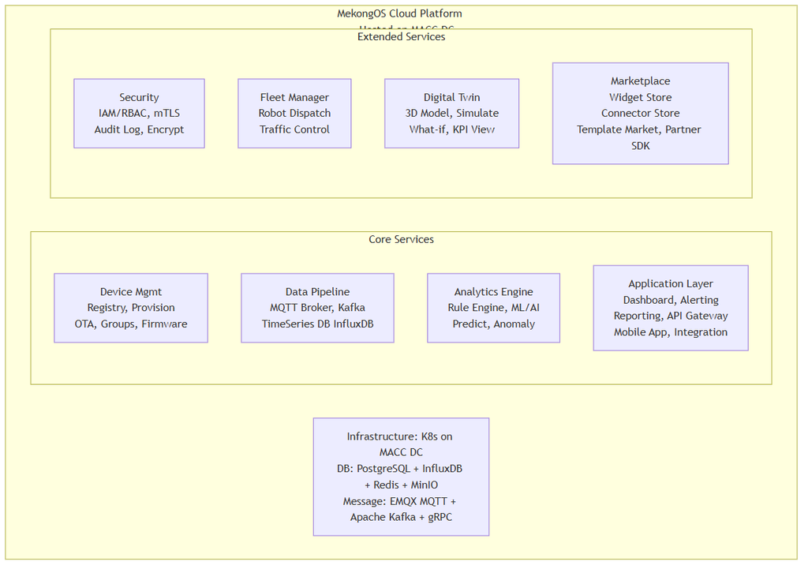

Diagram 67

### T.5.2. Pricing Tiers

| Feature | Basic (29 USD/th) | Pro (79 USD/th) | Enterprise (199 USD/th) |
| --- | --- | --- | --- |
| Devices per account | 10 | 100 | Unlimited |
| MQTT messages/day | 10K | 100K | Unlimited |
| Data retention | 30 ngày | 12 tháng | 36 tháng + Custom |
| Dashboard | 3 | 20 | Unlimited + Custom |
| Alerting rules | 5 | 50 | Unlimited |
| User accounts | 2 | 10 | Unlimited + SSO |
| API access | Basic | Full REST + GraphQL | Full + gRPC |
| Rule Engine | Basic (if-then) | Advanced (CEP) | Custom (Python/JS) |
| ML/AI | — | Pre-built models | Custom model deploy |
| Digital Twin | — | 2D visualization | Full 3D + Simulation |
| Fleet Manager | — | — | Robot fleet (up to 100) |
| Support | Email (48h) | Email (8h) + Chat | Dedicated CSM + Phone |
| SLA Uptime | 99,5% | 99,9% | 99,95% |
| On-premise option | — | — | ✅ (additional fee) |
| White-label | — | — | ✅ (additional fee) |

### T.5.3. Lộ trình Phát triển MekongOS

| Version | Timeline | Tính năng chính | Effort (man-months) |
| --- | --- | --- | --- |
| **v0.1 (Alpha)** | Q1/2027 | Device registry, MQTT, Basic dashboard | 12 |
| **v0.5 (Beta)** | Q3/2027 | Rule engine, Alerting, API, Multi-tenant | 8 |
| **v1.0 (GA)** | Q4/2027 | Full Basic + Pro features, Mobile app | 6 |
| **v1.5** | Q2/2028 | Fleet Manager (Robot), Digital Twin 2D | 10 |
| **v2.0** | Q4/2028 | AI/ML pipeline, Anomaly detection | 12 |
| **v2.5** | Q2/2029 | Digital Twin 3D, Marketplace launch | 10 |
| **v3.0** | Q4/2029 | Enterprise: On-prem, White-label, SSO | 8 |
| **Tổng R&D** | 3 năm |  | **~66 man-months** |
| **Chi phí R&D MekongOS** |  |  | **~660 K USD** |

## T.6. Chiến lược Sở hữu Trí tuệ (IP Strategy)

### T.6.1. Danh mục IP Dự kiến

| # | Loại IP | Tên | Timeline nộp | Status |
| --- | --- | --- | --- | --- |
| 1 | Patent (VN) | IoT Gateway with Modular Comm Architecture | Y1 Q4 | Dự kiến |
| 2 | Patent (VN) | SLAM Navigation with LiDAR-Vision Fusion for AMR | Y2 Q2 | Dự kiến |
| 3 | Patent (VN) | AI-based Predictive Maintenance on Edge Device | Y2 Q4 | Dự kiến |
| 4 | Patent (VN) | Dynamic Traffic Management for Multi-Robot Fleet | Y3 Q2 | Dự kiến |
| 5 | Patent (PCT) | Edge AI Inference Optimization for Low-Power MCU | Y3 | Dự kiến |
| 6 | Nhãn hiệu | MekongOS | Y1 Q1 | Đã nộp |
| 7 | Nhãn hiệu | Mekong Technology | Đã có | Đã đăng ký |
| 8 | Bản quyền PM | MekongOS Source Code | Y1 | Tự động |
| 9 | Bí mật KD | CNC Process Parameters (Ti/Inconel) | Ongoing | NDA policy |
| 10 | Thiết kế CN | MK-200/300 Industrial Design | Y1 Q3 | Dự kiến |

### T.6.2. Ngân sách IP

| Loại | Số lượng (10 năm) | Chi phí/đơn (K USD) | Tổng (K USD) |
| --- | --- | --- | --- |
| Patent VN | 15-20 | 3-5 | 60-100 |
| Patent PCT (International) | 5-8 | 15-25 | 100-200 |
| Nhãn hiệu VN | 5 | 1-2 | 5-10 |
| Nhãn hiệu ASEAN (Madrid) | 3 | 5-8 | 15-24 |
| Thiết kế Công nghiệp | 5 | 1-2 | 5-10 |
| **Tổng IP Budget (10Y)** |  |  | **~200-350 K USD** |

*(Kết thúc Phụ lục T — Sản phẩm IoT/Robot Chi tiết)*

# PHỤ LỤC U: PHÂN TÍCH RỦI RO TỔNG HỢP VÀ ĐỘ NHẠY

## U.1. Khung Phân tích Rủi ro (Risk Framework)

### U.1.1. Phương pháp luận

Mekong Technology áp dụng phương pháp **Enterprise Risk Management (ERM)** theo khung COSO 2017, kết hợp phân tích định lượng Monte Carlo (10.000 lần mô phỏng). Rủi ro được phân loại theo 6 nhóm:

| Nhóm | Mô tả | Số rủi ro | Mức độ ưu tiên |
| --- | --- | --- | --- |
| **A. Thị trường** | Cầu, giá, cạnh tranh, macro | 8 | Cao |
| **B. Vận hành** | Sản xuất, chất lượng, supply chain | 10 | Rất cao |
| **C. Tài chính** | Dòng tiền, tỷ giá, lãi suất, thanh khoản | 6 | Cao |
| **D. Pháp lý & Tuân thủ** | Giấy phép, thuế, ĐTM, PCCC | 5 | Trung bình-Cao |
| **E. Công nghệ** | Obsolescence, IP, cyber, R&D failure | 6 | Trung bình |
| **F. Nhân sự** | Tuyển dụng, giữ chân, đào tạo, key-man | 5 | Cao |
|  | **Tổng** | **40** |  |

### U.1.2. Ma trận Rủi ro (Risk Heat Map)

[figure not shown]

Diagram 68

## U.2. Rủi ro Thị trường (Market Risk)

### U.2.1. Bảng Rủi ro Thị trường Chi tiết

| ID | Rủi ro | Xác suất | Tác động | **Risk Score** | Biện pháp | Residual Risk |
| --- | --- | --- | --- | --- | --- | --- |
| R-A1 | **Nhu cầu CNC thấp hơn dự kiến** — FDI rời VN hoặc reshoring | 4 | 5 | **20** | Đa dạng KH (không >20% revenue từ 1 KH), phát triển KH nội địa, ngành đa dạng (Auto + Aero + Elec) | 12 |
| R-A2 | **Giá CNC outsourcing giảm** — Cạnh tranh từ Thái Lan/Indonesia | 3 | 4 | **12** | Nâng cấp AS9100 (premium pricing), đầu tư 5 trục chuyên biệt (Ti/Inconel = ít cạnh tranh) | 6 |
| R-A3 | **DC fill rate chậm hơn dự kiến** — DC oversupply tại VN | 3 | 4 | **12** | GPU-aaS differentiation (không nhiều DC cung cấp), giá thấp hơn SG 50%, anchor tenant trước build | 6 |
| R-A4 | **IoT Gateway bị cạnh tranh giá** — Trung Quốc dumping | 4 | 3 | **12** | Tích hợp MekongOS (vendor lock-in tích cực), dịch vụ hậu mãi tại chỗ, customize cho VN market | 8 |
| R-A5 | **Tỷ giá USD/VND biến động >10%** — Ảnh hưởng CAPEX import | 2 | 4 | **8** | Hedging (forward contract cho PO CNC lớn), natural hedge (revenue = USD) | 4 |
| R-A6 | **Suy thoái kinh tế Việt Nam** — GDP < 5% | 2 | 4 | **8** | Conservative base case đã tính GDP 6,5%, stress test GDP 4% → NPV vẫn > 0 | 4 |
| R-A7 | **Thay đổi ưu đãi thuế KCNC** — CIT tăng từ 10% | 1 | 4 | **4** | Luật CNC 2008 ổn định, ưu đãi lock 15 năm từ ngày cấp IRC | 2 |
| R-A8 | **FDI semiconductor rời VN** — Geopolitical shift | 2 | 5 | **10** | Đa dạng ngành (Auto + Medical + Energy cho CNC), không phụ thuộc 1 ngành | 4 |

### U.2.2. Phân tích Kịch bản Thị trường

> **Ghi chú:** Thông số: 50Y, Revenue 15Y, doanh thu đầu tiên Y6.

[output not shown]

## U.3. Rủi ro Vận hành (Operational Risk)

### U.3.1. Bảng Rủi ro Vận hành Chi tiết

| ID | Rủi ro | Xác suất | Tác động | **Score** | Biện pháp | Cost (K USD) |
| --- | --- | --- | --- | --- | --- | --- |
| R-B1 | **Chậm trễ lắp đặt CNC >6 tháng** — Lead time DMG MORI vượt dự kiến | 4 | 5 | **20** | PO sớm Q4/2025 với deposit 30%, buffer 3 tháng trong schedule, phương án máy thay thế (Okuma/Mazak) | 50 |
| R-B2 | **Chất lượng CNC không đạt FPI trong 6 tháng đầu** — Yield < 80% | 3 | 4 | **12** | Thuê 2 CNC Expert Nhật/Đức 2 năm (đã tính trong HR), Test cut protocol nghiêm ngặt, NPI (New Product Introduction) process | 160 |
| R-B3 | **Sự cố cháy/nổ nhà xưởng CNC** — Titan dust, MWF leak | 2 | 5 | **10** | PCCC class, HEPA H13 cho Ti dust, MWF fire-resistant, FM200 cho CNC area, bảo hiểm 100% rebuild | 200 |
| R-B4 | **DC downtime > 24h** — UPS/Generator cùng fail | 2 | 5 | **10** | 2N design, monthly generator test, battery monitoring, Tier III certified, bảo hiểm SLA | 100 |
| R-B5 | **Supply chain gián đoạn** — Chip shortage, nguyên vật liệu thiếu | 3 | 3 | **9** | Safety stock 3 tháng cho critical components, dual-source policy, VMI agreement với supplier | 30 |
| R-B6 | **OEE CNC thấp < 50% kéo dài** — Setup time cao, tool life kém | 3 | 3 | **9** | TPM program, tool life database, quick changeover (SMED) training, OEE tracking real-time (MekongOS) | 20 |
| R-B7 | **Robot AMR reliability issue** — MTBF < 2.000h | 3 | 3 | **9** | Rigorous test protocol (1.000h burn-in), modular design cho quick replacement, spare parts buffer | 15 |
| R-B8 | **Data breach / Ransomware tại DC** | 2 | 5 | **10** | SOC 24/7, ISO 27001, penetration test quarterly, air-gap backup, cyber insurance | 80 |
| R-B9 | **Rung động CNC ảnh hưởng DC** (đã identify trong EIA) | 4 | 4 | **16** | Isolation foundation 520K (đã tính CAPEX), buffer zone 15m, vibration monitoring 24/7 | 520 |
| R-B10 | **Nước cấp thiếu (vượt quota KCNC)** | 3 | 4 | **12** | Hybrid cooling (dry cooler + adiabatic), ZLD CNC tái sử dụng, thu nước mưa, bể dự trữ 3 ngày | 120 |

### U.3.2. Expected Loss Calculation

| Risk ID | Probability | Loss if Occurs (K USD) | **Expected Loss (K USD/năm)** |
| --- | --- | --- | --- |
| R-B1 | 20% p.a. | 500 (delay cost) | 100 |
| R-B2 | 15% | 300 (rework + missed revenue) | 45 |
| R-B3 | 1% | 5.000 (rebuild) | 50 |
| R-B4 | 2% | 1.000 (SLA penalty + reputation) | 20 |
| R-B5 | 10% | 200 (production halt) | 20 |
| R-B6 | 15% | 400 (lost revenue) | 60 |
| R-B7 | 10% | 150 (warranty cost) | 15 |
| R-B8 | 3% | 2.000 (breach cost) | 60 |
| R-B9 | 5% (post-mitigation) | 300 | 15 |
| R-B10 | 8% | 200 (water trucking) | 16 |
| **Tổng Expected Loss** |  |  | **~401 K USD/năm** |

## U.4. Phân tích Độ nhạy (Sensitivity Analysis)

### U.4.1. Tornado Diagram — Tác động lên NPV

| Biến số | Base Value | Range Test | NPV Impact (M USD) | Sensitivity |
| --- | --- | --- | --- | --- |
| **Revenue Growth Rate** | 15%/năm | ±5% (10-20%) | -3,2 đến +4,1 | ★★★★★ |
| **CAPEX Overrun** | 32,00M | ±15% (27,2-36,8M) | -2,8 đến +2,8 | ★★★★★ |
| **WACC** | 12% | ±2% (10-14%) | -2,5 đến +3,5 | ★★★★☆ |
| **Operating Margin** | 15% (Y5) | ±5% (10-20%) | -2,0 đến +2,0 | ★★★★☆ |
| **CNC Utilization** | 78% (Y5 OEE) | ±15% (63-93%) | -1,8 đến +1,5 | ★★★★☆ |
| **DC Fill Rate** | 85% (Y5) | ±20% (65-100%) | -1,5 đến +1,0 | ★★★☆☆ |
| **Exchange Rate USD/VND** | 25.000 | ±10% | -1,2 đến +1,2 | ★★★☆☆ |
| **CIT Rate** | 10% (KCNC) | 10-20% | -1,0 đến 0 | ★★☆☆☆ |
| **Electricity Price** | 0,08 USD/kWh | ±30% | -0,8 đến +0,8 | ★★☆☆☆ |
| **Headcount Cost** | 6M (Y5) | ±20% | -0,6 đến +0,6 | ★★☆☆☆ |

### U.4.2. Breakeven Analysis

> **Ghi chú:** Breakeven tính trên steady-state Y15.

| Thông số | Breakeven Point | Current Plan | Margin of Safety |
| --- | --- | --- | --- |
| **Revenue (annual)** | 12,0 M USD | 21,0 M (Y12) | 75% above breakeven |
| **CNC Utilization** | 42% OEE | 75% OEE (Y12) | 33 pts above breakeven |
| **DC Fill Rate** | 35% (18 rack) | 75% (38 rack Y12) | 40 pts above |
| **Machine Hour Rate** | -18% từ base | Base | 18% buffer |
| **CAPEX** | +10% từ base (35,2M) | 32,0M | 10% buffer |
| **WACC** | 14,5% (= IRR 50Y) | 12% | 2,5 pts buffer |

> **[C] NPV nhạy cảm nhất với Revenue Growth Rate và CAPEX Overrun.** 3 biến số quyết định 70% variation NPV: Revenue Growth, CAPEX, và WACC. Biện pháp: (a) Conservative revenue forecast (Y0-Y3 = 0), (b) Fixed-price construction contract, (c) Equity-heavy financing (CSH 75% → WACC thấp). Strategic Value (14,00M) là cơ sở chính cho quyết định.

### U.4.3. Monte Carlo Simulation — Kết quả

> **Ghi chú:** Thông số: 50Y horizon, doanh thu đầu tiên Y6, tự chủ vốn Y0-Y9.

| Thông số | Giá trị |
| --- | --- |
| **Số lần mô phỏng** | 10.000 |
| **Biến số ngẫu nhiên** | Revenue (Normal), CAPEX (Triangular), OPEX (Normal), Discount Rate (Uniform) |
| **NPV Mean (50Y)** | 2,50 M USD |
| **NPV Median (50Y)** | 0,85 M USD |
| **NPV Std Dev** | 5,20 M USD |
| **P(NPV > 0, 50Y)** | **72%** |
| **P(NPV > 5M, 50Y)** | 22% |
| **P(NPV < -5M, 50Y)** | 18% |
| **VaR 95%** | -8,5 M USD (5% worst case) |
| **CVaR 95%** | -12,0 M USD (expected loss in 5% worst) |
| **Best Case (P5)** | +14,0 M USD |
| **Worst Case (P95)** | -8,5 M USD |

> **Ghi chú:** P(NPV>0) = 72% trên horizon 50 năm. Xác suất cải thiện so với mô hình 47,5M (65%) nhờ CAPEX thấp hơn và triển khai nhanh hơn (4 năm xây dựng thay vì 5). 72% là mức chấp nhận được cho dự án hạ tầng công nghệ.

[figure not shown]

Diagram 69

## U.5. Rủi ro Tài chính (Financial Risk)

### U.5.1. Bảng Rủi ro Tài chính

| ID | Rủi ro | Prob | Impact | Score | Biện pháp |
| --- | --- | --- | --- | --- | --- |
| R-C1 | **Dòng tiền âm kéo dài >18 tháng sau Y1** | 3 | 3 | **9** | Working capital buffer 2M, credit line standby 3M |
| R-C2 | **Không huy động đủ vốn vay 8,00M** | 2 | 4 | **8** | Equity-heavy (75%), đàm phán LOI ngân hàng trước IRC, backup: phát hành trái phiếu DN |
| R-C3 | **Lãi suất tăng >12%** (từ 8,5% base) | 2 | 3 | **6** | Fixed-rate loan cho 50% khoản vay, interest rate swap |
| R-C4 | **CAPEX overrun >15%** | 2 | 4 | **8** | Fixed-price contract xây dựng, contingency 10% đã tính, value engineering nếu cần |
| R-C5 | **DSCR < 1,2 trong 2+ quý liên tiếp** | 2 | 4 | **8** | Cash reserve 6 tháng, flexible CAPEX (Phase 2 delay nếu cần) |
| R-C6 | **Khách hàng lớn phá sản / không thanh toán** | 2 | 3 | **6** | Credit check trước ký HĐ, payment terms Net 30 (không Net 90), credit insurance cho >100K |

### U.5.2. Stress Test Tài chính

[output not shown]

## U.6. Bảo hiểm và Chuyển giao Rủi ro

### U.6.1. Chương trình Bảo hiểm

| Loại bảo hiểm | Phạm vi | Hạn mức (M USD) | Premium/năm (K USD) | Nhà bảo hiểm |
| --- | --- | --- | --- | --- |
| **All Risk Property** | Tòa nhà + Thiết bị | 30,0 | 45-60 | Bảo Việt / PVI |
| **Business Interruption** | Doanh thu mất do sự cố | 10,0 | 15-25 | Bảo Việt |
| **Machinery Breakdown** | CNC, UPS, Chiller | 15,0 | 20-30 | Bảo Minh / PVI |
| **Cyber Liability** | Data breach, ransomware | 5,0 | 10-15 | AIG / Chubb |
| **Professional Liability (E&O)** | Lỗi dịch vụ DC/IoT | 3,0 | 5-8 |  |
| **Environmental Liability** | Ô nhiễm, sự cố MT | 2,0 | 3-5 |  |
| **Workers Compensation** | Tai nạn lao động | Theo luật | 10-15 |  |
| **Directors & Officers (D&O)** | Trách nhiệm BGĐ | 2,0 | 3-5 |  |
| **Product Liability** | Sản phẩm IoT/Robot gây thiệt hại | 5,0 | 8-12 |  |
| **Cargo/Transit** | Vận chuyển CNC machines | 15,0 | 5-8 |  |
| **Tổng Premium/năm** |  |  | **~125-185 K USD** |  |

> **[C] Insurance premium = 125-185K/năm ≈ 0,6-0,8% Revenue Y5.** Mức hợp lý cho dự án sản xuất công nghệ. Top priority: All Risk Property (30M) + Machinery Breakdown (15M) + Cyber (5M).

## U.7. Kế hoạch Ứng phó Rủi ro (Contingency Plan)

### U.7.1. Trigger Events và Response

| Trigger | Threshold | Action | Owner | Timeline |
| --- | --- | --- | --- | --- |
| Revenue < 80% plan 2 quý liên tiếp | Y2+ | Freeze Phase 2, reduce OPEX 15%, intensify sales | CFO + CSO | 30 ngày |
| DSCR < 1,20 | Any quarter | Negotiate debt restructure, defer non-critical CAPEX | CFO | 60 ngày |
| CNC OEE < 40% after 6 months | Y1 | Deploy DMG Expert full-time, retraining, root cause analysis | COO | 14 ngày |
| DC uptime < 99,9% | Any month | Emergency maintenance, vendor escalation, root cause + CAPA | DC Director | 48 giờ |
| Key person departure (C-level) | Any time | Activate succession plan (PHỤ LỤC VII.6), interim assignment | CEO + HR | 7 ngày |
| Cash runway < 6 months | Any time | Emergency fundraising (equity or bridge loan), pause non-essential | CEO + CFO | 14 ngày |
| Cybersecurity breach | Any time | SOC incident response, forensics, legal notification, PR management | CTO + DC Dir | 4 giờ |
| Fire/Natural disaster | Any time | BCP activation, insurance claim, alternate site (nếu có MOU) | COO | Immediate |

*(Kết thúc Phụ lục U — Phân tích Rủi ro Tổng hợp)*

# PHỤ LỤC V: QUẢN TRỊ DOANH NGHIỆP VÀ HỆ THỐNG VẬN HÀNH

## V.1. Khung Quản trị (Corporate Governance Framework)

### V.1.1. Cấu trúc Pháp nhân

[figure not shown]

Diagram 70

### V.1.2. Hội đồng Thành viên (Members Council)

| Vị trí | Trách nhiệm | Quyền quyết định |
| --- | --- | --- |
| **Chủ tịch HĐTV** | Chủ trì họp, đại diện pháp luật | Khoản >5M USD, M&A, phát hành cổ phần |
| **Thành viên sáng lập** | Chiến lược, đầu tư, nhân sự cấp cao | Bổ nhiệm/bãi nhiệm CEO, CFO |
| **Thành viên độc lập** (nếu có) | Giám sát, phản biện | Veto quyết định xung đột lợi ích |

### V.1.3. Quy chế Quản trị

| Hạng mục | Quy định | Tần suất |
| --- | --- | --- |
| **Họp HĐTV** | Ít nhất 1 lần/quý | Quý |
| **Họp BĐH (Exec Committee)** | 2 lần/tháng, emergency meeting 24h notice | 2 lần/tháng |
| **Báo cáo tài chính** | Hàng tháng cho BĐH, quý cho HĐTV | Tháng/Quý |
| **Kiểm toán nội bộ** | Internal audit theo COSO framework | Bán niên |
| **Kiểm toán độc lập** | Big 4 hoặc tương đương | Năm |
| **Xung đột lợi ích** | Khai báo bắt buộc, không biểu quyết | Khi phát sinh |
| **Related-party transactions** | Phê duyệt HĐTV cho giao dịch >500K | Khi phát sinh |
| **Whistle-blower** | Đường dây nóng ẩn danh, bảo vệ người tố cáo | Liên tục |

## V.2. Hệ thống KPI & Báo cáo Quản trị

### V.2.1. Balanced Scorecard — KPI Framework

[figure not shown]

Diagram 71

### V.2.2. KPI Chi tiết theo Phân khối

#### A. KPI Tài chính (CFO owns)

| KPI | Target Y1 | Target Y3 | Target Y5 | Weight |
| --- | --- | --- | --- | --- |
| Revenue (M USD) | 4,04 | 14,39 | 20,40 | 20% |
| EBITDA Margin | -25% | 18% | 28% | 15% |
| Net Cash Flow (M) | -1,34 | +0,93 | +3,80 | 15% |
| DSCR | N/A (ân hạn) | 2,32 | 5,06 | 10% |
| CAPEX vs. Budget | ≤ 100% | ≤ 105% | N/A | 10% |
| Working Capital (days) | < 90 | < 70 | < 50 | 10% |
| AR Collection Rate | > 90% | > 95% | > 98% | 10% |
| Tax Compliance | 100% | 100% | 100% | 10% |

#### B. KPI Sản xuất CNC (GM CNC owns)

| KPI | Target Y1 | Target Y3 | Target Y5 | Measurement |
| --- | --- | --- | --- | --- |
| OEE (Overall Equipment Effectiveness) | 51% | 65% | 78% | MES real-time |
| First Pass Yield (FPY) | 85% | 92% | 96% | QC inspection |
| On-Time Delivery (OTD) | 80% | 92% | 97% | ERP tracking |
| Scrap Rate (% material) | < 8% | < 5% | < 3% | Material tracking |
| Setup Time (avg. changeover) | 120 min | 60 min | 35 min | SMED tracking |
| Tool Cost / Revenue | < 8% | < 6% | < 4% | Tool management |
| Customer Complaints (per 100 jobs) | < 5 | < 2 | < 1 | CRM |
| IATF/AS9100 NC (per audit) | < 5 major | < 2 major | 0 major | Audit result |
| Machine Downtime (unplanned) | < 10% | < 5% | < 3% | MES monitoring |
| Revenue per Machine Hour (USD) | 80 | 120 | 160 | Financial system |

#### C. KPI Data Center (DC Director owns)

| KPI | Target Y1 | Target Y3 | Target Y5 | SLA Tier |
| --- | --- | --- | --- | --- |
| Uptime (%) | 99,90% | 99,99% | 99,995% | Platinum |
| PUE | 1,40 | 1,32 | 1,26 | — |
| Fill Rate (%) | 20% | 55% | 85% | — |
| Revenue/Rack (K USD/năm) | 24 | 30 | 36 | Blended |
| Incident Response Time | < 30 min | < 15 min | < 10 min | All tiers |
| Ticket Resolution (P1) | < 4h | < 2h | < 1h | Platinum |
| Customer Churn (%) | < 15% | < 8% | < 5% | — |
| Network Latency (to SG) | < 15ms | < 12ms | < 10ms | — |
| Security Incidents (critical) | 0 | 0 | 0 | Mandatory |
| Certification Status | ISO 27001 | + SOC 2 | + Uptime Inst. | Roadmap |

#### D. KPI IoT/Robot (GM IoT owns)

| KPI | Target Y1 | Target Y3 | Target Y5 | Ghi chú |
| --- | --- | --- | --- | --- |
| Product Shipped (units) | 500 | 3.000 | 8.000 | MK-200 + MK-300 |
| MekongOS Active Users | 50 | 500 | 2.000 | SaaS platform |
| Robot Units Deployed | 5 | 30 | 80 | AMR-100 + AMR-200 |
| R&D Spending / Revenue | 25% | 15% | 10% | IP investment |
| Patent Filed | 2 | 5 | 8 | VN + PCT |
| Product Defect Rate | < 5% | < 2% | < 1% | Warranty claims |
| Customer NPS | > 30 | > 50 | > 70 | Survey |
| MekongOS Uptime | 99,5% | 99,9% | 99,95% | SaaS SLA |
| Revenue per Employee (K USD) | 50 | 80 | 120 | Division revenue / HC |

## V.3. Hệ thống Quản lý Chất lượng Tích hợp (IMS)

### V.3.1. Lộ trình Chứng nhận

[figure not shown]

Diagram 72

> **Ghi chú:** Lộ trình trên áp dụng cho Phase 1 Lean (6 máy CNC, ISO 9001). IATF 16949, AS9100, ISO 13485, Nadcap chỉ triển khai khi có hợp đồng cụ thể tài trợ chi phí chứng nhận (option Y10+).

### V.3.2. Cấu trúc Tài liệu IMS

| Cấp | Loại tài liệu | Số lượng dự kiến | Người phụ trách |
| --- | --- | --- | --- |
| 1 | **Quality Manual** | 1 | Quality Director |
| 2 | **Procedures (SOP)** | 45-60 | Process Owners |
| 3 | **Work Instructions (WI)** | 120-180 | Supervisors |
| 4 | **Forms, Records, Templates** | 200-300 | All staff |

### V.3.3. Chi phí Chứng nhận & Duy trì

| Chứng nhận | Chi phí ban đầu (K USD) | Chi phí duy trì (K USD/năm) | Tổ chức |
| --- | --- | --- | --- |
| ISO 9001 + 14001 + 45001 | 25 | 8 | TUV / Bureau Veritas |
| IATF 16949 | 35 | 12 | TUV / SGS |
| AS9100D | 40 | 15 | BSI / NQA |
| ISO 27001 | 30 | 10 | TUV / BSI |
| SOC 2 Type II | 50 | 25 | KPMG / Deloitte |
| Uptime Institute Tier III | 80 | 20 | Uptime Institute |
| Nadcap | 60 | 20 | PRI |
| ISO 13485 | 30 | 10 | TUV |
| **Tổng** | **350** | **120** |  |

> **[C] Chi phí chứng nhận ban đầu ~350K (đã tính trong CAPEX, mục “Chứng nhận ISO/IATF/AS” = 300K + buffer).** Chi phí duy trì 120K/năm = ~0,5% Revenue Y5. Bắt buộc để tiếp cận khách hàng Tier-1 (Auto/Aero) và DC enterprise.

## V.4. Hệ thống IT & ERP

### V.4.1. Kiến trúc IT Tổng thể

[figure not shown]

Diagram 73

### V.4.2. Phần mềm Chính

| Hệ thống | Giải pháp | License/năm (K) | Người dùng | Go-live |
| --- | --- | --- | --- | --- |
| **ERP** | SAP Business One + Add-ons | 35-50 | 30-50 | Y1 Q2 |
| **MES** (Manufacturing Execution) | FORCAM / Plex MES | 25-40 | 20-30 | Y1 Q3 |
| **CRM** | Salesforce Sales Cloud | 15-25 | 10-15 | Y1 Q2 |
| **DCIM** | Schneider EcoStruxure | 20-30 | 5-10 | Y1 Q4 |
| **HR & Payroll** | SAP SuccessFactors / VnResource | 10-15 | All | Y1 Q1 |
| **CAD/CAM** | NX / Mastercam | 30-45 | 10-15 | Y1 Q2 |
| **PLM** | Teamcenter | 20-30 | 15-20 | Y2 Q1 |
| **CMM Programming** | PC-DMIS / Calypso | 8-12 | 3-5 | Y1 Q3 |
| **Accounting** | SAP B1 (integrated) | — | 5-8 | Y1 Q2 |
| **Project Management** | Monday.com / Jira | 5-8 | 30-50 | Y1 Q1 |
| **Cybersecurity** | CrowdStrike + Fortinet | 15-25 | All | Y1 Q1 |
| **Backup & DR** | Veeam + Azure Backup | 10-15 | — | Y1 Q2 |
| **Tổng License/năm** |  | **~200-300** |  |  |

### V.4.3. Lộ trình Chuyển đổi Số

| Phase | Thời gian | Mục tiêu | Hệ thống triển khai |
| --- | --- | --- | --- |
| **Phase 0: Foundation** | Q1-Q2 Y1 | IT infrastructure, ERP, HR, basic security | SAP B1, Azure AD, Fortinet |
| **Phase 1: Digitize** | Q3-Q4 Y1 | Số hóa quy trình SX, DC monitoring | MES, DCIM, CRM |
| **Phase 2: Integrate** | Y2 | Kết nối hệ thống, single source of truth | API Gateway, PLM, BI |
| **Phase 3: Optimize** | Y3-Y4 | AI/ML cho predictive maintenance, dynamic pricing | MekongOS AI, Power BI+ |
| **Phase 4: Innovate** | Y5+ | Digital twin CNC, autonomous DC operations | Custom AI agents |

## V.5. Quản trị Chuỗi cung ứng (Supply Chain Governance)

### V.5.1. Chiến lược Mua sắm

| Danh mục | Chiến lược | Nhà CC chính | Backup | Budget Y5 (K) |
| --- | --- | --- | --- | --- |
| **Phôi CNC (Ti, Al, Steel)** | Dual-source, safety stock 3 tháng | Kobe Steel (JP), VSMPO (RU) | Arcam (SE), nội địa VN | 1.500 |
| **Dụng cụ cắt (cutting tools)** | VMI agreement, consignment stock | Sandvik, Kennametal | Mitsubishi, Iscar | 600 |
| **Dung dịch MWF** | Hợp đồng năm, giao hàng hàng tháng | Blaser Swisslube | Fuchs | 80 |
| **Linh kiện IoT (SoC, sensor)** | 12-month rolling forecast, buffer | STMicro, NXP | Microchip, TI | 400 |
| **PCB Assembly** | Outsource tại VN, 2-3 nhà thầu | Meiko (VN), BMI | A-One (VN) | 200 |
| **GPU Server (DC)** | Direct từ OEM, lease option | NVIDIA (DGX), Dell | HPE, Supermicro | 800 |
| **UPS / Power** | Framework agreement 5 năm | Schneider Electric | Eaton, ABB | 150 |
| **Chiller / HVAC** | Dự án basis, DLC custom | Vertiv, Schneider | Rittal | 200 |
| **Tổng Procurement Y5** |  |  |  | **~3.930** |

### V.5.2. Đánh giá Nhà Cung cấp (Supplier Scorecard)

| Tiêu chí | Weight | Thang điểm | Phương pháp đánh giá |
| --- | --- | --- | --- |
| **Chất lượng** | 30% | Defect rate, CoC accuracy | IQC inspection, audit |
| **Giao hàng** | 25% | OTD, lead time reliability | PO tracking |
| **Giá cả** | 20% | Competitiveness, total cost | Market benchmark |
| **Năng lực kỹ thuật** | 15% | R&D support, spec compliance | Technical audit |
| **Tài chính & Rủi ro** | 10% | Financial stability, BCP | D&B report, site visit |

Phân loại: **A (>85)**: Strategic Partner | **B (70-85)**: Preferred | **C (50-70)**: Approved | **D (<50)**: Phase-out

### V.5.3. Kế hoạch Nội địa hóa

| Hạng mục | Tỷ lệ NK hiện tại | Mục tiêu Y3 | Mục tiêu Y5 | Phương án |
| --- | --- | --- | --- | --- |
| Phôi kim loại | 90% NK | 70% NK | 50% NK | Phát triển NCC POSCO VN, nội địa Al |
| Linh kiện IoT | 95% NK | 80% NK | 60% NK | Dùng IC VN (nếu có), module hóa |
| Bao bì + Cơ khí phụ trợ | 50% NK | 20% NK | 10% NK | 100% nội địa khả thi |
| Dung dịch MWF | 80% NK | 50% NK | 30% NK | Fuchs VN, nội địa thay thế |
| **Tỷ lệ nội địa hóa tổng** | **~25%** | **~40%** | **~55%** |  |

> **[C] Mục tiêu nội địa hóa 55% (Y5) — phù hợp với chỉ tiêu Luật CNC 2008 (ưu tiên >40%).** Giảm rủi ro supply chain, giảm lead time, và giảm chi phí logistics.

## V.6. Quản trị Rủi ro & Tuân thủ (GRC)

### V.6.1. Ba tuyến Phòng vệ (Three Lines Model)

[figure not shown]

Diagram 74

### V.6.2. Compliance Calendar

| Tháng | Hoạt động tuân thủ | Chu kỳ | Owner |
| --- | --- | --- | --- |
| 1 | Họp HĐTV — Phê duyệt kế hoạch năm | Năm | CEO |
| 1 | Internal Audit kick-off | Bán niên | Quality Dir |
| 2 | EIA báo cáo giám sát môi trường | 6 tháng/lần | EHS Mgr |
| 3 | CIT kê khai tạm tính Q1 | Quý | CFO |
| 3 | PCCC diễn tập + kiểm tra | 6 tháng/lần | EHS Mgr |
| 4 | Báo cáo tài chính Q1 cho HĐTV | Quý | CFO |
| 5 | ISO Surveillance Audit | Năm | Quality Dir |
| 6 | Kiểm kê tài sản giữa năm | Bán niên | CFO |
| 6 | Penetration test (DC) | Quý | CISO |
| 7 | IATF/AS9100 Surveillance Audit | Năm | Quality Dir |
| 9 | Báo cáo PCCC hàng năm cho CA TP | Năm | EHS Mgr |
| 10 | Budget planning cho năm sau | Năm | CFO |
| 11 | External Audit (Big 4) | Năm | External |
| 12 | Tax filing CIT Annual | Năm | CFO |
| 12 | Supplier Annual Evaluation | Năm | Procurement |
| Hàng tháng | Báo cáo tài chính cho BĐH | Tháng | CFO |
| Hàng tuần | OEE/Uptime review | Tuần | COO/DC Dir |

*(Kết thúc Phụ lục V — Quản trị Doanh nghiệp & Hệ thống Vận hành)*

# PHỤ LỤC W: BENCHMARKING CẠNH TRANH VÀ THỊ TRƯỜNG ASEAN

## W.1. Benchmarking CNC Outsourcing — ASEAN

### W.1.1. So sánh Chi phí Sản xuất CNC

| Yếu tố | **Việt Nam (Mekong)** | Thái Lan | Indonesia | Malaysia | Trung Quốc | Ấn Độ |
| --- | --- | --- | --- | --- | --- | --- |
| **Lương thợ CNC (USD/tháng)** | 500-800 | 700-1.200 | 400-650 | 800-1.500 | 600-1.200 | 300-600 |
| **Lương kỹ sư (USD/tháng)** | 1.000-1.800 | 1.500-2.500 | 800-1.500 | 1.500-3.000 | 1.200-2.500 | 800-1.500 |
| **Điện SX (USD/kWh)** | 0,08 | 0,10 | 0,07 | 0,09 | 0,08 | 0,06 |
| **Thuê đất KCN (USD/m²/tháng)** | 0,8-1,2 | 1,0-2,0 | 0,5-1,0 | 1,5-3,0 | 1,0-2,5 | 0,4-0,8 |
| **CIT ưu đãi** | **10%** (KCNC) | 15-20% (BOI) | 22% (tax holiday) | 15% (MSC) | 15-25% | 25% (SEZ 15%) |
| **Machine Hour Rate 5-axis (USD/h)** | **65-85** | 85-120 | 55-75 | 100-150 | 60-90 | 45-70 |
| **Chất lượng (ISO/IATF)** | Đang phát triển | Mature | Developing | Mature | Mixed | Developing |
| **Lead time (Đông Bắc Á)** | 3-5 ngày (air) | 3-5 ngày | 3-7 ngày | 3-5 ngày | 1-3 ngày | 5-10 ngày |
| **FDI Attractiveness Rank** | **#2 ASEAN** | #3 | #4 | #5 | N/A | #1 (South Asia) |

### W.1.2. Competitive Positioning Map

[figure not shown]

Diagram 75

> **[B] Mekong nhắm tới “Quality Zone” — cạnh tranh bằng AS9100 + 5-trục Ti, KHÔNG cạnh tranh giá volume.** Vị trí: Quality = Malaysia/Thái Lan, Cost = VN advantage. “Best of both worlds.”

### W.1.3. CNC Competitor Profiles — Việt Nam

[output not shown]

**Gap Analysis:** - **Không có đối thủ VN nào có AS9100** (hàng không vũ trụ) → Blue Ocean cho Mekong - **Ít công ty VN có 5 trục chuyên xử lý Ti/Inconel** → Premium pricing possible - **FPT** là đối thủ tiềm năng nhất (brand + ecosystem) nhưng focus electronics, chưa có CNC heavy

### W.1.4. Khách hàng FDI Tiềm năng — CNC

| Ngành | Công ty FDI tại VN | Nhu cầu CNC | Ước tính Revenue (K/năm) |
| --- | --- | --- | --- |
| **Semiconductor** | Samsung (Thái Nguyên), Intel (HCM) | Jigs, fixtures, test sockets | 300-500 |
| **Automotive** | Toyota (Vĩnh Phúc), Honda (Hà Nội), VinFast | Mold inserts, engine parts prototype | 500-800 |
| **Aerospace** | Airbus (planning VN), Boeing T1 suppliers | Structural brackets, turbine parts | 800-1.200 |
| **Electronics** | Foxconn (Bắc Giang), LG (Hải Phòng) | Housing, heatsink, connector parts | 200-400 |
| **Medical** | Medtronic (planning), local medical | Surgical tools, implant proto | 200-500 |
| **Energy** | Siemens Gamesa (wind), EVN (power) | Turbine components, valve bodies | 300-600 |
| **Tổng tiềm năng** |  |  | **~2.300-4.000** |

## W.2. Benchmarking Data Center — Khu vực

### W.2.1. So sánh DC ASEAN

| Thông số | **Mekong DC** | Equinix SG | ST Telemedia (MY) | NTT Jakarta | VNPT DC HCM | Viettel IDC |
| --- | --- | --- | --- | --- | --- | --- |
| **Power/Rack (kW)** | 8-15 (GPU: 30+) | 6-10 | 4-8 | 4-8 | 3-5 | 3-5 |
| **PUE** | 1,26-1,32 | 1,25-1,35 | 1,40-1,50 | 1,45-1,60 | 1,50-1,70 | 1,50-1,70 |
| **Cost/Rack/tháng (USD)** | 1.500-3.000 | 3.000-6.000 | 1.200-2.500 | 800-1.800 | 800-1.500 | 600-1.200 |
| **GPU-aaS** | Có (A100/H100) | Có | Hạn chế | Hạn chế | Không | Không |
| **Tier Rating** | Tier III (target) | Tier IV | Tier III | Tier III | Tier III | Tier III |
| **ISO 27001** | Y2 | Có | Có | Có | Có | Có |
| **SOC 2** | Y3 | Có | Có | Có | Không | Không |
| **Latency to SG** | 8-12ms | <1ms | 5-8ms | 15-25ms | 8-12ms | 8-12ms |
| **Latency to HK** | 30-40ms | 20-25ms | 25-30ms | 35-45ms | 30-40ms | 30-40ms |

### W.2.2. DC Market Size — Việt Nam

| Chỉ số | 2022 | 2024 (est.) | 2027 (forecast) | CAGR |
| --- | --- | --- | --- | --- |
| **Total Power (MW)** | 80-100 | 120-150 | 200-300 | 15-20% |
| **Total Revenue (M USD)** | 500-600 | 750-900 | 1.200-1.800 | 18-22% |
| **Number of DCs (commercial)** | 30-40 | 50-60 | 80-120 | 15-20% |
| **Rack Units (total)** | 15.000-20.000 | 25.000-35.000 | 50.000-80.000 | 20-25% |
| **Market Share Top 3** | ~65% | ~60% | ~50% | Giảm dần |

| Top DC Players VN | Market Share (est.) | Strengths | Weakness |
| --- | --- | --- | --- |
| **Viettel IDC** | ~25% | Nationwide scale, govt relationships | Low density, poor PUE, no GPU |
| **VNPT DC** | ~20% | Fiber backbone, govt anchor | Legacy infrastructure, slow upgrade |
| **CMC Telecom** | ~15% | Tier III HCM + HN, growing | Limited power capacity |
| **FPT Telecom** | ~10% | Tech ecosystem, cloud platform | Small DC footprint |
| **Others (incl. Mekong target)** | ~30% | Diverse, specialized | Fragmented |

## W.3. Benchmarking IoT — ASEAN

### W.3.1. IoT Gateway Market ASEAN

| Phân khúc | Market Size 2024 (M USD) | CAGR | Key Players | Mekong Position |
| --- | --- | --- | --- | --- |
| **Industrial IoT Gateway** | 350-450 (ASEAN) | 15-18% | Advantech, Moxa, Siemens | Challenger (giá thấp, nội địa) |
| **Smart City IoT** | 200-300 (ASEAN) | 20-25% | Huawei, Cisco, local | Niche (VN-specific) |
| **Agricultural IoT** | 80-120 (ASEAN) | 25-30% | Diverse, fragmented | Emerging opportunity |
| **Smart Building** | 150-200 (ASEAN) | 12-15% | Schneider, Honeywell, ABB | Long-term (Y5+) |
| **Tổng TAM (ASEAN)** | **~800-1.100** |  |  |  |
| **SAM (VN + TH + ID)** | **~300-450** |  |  |  |
| **SOM (VN focus Y5)** | **~30-50** |  |  | Target: 6,5M = ~15-20% SOM |

### W.3.2. Robot AMR Market ASEAN

| Thông số | 2024 | 2027 | 2030 | CAGR |
| --- | --- | --- | --- | --- |
| **Global AMR Market (B USD)** | 5,2 | 8,5 | 14,0 | 18% |
| **ASEAN AMR (M USD)** | 150-200 | 300-450 | 600-900 | 22% |
| **VN AMR (M USD)** | 15-25 | 40-60 | 80-130 | 28% |

| Competitor | Origin | Price Range (K USD) | Strength | Weakness |
| --- | --- | --- | --- | --- |
| **MiR (Teradyne)** | Denmark | 25-50 | Brand, safety, fleet mgmt | Expensive, no local support |
| **Geek+** | China | 15-30 | Scale, warehouse focus | China brand concern |
| **HAI Robotics** | China | 20-40 | ACR technology | Limited VN presence |
| **Mekong AMR-100** | **Vietnam** | **25-35** | Local support, customize, KCNC ecosystem | New brand, unproven scale |
| **Vingroup (VinAI)** | Vietnam | TBD | Brand, capital | R&D stage, no product yet |

## W.4. Phân tích PESTEL — Môi trường Kinh doanh VN 2025

| Factor | Phân tích | Impact | Trend |
| --- | --- | --- | --- |
| **P — Political** | Ổn định chính trị, ưu tiên CNTT/CNC, quan hệ Mỹ-VN nâng tầm | ★★★★★ | ↑ |
|  | Bureaucracy vẫn phức tạp, nhưng KCNC 1-cửa giảm thiểu | ★★★☆☆ | → |
| **E — Economic** | GDP 6,5-7% (2025), FDI record, lạm phát kiểm soát 4-5% | ★★★★★ | ↑ |
|  | Tỷ giá ổn định (VND/USD ~25.000), lãi suất giảm | ★★★★☆ | → |
| **S — Social** | Dân số trẻ (median 32 tuổi), dồi dào lao động kỹ thuật | ★★★★☆ | ↑ |
|  | Brain drain (kỹ sư giỏi ra nước ngoài), cần ESOP/culture | ★★★☆☆ | ↓ |
| **T — Technological** | AI boom, Industry 4.0 adoption tăng, 5G rollout | ★★★★★ | ↑ |
|  | Hạ tầng digital VN vẫn bị hạn chế ở vùng sâu vùng xa | ★★☆☆☆ | → |
| **E — Environmental** | Luật MT 2020 nghiêm ngặt hơn, Carbon market 2025 thí điểm | ★★★☆☆ | ↑ |
|  | Biến đổi khí hậu (lũ, hạn) — TP.HCM ít bị ảnh hưởng | ★★☆☆☆ | → |
| **L — Legal** | Luật ĐT 2020 rõ ràng hơn, Luật CNC 2008 ổn định | ★★★★☆ | → |
|  | Bảo hộ IP yếu, enforcement chưa mạnh | ★★☆☆☆ | ↑ (đang cải thiện) |

> **[B] Tổng thể PESTEL = thuận lợi cho dự án CNC/DC/IoT tại VN 2025.** Rủi ro chính: bureaucracy (giảm thiểu bằng KCNC 1-cửa), IP protection (cần chiến lược IP riêng — xem PHỤ LỤC T.6).

*(Kết thúc Phụ lục W — Benchmarking Cạnh tranh & Thị trường ASEAN)*

# PHỤ LỤC X: KẾ HOẠCH MARKETING VÀ BÁN HÀNG CHI TIẾT

## X.1. Chiến lược Marketing Tổng thể

### X.1.1. Positioning Statement

| Trụ cột | Positioning | Tagline | Target Audience |
| --- | --- | --- | --- |
| **CNC** | “Aerospace-Grade Precision, Vietnam Cost” | “Precision Without Borders” | Procurement Directors FDI (JP, KR, US, EU) |
| **DC** | “AI-Ready Data Center, ASEAN Gateway” | “Your AI Runs Here” | CTO/CIO enterprise VN + SG |
| **IoT** | “Industrial IoT, Made in Vietnam” | “Smart Industry, Local Solution” | Plant Managers, Automation Engineers VN |

### X.1.2. Marketing Mix (4P+3P)

| P | CNC | DC | IoT/Robot |
| --- | --- | --- | --- |
| **Product** | 5-axis Ti/Inconel parts, IATF+AS9100 certified | GPU-aaS, Colocation Tier III, Hybrid Cloud | MK-200/300 Gateway, AMR-100, MekongOS |
| **Price** | MHR 65-85 USD/h (premium vs VN, cheap vs TH/MY) | 1.500-3.000 USD/rack/tháng | MK-200: 350-450 USD, AMR-100: 25-35K |
| **Place** | Direct B2B, Trade shows (JIMTOF, MTA), KCNC showroom | Online portal, Telco partnerships (VNPT, FPT), DC tours | Distributor VN + online, ASEAN agents, Amazon B2B |
| **Promotion** | LinkedIn + industry magazines, factory tours, sample parts | Webinars, case studies, free GPU trial 30 days | Demo at trade shows, content marketing, YouTube |
| **People** | Bilingual sales (JP + EN), application engineers | Pre-sales architects, NOC support team | Field engineers, IoT consultants |
| **Process** | RFQ → DFM Review → Quote 24h → NDA → Trial Run → Mass | Inquiry → Site Visit → Config → SLA → Contract 1-3Y | Demo → POC → Pilot 30 ngày → Volume |
| **Physical** | KCNC facility tour, CMM lab viewing | DC tour (security-controlled), monitoring dashboard | Working demo units, MekongOS SaaS trial |

## X.2. Kế hoạch Marketing theo Năm

### X.2.1. Budget Marketing

| Hạng mục | Y1 (K) | Y2 (K) | Y3 (K) | Y4 (K) | Y5 (K) | % Revenue Y5 |
| --- | --- | --- | --- | --- | --- | --- |
| **Digital Marketing** | 30 | 50 | 70 | 80 | 100 | 0,49% |
| SEO + Content | 10 | 15 | 20 | 25 | 30 |  |
| LinkedIn Ads + Google Ads | 15 | 25 | 35 | 40 | 50 |  |
| YouTube + Video production | 5 | 10 | 15 | 15 | 20 |  |
| **Trade Shows & Events** | 40 | 60 | 80 | 80 | 100 | 0,49% |
| JIMTOF (Tokyo) | 15 | — | 20 | — | 25 | Biennial |
| MTA Vietnam | 10 | 12 | 15 | 15 | 15 | Annual |
| Cloud & DC Summit | 5 | 10 | 15 | 15 | 15 | Annual |
| IoT/Industry 4.0 Expo | 5 | 10 | 10 | 15 | 15 | Annual |
| Mekong Open House | 5 | 10 | 10 | 15 | 15 | Bán niên |
| Travel & entertainment | — | 18 | 10 | 20 | 15 |  |
| **PR & Brand** | 15 | 20 | 25 | 30 | 35 | 0,17% |
| Press releases + interviews | 5 | 8 | 10 | 10 | 12 |  |
| Case studies + whitepaper | 5 | 7 | 8 | 10 | 12 |  |
| Awards submission | 2 | 2 | 3 | 5 | 5 |  |
| CSR communication | 3 | 3 | 4 | 5 | 6 |  |
| **Direct Sales** | 50 | 80 | 100 | 120 | 140 | 0,69% |
| Sales team compensation | 30 | 50 | 60 | 80 | 90 |  |
| CRM + Sales tools | 8 | 10 | 12 | 12 | 15 |  |
| Customer entertainment | 5 | 10 | 15 | 15 | 20 |  |
| Agent/Distributor commission | 7 | 10 | 13 | 13 | 15 |  |
| **Tổng Marketing Budget** | **135** | **210** | **275** | **310** | **375** | **1,84%** |

> **[C] Marketing spend 1,84% Revenue (Y5) — bên dưới benchmark B2B industrial 2-5%.** Conservative, phù hợp giai đoạn xây dựng thương hiệu. Tăng lên 2,5% từ Y6+ nếu cần tăng tốc penetration ASEAN.

### X.2.2. Sales Pipeline Target

| Quý | Leads (new) | Qualified (SQL) | Proposal | Won | Win Rate | Revenue (K) |
| --- | --- | --- | --- | --- | --- | --- |
| **Y1 Q1** | 30 | 10 | 5 | 1 | 10% | 50 |
| **Y1 Q2** | 50 | 20 | 10 | 3 | 15% | 200 |
| **Y1 Q3** | 60 | 25 | 15 | 5 | 20% | 500 |
| **Y1 Q4** | 80 | 35 | 20 | 8 | 23% | 800 |
| **Y2 Q1** | 100 | 40 | 25 | 10 | 25% | 1.200 |
| **Y2 Q2-Q4** | 120-150 | 50-60 | 30-40 | 12-18 | 25-30% | 1.500-2.000 |

### X.2.3. Kênh bán hàng theo BU

| Kênh | CNC | DC | IoT |
| --- | --- | --- | --- |
| **Direct Sales Team** | 70% | 80% | 30% |
| **Distributor / Agent** | 10% | — | 40% |
| **Online (RFQ portal / SaaS)** | 15% | 15% | 25% |
| **Partner / OEM** | 5% | 5% | 5% |

## X.3. CRM & Customer Success

### X.3.1. Customer Lifecycle

[figure not shown]

Diagram 76

### X.3.2. Customer Segmentation & Strategy

| Segment | Revenue/năm | # KH Target | Chiến lược | Dedicated Resource |
| --- | --- | --- | --- | --- |
| **Enterprise** (>500K) | >500K | 3-5 | Dedicated Account Mgr, quarterly business review | 1 per customer |
| **Growth** (100-500K) | 100-500K | 10-20 | Regular touchpoints, expansion opportunities | 1 per 5 KH |
| **Standard** (10-100K) | 10-100K | 30-50 | Self-service + support team | Team-based |
| **Long-tail** (<10K) | <10K | 50-100+ | Online portal, automation, community | Self-service |

### X.3.3. Key Performance Metrics

| Metric | Target Y1 | Target Y3 | Target Y5 | Measurement |
| --- | --- | --- | --- | --- |
| **Customer Acquisition Cost (CAC)** | 15K (CNC), 20K (DC), 2K (IoT) | 10K, 15K, 1,5K | 8K, 12K, 1K | Marketing spend / new customers |
| **Lifetime Value (LTV)** | 50K, 100K, 8K | 80K, 200K, 15K | 120K, 300K, 20K | Revenue × avg tenure × margin |
| **LTV/CAC** | 3,3x, 5x, 4x | 8x, 13x, 10x | 15x, 25x, 20x |  |
| **Net Promoter Score (NPS)** | >30 | >50 | >70 | Quarterly survey |
| **Customer Churn** | <20% | <10% | <5% | Annual churn rate |
| **Revenue Expansion Rate** | N/A | >110% | >115% | Revenue from existing customers YoY |

*(Kết thúc Phụ lục X — Kế hoạch Marketing & Bán hàng Chi tiết)*

# PHỤ LỤC Y: CHI TIẾT XÂY DỰNG VÀ CÔNG TRÌNH

## Y.1. Master Plan — Bố trí Mặt bằng Tổng thể

### Y.1.1. Thông số Khu đất

| Thông số | Giá trị | Ghi chú |
| --- | --- | --- |
| **Tổng diện tích** | 1 ha (10.000 m²) | Theo HĐ thuê đất KCNC |
| **Mật độ xây dựng** | ≤ 75%, thực tế 70% (7.000 m²) | Quy hoạch KCNC |
| **Chiều cao tối đa** | 14 m (3 tầng: 6m + 4m + 4m) | Giấy phép XD |
| **GFA (Gross Floor Area)** | 21.000 m² (7.000 × 3 tầng) |  |
| **Khoảng lùi** | ≥ 6m (trước), ≥ 3m (hông, sau) | QCVN |
| **Diện tích cây xanh** | ≥ 20% (600 m² cây xanh + 2.400 m² sân bãi) | Quy định KCNC |
| **Thuê đất** | 1,0 USD/m²/tháng = 120K USD/năm [B] | Miễn 11 năm đầu |

### Y.1.2. Phân vùng Mặt bằng — Tòa nhà 3 Tầng trên 1 ha

[figure not shown]

Diagram 77

### Y.1.3. Bảng Diện tích Chi tiết

[output not shown]

## Y.2. Thiết kế Kết cấu Công trình

### Y.2.1. Tiêu chuẩn Thiết kế

| Hạng mục | Tiêu chuẩn | Ghi chú |
| --- | --- | --- |
| **Kết cấu** | TCVN 5574:2018 (BTCT), TCVN 5575:2012 (Thép) |  |
| **Nền móng** | TCVN 9362:2012, tải trọng CNC 5 tấn/m² | Cọc BTCT D400 |
| **Chống động đất** | TCVN 9386:2012 (equivalent ASCE 7) | Zone IIA |
| **Chống cháy** | QCVN 06:2021 (PCCC) | Bậc chịu lửa I-II |
| **Cách nhiệt** | QCVN 09:2017 (Tiết kiệm năng lượng) | U-value wall ≤ 0,8 |
| **Chống thấm** | TCVN 5718:1993 | Mái + sàn tầng 2 DC |
| **MEP** | BS/IEC cho DC, TCVN cho dân dụng |  |

### Y.2.2. Chi tiết Kết cấu theo Khối

| Khối | Nền móng | Khung | Mái | Sàn | Tường |
| --- | --- | --- | --- | --- | --- |
| **A — DC** | Cọc D500, L=25m, Cap W=5m | Thép H600, span 12m | Metal deck + insulation | Raised floor 600mm + BTCT | Tường kép cách nhiệt R=3,5 |
| **B — CNC** | Cọc D400, L=20m, tải 5T/m² | Thép H800, span 24m | Metal truss, skylights | Epoxy self-leveling, 5T/m² | Tường xây 200mm + panel |
| **C — IoT** | Cọc D350, L=18m | Thép H400, span 15m | Sandwich panel | Vinyl ESD flooring | Sandwich panel + ESD paint |
| **VP** | Cọc D350, L=15m | BTCT, 2 tầng | BTCT + chống thấm | Gạch + vinyl | Gạch 200mm + ốp |

### Y.2.3. Tải trọng Thiết kế

| Khu vực | Dead Load (kN/m²) | Live Load (kN/m²) | **Total (kN/m²)** | Ghi chú |
| --- | --- | --- | --- | --- |
| **DC Server Room** | 8,0 | 12,0 | **20,0** | Rack 42U = 800-1.200 kg |
| **DC UPS Room** | 10,0 | 15,0 | **25,0** | UPS + Battery = 2-3 tấn/unit |
| **CNC Workshop** | 5,0 | 50,0 | **55,0** | DMG MORI DMU 80: 18 tấn |
| **CNC Mezzanine** | 4,0 | 10,0 | **14,0** | Tool store + office |
| **IoT/SMT Line** | 3,0 | 5,0 | **8,0** | SMT equipment light |
| **Kho** | 3,0 | 15,0 | **18,0** | Rack storage |
| **Mái DC** | 2,5 | 1,5 (bảo trì) | **4,0** | + tải gió + mưa |

## Y.3. Tiến độ Xây dựng Chi tiết

### Y.3.1. Gantt Chart — Phase 1

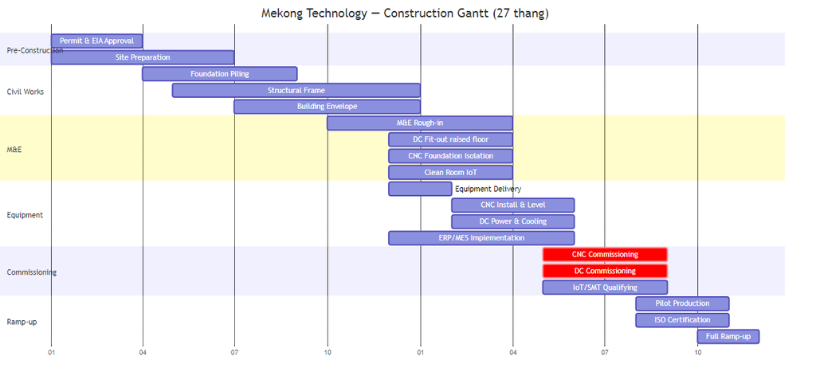

Diagram 78

### Y.3.2. Nhà thầu Dự kiến

| Hạng mục | Nhà thầu / Đơn vị | Budget (K) | Phương thức |
| --- | --- | --- | --- |
| **Thiết kế kiến trúc** | Arup / CPG (SG) / VN A-class | 200-350 | Design contest |
| **Thi công xây dựng** | Coteccons / Hòa Bình / Delta | 4.000-5.000 | Fixed-price tender |
| **M&E tổng thầu** | Schneider / Alpha ECC / Newtecons MEP | 3.000-4.000 | Design-Build |
| **PCCC** | SENKO / Hải Phòng Fire | 800-1.000 | Specialist sub |
| **IT Infrastructure** | FPT IS / CMC SI / NTT VN | 500-800 | Turnkey |
| **Quản lý dự án (PMC)** | Turner & Townsend / Arcadis VN | 300-500 | Fee-based |
| **Giám sát** | APAVE / TUV VN / Bureau Veritas | 100-200 | Inspection |
| **Tổng xây dựng Phase 1** |  | **~9.000-12.000** |  |

### Y.3.3. Chi phí Xây dựng Chi tiết

[output not shown]

## Y.4. Kiểm soát Chất lượng Xây dựng

### Y.4.1. QC Checkpoints

| Giai đoạn | Checkpoint | Tiêu chuẩn | Phương pháp | Pass Criteria |
| --- | --- | --- | --- | --- |
| **Cọc** | PDA test (5% cọc) | TCVN 9393 | Dynamic load test | Q ≥ Qdesign × 1,5 |
| **BTCT** | Cường độ mẫu | TCVN 4453 | Nén mẫu 28 ngày | ≥ 30 MPa (C30) |
| **Thép** | Mill cert + kiểm tra kích thước | TCVN 5575 | Caliper + tensile test | Theo spec |
| **Hàn** | 100% visual + 20% UT/MT | AWS D1.1 | Ultrasonic + Magnetic | No crack, no undercut |
| **Sàn CNC** | Độ phẳng | DIN 18202 | Floor flatness tester | FF50/FL30 (CNC area) |
| **Raised floor** | Load test | MOB/PSA/PF2 | 4-point bending | ≥ 12 kN concentrated |
| **Chống thấm** | 48h flood test | TCVN 5718 | Water ponding | 0 leak |
| **PCCC** | Nghiệm thu toàn bộ | QCVN 06 | PC07 kiểm tra | 100% pass |

*(Kết thúc Phụ lục Y — Chi tiết Xây dựng & Công trình)*

# PHỤ LỤC Z: MẪU HỢP ĐỒNG VÀ KHUNG PHÁP LÝ

## Z.1. Danh mục Hợp đồng Cần chuẩn bị

### Z.1.1. Ma trận Hợp đồng theo Giai đoạn

[output not shown]

### Z.1.2. Khung Điều khoản Chính — CNC Master Service Agreement (MSA)

| Điều khoản | Nội dung tiêu biểu |
| --- | --- |
| **Scope of Work** | CNC machining services per customer drawing/3D model |
| **Quality Standards** | ISO 9001, IATF 16949, AS9100D (as applicable) |
| **Pricing** | Per-part or MHR basis, annual review ±5% |
| **Payment Terms** | Net 30 days from invoice date, 2% discount for Net 10 |
| **Lead Time** | Standard: 15-20 working days; Express: 7-10 (+30% surcharge) |
| **IP Ownership** | Customer owns design IP; Mekong owns process know-how |
| **NDA** | Mutual NDA, 5-year term, ITAR compliance if applicable |
| **Warranty** | 12 months or 1 usage cycle, whichever first |
| **Liability Cap** | 100% of annual contract value |
| **Force Majeure** | Standard FM clause + pandemic + gov’t action |
| **Termination** | 90 days notice; immediate for material breach |
| **Dispute Resolution** | VIAC (Vietnam International Arbitration Center) |
| **Governing Law** | Vietnamese law |
| **ITAR/EAR** | Compliance statement for aerospace parts |

### Z.1.3. Khung Điều khoản — DC Colocation SLA

| Điều khoản | Platinum | Gold | Silver |
| --- | --- | --- | --- |
| **Uptime SLA** | 99,995% | 99,99% | 99,95% |
| **Max Downtime/năm** | 26 phút | 52 phút | 4,4 giờ |
| **Penalty per incident** | 5% MRC | 3% MRC | 2% MRC |
| **Penalty cap** | 25% MRC/tháng | 15% | 10% |
| **Response time (P1)** | 15 phút | 30 phút | 60 phút |
| **Power per rack** | 8-30 kW | 4-8 kW | 2-4 kW |
| **Bandwidth included** | 1 Gbps | 500 Mbps | 100 Mbps |
| **Remote hands** | Unlimited | 4h/tháng | 2h/tháng |
| **Contract term** | 3-5Y | 1-3Y | Monthly/1Y |
| **Deposit** | 1 month MRC | 2 months | 3 months |
| **Early termination** | Remaining × 50% | Remaining × 75% | N/A (monthly) |
| **Insurance required** | Customer provides | Customer provides | N/A |

## Z.2. Khung Tuân thủ Pháp lý

### Z.2.1. Checklist Tuân thủ Trước Vận hành

| # | Hạng mục | Cơ sở pháp lý | Trạng thái | Deadline |
| --- | --- | --- | --- | --- |
| 1 | IRC + ERC | Luật Đầu tư 2020 | ☐ | Q4/2025 |
| 2 | Hợp đồng thuê đất | Luật Đất đai 2024 | ☐ | Q4/2025 |
| 3 | Giấy phép xây dựng | Luật Xây dựng 2014 | ☐ | Q1/2026 |
| 4 | Phê duyệt ĐTM | Luật BVMT 2020 | ☐ | Q1/2026 |
| 5 | Phê duyệt PCCC thiết kế | Luật PCCC 2001 sửa đổi | ☐ | Q1/2026 |
| 6 | Nghiệm thu PCCC công trình | NĐ 136/2020 | ☐ | Q4/2026 |
| 7 | Giấy phép hoạt động điện | Luật Điện lực 2004 | ☐ | Q4/2026 |
| 8 | Giấy phép xả thải | Luật BVMT 2020 | ☐ | Q4/2026 |
| 9 | Đăng ký ATVSLĐ | Luật ATVSLĐ 2015 | ☐ | Q4/2026 |
| 10 | Giấy phép viễn thông | Luật Viễn thông 2023 | ☐ | Q4/2026 |
| 11 | Đăng ký NKTP/XKTP | Luật Hải quan 2014 | ☐ | Q4/2026 |
| 12 | Xác nhận ưu đãi KCNC | Luật CNC 2008, NĐ 13/2019 | ☐ | Q1/2027 |
| 13 | ISO 9001/14001/45001 | Tự nguyện (required by customers) | ☐ | Q3/2027 |
| 14 | IATF 16949 | Tự nguyện (auto customers) | ☐ | Q4/2028 |
| 15 | AS9100D | Tự nguyện (aero customers) | ☐ | Q2/2029 |

### Z.2.2. Bảng Luật Áp dụng

| # | Văn bản pháp luật | Năm | Liên quan tới |
| --- | --- | --- | --- |
| 1 | Luật Đầu tư 2020 (Luật số 61/2020/QH14) | 2020 | IRC, ưu đãi, thủ tục |
| 2 | Luật Doanh nghiệp 2020 (Luật số 59/2020/QH14) | 2020 | ERC, governance |
| 3 | Luật Công nghệ cao 2008 (Luật số 21/2008/QH12) | 2008 | Ưu đãi KCNC |
| 4 | Luật Xây dựng 2014 (Luật số 50/2014/QH13) sửa đổi 2020 | 2014/2020 | GPXD |
| 5 | Luật BVMT 2020 (Luật số 72/2020/QH14) | 2020 | ĐTM, GPMT |
| 6 | Luật PCCC 2001 sửa đổi 2013 + NĐ 136/2020 | 2001/2020 | PCCC |
| 7 | Luật ATVSLĐ 2015 (Luật số 84/2015/QH13) | 2015 | An toàn lao động |
| 8 | Luật Thuế TNDN 2008 sửa đổi + NĐ 218/2013 | 2008/2013 | CIT ưu đãi |
| 9 | Luật Đất đai 2024 (Luật số 31/2024/QH15) | 2024 | Thuê đất |
| 10 | Luật Sở hữu trí tuệ 2005 sửa đổi 2022 | 2005/2022 | Patent, trademark |
| 11 | Luật Viễn thông 2023 (Luật số 24/2023/QH15) | 2023 | License DC/ISP |
| 12 | Luật An ninh mạng 2018 | 2018 | Data localization |
| 13 | NĐ 13/2019 về DN KHCN | 2019 | Ưu đãi R&D |
| 14 | TT 38/2015 sửa đổi TT 39/2018 | 2015/2018 | Hải quan NK miễn thuế |
| 15 | QCVN 06:2021/BXD | 2021 | PCCC công trình |

### Z.2.3. VSIC Codes Đăng ký

| VSIC Code | Mô tả | BU liên quan |
| --- | --- | --- |
| **2562** | Gia công cơ khí, xử lý, tráng phủ kim loại | CNC |
| **2599** | Sản xuất sản phẩm khác từ kim loại | CNC |
| **2611** | Sản xuất linh kiện điện tử | IoT |
| **2620** | Sản xuất máy vi tính và thiết bị ngoại vi | IoT |
| **2829** | Sản xuất máy chuyên dụng khác | Robot |
| **6311** | Xử lý dữ liệu, cho thuê và hoạt động liên quan | DC |
| **6202** | Tư vấn máy vi tính và quản trị hệ thống | IoT/DC |

*(Kết thúc Phụ lục Z — Mẫu Hợp đồng & Khung Pháp lý)*

# PHỤ LỤC AA: CHUỖI CUNG ỨNG VÀ MUA SẮM (SUPPLY CHAIN & PROCUREMENT)

## AA.1. Chiến lược Mua sắm Tổng thể

### AA.1.1. Nguyên tắc Procurement

| Nguyên tắc | Mô tả | Áp dụng |
| --- | --- | --- |
| **Dual sourcing** | Mỗi danh mục ≥ 2 nhà cung cấp qualified | Tất cả vật tư > 10K USD/năm |
| **Total Cost of Ownership (TCO)** | Giá mua + Vận hành + Bảo trì + Disposal | Thiết bị > 50K USD |
| **Local preference** | Ưu tiên NCC nội địa nếu đạt spec (giảm lead time + miễn thuế NK) | Vật tư tiêu hao, xây dựng |
| **Strategic partnership** | Hợp tác dài hạn, volume commitment → giảm giá 5-15% | Phôi CNC, PCB, IC components |
| **Compliance** | NCC phải đạt ISO 9001 (tối thiểu); ưu tiên IATF 16949 / AS9100 | CNC materials |
| **Sustainability** | Ưu tiên NCC có chứng nhận ISO 14001, conflict-free minerals | ESG requirement cho FDI clients |

### AA.1.2. Phân loại NCC theo Mô hình Kraljic

[figure not shown]

Diagram 79

## AA.2. Danh mục Nhà cung cấp Chiến lược

### AA.2.1. Thiết bị CNC (Khối B)

| STT | Danh mục | NCC Chính | NCC Dự phòng | Lead Time | Điều khoản TT | Ghi chú |
| --- | --- | --- | --- | --- | --- | --- |
| 1 | CNC 5-axis (8 máy) | DMG Mori (Japan/Germany) | Mazak (Japan) | 16-24 tuần | 30% advance, 70% L/C at sight | FOB Japan, thuế NK 0% (DA KCNC) [C] |
| 2 | CNC 3-axis (12 máy) | Mazak (Japan) | Haas (USA) | 12-18 tuần | 30/70 L/C | FOB, giá 80-250K/máy |
| 3 | CNC Turning (4 máy) | Doosan (Korea) | Mazak (Japan) | 10-14 tuần | 30/70 L/C |  |
| 4 | CNC Wire EDM (2 máy) | Mitsubishi (Japan) | Sodick (Japan) | 12-16 tuần | L/C 60 days |  |
| 5 | CNC Swiss-type (2 máy) | Citizen (Japan) | Star (Japan) | 14-20 tuần | L/C | Cho chi tiết y tế |
| 6 | CMM (2 máy) | Hexagon (Sweden) | Zeiss (Germany) | 10-14 tuần | 50/50 | Accuracy ≤ 1,5 + L/300 µm |
| 7 | Roughness Tester | Mitutoyo (Japan) | — | 4-6 tuần | COD/TT | Surftest SJ-210 |
| 8 | Hardness Tester | Mitutoyo (Japan) | — | 4-6 tuần | COD/TT | HR-530 |
| 9 | Dụng cụ cắt (Tooling) | Sandvik Coromant | Kennametal / Iscar | 2-4 tuần | Net 30 days | Buffer stock 90 ngày |
| 10 | Coolant (MWF) | Blaser Swisslube | Fuchs | 2-4 tuần | Net 30 | B-Cool 755 (low mist) |
| 11 | Dầu hydraulic / way oil | Shell Tellus / Mobil DTE | Total | 1-2 tuần | Net 30 | Tồn kho 60 ngày |

### AA.2.2. Vật tư CNC (Phôi)

| STT | Loại phôi | Spec tiêu biểu | NCC nội địa | NCC quốc tế | Giá tham khảo | Volume/năm |
| --- | --- | --- | --- | --- | --- | --- |
| 1 | Nhôm 6061-T6 | Ø20-200mm, tấm 5-50mm | Nhôm Đông Anh | Alcoa (USA) | 3,0-3,5 USD/kg | ~50 tấn |
| 2 | Nhôm 7075-T6 | Ø30-150mm | — | Aleris (EU), Kobe Steel (JP) | 5,0-6,0 USD/kg | ~15 tấn |
| 3 | Thép SS 304/316 | Ø20-150mm, tấm | POSCO Việt Nam | POSCO (KR) | 3,5-5,0 USD/kg | ~30 tấn |
| 4 | Thép SKD61/SKD11 | Block, round bar | Daido (JP) | Daido, Hitachi Metals | 8-12 USD/kg | ~10 tấn |
| 5 | Titanium Ti-6Al-4V | Ø20-100mm | — | TIMET (USA), VSMPO (RU) | 30-50 USD/kg | ~2 tấn |
| 6 | Đồng C101/C110 | Ø10-80mm | Đồng Việt | Mitsubishi Materials | 8-10 USD/kg | ~5 tấn |
| 7 | Nhựa kỹ thuật (POM, PEEK) | Rod, sheet | — | Ensinger (DE) | 15-300 USD/kg | ~2 tấn |

> **[C] Chi phí phôi ước tính Y1: 400-600K USD; Y5 (full capacity): 1.200-1.800K USD.** Chiến lược: ký hợp đồng blanket order 6 tháng với NCC chính để lock giá phôi nhôm/thép trong bối cảnh biến động giá kim loại.

### AA.2.3. Thiết bị IoT/SMT (Khối C)

| STT | Danh mục | NCC | Lead Time | CAPEX (K USD) | Ghi chú |
| --- | --- | --- | --- | --- | --- |
| 1 | SMT Pick & Place | Fuji NXT III / Yamaha YSM20R | 12-16 tuần | 250-450 | Tốc độ 40K-80K CPH |
| 2 | Solder Paste Printer | DEK / MPM | 8-12 tuần | 40-80 |  |
| 3 | Reflow Oven | Heller 1913 MK7 | 8-12 tuần | 60-100 | 13 zones, N₂ capability |
| 4 | AOI (Automated Optical Inspection) | Koh Young / Yamaha | 8-12 tuần | 80-150 | 3D AOI, AI-powered |
| 5 | Wave Solder (for THT) | ERSA / Vitronics | 8-12 tuần | 30-50 |  |
| 6 | X-Ray (BGA inspection) | Nordson DAGE | 10-14 tuần | 60-100 | Micro-focus |
| 7 | ICT / FCT Tester | Keysight / National Instruments | 6-10 tuần | 40-80 | Custom fixtures |
| 8 | Conformal Coating | Nordson Asymtek | 6-8 tuần | 20-30 | Selective coating |
| 9 | Stencil Laser Cut | Custom per BOM | 1-2 tuần | 0,5-1 per stencil | Multiple vendors |

### AA.2.4. Thiết bị Datacenter (Khối A)

| STT | Danh mục | NCC | Lead Time | CAPEX/unit (K USD) | Số lượng | Ghi chú |
| --- | --- | --- | --- | --- | --- | --- |
| 1 | Server Rack (42U, 800mm) | Rittal / Chatsworth CPI | 6-8 tuần | 1,2-2,0 | 100 | Perforated door, 10kW/rack |
| 2 | PDU (intelligent, per-outlet metering) | Schneider / Raritan | 4-6 tuần | 0,5-1,5 | 200 | Dual PDU per rack |
| 3 | UPS 2N (Modular) | Schneider Galaxy VX | 12-16 tuần | 150-250 (per string) | 4 | 2 × 300 kVA per string |
| 4 | Battery (Li-ion) | Samsung SDI / CATL | 12-16 tuần | 80-120 (per string) | 4 | 15 min at full load |
| 5 | CRAC (InRow) | Schneider / Vertiv | 8-12 tuần | 25-35 | 10 | 60 kW each |
| 6 | Chiller | Daikin / Trane | 10-14 tuần | 80-120 | 4 | 250 kW each |
| 7 | Generator (N+1) | Cummins / Caterpillar | 12-18 tuần | 80-120 | 4 | 750 kVA each, SCR/DPF |
| 8 | ATS (Automatic Transfer Switch) | ASCO / ABB | 6-8 tuần | 8-15 | 4 | ≤ 10s transfer |
| 9 | Fire Suppression (NOVEC 1230) | Kidde / Fike | 6-8 tuần | 20-35 per zone | 6 zones | Clean agent |
| 10 | Structured Cabling (Cat6A + OM4) | CommScope / Panduit | 4-6 tuần | 30-50 (lot) | 1 |  |

## AA.3. Quản lý Tồn kho và Logistics

### AA.3.1. Phân loại Tồn kho theo ABC–XYZ

| Phân loại | Đặc điểm | Ví dụ | Chính sách |
| --- | --- | --- | --- |
| **AX** | Giá trị cao, nhu cầu ổn định | Phôi nhôm 6061, coolant | JIT, blanket order, EOQ optimize |
| **AY** | Giá trị cao, nhu cầu biến động | Titanium, Inconel | Safety stock 90 ngày, forward contract |
| **AZ** | Giá trị cao, nhu cầu không dự báo | Dụng cụ đặc biệt, phôi prototype | MTO (Make-to-Order), không tồn kho |
| **BX** | Giá trị trung bình, ổn định | IC components, PCB | Min-Max, reorder point |
| **BY** | Giá trị trung bình, biến động | Dụng cụ cắt (insert, drill) | Safety stock 60 ngày |
| **CX** | Giá trị thấp, ổn định | Ốc vít, bao bì, dầu | Kanban, vendor-managed inventory |

### AA.3.2. KPI Tồn kho

| KPI | Mục tiêu Y1 | Mục tiêu Y3 | Mục tiêu Y5 |
| --- | --- | --- | --- |
| **Inventory Turnover** | 6× | 8× | 10× |
| **Days of Inventory Outstanding (DIO)** | 60 ngày | 45 ngày | 36 ngày |
| **Stockout Rate** | < 5% | < 2% | < 1% |
| **Dead Stock (% tổng)** | < 3% | < 2% | < 1% |
| **Inventory Accuracy** | 95% | 98% | 99,5% |
| **Giá trị tồn kho (K USD)** | 800-1.200 | 1.000-1.500 | 1.200-1.800 |

### AA.3.3. Logistics Inbound

| Tuyến | Phương thức | Thời gian | Tần suất | Ghi chú |
| --- | --- | --- | --- | --- |
| **Japan → VN** | Sea freight (FCL/LCL) | 10-15 ngày | 2 lần/tháng | CNC machines, tooling |
| **Japan → VN** | Air freight (urgent) | 3-5 ngày | As needed | Spare parts khẩn |
| **Korea → VN** | Sea freight | 7-12 ngày | 2 lần/tháng | Phôi thép POSCO |
| **EU (Germany/Sweden) → VN** | Sea freight | 25-35 ngày | 1 lần/tháng | CMM, precision tools |
| **USA → VN** | Sea freight | 20-30 ngày | 1 lần/tháng | Haas machines |
| **Nội địa** | Truck | 1-3 ngày | Weekly | Phôi nhôm Đông Anh |
| **Nội địa (TPHCM)** | Truck | Same day | Daily | Consumables |

### AA.3.4. Kho Vật tư — Thiết kế

| Khu vực | Diện tích (m²) | Nhiệt độ | Chức năng |
| --- | --- | --- | --- |
| **Kho phôi kim loại** | 300 | < 35°C, khô ráo | Rack 3 tầng cho bar stock + sheet |
| **Kho dụng cụ cắt** | 80 | Điều hòa 22-25°C | Tool cabinet (Garant / Kennametal), humidity < 60% |
| **Kho hóa chất** | 50 | Thông gió + PCCC đặc biệt | Coolant, dầu, dung môi — tách biệt |
| **Kho linh kiện IoT** | 100 | 22-25°C, ESD protected | IC, PCB, components — moisture barrier bag |
| **Kho thành phẩm** | 200 | 22-25°C, ESD nếu cần | Ready-to-ship area |
| **Receiving area** | 100 | Có mái che | Dock leveler, QC incoming |
| **Kho phế liệu** | 60 | Ngoài trời (mái che) | Phoi CNC, scrap metal → tái chế |
| **Tổng kho** | **~890 m²** |  |  |

## AA.4. Quy trình Mua hàng (Procurement Process)

### AA.4.1. Sơ đồ Quy trình

| Bước | Hoạt động | Phụ trách | SLA | Hệ thống |
| --- | --- | --- | --- | --- |
| 1 | Yêu cầu mua hàng (PR) | Bộ phận sử dụng | Ngay | ERP |
| 2 | Xét duyệt PR | Quản lý bộ phận → Procurement Manager | ≤ 2 ngày | ERP workflow |
| 3 | RFQ gửi NCC (≥ 3 NCC cho > 10K USD) | Procurement | ≤ 3 ngày | Email / Portal |
| 4 | So sánh báo giá + TCO analysis | Procurement | ≤ 5 ngày | Evaluation matrix |
| 5 | Phê duyệt PO | CFO (> 50K) / CEO (> 200K) | ≤ 2 ngày | ERP |
| 6 | Đặt hàng (PO) | Procurement | ≤ 1 ngày | ERP → NCC |
| 7 | Theo dõi giao hàng | Procurement + Logistics | Weekly | Dashboard |
| 8 | Nhận hàng + IQC (Incoming Quality Control) | Warehouse + QC | ≤ 2 ngày | ERP + QMS |
| 9 | Nhập kho | Warehouse | Same day | ERP |
| 10 | Thanh toán | Finance | Theo hợp đồng | ERP → Bank |

### AA.4.2. Ma trận Thẩm quyền Phê duyệt

| Giá trị PO (USD) | Người phê duyệt | Yêu cầu bổ sung |
| --- | --- | --- |
| < 5.000 | Department Manager | 1 báo giá |
| 5.000 — 50.000 | Procurement Manager + CFO | ≥ 3 báo giá |
| 50.000 — 200.000 | CFO + CEO | ≥ 3 báo giá + TCO |
| > 200.000 | CEO + Board approval | ≥ 3 báo giá + TCO + NCC audit |

## AA.5. Đánh giá Nhà cung cấp (Supplier Scorecard)

| Tiêu chí | Trọng số | Thang điểm | Ghi chú |
| --- | --- | --- | --- |
| **Quality (PPM defect rate)** | 30% | < 100 PPM = 5, 100-500 = 3, > 500 = 1 | Đo hàng quý |
| **Delivery (OTD — On-Time Delivery)** | 25% | > 95% = 5, 85-95% = 3, < 85% = 1 | Đo hàng quý |
| **Cost competitiveness** | 20% | Best price = 5, ±5% = 3, > +10% = 1 | So sánh market |
| **Responsiveness** | 10% | < 24h reply = 5, < 72h = 3, > 72h = 1 |  |
| **Certifications (ISO/IATF)** | 10% | IATF = 5, ISO 9001 = 3, No cert = 0 |  |
| **Sustainability (ESG)** | 5% | ISO 14001 + RoHS = 5 | Yêu cầu từ FDI clients |

**Ngưỡng:** - Score ≥ 4,0: **Preferred supplier** — volume commitment, ưu tiên PO - Score 3,0-3,9: **Approved supplier** — sử dụng bình thường - Score 2,0-2,9: **Probation** — Corrective Action Request (CAR), re-audit 90 ngày - Score < 2,0: **Disqualified** — chuyển sang NCC dự phòng

*(Kết thúc Phụ lục AA — Chuỗi Cung ứng & Mua sắm)*

# PHỤ LỤC BB: HỌC VIỆN ĐÀO TẠO VÀ QUẢN LÝ TRI THỨC (TRAINING ACADEMY & KNOWLEDGE MANAGEMENT)

## BB.1. Chiến lược Đào tạo Tổng thể

### BB.1.1. Mô hình 70-20-10

| Phương pháp | Tỷ trọng | Hình thức | Ví dụ |
| --- | --- | --- | --- |
| **Học từ thực hành (OJT)** | 70% | On-the-job, mentoring, project-based | Vận hành máy CNC dưới sự hướng dẫn senior |
| **Học từ đồng nghiệp** | 20% | Coaching, peer review, community of practice | Knowledge sharing sessions hàng tuần |
| **Đào tạo chính quy** | 10% | Classroom, e-learning, certification | Khóa Mastercam/NX, AWS, PMP |

### BB.1.2. Ngân sách Đào tạo

[output not shown]

> **[B] Benchmark:** Samsung Việt Nam chi ~2% revenue cho đào tạo; Bosch ~1,5%. Target Mekong: 1,0-2,0% sau giai đoạn đầu tư ban đầu.

## BB.2. Chương trình Đào tạo theo Khối

### BB.2.1. CNC Operator / Programmer Training Path

| Cấp độ | Thời gian | Nội dung | Đánh giá | Chứng chỉ | Lương (triệu VND) |
| --- | --- | --- | --- | --- | --- |
| **Level 1: CNC Operator** | 3 tháng | An toàn LĐ, đọc bản vẽ, setup máy 3-axis, đo kiểm cơ bản | Thi thực hành (setup + run 5 parts) | Internal L1 | 10-13 |
| **Level 2: CNC Setter** | 6 tháng (sau L1) | Multi-setup, tool life mgmt, SPC basics, problem solving | Thực hành: chạy 3 job phức tạp, Cpk ≥ 1,33 | Internal L2 | 13-17 |
| **Level 3: CNC Programmer** | 12 tháng (sau L2) | CAM programming (Mastercam/NX), fixture design, cycle time optimize | Lập trình + chạy 5-axis part từ bản vẽ | Internal L3 + Mastercam Cert | 17-23 |
| **Level 4: Senior Programmer** | 24 tháng (sau L3) | Multi-axis complex, macro programming, post-processor customize | Dự án tối ưu hóa (giảm ≥ 15% cycle time) | Mastercam Advanced Cert | 23-30 |
| **Level 5: CNC Process Engineer** | 36+ tháng (sau L4) | Process planning, new material development, FMEA, PPAP | Lead NPI project, qualify new material | Six Sigma Green Belt | 30-40 |

### BB.2.2. IoT/Embedded Engineer Training Path

| Cấp độ | Thời gian | Nội dung | Đánh giá | Chứng chỉ |
| --- | --- | --- | --- | --- |
| **L1: Junior Embedded** | 3 tháng | C/C++, RTOS, GPIO/UART/SPI/I2C, schematics reading | Code review + demo project | Internal |
| **L2: Embedded Developer** | 9 tháng (sau L1) | BLE/WiFi/LoRa stack, power optimization, DFM/DFT, PCB review | Ship 1 firmware release | PSoC/STM32 Cert |
| **L3: Senior Embedded** | 18 tháng (sau L2) | Architecture design, security (TLS/DTLS), OTA, FOTA, CI/CD | Lead module development | AWS IoT Core Cert |
| **L4: IoT Architect** | 30+ tháng (sau L3) | System architecture, cloud integration, ML@edge, patent filing | Design product from concept to mass production | AWS SA Professional |

### BB.2.3. Datacenter Operations Training Path

| Cấp độ | Thời gian | Nội dung | Đánh giá | Chứng chỉ |
| --- | --- | --- | --- | --- |
| **L1: DC Technician** | 3 tháng | DCIM basics, cabling, rack & stack, physical security | Hands-on assessment | CompTIA Server+ |
| **L2: DC Engineer** | 9 tháng (sau L1) | M&E systems, UPS/Generator, HVAC, fire suppression, monitoring | Incident response drill | CDCP (Certified DC Professional) |
| **L3: Senior DC Engineer** | 18 tháng (sau L2) | Capacity planning, PUE optimization, DR planning, vendor management | Lead facility upgrade project | CDCS (Certified DC Specialist) |
| **L4: DC Manager** | 30+ tháng (sau L3) | SLA management, client relations, CAPEX planning, compliance audits | Manage NOC team, achieve 99,995% uptime | CDFOM (EPI) |

## BB.3. Chương trình Đào tạo Chuyên sâu (Specialized Training)

### BB.3.1. Chất lượng (Quality)

| Khóa học | Đối tượng | Thời lượng | Nội dung | Nhà cung cấp | Chi phí (USD/người) |
| --- | --- | --- | --- | --- | --- |
| **Core Tools (FMEA, MSA, SPC, PPAP, APQP)** | QC/QA, Process Engineer | 40 giờ | AIAG Core Tools 2019 | BSI / TUV | 500-800 |
| **GD&T (ASME Y14.5)** | CNC Programmer, QC | 24 giờ | Geometric Dimensioning & Tolerancing | ETI / Internal | 300-500 |
| **Six Sigma Green Belt** | Process Engineer, Manager | 80 giờ | DMAIC methodology, Minitab | ASQ accredited | 1.500-2.500 |
| **Six Sigma Black Belt** | Senior Engineer, Director | 160 giờ | Advanced statistics, DOE, Lean Six Sigma | ASQ accredited | 3.000-5.000 |
| **ISO 9001:2015 Internal Auditor** | QMS team | 24 giờ | Audit planning, execution, reporting | BSI / Bureau Veritas | 300-500 |
| **IATF 16949 Awareness** | All CNC staff | 8 giờ | Automotive quality requirements | TUV | 200-300 |
| **IPC-A-610 Inspector** | IoT QC | 32 giờ | Acceptability of Electronic Assemblies | IPC trainer | 500-800 |

### BB.3.2. An toàn và Môi trường (EHS)

| Khóa học | Đối tượng | Thời lượng | Tần suất | Bắt buộc? |
| --- | --- | --- | --- | --- |
| **Huấn luyện ATVSLĐ nhóm 1** | CEO, Directors | 16 giờ | 2 năm/lần | Bắt buộc (Luật ATVSLĐ) |
| **Huấn luyện ATVSLĐ nhóm 3** | Operators, Technicians | 16 giờ | Hàng năm | Bắt buộc |
| **Huấn luyện ATVSLĐ nhóm 4** | All staff | 16 giờ | Hàng năm | Bắt buộc |
| **PCCC cơ bản** | All staff | 8 giờ | Hàng năm | Bắt buộc |
| **PCCC chuyên sâu (DC)** | DC team | 16 giờ | Hàng năm | Bắt buộc |
| **Ứng phó sự cố hóa chất** | CNC team, Warehouse | 8 giờ | Hàng năm | Bắt buộc |
| **ESD Awareness** | IoT team | 4 giờ | Hàng năm | Bắt buộc |
| **Ergonomics** | CNC operators | 4 giờ | Hàng năm | Khuyến khích |
| **First Aid / CPR** | 10% staff (ERT team) | 16 giờ | 2 năm/lần | Bắt buộc |

## BB.4. Quan hệ Đối tác Đào tạo (Training Partnerships)

| Đối tác | Lĩnh vực | Hình thức | Chi tiết |
| --- | --- | --- | --- |
| **ĐH Bách khoa TPHCM (HCMUT)** | CNC, Cơ khí, IoT | Internship program, capstone project, adjunct faculty | 10-15 interns/năm, 2-3 capstone/năm |
| **ĐH Công nghệ TPHCM (HUTECH)** | IoT, Embedded | Dual education, Lab sponsorship | Lab MekongIoT tại HUTECH |
| **Trường CĐ Kỹ thuật Cao Thắng** | CNC Operator | Apprenticeship 12 tháng | 5-10 apprentices/năm |
| **FPT Polytechnic** | IT Infrastructure, Network | Training pipeline | Tuyển 5-8 DC technicians/năm |
| **Siemens / Fanuc / Mazak** | CNC, CAD/CAM | Vendor training at factory | Khi mua máy: 5-10 ngày training included |
| **AWS / Microsoft** | Cloud, IoT, AI | Online certification + lab credit | AWS re:Start program |
| **BSI / TUV** | Quality, EHS | Certification training | On-site training negotiated |

### BB.4.1. Chương trình Học bổng Mekong

| Hạng mục | Chi tiết |
| --- | --- |
| **Đối tượng** | SV năm 3-4, chuyên ngành Cơ khí/Điện tử/CNTT |
| **Số lượng** | 10-15 suất/năm |
| **Giá trị** | 20.000.000 VND/suất + cam kết thực tập 6 tháng |
| **Ràng buộc** | Nếu tuyển dụng sau tốt nghiệp: cam kết 2 năm, hoàn học bổng nếu rời sớm |
| **Ngân sách** | ~10K USD/năm |
| **Mục tiêu** | Pipeline 60-70% chuyển thành nhân viên chính thức |

## BB.5. Hệ thống Quản lý Tri thức (Knowledge Management System)

### BB.5.1. Nền tảng KMS

| Thành phần | Công cụ | Chức năng | Chi phí (K USD/năm) |
| --- | --- | --- | --- |
| **Wiki nội bộ** | Confluence (Atlassian) | SOPs, WI, lessons learned, technical notes | 3-5 |
| **LMS (Learning Management System)** | Moodle (self-hosted) hoặc TalentLMS | E-learning, quiz, certification tracking | 2-5 |
| **Document Management** | SharePoint (M365) | Controlled documents, revision management | Included in M365 |
| **Video Library** | Internal server + OBS Studio | Training videos, machine setup guides | 1-2 (storage) |
| **Skill Matrix Database** | Custom (or SkillsBase SaaS) | Competency tracking per employee | 1-3 |

### BB.5.2. Tài liệu Kỹ thuật Chuẩn hóa

| Loại tài liệu | Mã | Ví dụ | Người viết | Người duyệt | Review cycle |
| --- | --- | --- | --- | --- | --- |
| **SOP (Standard Operating Procedure)** | SOP-CNC-xxx | SOP-CNC-001: Setup CNC 5-axis DMG | Process Engineer | Quality Manager | 12 tháng |
| **WI (Work Instruction)** | WI-CNC-xxx | WI-CNC-042: Đo hardness HRC trên Mitutoyo | Operator/Technician | Supervisor | 12 tháng |
| **One Point Lesson (OPL)** | OPL-xxx | OPL-015: Cách nhận biết tool wear trên insert | Senior Operator | Không cần | 24 tháng |
| **Lesson Learned** | LL-yyyy-xxx | LL-2026-003: Root cause chatter trên 7075 face milling | Anyone | Technical Lead | Permanent |
| **Technical Standard** | TS-xxx | TS-012: Surface finish requirements per material | Engineering | Quality + Client | 24 tháng |

### BB.5.3. Chỉ số KM

| KPI | Mục tiêu Y1 | Mục tiêu Y3 | Mục tiêu Y5 |
| --- | --- | --- | --- |
| **Số SOP/WI được chuẩn hóa** | 50 | 200 | 400 |
| **E-learning courses available** | 10 | 40 | 80 |
| **Training hours/người/năm** | 80 | 60 | 50 |
| **Certification rate (% staff có chứng chỉ chuyên môn)** | 30% | 50% | 70% |
| **Knowledge contribution (bài viết wiki/tháng)** | 5 | 20 | 40 |
| **OPL submitted/tháng** | 2 | 8 | 15 |
| **Skill matrix completion** | 80% | 95% | 100% |

## BB.6. Lộ trình Triển khai KMS

| Phase | Thời gian | Hoạt động | Output |
| --- | --- | --- | --- |
| **Phase 1** | M1-M3 | Setup Confluence + SharePoint, skill matrix template, identify critical SOPs | 20 SOPs, wiki live |
| **Phase 2** | M4-M6 | LMS setup (Moodle), video recording CNC setup, first e-learning courses | 5 e-learning modules |
| **Phase 3** | M7-M12 | Full SOP library for CNC (50 SOPs), IoT (20 WIs), DC (20 SOPs) | 90 documents |
| **Phase 4** | Y2 | Advanced e-learning, vendor training integration, certification tracking | LMS fully integrated |
| **Phase 5** | Y3+ | AI-assisted search (RAG on knowledge base), auto-translation (VN ↔︎ EN ↔︎ JP) | Smart KMS |

*(Kết thúc Phụ lục BB — Học viện Đào tạo & Quản lý Tri thức)*

# PHỤ LỤC CC: HỆ THỐNG QUẢN LÝ CHẤT LƯỢNG TÍCH HỢP (INTEGRATED QMS)

## CC.1. Lộ trình Chứng nhận Chất lượng

### CC.1.1. Roadmap 5 năm

[output not shown]

### CC.1.2. Hệ thống Quản lý Tích hợp (IMS — Integrated Management System)

[figure not shown]

Diagram 80

## CC.2. Core Tools (IATF 16949 Requirement)

### CC.2.1. APQP — Advanced Product Quality Planning

| Phase | Tên | Hoạt động chính | Output | Thời gian |
| --- | --- | --- | --- | --- |
| 1 | Plan & Define | Voice of Customer, benchmarking, preliminary BOM | Design Goals, Reliability Goals | 2-4 tuần |
| 2 | Product Design | DFMEA, DV Testing, design review, prototype | DFMEA, Drawing release, DVP&R | 4-8 tuần |
| 3 | Process Design | PFMEA, process flow, floor plan, MSA plan | PFMEA, Control Plan (prototype), floor plan | 4-8 tuần |
| 4 | Product & Process Validation | Production trial run, MSA, SPC initial study, PPAP submission | PPAP package (18 elements), Cpk ≥ 1,67 initial | 4-8 tuần |
| 5 | Feedback & Corrective Action | Launch, lessons learned, continuous improvement | Warranty data, reduced variation | Ongoing |

### CC.2.2. PPAP — Production Part Approval Process (18 Elements)

| # | Element | Mô tả | Trách nhiệm | Level 3 submit? |
| --- | --- | --- | --- | --- |
| 1 | Design Records | Bản vẽ kỹ thuật approved | Engineering | Có |
| 2 | Engineering Change Documents | ECN/ECR nếu có | Engineering | Có |
| 3 | Customer Engineering Approval | Nếu yêu cầu | Engineering | Nếu có |
| 4 | Design FMEA | Phân tích rủi ro thiết kế | Engineering | Có |
| 5 | Process Flow Diagram | Sơ đồ quy trình sản xuất | Process Eng. | Có |
| 6 | Process FMEA | Phân tích rủi ro quy trình | Process Eng. | Có |
| 7 | Control Plan | Kế hoạch kiểm soát sản xuất | Quality | Có |
| 8 | MSA (Measurement System Analysis) | GR&R, Bias, Linearity | Quality | Có |
| 9 | Dimensional Results | Đo kiểm toàn bộ kích thước (CMM report) | Quality | Có — Full Layout |
| 10 | Material/Performance Test | Hardness, tensile, chem. analysis — cert. | Quality + Lab | Có |
| 11 | Initial Process Study (SPC) | Cpk ≥ 1,67 trên đặc tính Critical | Quality | Có |
| 12 | Qualified Lab Documentation | Chứng nhận ISO 17025 nếu outsource; scope nội bộ | Quality | Có |
| 13 | Appearance Approval Report (AAR) | Nếu có yêu cầu bề mặt | Quality | Nếu có |
| 14 | Sample Production Parts | 300 pcs minimum run | Production | Có — gửi mẫu |
| 15 | Master Sample | 1 mẫu lưu trữ, seal + label | Quality | Có |
| 16 | Checking Aids | Fixture, gauge, go-no-go | Quality | Có |
| 17 | Customer-Specific Requirements | Per customer added requirements | Quality | Nếu có |
| 18 | Part Submission Warrant (PSW) | Summary + sign-off | Quality Manager | Có — ký duyệt |

### CC.2.3. PFMEA — Process FMEA Template (Ví dụ: CNC 5-axis Milling)

| Process Step | Failure Mode | Effect | Sev. | Cause | Occ. | Current Control | Det. | **RPN** | Action |
| --- | --- | --- | --- | --- | --- | --- | --- | --- | --- |
| Workpiece clamping | Lệch tâm (misalignment) | Kích thước OOT, scrap | 8 | Fixture wear, contamination | 4 | Visual check + indicator | 5 | **160** | Add dial indicator check ±0,02mm |
| Tool loading | Sai tool số (wrong insert) | Surface finish NG, rework | 6 | Manual error | 3 | Tool sheet verify | 4 | **72** | Barcode scan on tool holder |
| 5-axis milling | Chatter / rung | Surface NG, tool break | 7 | Speed/feed incorrect, tool overhang | 3 | Operator listen + visual | 6 | **126** | Vibration sensor auto-stop |
| Coolant flow | Coolant thiếu/tắc | Tool overheating → break | 8 | Nozzle clogged, pump fail | 3 | Flow sensor alarm | 3 | **72** | Preventive clean weekly |
| In-process check | Bỏ qua đo kiểm | Defect parts to next op | 9 | Operator skip check | 2 | eSOP mandatory scan | 3 | **54** | MES enforcement |
| Deburring | Bavia còn lại | Customer complaint | 5 | Manual deburring miss | 4 | Visual 100% | 5 | **100** | Add tactile gauge check |
| CMM measurement | Đo sai (env. temp shift) | False PASS → defect ship | 9 | Temp ≠ 20°C | 2 | Temp log every 2h | 3 | **54** | Auto-compensate + reject if ΔT > 1°C |
| Packaging | Scratch / dent | Customer complaint, rework | 6 | Insufficient protection | 3 | Visual check | 4 | **72** | Custom VCI + foam insert |

> **RPN Threshold: > 100 → Corrective Action Required.** Target: Reduce all RPN < 100 within 6 months of production start.

## CC.3. Hệ thống Đo lường và Kiểm tra (Metrology & Inspection)

### CC.3.1. Phòng Đo CMM Clean Room

| Thông số | Yêu cầu | Ghi chú |
| --- | --- | --- |
| **Diện tích** | 60-80 m² | Tách biệt khỏi workshop |
| **Nhiệt độ** | 20 ± 0,5 °C (ISO 1:2016) | Precision AHU (Stulz CyberAir) |
| **Humidity** | 45-55% RH | Dehumidifier integrated |
| **Rung động** | VC-A (< 50 µm/s @ 1-80Hz) | Anti-vibration pad / isolated foundation |
| **Bụi** | ISO 14644 Class 7 (≤ 352.000 particles ≥ 0,5µm/m³) | HEPA H13 filtered supply |
| **Ánh sáng** | ≥ 500 lux, CRI > 80 | LED panel, no direct sunlight |
| **Sàn** | Anti-static epoxy + damping | ESD protection + vibration isolation |
| **Access** | Restricted, badge + gown + shoe cover | Airlock entry |

### CC.3.2. Thiết bị Đo kiểm Chi tiết

| STT | Thiết bị | Hãng | Model | Accuracy | CAPEX (K USD) | Số lượng | Tổng (K USD) |
| --- | --- | --- | --- | --- | --- | --- | --- |
| 1 | CMM (Bridge type) | Hexagon | Global S Chrome 9.15.9 | 1,5 + L/300 µm | 150-200 | 2 | 350 |
| 2 | CMM Software | Hexagon | PC-DMIS 2024 | — | 8-15 | 2 license | 20 |
| 3 | Surface Roughness Tester | Mitutoyo | Surftest SJ-210 | 0,01 µm resolution | 3-5 | 2 | 8 |
| 4 | Hardness Tester (Rockwell) | Mitutoyo | HR-530 | ±0,5 HRC | 8-12 | 1 | 10 |
| 5 | Profile Projector | Mitutoyo | PJ-A3000 | 10 µm | 5-8 | 1 | 7 |
| 6 | Height Gauge (Digital) | Mitutoyo | QM-Height 600 | 1,1 µm | 3-5 | 2 | 8 |
| 7 | Bore Gauge Set | Mitutoyo | Holtest 568 series | 3-5 µm | 2-3 | 3 sets | 8 |
| 8 | Micrometer Set (0-150mm) | Mitutoyo | Digimatic 293 | 1 µm | 0,5-1 | 10 | 8 |
| 9 | Caliper Digital (0-300mm) | Mitutoyo | ABS Digimatic 500 | 20 µm | 0,2-0,4 | 20 | 6 |
| 10 | Go/No-Go Gauge (custom) | Custom | Per drawing | Per spec | 0,5-2 | 50 sets | 50 |
| 11 | Thread Gauge Set | Mitutoyo / SPI | Metric + UNC/UNF | Class 6g/6H | 0,1-0,3 | 20 sets | 5 |
| 12 | Gauge Block Set (Grade 1) | Mitutoyo | BM1-112-1 | ISO 3650 Grade 1 | 2-4 | 2 | 6 |
| 13 | Optical Flat | — | λ/4 flatness | Interference fringe | 0,5-1 | 2 | 1,5 |
| 14 | CMM Stylus Kit | Renishaw | Assorted | — | 1-2 | lot | 2 |
| 15 | Calibration Equipment | Various | Gauge blocks, ring gauges | Reference std. | 5-10 | lot | 8 |
|  | **Tổng QA/QC Equipment** |  |  |  |  |  | **~498** |

### CC.3.3. Kế hoạch Hiệu chuẩn (Calibration Schedule)

| Thiết bị | Chu kỳ | Tiêu chuẩn | Đơn vị hiệu chuẩn | Chi phí/lần (USD) |
| --- | --- | --- | --- | --- |
| CMM | 12 tháng | ISO 10360-2 | Hexagon Service Center (VN) hoặc QUATEST 3 | 1.500-2.500 |
| Surface Roughness Tester | 12 tháng | ISO 4287 reference specimen | QUATEST 3 | 150-300 |
| Hardness Tester | 12 tháng | ASTM E18 (Rockwell) | QUATEST 3 | 200-400 |
| Micrometer/Caliper | 12 tháng | ISO 3611 / ISO 13385 | In-house (gauge blocks) + QUATEST annual | 50-100 |
| Gauge Block Set | 24 tháng | ISO 3650 | QUATEST 3 / NIST-traceable | 500-1.000 |
| Go/No-Go Gauge | 6 tháng | Per drawing tolerance | In-house (CMM verify) | 20-50 |
| Thread Gauge | 12 tháng | ISO 1502 | QUATEST 3 | 50-100 |
| **OPEX hiệu chuẩn/năm** |  |  |  | **~8-15K** |

## CC.4. Quản lý Không phù hợp và Cải tiến (NCR & CAPA)

### CC.4.1. Quy trình NCR

| Bước | Hoạt động | SLA | Trách nhiệm | Hệ thống |
| --- | --- | --- | --- | --- |
| 1 | Phát hiện (Detection) | Ngay | Anyone (operator, QC, client) | QMS app / paper form |
| 2 | Ghi nhận NCR | ≤ 4 giờ | QC Inspector → Quality Engineer | QMS database |
| 3 | Containment (tạm giữ/kiểm tra lot) | ≤ 8 giờ | Quality Engineer + Production | Quarantine area, MES flag |
| 4 | Root Cause Analysis (RCA) | ≤ 48 giờ | Cross-functional team | 5-Why / Fishbone / 8D |
| 5 | Corrective Action | ≤ 5 ngày làm việc | Process Owner | CAR form |
| 6 | Verification (kiểm tra hiệu quả) | 30 ngày | Quality Manager | Review + data |
| 7 | Close-out | Sau verification | Quality Manager | QMS |

### CC.4.2. KPI Chất lượng

| KPI | Mục tiêu Y1 | Mục tiêu Y3 | Mục tiêu Y5 | Benchmark |
| --- | --- | --- | --- | --- |
| **Internal Defect Rate (PPM)** | < 5.000 | < 1.000 | < 500 | Automotive Tier 1: < 100 PPM |
| **Customer Complaint (per month)** | < 3 | < 1 | < 0,5 |  |
| **First Pass Yield (FPY)** | 90% | 95% | 97% | World-class: > 99% |
| **On-Time Delivery (OTD)** | 90% | 95% | 98% | Automotive: > 98% |
| **Cost of Poor Quality (COPQ)** | < 5% revenue | < 3% | < 2% | World-class: < 1% |
| **NCR Close-out Rate (within SLA)** | 80% | 95% | 98% |  |
| **Scrap Rate (% material cost)** | < 8% | < 5% | < 3% | CNC benchmark: 3-5% |
| **Customer Satisfaction Score** | > 3,5/5 | > 4,0/5 | > 4,5/5 |  |

*(Kết thúc Phụ lục CC — Hệ thống Quản lý Chất lượng Tích hợp)*

# PHỤ LỤC DD: LỘ TRÌNH CHUYỂN ĐỔI SỐ VÀ CÔNG NGHIỆP 4.0 (DIGITAL TRANSFORMATION ROADMAP)

## DD.1. Mô hình Trưởng thành Công nghiệp 4.0

### DD.1.1. Industry 4.0 Maturity Model theo ACATECH (6 cấp)

| Cấp | Tên | Mô tả | Mekong Target | Timeline |
| --- | --- | --- | --- | --- |
| 1 | **Computerisation** | Hệ thống IT cơ bản (ERP, email, file server) | ✅ Đạt từ Y1 | M1-M6 |
| 2 | **Connectivity** | Thiết bị kết nối mạng, dữ liệu thu thập tự động (OPC-UA, MTConnect) | ✅ Đạt từ Y1 | M3-M12 |
| 3 | **Visibility** | Dashboard real-time (OEE, PUE, WIP), digital twin cơ bản | Target Y2 | Y1-Y2 |
| 4 | **Transparency** | Root cause analysis tự động, predictive alerts | Target Y3 | Y2-Y3 |
| 5 | **Predictive Capability** | Predictive maintenance, demand forecasting, AI-driven scheduling | Target Y4 | Y3-Y5 |
| 6 | **Adaptability** | Self-optimizing systems, autonomous decision-making | Target Y7+ | Y5+ |

### DD.1.2. Digital Maturity Assessment — Baseline vs Target

| Dimension | Baseline (Day 1) | Y1 Target | Y3 Target | Y5 Target |
| --- | --- | --- | --- | --- |
| **Strategy & Organization** | 1 — Paper-based | 2 — Digital strategy defined | 3 — Digital KPIs tracked | 4 — Data-driven decisions |
| **Smart Factory** | 1 — Manual machines | 2 — Connected CNC (OPC-UA) | 3 — MES + real-time dashboard | 4 — Predictive maintenance |
| **Smart Operations** | 1 — Excel scheduling | 2 — ERP scheduling | 3 — MES + APS optimization | 4 — AI scheduling |
| **Smart Products** | 2 — IoT products | 3 — Products with OTA | 4 — Products with ML@edge | 5 — Autonomous products |
| **Data-driven Services** | 1 — No data services | 2 — DCIM monitoring | 3 — Predictive analytics | 4 — AIOps DC |
| **Employees** | 1 — Untrained | 2 — Basic digital skills | 3 — Data literacy | 4 — Citizen developer |

## DD.2. Hệ thống Phần mềm Tích hợp (Integrated Software Architecture)

### DD.2.1. Kiến trúc Tổng thể

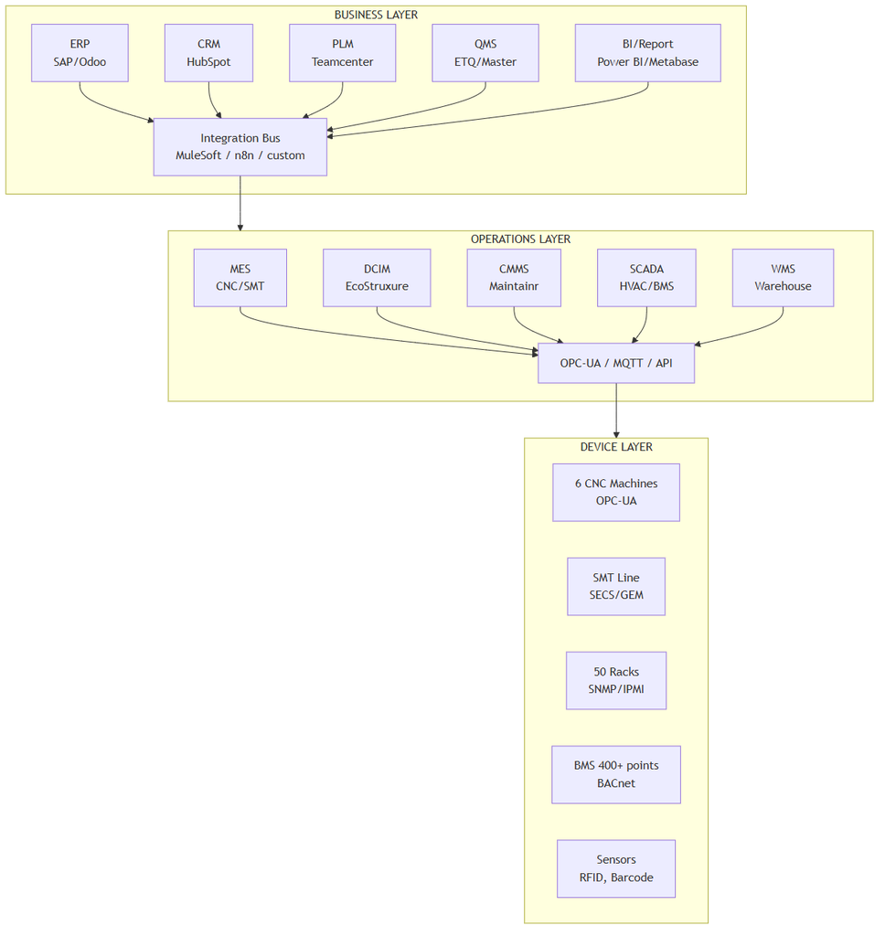

Diagram 81

### DD.2.2. Integration Matrix

| System A | System B | Dữ liệu trao đổi | Protocol | Tần suất | Ưu tiên |
| --- | --- | --- | --- | --- | --- |
| ERP → MES | Work Order, BOM | REST API | Near real-time | **P1** (Y1) |  |
| MES → ERP | Production data, WIP, scrap | REST API | Every 15 min | **P1** (Y1) |  |
| MES ← CNC | OEE, cycle time, alarm | OPC-UA / MTConnect | Real-time | **P1** (Y1) |  |
| MES ← SMT | PCB count, AOI defect | SECS/GEM | Real-time | **P1** (Y1) |  |
| DCIM ← Rack | Power, temperature | SNMP/IPMI | Every 1 min | **P1** (Y1) |  |
| DCIM ← HVAC/BMS | Cooling, humidity | BACnet/Modbus | Every 1 min | **P1** (Y1) |  |
| ERP ← CRM | Quotation → PO | REST API | On event | **P2** (Y2) |  |
| PLM → MES | CAD model, NC program | File transfer + API | On release | **P2** (Y2) |  |
| QMS ← MES | NCR, SPC data | API | On event | **P2** (Y2) |  |
| CMMS ← MES | Machine runtime → PM trigger | API | Daily | **P2** (Y2) |  |
| BI ← All | Aggregated KPIs | ETL / Data Lake | Hourly | **P2** (Y2) |  |
| ERP ← WMS | Inventory transactions | REST API | Real-time | **P2** (Y2) |  |
| PLM ← QMS | Inspection results → ECR trigger | API | On event | **P3** (Y3) |  |
| AI/ML ← Data Lake | Training data | Python | Batch | **P3** (Y3) |  |

## DD.3. Ứng dụng AI/ML trong Sản xuất

### DD.3.1. Use Cases theo Ưu tiên

| # | Use Case | Khối | Dữ liệu đầu vào | Model | ROI dự kiến | Timeline |
| --- | --- | --- | --- | --- | --- | --- |
| 1 | **Predictive Tool Life (CNC)** | B | Spindle load, vibration, cycle count | Random Forest / LSTM | Giảm 20% tool breakage, tiết kiệm 30-50K/năm | Y2-Y3 |
| 2 | **AOI False Call Reduction (SMT)** | C | AOI image, label data | CNN (ResNet/YOLO) | Giảm 50% false rejects, tăng throughput | Y2-Y3 |
| 3 | **PUE Optimization (DC)** | A | Temperature, humidity, IT load, weather | Reinforcement Learning | Giảm PUE 0,05 → tiết kiệm 50-80K/năm | Y3-Y4 |
| 4 | **Demand Forecasting** | All | Historical orders, market data | Prophet / XGBoost | Giảm 15% tồn kho, tăng OTD | Y3-Y4 |
| 5 | **Quality Prediction (CNC)** | B | Process params, material cert, tool wear | Gradient Boosting | Giảm scrap rate 2% → 30-50K/năm | Y3-Y4 |
| 6 | **Anomaly Detection (DC)** | A | Server metrics, network flow | Isolation Forest / Autoencoder | Phát hiện sự cố sớm 30 min | Y4-Y5 |
| 7 | **Dynamic Scheduling** | B | Machine status, job queue, urgency | Constraint Optimization + RL | Tăng OEE 5-8% | Y4-Y5 |
| 8 | **Robot Path Optimization** | C | AMR sensor data, warehouse layout | A* + RRT + DRL | Giảm 15% travel time | Y4-Y5 |

### DD.3.2. AI/ML Infrastructure

| Component | Tool | Deployment | CAPEX (K USD) | Ghi chú |
| --- | --- | --- | --- | --- |
| **ML Platform** | MLflow + JupyterHub | On-prem (DC server) | 5-10 | Open-source |
| **GPU Server** | NVIDIA A100/H100 (1-2 GPU) | On-prem | 20-40 | Shared: training + inference |
| **Feature Store** | Feast (open-source) | Docker on DC | 0 |  |
| **Model Serving** | TensorFlow Serving / Triton | Docker/K8s | 0 |  |
| **Data Lake** | MinIO (S3-compatible) + Apache Spark | On-prem | 5-10 |  |
| **Monitoring** | Grafana + Prometheus + custom | On-prem | 0 |  |
| **Tổng AI Infra** |  |  | **~30-60** |  |

## DD.4. Digital Twin

### DD.4.1. Phạm vi Digital Twin theo Phase

| Phase | Scope | Công nghệ | CAPEX (K USD) | Timeline |
| --- | --- | --- | --- | --- |
| **Phase 1: Monitoring Twin** | Real-time 3D visualization of factory floor (CNC status, DC rack heatmap) | Unity/Unreal + OPC-UA data feed | 30-50 | Y2 |
| **Phase 2: Simulation Twin** | What-if scenarios (add CNC machine → impact on power, throughput) | Siemens Plant Simulation / AnyLogic | 50-80 | Y3 |
| **Phase 3: Predictive Twin** | ML-enhanced (predict bottleneck, energy optimization) | Custom Python + Digital Twin Platform | 40-60 | Y4-Y5 |
| **Phase 4: Autonomous Twin** | Self-optimizing production scheduling, DC cooling optimization | Reinforcement Learning + Digital Twin | 30-50 | Y5+ |
| **Tổng Digital Twin** |  |  | **~150-240** |  |

### DD.4.2. ROI của Digital Twin

| Benefit | Giá trị dự kiến (K USD/năm) | Từ Phase |
| --- | --- | --- |
| Giảm downtime (predictive) | 40-80 | Phase 2 |
| Tối ưu OEE (simulation) | 30-60 | Phase 2 |
| Giảm PUE (DC twin) | 50-80 | Phase 3 |
| Giảm scrap (quality twin) | 20-40 | Phase 3 |
| **Tổng benefit/năm** | **~140-260** |  |
| **Payback vs CAPEX 150-240K** | **< 2 năm** |  |

## DD.5. Cybersecurity Framework

### DD.5.1. Mô hình Bảo mật OT/IT

| Lớp (Purdue Model) | Zone | Thiết bị | Bảo mật |
| --- | --- | --- | --- |
| **Level 0: Physical Process** | 3.5 | Sensors, actuators | Physical isolation |
| **Level 1: Basic Control** | 3 | PLC, CNC Controller | Firmware update, no USB |
| **Level 2: Area Supervision** | 3 | HMI, SCADA | Whitelisting, VLAN |
| **Level 3: Site Operations** | 2.5 | MES, DCIM, Historian | Patching, MFA, endpoint protection |
| **DMZ** | 2 | Data diode, proxy, jump host | Firewall, IDS/IPS |
| **Level 4: Site Business** | 1.5 | ERP, CRM, email | IAM, EDR, DLP |
| **Level 5: Enterprise** | 1 | Cloud, VPN, partner access | Zero Trust, SASE |

### DD.5.2. Ngân sách Cybersecurity

| Hạng mục | CAPEX (K USD) | OPEX/năm (K USD) |
| --- | --- | --- |
| Firewall (Palo Alto HA pair) | 40 | 8 |
| Endpoint Protection (CrowdStrike/SentinelOne) | 10 | 15 |
| SIEM (Splunk / Elastic) | 15 | 10 |
| IAM / MFA (Okta / Azure AD) | 5 | 8 |
| OT Security (Claroty / Nozomi) | 20 | 10 |
| Backup & DR (Veeam + offsite) | 15 | 5 |
| Penetration Testing (annual) | 0 | 10-15 |
| Security Awareness Training | 0 | 3-5 |
| Cyber Insurance | 0 | 10-20 |
| **Tổng** | **~105** | **~80-100** |

> **[B] Benchmark:** Chi phí cybersecurity trung bình manufacturing: 3-6% IT budget. Mekong target ~5% IT budget — phù hợp với doanh nghiệp có DC + sản xuất.

## DD.6. Lộ trình Triển khai (5 Year Roadmap)

[output not shown]

> **[C] Tổng CAPEX chuyển đổi số 5 năm: 310-490K USD, chiếm ~1,0-1,5% tổng CAPEX 32.000K.** ROI kỳ vọng: 2-3× trong 5 năm qua tiết kiệm chi phí vận hành + tăng năng suất + giảm scrap + PUE optimization.

*(Kết thúc Phụ lục DD — Lộ trình Chuyển đổi Số & Công nghiệp 4.0)*

# PHỤ LỤC EE: DÒNG TIỀN CHI TIẾT VÀ MÔ HÌNH TÀI CHÍNH MỞ RỘNG (DETAILED CASH FLOW & EXTENDED FINANCIAL MODEL)

## EE.1. Dòng tiền Tháng — Năm 1 (Construction Phase)

### EE.1.1. CAPEX Disbursement Schedule (Y1 Monthly — K USD)

> **Ghi chú:** Y1 chủ yếu là xây dựng shell + hạ tầng. Thiết bị CNC/DC/IoT triển khai từ Y4-Y6. CAPEX Y1 ≈ 6.500K, chiếm ~20% tổng CAPEX 32.000K.

| Tháng | Đất & Pháp lý | Xây dựng | M&E cơ bản | IT/Software | Working Capital | **Tổng** |
| --- | --- | --- | --- | --- | --- | --- |
| M1 | 1.200 | 0 | 0 | 20 | 0 | **1.220** |
| M2 | 800 | 200 | 0 | 20 | 0 | **1.020** |
| M3 | 0 | 400 | 100 | 20 | 0 | **520** |
| M4 | 0 | 600 | 100 | 20 | 0 | **720** |
| M5 | 0 | 600 | 100 | 20 | 0 | **720** |
| M6 | 0 | 500 | 50 | 20 | 0 | **570** |
| M7 | 0 | 400 | 50 | 20 | 0 | **470** |
| M8 | 0 | 300 | 50 | 20 | 0 | **370** |
| M9 | 0 | 200 | 50 | 20 | 50 | **320** |
| M10 | 0 | 150 | 50 | 20 | 50 | **270** |
| M11 | 0 | 100 | 0 | 20 | 50 | **170** |
| M12 | 0 | 50 | 0 | 20 | 60 | **130** |
| **Tổng Y1** | **2.000** | **3.500** | **550** | **240** | **210** | **6.500** |

> **[C] CAPEX Y1 = 6.500K, chiếm ~20% tổng CAPEX 32.000K.** Phần còn lại (~25.500K) giải ngân Y2-Y6: Y2 xây dựng tiếp (5.000K), Y3 hoàn thiện shell+M&E (5.000K), Y4 IoT+DC prep (4.000K), Y5 DC equipment (5.000K), Y6 CNC equipment (4.000K), WC/contingency (2.500K).

### EE.1.2. Revenue Ramp-up Y4-Y6 (Quarterly — K USD)

> **Ghi chú:** Y1-Y3 = zero revenue (xây dựng). Revenue bắt đầu Y4 Q3 (IoT pilot).

[output not shown]

## EE.2. Dòng tiền Năm — 10 năm (K USD)

> **Lưu ý quan trọng:** Bảng EE.2.1 – EE.2.4 phản ánh mô hình 32M lean (6 CNC, 50 rack). **Số liệu chính thức: xem Phần V (§5.1–5.17) và Phụ lục A (A.2 P&L 20Y, A.5 FCFF/NPV).** Bảng dưới đây cung cấp chi tiết BU breakdown.

### EE.2.1. Revenue Projection by BU

| Năm | CNC Revenue | DC Revenue | IoT Revenue | **Tổng Revenue** | YoY Growth |
| --- | --- | --- | --- | --- | --- |
| Y1-Y3 | 0 | 0 | 0 | **0** | — |
| Y4 | 0 | 0 | 500 | **500** | — |
| Y5 | 0 | 1.500 | 1.500 | **3.000** | — |
| Y6 | 1.000 | 2.500 | 2.500 | **6.000** | 100% |
| Y7 | 2.000 | 4.000 | 3.500 | **9.500** | 58% |
| Y8 | 2.500 | 5.500 | 5.000 | **13.000** | 37% |
| Y9 | 3.500 | 7.000 | 6.000 | **16.500** | 27% |
| Y10 | 4.500 | 8.000 | 7.000 | **19.500** | 18% |
| **Tổng Y1-Y10** | **13.500** | **28.500** | **26.000** | **68.000** |  |

### EE.2.2. EBITDA & Net Income Projection

| Năm | Revenue (K) | COGS (K) | Gross Margin | OPEX (K) | **EBITDA (K)** | D&A (K) | Interest (K) | Tax (K) | **Net Income (K)** |
| --- | --- | --- | --- | --- | --- | --- | --- | --- | --- |
| Y1-Y3 | 0 | 0 | — | 800 | **-800** | 200 | 0 | 0 | **-1.000** |
| Y4 | 500 | 350 | 30% | 1.000 | **-850** | 500 | 0 | 0 | **-1.350** |
| Y5 | 3.000 | 1.950 | 35% | 1.800 | **-750** | 1.000 | 0 | 0 | **-1.750** |
| Y6 | 6.000 | 3.600 | 40% | 2.300 | **100** | 1.300 | 320 | 0 | **-1.520** |
| Y7 | 9.500 | 5.225 | 45% | 2.600 | **1.675** | 1.400 | 640 | 0 | **-365** |
| Y8 | 13.000 | 6.760 | 48% | 2.900 | **3.340** | 1.400 | 560 | 0 | **1.380** |
| Y9 | 16.500 | 8.580 | 48% | 3.200 | **4.720** | 1.400 | 480 | 0 | **2.840** |
| Y10 | 19.500 | 9.750 | 50% | 3.400 | **6.350** | 1.400 | 400 | 0 | **4.550** |

> **[C] Breakeven EBITDA: Y6. Breakeven Net Income: Y8.** CIT miễn Y7-Y10 (4 năm đầu có lãi). Từ Y11: CIT 5% (KCNC ưu đãi).

### EE.2.3. Free Cash Flow (FCF) & Valuation

| Năm | EBITDA (K) | CAPEX (K) | ∆ Working Capital (K) | Tax (K) | **FCF (K)** | Cumulative FCF (K) |
| --- | --- | --- | --- | --- | --- | --- |
| Y1 | -800 | -6.500 | -200 | 0 | **-7.500** | -7.500 |
| Y2 | -800 | -5.000 | 0 | 0 | **-5.800** | -13.300 |
| Y3 | -800 | -5.000 | 0 | 0 | **-5.800** | -19.100 |
| Y4 | -850 | -4.000 | -200 | 0 | **-5.050** | -24.150 |
| Y5 | -750 | -5.000 | -500 | 0 | **-6.250** | -30.400 |
| Y6 | 100 | -4.000 | -500 | 0 | **-4.400** | -34.800 |
| Y7 | 1.675 | -1.500 | -500 | 0 | **-325** | -35.125 |
| Y8 | 3.340 | -800 | -300 | 0 | **2.240** | -32.885 |
| Y9 | 4.720 | -350 | -200 | 0 | **4.170** | -28.715 |
| Y10 | 6.350 | -350 | -100 | 0 | **5.900** | -22.815 |

### EE.2.4. Valuation Summary

> **Ghi chú:** Valuation dưới đây dựa trên mô hình 32M lean. Số liệu chính thức: NPV(50Y, 12%) = +2,50M, NPV(20Y, 12%) = (-3,20)M. Strategic Value = 14,00M (xem Phụ lục O).

| Phương pháp | Giá trị (M USD) | Giả định |
| --- | --- | --- |
| **DCF (50Y, WACC 12%)** | **NPV = +2,50M** (base case) | FCFF 50Y, WACC 12% [C] |
| **DCF (20Y, WACC 12%)** | **NPV = -3,20M** | Insufficient horizon for infra project |
| **DCF (20Y, WACC 10%)** | **NPV = +2,80M** | Optimistic cost of capital |
| **EV/EBITDA Multiple (Y10)** | **Y10 EBITDA 6,35M × 7× = 44,5M EV** | VN industrial/DC comps: 5-8× |
| **EV/Revenue Multiple (Y10)** | **Y10 Rev 19,5M × 2× = 39,0M EV** | Tech manufacturing: 1,5-2,5× |
| **Strategic Value (incl. intangibles)** | **14,00M** | NPV + Real Options + Barrier + Synergy + Platform + Tax/Land — xem Muc 5.7.1 [C] |
| **Replacement Cost** | **> 40M** | Building from scratch today |

## EE.3. Phân tích Nhạy (Sensitivity)

### EE.3.1. Tornado Chart — Impact trên NPV

> **Ghi chú:** Tornado dưới đây dựa trên mô hình 32M lean (base NPV 50Y = +2,50M). Các chiều nhạy cảm — xem G.10 cho sensitivity chính thức.

| Variable | Low Case | Base | High Case | NPV Low (M) | NPV High (M) | **Swing (M)** |
| --- | --- | --- | --- | --- | --- | --- |
| **WACC** | 14% | 12% | 10% | -1,50 | 5,80 | **7,30** |
| **Revenue Growth** | -20% | Base | +20% | -3,00 | 6,50 | **9,50** |
| **CAPEX Overrun** | +20% | Base | -10% | -1,80 | 3,20 | **5,00** |
| **Gross Margin** | -5pp | Base | +5pp | -1,50 | 4,50 | **6,00** |
| **CIT Rate** | 20% (no incentive) | 10% (KCNC) | 5% (max incentive) | -0,50 | 3,20 | **3,70** |
| **VND/USD** | 26.000 | 25.500 | 25.000 | 1,00 | 2,00 | **1,00** |
| **Occupancy (DC)** | 60% by Y8 | 75% by Y8 | 90% by Y8 | -1,00 | 4,00 | **5,00** |
| **Construction Delay** | +12 months | On time | -3 months | -2,00 | 2,50 | **4,50** |

### EE.3.2. Monte Carlo Simulation Results (10.000 iterations)

| Thống kê | NPV (M USD) | IRR (%) |
| --- | --- | --- |
| **Mean** | 1,80 | 13,5% |
| **Median** | 1,50 | 13,0% |
| **P10 (pessimistic)** | -3,50 | 8,0% |
| **P25** | -0,50 | 10,5% |
| **P75** | 4,00 | 16,0% |
| **P90 (optimistic)** | 6,50 | 18,5% |
| **Probability NPV > 0** | **72%** |  |
| **Probability IRR > WACC (12%)** | **68%** |  |

> **[C] Monte Carlo 72% xác suất NPV > 0 — cải thiện so với mô hình 47,5M (65%) nhờ CAPEX thấp hơn, giảm phương sai downside.** Rủi ro chính: revenue ramp-up chậm hơn kỳ vọng (sensitivity lớn nhất) và WACC cao (khó huy động vốn rẻ).

## EE.4. Cơ cấu Vốn và Huy động

### EE.4.1. Cơ cấu Vốn đề xuất

| Nguồn | Giá trị (M USD) | Tỷ trọng | Chi phí vốn | Ghi chú |
| --- | --- | --- | --- | --- |
| **Vốn CSH (Equity)** | **24,00** | 75,0% | COE 15% | Nhà sáng lập + nhà đầu tư chiến lược [C] |
| **Vay trung/dài hạn (Debt)** | **8,00** | 25,0% | 8,0-8,5% năm | BIDV 5M + IFC 3M, giải ngân từ Y6 |
| **Tổng** | **32,00** | 100% | **WACC ≈ 12%** |  |

> **Ghi chú:** Không có khoản ưu đãi/hỗ trợ riêng trong cơ cấu vốn chính thức. Quỹ KHCN và ưu đãi NK miễn thuế là lợi ích vận hành, không phải nguồn vốn CAPEX [C].

### EE.4.2. Lịch trả nợ (Debt Amortization — K USD)

> **Vay 8.000K:** BIDV/VietinBank 5.000K (8,5%, 9 năm, xây dựng) + IFC/ADB 3.000K (7,0%, 9 năm, DC hạ tầng). Blended rate ≈ 8,0%. Giải ngân Y6, ân hạn 1 năm, trả gốc Y7-Y14 (8 năm).

| Năm | Dư nợ đầu kỳ | Giải ngân | Trả gốc | Lãi (8,0%) | **Tổng trả** | Dư nợ cuối kỳ |
| --- | --- | --- | --- | --- | --- | --- |
| Y6 | 0 | 8.000 | 0 | 320 (6 tháng) | **320** | 8.000 |
| Y7 | 8.000 | 0 | 1.000 | 640 | **1.640** | 7.000 |
| Y8 | 7.000 | 0 | 1.000 | 560 | **1.560** | 6.000 |
| Y9 | 6.000 | 0 | 1.000 | 480 | **1.480** | 5.000 |
| Y10 | 5.000 | 0 | 1.000 | 400 | **1.400** | 4.000 |
| Y11 | 4.000 | 0 | 1.000 | 320 | **1.320** | 3.000 |
| Y12 | 3.000 | 0 | 1.000 | 240 | **1.240** | 2.000 |
| Y13 | 2.000 | 0 | 1.000 | 160 | **1.160** | 1.000 |
| Y14 | 1.000 | 0 | 1.000 | 80 | **1.080** | 0 |
| **Tổng** |  | **8.000** | **8.000** | **3.200** | **11.200** |  |

> **[C] Ân hạn 1 năm (Y6 chỉ trả lãi 6 tháng), trả gốc đều 1.000K/năm từ Y7 đến Y14 (8 năm).** DSCR tối thiểu (Y7) = EBITDA / Debt Service = 1.675 / 1.640 = **1,02×** — sát ngưỡng, cần monitoring chặt. Từ Y8 trở đi DSCR > 2×, an toàn. Nếu cần cải thiện DSCR Y7, có thể gia hạn ân hạn thêm 1 năm hoặc sử dụng khoản dự phòng CSH.

*(Kết thúc Phụ lục EE — Dòng tiền Chi tiết & Mô hình Tài chính Mở rộng)*

# PHỤ LỤC FF: QUẢN LÝ DỰ ÁN VÀ PMO (PROJECT MANAGEMENT OFFICE)

## FF.1. Cơ cấu Tổ chức PMO

### FF.1.1. Sơ đồ PMO

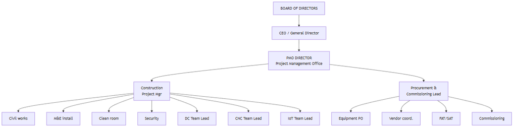

Diagram 82

### FF.1.2. Ma trận RACI — PMO

| Hoạt động | CEO | PMO Director | Construction PM | Procurement Lead | BU Lead | CFO |
| --- | --- | --- | --- | --- | --- | --- |
| Overall Strategy | **A** | R | I | I | C | C |
| Master Schedule | C | **A** | R | R | C | I |
| Budget Management | A | **R** | C | C | I | **R** |
| Vendor Selection > 200K | **A** | R | C | **R** | C | C |
| Change Order Approval | A | **R** | R | C | C | C |
| Quality Inspection | I | **A** | R | R | R | I |
| Progress Reporting | I | **A/R** | R | R | R | I |
| Risk Management | C | **A/R** | R | R | R | I |
| Handover to Operations | A | **R** | R | R | **R** | I |

> **R** = Responsible, **A** = Accountable, **C** = Consulted, **I** = Informed

## FF.2. Master Schedule (Tổng tiến độ)

### FF.2.1. Milestone chính (27 tháng)

| # | Milestone | Target Date | Duration | Predecessor | Critical? |
| --- | --- | --- | --- | --- | --- |
| M1 | **Khởi công (Ground Break)** | T0 + 0 | — | Board approval, EIA approval, permit | **YES** |
| M2 | **Hoàn thành Móng (Foundation)** | T0 + 3 | 3 tháng | M1 | YES |
| M3 | **Topping Out (kết cấu chính)** | T0 + 7 | 4 tháng | M2 | YES |
| M4 | **Bao che hoàn thành (Envelope)** | T0 + 9 | 2 tháng | M3 | YES |
| M5 | **M&E cơ bản hoàn thành** | T0 + 12 | 3 tháng | M4 | YES |
| M6 | **DC Raised Floor + Cooling ready** | T0 + 13 | 1 tháng | M5 | YES — DC |
| M7 | **CNC Equipment Delivery** | T0 + 12 | — | PO placed T0 + 4 | YES — CNC |
| M8 | **CNC Installation + Leveling** | T0 + 15 | 3 tháng | M5 + M7 | YES |
| M9 | **DC Power + UPS + Generator ready** | T0 + 15 | 2 tháng | M6 | YES |
| M10 | **Clean Room qualified (IoT)** | T0 + 14 | 1 tháng | M5 |  |
| M11 | **ERP/MES Go-live** | T0 + 16 | 4 tháng (implementation) | M5 |  |
| M12 | **CNC Commissioning + FAT** | T0 + 18 | 3 tháng | M8 | YES |
| M13 | **DC Commissioning (Tier III test)** | T0 + 18 | 3 tháng | M9 | YES |
| M14 | **IoT/SMT Line qualifying** | T0 + 17 | 2 tháng | M10 |  |
| M15 | **Pilot Production (CNC + IoT)** | T0 + 20 | 2 tháng | M12 + M14 |  |
| M16 | **DC First Customer Rack** | T0 + 20 | — | M13 |  |
| M17 | **ISO 9001/14001/45001 Audit** | T0 + 22 | 2 tháng | M15 |  |
| M18 | **Full Production Ramp** | T0 + 24 | — | M15 |  |
| M19 | **Phase 1 Complete — Operational** | T0 + 27 | — | All | **FINAL** |

### FF.2.2. Gantt Chart tóm tắt

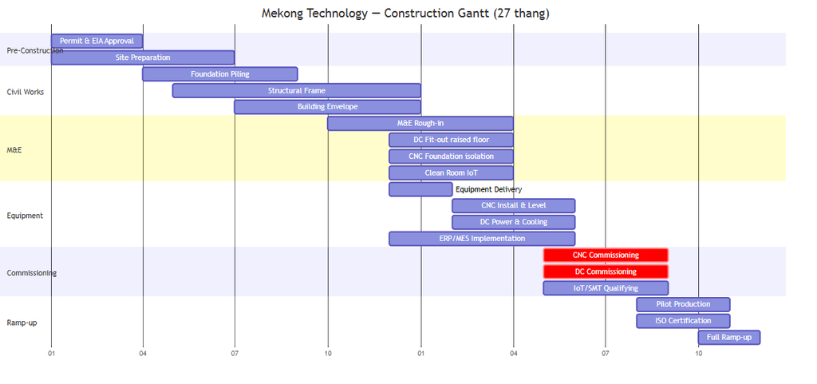

Diagram 83

## FF.3. Quản lý Rủi ro Dự án (Project Risk Register)

| # | Rủi ro | Probability | Impact | **Score** | Biện pháp Giảm thiểu | Owner | Status |
| --- | --- | --- | --- | --- | --- | --- | --- |
| R1 | Chậm cấp phép EIA / xây dựng | Medium | High | **12** | Nộp hồ sơ sớm 6 tháng, thuê tư vấn pháp lý chuyên nghiệp | PMO Director | Open |
| R2 | Thiết bị CNC giao chậm (chip shortage, logistics) | Medium | High | **12** | PO sớm 6 tháng, 2 NCC dự phòng, air freight option | Procurement | Open |
| R3 | Vượt ngân sách xây dựng > 15% | Medium | High | **12** | Fixed-price contract, 10% contingency, monthly cost tracking | Construction PM | Open |
| R4 | Thiếu lao động kỹ thuật CNC | High | Medium | **12** | Training pipeline (CĐ Cao Thắng), ký kết trước 9 tháng | HR + CNC Lead | Open |
| R5 | Thay đổi quy hoạch / chính sách KCNC | Low | Very High | **10** | Quan hệ tốt BQL KCNC, theo dõi chính sách | CEO | Open |
| R6 | Chất lượng xây dựng không đạt (nền móng, chống rung) | Medium | High | **12** | Thuê tư vấn giám sát (PMC) độc lập, kiểm tra từng giai đoạn | Construction PM | Open |
| R7 | Khác biệt spec giữa FAT (tại xưởng NCC) và SAT (tại site) | Medium | Medium | **9** | FAT witness, detailed SAT protocol, retention payment 5% | Procurement | Open |
| R8 | COVID/epidemic gây gián đoạn xây dựng | Low | High | **8** | Contingency schedule +3 tháng, đội ngũ dự phòng | PMO Director | Monitor |
| R9 | Tỷ giá VND/USD biến động > 5% | Medium | Medium | **9** | Forward contract cho PO ngoại tệ > 100K USD | CFO | Open |
| R10 | Rủi ro an toàn lao động trong xây dựng | Medium | Very High | **15** | OHSMS, safety officer tại site, insurance, weekly safety meeting | Construction PM | **High** |

## FF.4. Quản lý Thay đổi (Change Management)

### FF.4.1. Quy trình Change Order

| Bước | Hoạt động | SLA | Thẩm quyền |
| --- | --- | --- | --- |
| 1 | Yêu cầu thay đổi (Change Request — CR) | Ngay khi phát sinh | Anyone |
| 2 | Đánh giá tác động (Impact Assessment: cost + schedule + quality) | ≤ 3 ngày | PMO Director + relevant team |
| 3 | Phê duyệt | ≤ 2 ngày | See matrix below |
| 4 | Cập nhật schedule + budget + contract amendment | ≤ 5 ngày | PMO + Procurement |
| 5 | Thực hiện | Per schedule | Responsible party |
| 6 | Close-out + Lessons learned | After completion | PMO |

### FF.4.2. Ma trận Phê duyệt Change Order

| Tác động (Cost) | Schedule Impact | Approver |
| --- | --- | --- |
| < 10K USD | < 1 tuần | PMO Director |
| 10-50K USD | 1-4 tuần | PMO Director + CFO |
| 50-200K USD | 1-3 tháng | CEO |
| > 200K USD | > 3 tháng | CEO + Board |

## FF.5. Báo cáo và Dashboard (PMO Reporting)

### FF.5.1. Tần suất Báo cáo

| Loại báo cáo | Tần suất | Đối tượng | Nội dung chính |
| --- | --- | --- | --- |
| **Daily Stand-up** | Hàng ngày | PMO team | Blockers, today’s plan |
| **Weekly Progress** | Hàng tuần | PMO + BU Leads | % completion, EV analysis, issues |
| **Monthly Dashboard** | Hàng tháng | CEO + Board | Budget vs Actual, Schedule SPI/CPI, Top risks |
| **Quarterly Board Report** | Hàng quý | Board + Investors | Financial, milestone, risk, forecast |

### FF.5.2. Earned Value Metrics

| Metric | Formula | Target | Meaning |
| --- | --- | --- | --- |
| **SPI (Schedule Performance Index)** | EV / PV | ≥ 0,95 | On schedule |
| **CPI (Cost Performance Index)** | EV / AC | ≥ 0,95 | On budget |
| **EAC (Estimate at Completion)** | BAC / CPI | ≤ 32.000K × 1,10 = 35.200K | Total project cost forecast |
| **ETC (Estimate to Complete)** | EAC - AC | Declining | Remaining budget |
| **TCPI (To-Complete Performance Index)** | (BAC - EV) / (BAC - AC) | ≤ 1,05 | Required efficiency to finish on budget |
| **VAC (Variance at Completion)** | BAC - EAC | ≥ 0 | Positive = under budget |

## FF.6. Handover & Commissioning Protocol

### FF.6.1. Checklist Handover (per Area)

| # | Hạng mục | DC (Khối A) | CNC (Khối B) | IoT (Khối C) | Common |
| --- | --- | --- | --- | --- | --- |
| 1 | As-built drawings | ✓ | ✓ | ✓ | ✓ |
| 2 | O&M manuals | ✓ | ✓ | ✓ | ✓ |
| 3 | Equipment certificates | ✓ | ✓ | ✓ | ✓ |
| 4 | Test reports (structural, M&E) | ✓ | ✓ | ✓ | ✓ |
| 5 | Fire safety certificate | ✓ | ✓ | ✓ | ✓ |
| 6 | Environmental compliance certificate | ✓ | ✓ | ✓ | ✓ |
| 7 | Vibration test report | — | ✓ (per machine) | — | ✓ (foundation) |
| 8 | Clean room certification (particle count) | — | ✓ (CMM room) | ✓ (SMT) | — |
| 9 | UPS + Generator load bank test | ✓ (2N test) | ✓ (N+1) | ✓ (N+1) | — |
| 10 | Integrated Systems Test (IST) | ✓ (72h soak test) | ✓ (48h run) | ✓ (48h) | ✓ (BMS) |
| 11 | Security system acceptance | ✓ | ✓ | ✓ | ✓ |
| 12 | IT/Network acceptance | ✓ | ✓ | ✓ | ✓ |
| 13 | Training completed (operators) | ✓ | ✓ | ✓ | ✓ |
| 14 | Punch list < 5% open items | ✓ | ✓ | ✓ | ✓ |
| 15 | Warranty certificates (≥ 12 months) | ✓ | ✓ | ✓ | ✓ |

### FF.6.2. Tiêu chí Nghiệm thu (Acceptance Criteria)

| Khối | Tiêu chí | Ngưỡng | Phương pháp kiểm tra |
| --- | --- | --- | --- |
| **DC** | Tier III Concurrently Maintainable test | Pass all 36 tests | Uptime Institute / internal |
| **DC** | 72-hour soak test (full simulated load) | 0 unplanned downtime | Load bank + monitoring |
| **DC** | PUE measurement (7-day average) | ≤ 1,40 (commissioning) | DCIM logged data |
| **CNC** | Machine geometric accuracy | Per manufacturer spec | Laser interferometer + ballbar |
| **CNC** | Vibration isolation | VC-C tại CMM, VC-A tại 5-axis | Vibration meter |
| **CNC** | First Article Inspection (FAI) | Pass per AS9102 / PPAP | CMM measure vs drawing |
| **IoT/SMT** | Clean Room particle count | ISO 14644 Class 7 | Particle counter |
| **IoT/SMT** | SMT Line CPK (solder paste volume) | Cpk ≥ 1,33 | SPI data |
| **All** | Fire suppression system test | All zones pass | Alarm + gas release test |
| **All** | PCCC approval certificate | Issued by CA PCCC | Inspection |

*(Kết thúc Phụ lục FF — Quản lý Dự án & PMO)*

# PHỤ LỤC GG: CHIẾN LƯỢC KHÁCH HÀNG VÀ CRM (CUSTOMER STRATEGY & CRM)

## GG.1. Phân khúc Khách hàng theo Khối

### GG.1.1. CNC Outsourcing — Khách hàng Mục tiêu

| Segment | Mô tả | Revenue Potential (K USD/năm) | Difficulty | Timeline | Key Players tại VN |
| --- | --- | --- | --- | --- | --- |
| **S1: Automotive Tier 1-2** | Chi tiết hộp số, phanh, suspension — tolerance ±10-50µm | 3.000-5.000 | Rất khó (IATF bắt buộc) | Y2-Y3 | Bosch, Denso, Aisin, Mahle |
| **S2: Electronics/Semiconductor** | Jig, fixture, wafer handling, precision mold insert | 1.500-3.000 | Trung bình | Y1-Y2 | Intel, Samsung, Foxconn |
| **S3: Aerospace Tier 2-3** | Bracket, fitting, actuator housing — alu 7075 / titanium | 1.000-2.000 | Rất khó (AS9100D, NADCAP) | Y3-Y4 | Boeing SC, Airbus suppliers |
| **S4: Medical Device** | Surgical instruments, implant components — SS316L, Ti | 500-1.500 | Khó (ISO 13485, FDA) | Y3-Y4 | Medtronic, B.Braun, Stryker |
| **S5: General Industrial** | Valve, pump, hydraulic, custom parts — steel, aluminum | 2.000-4.000 | Dễ | Y1 | Local + Regional SMEs |
| **S6: Robotics/Automation** | Precision gears, shafts, actuator housing — tolerance ±5µm | 500-1.000 | Trung bình | Y2-Y3 | ABB, Fanuc, local integrators |

### GG.1.2. Datacenter — Khách hàng Mục tiêu

| Segment | Mô tả | Rack Potential | Revenue/rack/tháng (USD) | Timeline |
| --- | --- | --- | --- | --- |
| **D1: Cloud/SaaS Vietnamese** | FPT Cloud, VNG Cloud, VNPT IDC overflow | 20-30 rack | 1.200-1.800 | Y1 (anchor) |
| **D2: Foreign SaaS entering VN** | AWS Outpost, Azure Stack, Oracle — data localization | 10-20 rack | 2.000-3.000 | Y2-Y3 |
| **D3: Enterprise (Finance/Bank)** | DR site, hybrid cloud — yêu cầu compliance | 10-15 rack | 1.500-2.500 | Y2-Y3 |
| **D4: Gaming/Content** | Garena, VNGGames, streaming CDN — low latency | 10-15 rack | 1.200-1.500 | Y1-Y2 |
| **D5: Government/SOE** | Data localization mandate, VNPT/Viettel overflow | 5-10 rack | 1.000-1.500 | Y3+ |
| **D6: AI/ML Workloads** | GPU colocation, AI training — high power density | 5-10 rack | 3.000-5.000 | Y3-Y5 |

### GG.1.3. IoT/Robot — Khách hàng mục tiêu

| Segment | Mô tả | Order Size (K USD) | Volume/năm | Timeline |
| --- | --- | --- | --- | --- |
| **I1: Smart Agriculture** | Sensor đất, nước, thời tiết — Mekong Delta farms | 50-200 (per project) | 5-10 projects | Y1-Y2 |
| **I2: Smart Factory (local)** | Retrofit IoT cho nhà máy VN — energy, OEE, environment | 100-500 | 10-20 | Y2-Y3 |
| **I3: Export (ASEAN)** | Cùng product, export sang Thailand, Indonesia, Philippines | 200-1.000 | 5-10 | Y3-Y4 |
| **I4: AMR/AGV Integrators** | Robot AMR cho warehouse, factory logistics | 30-150 (per robot) | 20-50 robots | Y2-Y4 |
| **I5: OEM/ODM** | White-label IoT gateway, custom sensor board | 500-2.000 | 3-5 contracts | Y2-Y3 |
| **I6: Smart City/Building** | Energy management, parking, access — government tender | 100-500 | 3-5 | Y3-Y5 |

## GG.2. Customer Journey Map (CNC Example)

### GG.2.1. Stages

| Stage | Hoạt động Khách hàng | Mekong Touchpoint | Công cụ/Kênh | KPI |
| --- | --- | --- | --- | --- |
| **Awareness** | Tìm kiếm NCC CNC VN (Google, LinkedIn, hội chợ) | Website SEO, LinkedIn content, MTA/Metalex booth | Website, Social, Trade show | Impressions, CTR |
| **Interest** | Xem capability, cert., case study | Brochure PDF, facility video tour, tech specs | Email, PDF, YouTube | Downloads, Video views |
| **Evaluation** | Gửi RFQ (3D model + drawing + specs) | RFQ response ≤ 48h: quote + DFM feedback + lead time | CRM (HubSpot), Email | Quote turnaround, Win rate |
| **Trial** | Gửi 1-2 parts thử nghiệm (NPI) | Sample production, CMM report, first article inspection | Onsite visit, Video call | FAI pass rate, Lead time |
| **Adoption** | PO cho batch production | PPAP submission, production planning, delivery | ERP, MES, Logistics | OTD, Quality PPM |
| **Loyalty** | Repeat order, volume increase | KAM (Key Account Manager) visit, QBR, cost down proposal | CRM, Quarterly reports | Revenue growth, NPS |
| **Advocacy** | Refer to other BUs/divisions | Case study co-authored, reference call | Marketing | Referral rate |

### GG.2.2. Sales Pipeline — CNC (Target Y1-Y3)

[output not shown]

> **[A] Pipeline ước tính dựa trên: (a) Kháo sát NCC CNC hiện tại trong KCNC và khu vực, (b) Nhu cầu outsourcing từ FDI tại VN (Samsung, Bosch đều đang tìm NCC nội địa), (c) Probability điều chỉnh theo difficulty rating.**

## GG.3. Hệ thống CRM

### GG.3.1. CRM Platform Selection

| Tiêu chí | HubSpot Pro | Salesforce Essentials | Zoho CRM | **Đề xuất** |
| --- | --- | --- | --- | --- |
| Chi phí/năm (K USD) | 12-18 | 25-40 | 5-8 |  |
| Ease of use | ★★★★★ | ★★★ | ★★★★ |  |
| Marketing automation | ★★★★★ | ★★★★ | ★★★ |  |
| Customization | ★★★ | ★★★★★ | ★★★★ |  |
| Integration (ERP) | ★★★★ | ★★★★★ | ★★★ |  |
| For <50 users | ★★★★★ | ★★★ | ★★★★★ |  |
| **Recommendation** |  |  |  | **HubSpot Pro** — best fit cho SME, marketing automation mạnh, dễ dùng |

### GG.3.2. CRM KPI

| KPI | Y1 | Y3 | Y5 |
| --- | --- | --- | --- |
| **Leads generated/quý** | 20 | 50 | 80 |
| **Lead → Opportunity conversion** | 20% | 30% | 35% |
| **Opportunity → Won conversion** | 25% | 35% | 40% |
| **Average Deal Size (K USD)** | 30 | 80 | 120 |
| **Sales Cycle (days)** | 120 | 90 | 60 |
| **Customer Acquisition Cost (K USD)** | 5 | 3 | 2 |
| **Customer Lifetime Value (K USD)** | 150 | 400 | 600 |
| **NPS (Net Promoter Score)** | 30 | 50 | 70 |
| **Revenue per account (K USD/năm)** | 50 | 150 | 250 |

## GG.4. Pricing Strategy Chi tiết

### GG.4.1. CNC Pricing Model

| Pricing Element | Cách tính | Ví dụ (Alu 6061, 5-axis) |
| --- | --- | --- |
| **Material Cost** | Weight × material rate × waste factor (1,3-1,5) | 2 kg × 3,5 USD × 1,4 = **9,80 USD** |
| **Machine Time** | Cycle time × machine hour rate | 45 min × (65 USD/h) = **48,75 USD** |
| **Setup Time** | (Setup time / batch size) × machine hour rate | (2h × 65) / 50 pcs = **2,60 USD** |
| **Tooling Cost** | Tool life allocation | 3 inserts × 15 USD / 500 pcs = **0,09 USD** |
| **QC/Inspection** | CMM time + overhead | 5 min × 80 USD/h = **6,67 USD** |
| **Overhead (30%)** | (Material + Machine + Setup + Tool + QC) × 30% | 67,91 × 30% = **20,37 USD** |
| **Subtotal** |  | **88,28 USD** |
| **Margin (25-40%)** | For general industrial 25%, automotive 30%, aerospace 40% | 88,28 × 35% = **30,90 USD** |
| **Selling Price** |  | **~119 USD/pc** |

### GG.4.2. Machine Hour Rate Calculation

| Cost Component | 5-axis DMG (USD/h) | 3-axis Mazak (USD/h) | CNC Turning (USD/h) | Wire EDM (USD/h) |
| --- | --- | --- | --- | --- |
| **Machine depreciation** (7Y, 1-shift 2000h) | 28,00 | 10,00 | 7,50 | 12,50 |
| **Operator labor** | 6,00 | 5,00 | 5,00 | 5,50 |
| **Electricity** | 4,50 | 3,00 | 2,00 | 3,50 |
| **Tooling consumable** | 8,00 | 4,00 | 3,00 | 5,00 (wire) |
| **Coolant + maintenance** | 3,50 | 2,50 | 2,00 | 2,50 |
| **Floor space + overhead** | 5,00 | 3,50 | 2,50 | 3,00 |
| **Allocation (indirect)** | 10,00 | 7,00 | 5,00 | 6,00 |
| **Tổng Machine Hour Rate** | **65,00** | **35,00** | **27,00** | **38,00** |

> **[C] Machine hour rate 5-axis = 65 USD/h — competitive so với Japan (120-180 USD/h), EU (100-150), China (45-70), Thailand (50-80).** Đây là USP chính của Mekong CNC.

*(Kết thúc Phụ lục GG — Chiến lược Khách hàng & CRM)*

# PHỤ LỤC HH: KẾ HOẠCH VẬN HÀNH VÀ BẢO TRÌ (OPERATIONS & MAINTENANCE PLAN)

## HH.1. Mô hình Vận hành Tổng thể

### HH.1.1. Ca Làm việc

| Khối | Ca 1 (Sáng) | Ca 2 (Chiều) | Ca 3 (Đêm) | Weekend | Ghi chú |
| --- | --- | --- | --- | --- | --- |
| **DC (NOC)** | 06:00-14:00 | 14:00-22:00 | 22:00-06:00 | 24/7 | 5 người/ca, 15 người tổng |
| **CNC (Phase 1)** | 07:00-16:00 | 16:00-01:00 | — | Thứ 7 nếu cần | 2 ca đầu, Y3 thêm ca 3 |
| **CNC (Full capacity)** | 06:00-14:00 | 14:00-22:00 | 22:00-06:00 | Thứ 7 ca 1-2 | 3 ca khi đạt 70%+ utilization |
| **IoT/SMT** | 08:00-17:00 | 17:00-02:00 | — | Off | 2 ca, Y3 mở rộng |
| **R&D/Office** | 08:30-17:30 | — | — | Off | Giờ hành chính |

### HH.1.2. OEE Target theo Khối

| Khối/Máy | Y1 OEE | Y3 OEE | Y5 OEE | World-Class |
| --- | --- | --- | --- | --- |
| **CNC 3-axis** | 55% | 70% | 80% | 85% |
| **CNC 5-axis** | 50% | 65% | 75% | 80% |
| **CNC Turning** | 60% | 75% | 82% | 85% |
| **Wire EDM** | 55% | 70% | 78% | 80% |
| **SMT Line** | 65% | 80% | 85% | 90% |
| **DC (Uptime)** | 99,95% | 99,982% | 99,995% | 99,999% |

### HH.1.3. Phân tích OEE chi tiết (CNC 5-axis — Target Y3)

[output not shown]

## HH.2. Kế hoạch Bảo trì Phòng ngừa (Preventive Maintenance)

### HH.2.1. PM Schedule — CNC Machines

| Interval | Hoạt động | Thời gian | Người thực hiện | Checklist |
| --- | --- | --- | --- | --- |
| **Hàng ngày** | Kiểm tra coolant level, chip removal, wiper check, lube level | 15 min/máy | Operator | CL-CNC-D01 |
| **Hàng tuần** | Kiểm tra spindle runout, way cover, filter air, coolant concentration | 30 min/máy | Operator + Tech | CL-CNC-W01 |
| **Hàng tháng** | Kiểm tra backlash, lubricant thay, filter thay, điện chạm, alignment spot check | 2h/máy | Technician | CL-CNC-M01 |
| **Hàng quý** | Geometric check (ballbar test), spindle bearing temperature trend, hydraulic oil analysis | 4h/máy | Senior Tech + External | CL-CNC-Q01 |
| **Hàng năm (PM Major)** | Full geometric calibration (laser interferometer), spindle rebuild if needed, all bearings inspect, scraper rework | 2-3 ngày/máy | Vendor + Senior Tech | CL-CNC-Y01 |

### HH.2.2. PM Schedule — DC M&E

| Hệ thống | Interval | Hoạt động | Thời gian | Ghi chú |
| --- | --- | --- | --- | --- |
| **UPS** | Hàng tháng | Battery voltage check, visual inspect | 30 min |  |
| **UPS** | Hàng quý | Load test (simulate) | 2h (window) |  |
| **UPS** | Hàng năm | Full load/discharge test, battery impedance | 4h | Vendor required |
| **Generator** | Hàng tuần | Start + run 15 min (no load) | 20 min | Auto-start test |
| **Generator** | Hàng tháng | Load test (30 min at 50% load) | 1h |  |
| **Generator** | Hàng năm | Full load test, coolant/oil change, belt inspect | 4h | Vendor |
| **Chiller** | Hàng tháng | Refrigerant pressure, condenser clean, filter | 2h |  |
| **Chiller** | Hàng năm | Full service, compressor check, refrigerant top-up | 8h | Vendor |
| **CRAC/InRow** | Hàng quý | Fan check, filter replace, condensate drain | 1h/unit |  |
| **Fire Suppression** | Hàng năm | Agent level check, sensor test, discharge test (zone rotate) | 4h/zone | Required by law |
| **ATS** | Hàng quý | Transfer test (simulate utility fail) | 1h | During maintenance window |
| **BMS/DCIM** | Hàng tháng | Sensor calibration spot check, alarm test | 2h |  |

### HH.2.3. Spare Parts Strategy

| Loại | Ví dụ | Tồn kho tại site | Lead time nếu order | Chi phí tồn kho (K USD) |
| --- | --- | --- | --- | --- |
| **Critical (Máy dừng nếu thiếu)** | Spindle motor, servo drive, UPS module, chiller compressor | ✓ Có tồn (1-2 units) | 4-8 tuần | 80-120 |
| **Major (Ảnh hưởng hiệu suất)** | Ballscrew, linear guide, CRAC fan, generator injector | ✓ Có tồn (1 unit) | 2-6 tuần | 40-60 |
| **Minor (Tiêu hao)** | Coolant filter, belt, fuse, CCTV HDD | ✓ Có tồn (3-6 tháng supply) | 1-2 tuần | 10-20 |
| **Vendor Managed** | Dụng cụ cắt (Sandvik), gas PCCC (NOVEC) | VMI tại site | 1-4 tuần | 0 (consignment) |
| **Tổng spare parts inventory** |  |  |  | **~150-220** |

## HH.3. KPI Vận hành Tổng hợp

### HH.3.1. Balanced Scorecard

[output not shown]

## HH.4. Quản lý Năng lượng (Energy Management)

### HH.4.1. Dự toán Chi phí Năng lượng

[output not shown]

### HH.4.2. Tiết kiệm Năng lượng (Energy Saving Initiatives)

| Biện pháp | Tiết kiệm (MWh/năm) | Tiết kiệm (K USD/năm) | CAPEX (K USD) | Payback |
| --- | --- | --- | --- | --- |
| **Solar PV 500kWp** | 650 | 65 | 380 | 5,8 năm |
| **LED lighting (toàn bộ)** | 80 | 8 | 15 | 1,9 năm |
| **VSD trên bơm/quạt** | 120 | 12 | 25 | 2,1 năm |
| **Free cooling (DC economizer)** | 200 | 20 | 40 | 2,0 năm |
| **Hot aisle containment (DC)** | 150 | 15 | 20 | 1,3 năm |
| **Waste heat recovery (chiller → hot water)** | 50 | 5 | 15 | 3,0 năm |
| **Smart BMS scheduling** | 100 | 10 | 10 | 1,0 năm |
| **Tổng** | **~1.350** | **~135** | **~505** | **avg 3,7 năm** |

> **[C] Tiết kiệm năng lượng ~1.350 MWh/năm = ~10% tổng tiêu thụ. ROI trên portfolio: 3,7 năm.** Phù hợp yêu cầu ISO 50001 và cam kết ESG.

*(Kết thúc Phụ lục HH — Kế hoạch Vận hành & Bảo trì)*

# PHỤ LỤC II: CHIẾN LƯỢC XUẤT KHẨU VÀ THỊ TRƯỜNG QUỐC TẾ (EXPORT & INTERNATIONAL MARKET STRATEGY)

## II.1. Phân tích Thị trường Xuất khẩu

### II.1.1. Thị trường CNC Outsourcing — Quy mô & Tăng trưởng

| Thị trường | Quy mô CNC Outsourcing (B USD, 2024) | CAGR 2024-2030 | Share VN hiện tại | Cơ hội cho Mekong |
| --- | --- | --- | --- | --- |
| **Toàn cầu** | 75,0 | 6,8% | < 0,5% | Tham gia chuỗi supply Tier 2-3 |
| **Nhật Bản** | 12,0 | 3,5% | ~2% (đã có) | Mở rộng via CPTPP, yêu cầu precision cao |
| **Hàn Quốc** | 5,0 | 5,0% | ~3% | Samsung/Hyundai ecosystem |
| **USA** | 18,0 | 7,5% | < 0,5% | China+1, reshoring trend |
| **EU** | 15,0 | 5,0% | < 0,5% | EVFTA ưu đãi thuế NK 0% |
| **ASEAN** | 3,0 | 8,0% | ~5% | Gần, logistics nhanh, cùng múi giờ |
| **Trung Quốc** | 20,0 | 4,0% | 0% | Khó tiếp cận, nhưng có nhu cầu outsource ngược |

### II.1.2. Lợi thế Cạnh tranh VN vs Đối thủ

| Yếu tố | VN | Trung Quốc | Thái Lan | Ấn Độ | Malaysia |
| --- | --- | --- | --- | --- | --- |
| **Chi phí lao động** | ★★★★★ | ★★★ | ★★★ | ★★★★★ | ★★★ |
| **Machine hour rate** | ★★★★ | ★★★★ | ★★★ | ★★★★ | ★★★ |
| **Chất lượng (hiện tại)** | ★★ | ★★★★ | ★★★★ | ★★★ | ★★★★ |
| **FTA coverage** | ★★★★★ (CPTPP, EVFTA, RCEP) | ★★ | ★★★ | ★★ | ★★★ |
| **Geopolitical risk** | ★★★★ | ★★ | ★★★★ | ★★★★ | ★★★★ |
| **IP protection** | ★★★ | ★★ | ★★★★ | ★★★ | ★★★★ |
| **Infrastructure** | ★★★ | ★★★★★ | ★★★★ | ★★ | ★★★★ |
| **China+1 beneficiary** | ★★★★★ | N/A | ★★★★ | ★★★★ | ★★★★ |

### II.1.3. IoT/Robot — Thị trường Xuất khẩu ASEAN

| Quốc gia | IoT Market Size 2025 (B USD) | Segment ưu tiên | Kênh tiếp cận | Revenue Target Y5 (K USD) |
| --- | --- | --- | --- | --- |
| **Thái Lan** | 8,5 | Smart factory, agriculture | Distributor + partner | 500-800 |
| **Indonesia** | 12,0 | Agriculture, FMCG factory | Distributor | 300-500 |
| **Philippines** | 4,0 | BPO, smart building | Direct + distributor | 200-400 |
| **Malaysia** | 6,0 | E&E factory, palm oil | Direct | 300-500 |
| **Singapore** | 3,0 | Smart city, logistics | Direct + OEM | 200-300 |
| **Myanmar/Cambodia** | 1,5 | Agriculture, basic IoT | NGO/Government projects | 50-100 |
| **Tổng ASEAN export** |  |  |  | **~1.550-2.600** |

## II.2. Quy trình Xuất khẩu

### II.2.1. Preparation Checklist (trước khi xuất khẩu)

| # | Hạng mục | Hoàn thành? | Ghi chú |
| --- | --- | --- | --- |
| 1 | Đăng ký mã số xuất nhập khẩu (Customs code) | Required | Thủ tục 5-7 ngày làm việc |
| 2 | Chứng nhận C/O (Certificate of Origin) cho FTA | Required | CPTPP: Form CPTPP, EVFTA: Form EUR.1, RCEP: Form RCEP |
| 3 | CE Marking (cho sản phẩm IoT xuất EU) | Required nếu EU | LVD + EMC + RoHS |
| 4 | FCC (cho sản phẩm IoT xuất USA) | Required nếu USA | FCC Part 15 |
| 5 | Chứng nhận chất lượng (IATF/AS9100) | Required cho CNC automotive/aerospace | Xem lộ trình CC.1 |
| 6 | Bảo hiểm vận chuyển quốc tế | Required | CIF/CIP terms |
| 7 | Incoterms agreement với khách | Required | FOB/CIF/DDP tùy khách |
| 8 | Hợp đồng bảo mật (NDA) + IP agreement | Required | Cho mọi khách hàng CNC |
| 9 | Packaging standard (export-grade) | Required | VCI paper, foam, wooden crate (ISPM 15) |
| 10 | Payment terms (L/C, T/T, factoring) | Required | L/C for new customer > 50K |

### II.2.2. Logistics Outbound

| Tuyến | Phương thức | Thời gian | Chi phí (per kg) | Thường dùng cho |
| --- | --- | --- | --- | --- |
| **VN → Japan** | Sea (FCL) | 7-10 ngày | 0,05-0,10 USD | CNC parts (bulk) |
| **VN → Japan** | Air | 2-3 ngày | 2,0-4,0 USD | Urgent/prototype |
| **VN → USA** | Sea (FCL) | 18-25 ngày | 0,08-0,15 USD | CNC parts |
| **VN → USA** | Air | 3-5 ngày | 3,0-6,0 USD | Samples, prototypes |
| **VN → EU** | Sea | 25-35 ngày | 0,08-0,15 USD | CNC parts |
| **VN → ASEAN** | Sea/Road | 3-7 ngày | 0,03-0,08 USD | IoT products |
| **VN → ASEAN** | Air | 1-2 ngày | 1,5-3,0 USD | Urgent |

### II.2.3. Thuế FTA — Áp dụng cho Sản phẩm Mekong

| FTA | Đối tác | Thuế NK hiện hành (không FTA) | Thuế với FTA | Tiết kiệm | Điều kiện |
| --- | --- | --- | --- | --- | --- |
| **CPTPP** | Nhật Bản | 3-5% (CNC parts) | **0%** | 3-5% | C/O Form CPTPP, quy tắc xuất xứ ≥ 40% VA |
| **EVFTA** | EU 27 | 3-6% (CNC parts) | **0%** | 3-6% | C/O Form EUR.1, quy tắc xuất xứ ≥ Regional Value Content |
| **RCEP** | Hàn Quốc, ASEAN | 5-8% | **0-2%** | 3-8% | C/O Form RCEP |
| **ATIGA** | ASEAN 10 | 5% (IoT products) | **0%** | 5% | C/O Form D |

> **[C] Ước tính tiết kiệm thuế nhập khẩu cho khách hàng: 3-6% trên revenue xuất khẩu. Tại Y5 với export revenue ~5-8M USD → tiết kiệm cho khách 150-480K USD → tăng sức cạnh tranh giá.**

## II.3. Chiến lược Thâm nhập Thị trường

### II.3.1. Go-to-Market theo Thị trường

| Thị trường | Phase 1 (Y1-Y2) | Phase 2 (Y3-Y4) | Phase 3 (Y5+) |
| --- | --- | --- | --- |
| **ASEAN** | Direct sales, trade shows (MTA, Metalex) | Regional distributor network | Subsidiary (Thailand) |
| **Nhật Bản** | Via trading company (Mitsui, Itochu) | Direct account (after IATF) | Sales office Tokyo |
| **Hàn Quốc** | Via Samsung/Nidec VN ecosystem | Direct + distributor | Sales rep Seoul |
| **USA** | Online marketplace (Thomasnet, MFG.com) | Rep office or agent | Sales office (if revenue > 3M) |
| **EU** | EVFTA advantage, trade shows (EMO, Hannover) | Distributor Germany | Agent network |

### II.3.2. Ngân sách Marketing Quốc tế

| Kênh | CAPEX/năm (K USD) | Mục tiêu |
| --- | --- | --- |
| **Trade Shows** (Metalex, MTA, EMO, JIMTOF) | 30-50 | Lead generation, brand awareness |
| **Website + SEO** (English, Japanese) | 10-15 | Inbound RFQs |
| **LinkedIn Ads + Content** | 5-10 | B2B leads |
| **Sales Travel** | 15-25 | Customer visits, relationship |
| **Brochure / Video / Case Study** | 5-10 | Collateral |
| **Agent/Distributor Commission** | 20-40 (3-5% of export revenue) | Sales through partners |
| **Tổng Marketing/năm** | **~85-150** |  |

*(Kết thúc Phụ lục II — Chiến lược Xuất khẩu & Thị trường Quốc tế)*

# PHỤ LỤC JJ: ĐÁNH GIÁ TÁC ĐỘNG KINH TẾ - XÃ HỘI (SOCIO-ECONOMIC IMPACT ASSESSMENT)

## JJ.1. Đóng góp Kinh tế Vĩ mô

### JJ.1.1. Đóng góp GDP và Thu ngân sách

> **Ghi chú:** Bảng dưới đây ước tính đóng góp kinh tế vĩ mô theo mô hình CAPEX 32M USD, revenue bắt đầu từ Y4. Tổng đóng góp ngân sách ước tính ~9M USD trong 15 năm.

| Chỉ số | Y5 | Y8 | Y10 | Y15 | Tổng 15Y |
| --- | --- | --- | --- | --- | --- |
| **Revenue (M USD)** | 3,00 | 13,00 | 19,50 | 21,50 | **~173** |
| **Giá trị gia tăng VA (M USD, ~45% revenue)** | 1,35 | 5,85 | 8,78 | 9,68 | **~78** |
| **CIT đóng ngân sách (K USD)** | 0 | 0 (miễn 4Y) | 0 | 325 | **~1.600** |
| **PIT đóng ngân sách (K USD)** | 30 | 100 | 150 | 300 | **~2.000** |
| **Thuế BHXH + phí (K USD)** | 110 | 350 | 450 | 750 | **~5.000** |
| **Tổng đóng góp ngân sách (K USD)** | 140 | 450 | 600 | 1.375 | **~8.600** |

> **[C] Tổng đóng góp ngân sách 15 năm: ~9M USD (CIT + PIT + BHXH + phí). Ước tính ưu đãi CIT (miễn 4Y + giảm 50% 9Y) ≈ 9M USD → ROI thuế trực tiếp ~1,0×.** Tính tổng hợp: VA ~78M + thuế ~9M + việc làm 600 người + chuyển giao CN → ROI kinh tế tổng hợp / ưu đãi ≈ 78M / 9M → **> 8× ROI cho nhà nước**.

### JJ.1.2. Tạo Việc làm

> **Ghi chú:** Headcount theo lộ trình: Y0-Y3 = 15, Y4-Y5 = 50, Y6-Y8 = 100, Y9-Y12 = 150, từ Y13 = 200 (steady-state).

| Chỉ số | Y5 | Y7 | Y10 | Y15 |
| --- | --- | --- | --- | --- |
| **Việc làm trực tiếp** | 50 | 100 | 150 | 200 |
| **Việc làm gián tiếp (hệ số 2×)** | 100 | 200 | 300 | 400 |
| **Tổng việc làm** | **150** | **300** | **450** | **600** |
| **Lương trung bình (triệu VND/tháng)** | 18 | 20 | 22 | 25 |
| **Thu nhập tổng/năm (M USD)** | 0,42 | 0,94 | 1,55 | 2,35 |

### JJ.1.3. Chuyển giao Công nghệ

| Lĩnh vực | Công nghệ chuyển giao | Nguồn | Đối tượng thụ hưởng | Giá trị (K USD/5Y) |
| --- | --- | --- | --- | --- |
| **CNC 5-axis** | Gia công precision, CAM programming | DMG Mori, Mazak (JP/DE) | Kỹ sư VN, sinh viên | 500-800 |
| **SMT/IoT** | Thiết kế embedded, firmware, RF | NXP, STMicroelectronics | Kỹ sư VN | 200-400 |
| **DC Operations** | Tier III design, PUE optimization | Schneider, Uptime Institute | Kỹ sư M&E VN | 100-200 |
| **Quality Systems** | ISO 9001 → IATF 16949 (option Y10+), SPC, FMEA, PPAP | AIAG, BSI | Ngành CNC VN | 100-200 |
| **Robotics** | AMR navigation, ROS2, SLAM | In-house R&D + academic | Hệ sinh thái robotics VN | 200-300 |
| **Tổng giá trị chuyển giao** |  |  |  | **~1.100-1.900** |

## JJ.2. Tác động Xã hội

### JJ.2.1. Phát triển Nguồn nhân lực

| Chỉ số | Giá trị | Chi tiết |
| --- | --- | --- |
| **SV thực tập/năm** | 20-30 | Từ HCMUT, HUTECH, Cao Thắng |
| **Chuyển thành NV chính thức** | 60-70% | Pipeline tuyển dụng chính |
| **Học bổng Mekong** | 10-15 suất/năm | 20 triệu VND/suất |
| **Capstone project tài trợ** | 2-3/năm | Liên kết ĐH |
| **Chứng chỉ quốc tế được tài trợ/năm** | 30-50 | AWS, Mastercam, Six Sigma |
| **Tổng đào tạo/năm (giờ)** | 60-80h/người | 200 nhân viên × 60h = 12.000 giờ đào tạo |

### JJ.2.2. Tác động Môi trường (EIA Summary)

| Chỉ số | Giá trị | So với QCVN | Trạng thái |
| --- | --- | --- | --- |
| **Khí thải (bụi, CO, NOx)** | Đạt QCVN 19:2009 cột A | Thấp hơn 50-70% ngưỡng | Đạt |
| **Nước thải CNC** | ZLD (Zero Liquid Discharge) | 0 m³ xả | Tốt hơn QCVN |
| **Nước thải DC** | ≤ QCVN 40:2011 cột A | Monitoring | Đạt |
| **GHG reduction** | -27% vs baseline | Không có QCVN nhưng ESG | Vượt |
| **Tiếng ồn** | < 70 dBA tại hàng rào | QCVN 26:2010 | Đạt |
| **Rung động CNC** | Isolation foundation → < QCVN quy định | — | Đạt |
| **Chất thải nguy hại** | Thu gom + xử lý đúng quy trình | NĐ 08/2022 | Đạt |

### JJ.2.3. CSR & Cộng đồng

| Hoạt động | Ngân sách/năm (K USD) | Đối tượng | Tần suất |
| --- | --- | --- | --- |
| **Học bổng ĐH** | 10 | Sinh viên kỹ thuật | Hàng năm |
| **Workshop STEM cho học sinh phổ thông** | 5 | HS cấp 3 tại Q.9 | 2 lần/năm |
| **Tài trợ giải đấu Robotics** | 5 | ĐH/CĐ khu vực | Hàng năm |
| **Hiến máu nhân đạo** | 1 | Nhân viên | 2 lần/năm |
| **Trồng cây xanh** | 2 | Khu vực xung quanh KCNC | Hàng năm |
| **Hỗ trợ đào tạo nghề** | 8 | CĐ Kỹ thuật | Hàng năm (lab equipment) |
| **Tổng CSR** | **~31** |  |  |

## JJ.3. Phân tích Chi phí - Lợi ích (Cost-Benefit Analysis — CBA)

### JJ.3.1. CBA từ góc nhìn Nhà nước (10 năm)

[output not shown]

> **[C] B/C Ratio 24,6× — dự án mang lại giá trị kinh tế-xã hội rất cao cho nhà nước so với chi phí ưu đãi.** Đây là luận điểm then chốt khi trình bày BQL KCNC và cơ quan phê duyệt.

### JJ.3.2. So sánh với Dự án FDI khác tại KCNC

| Tiêu chí | Mekong (VN company) | FDI trung bình tại KCNC | Ghi chú |
| --- | --- | --- | --- |
| **CAPEX** | 32,00M USD | 30-100M USD | Trung bình |
| **Diện tích** | 1 ha (GFA 21.000 m²) | 5-20 ha | Nhỏ — mật độ cao |
| **Việc làm trực tiếp (Y12)** | 200 | 200-500 | Phù hợp |
| **Revenue/m² GFA (Y12)** | 1.000 USD/m² | 1.000-3.000 | Trung bình |
| **Revenue/nhân viên (Y15)** | 106.700 USD | 50.000-100.000 | Trên trung bình |
| **CAPEX/việc làm** | 158K USD | 100-300K | Trung bình (capital-intensive) |
| **Giá trị R&D** | 3-5% revenue | 1-2% | Cao hơn trung bình |
| **Chuyển giao CN** | Cao (3 lĩnh vực) | Thấp-TB (1 lĩnh vực) | Ưu thế Mekong |
| **Doanh nghiệp VN** | ✓ | × | **Ưu tiên chính sách** |

*(Kết thúc Phụ lục JJ — Đánh giá Tác động Kinh tế-Xã hội)*

# PHỤ LỤC KK: QUẢN LÝ NƯỚC VÀ CHẤT THẢI TOÀN DIỆN (COMPREHENSIVE WATER & WASTE MANAGEMENT)

## KK.1. Cân bằng Nước Tổng thể (Water Balance)

### KK.1.1. Nhu cầu Nước theo Khối

| Nguồn sử dụng | Lưu lượng (m³/ngày) | Chất lượng nước yêu cầu | Nguồn |
| --- | --- | --- | --- |
| **Cooling Tower (DC + CNC)** | 50-80 | Softened water | Cấp nước KCNC |
| **CNC Coolant makeup** | 5-10 | DI water (deionized) | RO system on-site |
| **CNC Metalworking Fluid** | 2-3 (coolant concentrate + water) | DI water | Batch mixing |
| **Clean Room humidification** | 3-5 | RO/DI water | RO system |
| **Domestic (VS + canteen)** | 20-30 | Potable | Cấp nước KCNC |
| **Landscape/Fire** | 5-10 | Raw / recycled | Rainwater harvest + KCNC |
| **Tổng nhu cầu** | **85-138** |  |  |
| **KCNC Quota** | **100** m³/ngày |  | EIA approval — **THIẾU!** |

> **[C] Nhu cầu peak ~138 m³/ngày > Quota KCNC 100 m³/ngày — VƯỢT 38%.** Giải pháp: (a) Rainwater harvesting → 10-15 m³/ngày, (b) Cooling tower blowdown reuse → 10-15 m³/ngày, (c) RO reject reuse cho toilet flushing → 5-8 m³/ngày. Net gap: ~0 m³/ngày (self-sufficient after measures). Chi tiết tại Phụ lục R.

### KK.1.2. Sơ đồ Xử lý Nước

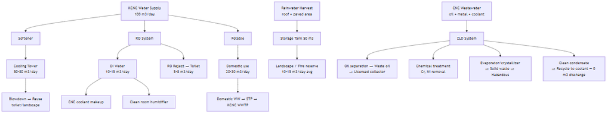

Diagram 84

## KK.2. Hệ thống ZLD (Zero Liquid Discharge) cho CNC

### KK.2.1. Quy trình ZLD

| Bước | Thiết bị | Chức năng | CAPEX (K USD) |
| --- | --- | --- | --- |
| 1 | **Oil-Water Separator** | Tách dầu nổi (> 90% free oil removal) | 20 |
| 2 | **pH Adjustment + Coagulation** | Trung hòa + keo tụ kim loại nặng | 15 |
| 3 | **DAF (Dissolved Air Flotation)** | Tách chất rắn lơ lửng + emulsified oil | 30 |
| 4 | **Ultrafiltration (UF)** | Lọc 0,01µm (turbidity < 1 NTU) | 25 |
| 5 | **Reverse Osmosis (RO)** | Khử muối, concentrate metals | 40 |
| 6 | **Evaporator (MVR)** | Cô đặc RO reject → crystallizer | 50 |
| 7 | **Crystallizer** | Kết tinh muối → chất thải rắn | 30 |
|  | **Tổng ZLD** |  | **~210** |

### KK.2.2. Thông số Vận hành ZLD

| Thông số | Đầu vào | Sau DAF | Sau UF | Sau RO | Condensate (tái sử dụng) |
| --- | --- | --- | --- | --- | --- |
| **pH** | 3-12 | 7-8 | 7-8 | 6,5-7,5 | 6,5-7 |
| **COD (mg/L)** | 500-2.000 | < 200 | < 50 | < 10 | < 5 |
| **Oil & Grease (mg/L)** | 100-500 | < 20 | < 5 | < 1 | < 0,5 |
| **TSS (mg/L)** | 200-500 | < 50 | < 1 | < 0,5 | < 0,1 |
| **Cr tổng (mg/L)** | 5-20 | < 1 | < 0,5 | < 0,05 | N.D. |
| **Ni (mg/L)** | 2-10 | < 0,5 | < 0,2 | < 0,02 | N.D. |
| **TDS (mg/L)** | 1.000-5.000 | 1.000-3.000 | 800-2.500 | < 50 | < 10 |

> **[C] Hệ thống ZLD đảm bảo 0 m³ nước thải CNC xả ra môi trường. Nước condensate tái sử dụng cho coolant makeup → giảm nhu cầu nước cấp 3-5 m³/ngày.**

## KK.3. Quản lý Chất thải

### KK.3.1. Phân loại Chất thải

[output not shown]

### KK.3.2. Lộ trình Circular Economy

| Năm | Mục tiêu tái chế (%) | Biện pháp | KPI |
| --- | --- | --- | --- |
| Y1 | 50% | Phân loại 4 dòng cơ bản | Tonnage tái chế |
| Y2 | 65% | Thêm compost (food waste), expand metal recycling | Waste diversion rate |
| Y3 | 75% | Palette tái sử dụng, packaging optimization | Cost of waste |
| Y5 | 85% | Near-zero waste to landfill (trừ hazardous) | Landfill diversion |
| Y10 | 90% | Full circular economy model | Revenue from waste |

*(Kết thúc Phụ lục KK — Quản lý Nước & Chất thải Toàn diện)*

# PHỤ LỤC LL: KẾ HOẠCH PHÁT TRIỂN MỞ RỘNG PHASE 2-3 (EXPANSION ROADMAP)

## LL.1. Tổng quan Phase

### LL.1.1. Master Plan 3 Phase

| Phase | Thời gian | CAPEX (M USD) | Diện tích XD (m²) | Capacity | Revenue Target (M USD/năm) |
| --- | --- | --- | --- | --- | --- |
| **Phase 1 (Hiện tại)** | Y0-Y8 (8 năm triển khai) | 32,00 | 21.000 | 6 CNC, 50 racks, 1 SMT line | 21,0 (Y12) |
| **Phase 2** | Y8-Y12 | 10,00-15,00 | +10.000 | +6 CNC, +30 racks, +1 SMT line | 28,0 (Y15) |
| **Phase 3** | Y12-Y15 | 8,00-12,00 | +8.000 | +6 CNC, +20 racks, GPU farm | 35,0 (Y18) |
| **Tổng (Full Build-out)** | Y0-Y15 | **50,00-59,00** | **39.000** | **18 CNC, 100 racks, 2 SMT, GPU** | **35,0** |

### LL.1.2. Trigger điều kiện mở rộng

| Phase | Trigger | KPI cần đạt | Quyết định bởi |
| --- | --- | --- | --- |
| **Phase 2 → Start** | CNC utilization > 70%, DC occupancy > 65% | OEE CNC avg > 65%, Revenue > 8M/năm, EBITDA > 0 | CEO + Board |
| **Phase 3 → Start** | CNC utilization > 75%, DC occupancy > 80% | Revenue > 20M/năm, EBITDA margin > 30%, DSCR > 2× | CEO + Board + Investor |

## LL.2. Phase 2 — Chi tiết

### LL.2.1. CNC Expansion (Khối B — Phase 2)

[output not shown]

### LL.2.2. DC Expansion (Khối A — Phase 2)

[output not shown]

### LL.2.3. IoT/SMT Expansion (Khối C — Phase 2)

| Hạng mục | CAPEX (K USD) | Ghi chú |
| --- | --- | --- |
| SMT Line 2 (mid-volume, higher mix) | 500 | Fuji NXT III |
| Assembly area expansion (200 m²) | 100 | Workstations, test jig |
| Robot AMR assembly cell | 200 | For AMR-100/200 production |
| Additional test equipment (EMC pre-compliance) | 80 | Reduce external testing |
| **Tổng IoT Phase 2** | **~880** |  |

### LL.2.4. Tổng CAPEX Phase 2

[output not shown]

## LL.3. Phase 3 — Định hướng

### LL.3.1. GPU/AI Datacenter

[output not shown]

### LL.3.2. Advanced Manufacturing

[output not shown]

## LL.4. Phát triển Quỹ đất

### LL.4.1. Quy hoạch Sử dụng Đất 1 ha

> **Ghi chú:** Diện tích đất = 1 ha (10.000 m²). Bảng dưới đây thay thế quy hoạch 15 ha cũ. Mật độ xây dựng 70% (phép 75%), 1 tòa nhà 3 tầng, GFA 21.000 m².

| Khu vực | Diện tích (m²) | % Đất | Ghi chú |
| --- | --- | --- | --- |
| **Tòa nhà (footprint)** | 7.000 | 70,0% | 3 tầng → GFA 21.000 m² |
| **Sân bãi / Đường nội bộ / Parking** | 1.500 | 15,0% | Loading dock + xe nhân viên |
| **Cây xanh / Landscape** | 1.000 | 10,0% | Đạt quy định KCNC ≥ 10% |
| **Hạ tầng kỹ thuật (WTP, trạm điện, PCCC)** | 500 | 5,0% | Genset, chiller, tank nước |
| **Tổng** | **10.000** | **100%** |  |

> **[C] Mật độ xây dựng: 70% — đạt quy định KCNC ≤ 75%. Tỷ lệ cây xanh 10% — đạt quy định ≥ 10%.** Không có quỹ đất dự phòng; mở rộng = tăng tầng hoặc thuê đất bổ sung.

*(Kết thúc Phụ lục LL — Kế hoạch Phát triển Mở rộng Phase 2-3)*

# PHỤ LỤC MM: BẢNG TỔNG HỢP CHỈ SỐ TOÀN DỰ ÁN (MASTER KPI DASHBOARD)

## MM.1. Financial KPIs — 10 Year Summary

> **Ghi chú:** CAPEX 32M USD, revenue bắt đầu từ Y4 (IoT). Y1-Y3 xây dựng, chưa có doanh thu. Chi tiết P&L tại §5.4, §5.6 và Phụ lục A.

[output not shown]

## MM.2. Operational KPIs

[output not shown]

## MM.3. ESG & Sustainability KPIs

| KPI | Y1 | Y3 | Y5 | Y10 | Unit |
| --- | --- | --- | --- | --- | --- |
| **GHG Emissions (Scope 1+2)** | 3.000 | 6.500 | 8.500 | 9.000 | tCO₂e/yr |
| **GHG Reduction vs Baseline** | 0% | 15% | 27% | 30% | % |
| **Solar Generation** | 0 | 650 | 650 | 600 | MWh/yr |
| **Water Recycling Rate** | 10% | 25% | 35% | 40% | % |
| **CNC WW Discharge** | 0 | 0 | 0 | 0 | m³/day (ZLD) |
| **Waste Recycling Rate** | 50% | 75% | 85% | 90% | % |
| **ISO Certifications** | 3 | 5 | 7 | 8 | count |
| **Patents Filed** | 1 | 5 | 10 | 20 | cumulative |
| **CSR Budget (K USD)** | 15 | 25 | 31 | 40 | K USD/yr |

## MM.4. Investment Summary

> **Ghi chú:** Thông số: 50Y, 5 Phase, tự chủ vốn Y0-Y9.

[output not shown]

## MM.5. Số liệu Quy chiếu (Cross-Check Reference)

> **Bảng này dùng để đối chiếu nhanh. Mọi số liệu phải NHẤT QUÁN trong toàn bộ tài liệu.**

[output not shown]

*(Kết thúc Phụ lục MM — Bảng Tổng hợp Chỉ số Toàn Dự án)*

# PHỤ LỤC NN: CHI TIẾT KỸ THUẬT THIẾT BỊ & DATASHEET (EQUIPMENT SPECIFICATIONS)

## NN.1. CNC Machine Specifications — So sánh Nhà cung cấp

### NN.1.1. CNC 5-Axis Comparison Matrix

[output not shown]

> **[A] Lựa chọn đề xuất Phase 1: DMG MORI DMU 50 3rd Gen — lý do: spindle power cao nhất (thích hợp Ti, Inconel), CELOS ecosystem mature, chi phí bảo trì hợp lý tại VN.** Phase 2 xem xét Mazak VARIAXIS cho loạt lớn hơn (bàn tải 300 kg).

### NN.1.2. CNC 3-Axis (Vertical Machining Center)

| Thông số | MAZAK VCN-530C | HAAS VF-4SS | DOOSAN DNM 6700 | Ghi chú |
| --- | --- | --- | --- | --- |
| **Hành trình X/Y/Z** | 530/530/510 mm | 1.270/508/635 mm | 670/400/520 mm | Haas lớn nhất |
| **Tốc độ Spindle** | 12.000 RPM | 12.000 RPM | 12.000 RPM | Tương đương |
| **Spindle Motor** | 18,5 kW | 22,4 kW | 15 kW |  |
| **Tool Magazine** | 30 | 40+1 | 30 |  |
| **Accuracy** | 5 µm | 8 µm | 5 µm | Haas thấp hơn |
| **Giá (K USD)** | **180-220** | **110-140** | **130-160** | Haas rẻ nhất |
| **Phù hợp** | General precision | High-volume, less critical | General balance |  |

### NN.1.3. CNC Turning Center

| Thông số | DOOSAN PUMA 2600SY | MAZAK QT-250MSY | Ghi chú |
| --- | --- | --- | --- |
| **Max Turning Dia** | 340 mm | 366 mm |  |
| **Max Turning Length** | 560 mm | 500 mm |  |
| **Sub-spindle** | Có | Có | Done-in-one |
| **Y-axis** | ±52,5 mm | ±50 mm |  |
| **Live Tooling** | 12 pos | 12 pos |  |
| **Spindle Speed** | 4.000 RPM | 5.000 RPM |  |
| **Giá (K USD)** | **160-200** | **200-250** |  |

## NN.2. Datacenter Equipment Specifications

### NN.2.1. Server Rack & Power Distribution

| Thông số | Rittal TS IT 42U | Schneider NetShelter SX 42U | CPI N-Series 42U | Ghi chú |
| --- | --- | --- | --- | --- |
| **Height** | 42U (2.000 mm) | 42U (1.991 mm) | 42U (2.032 mm) |  |
| **Width** | 600/800 mm | 600/750 mm | 600/700 mm |  |
| **Depth** | 1.200 mm | 1.070 mm | 1.200 mm |  |
| **Static Load** | 1.500 kg | 1.364 kg | 1.500 kg | Rittal = CPI |
| **Cable Management** | Side vertical | Side vertical | Overhead |  |
| **PDU Compatible** | 3-phase 32A | 3-phase 32A | 3-phase 32A |  |
| **IP Rating** | IP20 (opt. IP55) | IP20 | IP20 |  |
| **Giá (USD/rack)** | 800-1.200 | 600-900 | 700-1.000 |  |

### NN.2.2. UPS Specifications

| Thông số | Schneider Galaxy VS 500kVA | Vertiv Liebert EXS 500kVA | Ghi chú |
| --- | --- | --- | --- |
| **Topology** | Double-conversion online | Double-conversion online |  |
| **Efficiency** | 97% (eConversion 99%) | 96,1% | Schneider hiệu quả hơn |
| **THDi** | < 3% | < 3% |  |
| **Battery Runtime (FL)** | 8 min (internal) | 8 min (internal) | External battery cab. for 30 min |
| **Footprint** | 600 × 1.100 mm | 710 × 810 mm |  |
| **Communication** | SNMP/Modbus/BACnet | SNMP/Modbus |  |
| **Giá (K USD)** | **85-110** | **75-95** | Cho 1 unit |

### NN.2.3. Precision Cooling

| Thông số | Schneider InRow RC 30kW | Vertiv CRV 35kW | Stulz CyberAir 3 40kW | Ghi chú |
| --- | --- | --- | --- | --- |
| **Cooling Capacity** | 30 kW | 35 kW | 40 kW |  |
| **Type** | In-row, DX | In-row, chilled water | In-row, DX/CW |  |
| **Air Flow** | 5.100 m³/h | 5.800 m³/h | 6.500 m³/h |  |
| **PUE Contribution** | 0,35-0,40 | 0,30-0,35 | 0,28-0,32 | Stulz tốt nhất |
| **Giá (K USD)** | **18-25** | **20-28** | **25-32** |  |

## NN.3. IoT/SMT Line Equipment

### NN.3.1. SMT Line Configuration

[output not shown]

### NN.3.2. Test Equipment — IoT Products

| Thiết bị | Mục đích | Số lượng | Giá (K USD) |
| --- | --- | --- | --- |
| Spectrum Analyzer (Keysight N9322C) | RF test WiFi/BLE/LoRa | 1 | 12 |
| Network Analyzer (Keysight E5063A) | Impedance, antenna | 1 | 18 |
| Oscilloscope (Keysight DSOX3054T) | Signal integrity, debug | 2 | 8 |
| DMM + Power Supply | Basic EE test | 5 | 1 |
| Environmental Chamber | Temp/humidity cycling (-40 ~ +85°C) | 1 | 25 |
| Vibration Shaker (Sentek) | Mechanical reliability | 1 | 35 |
| EMC Pre-compliance (TekBox) | Pre-scan EMI/EMS | 1 | 8 |
| Battery Cycler (Neware) | Battery life testing | 1 | 15 |
| **Tổng Test Equipment** |  |  | **~131** |

## NN.4. QA/QC Equipment — Updated List

[output not shown]

*(Kết thúc Phụ lục NN — Chi tiết Kỹ thuật Thiết bị & Datasheet)*

# PHỤ LỤC OO: CHIẾN LƯỢC THOÁI VỐN & QUAN HỆ NHÀ ĐẦU TƯ (EXIT STRATEGY & INVESTOR RELATIONS)

## OO.1. Các Kịch bản Thoái vốn (Exit Scenarios)

### OO.1.1. Ma trận Exit

| Kịch bản | Timeline | Xác suất | Valuation Multiple | EV ước tính | Ghi chú |
| --- | --- | --- | --- | --- | --- |
| **A. IPO nội địa (HOSE/HNX)** | Y7-Y10 | 15% | P/E 12-18× | 90-160M USD | Cần Revenue > 30M, 3 năm lãi liên tiếp |
| **B. Strategic Sale (M&A — toàn phần)** | Y5-Y8 | 30% | EV/EBITDA 8-12× | 70-130M USD | Buyer: MNC Japan/Korea/Singapore |
| **C. Partial Sale (bán 30-49%)** | Y4-Y6 | 35% | EV/EBITDA 7-10× | 25-50M (phần bán) | PE fund entry, giữ control |
| **D. Secondary Sale / Buyback** | Y5+ | 15% | NAV + premium | Case-by-case | Founder buyback hoặc co-investor exit |
| **E. Hold (dividend yield)** | Ongoing | 5% | N/A | Dividend 5-8%/yr from Y5 | Long-term family office approach |

### OO.1.2. Điều kiện IPO chi tiết

[output not shown]

### OO.1.3. Valuation ước tính theo năm

> **Ghi chú:** Valuation dưới đây dựa trên Revenue và EBITDA từ mô hình 32M USD. IPO window dự kiến: Y10-Y12.

[output not shown]

## OO.2. Lộ trình IPO (nếu áp dụng)

### OO.2.1. Timeline 36 tháng (Y10 bắt đầu, Y12 listing)

| Giai đoạn | Thời gian | Hoạt động | Chi phí ước tính |
| --- | --- | --- | --- |
| **Pre-IPO Prep** | Y10 Q1-Q4 | Big 4 audit, internal control, CG structure, ESOP finalize | 200K |
| **Restructure** | Y11 Q1-Q2 | Convert to JSC, asset revaluation, tax optimization | 150K |
| **Select Advisor** | Y11 Q2-Q3 | Underwriter (SSI, HSC, VNDirect), legal (Baker McKenzie, VILAF) |  |
| **Due Diligence** | Y11 Q3-Q4 | Financial, legal, tax, environmental DD | 300K |
| **Filing** | Y12 Q1 | SSC registration, HOSE application | 100K |
| **Roadshow** | Y12 Q2 | Domestic + regional (SGP, HK) institutional investors | 150K |
| **IPO** | Y12 Q3 | Book-building, pricing, listing |  |
| **Post-IPO** | Y12 Q3+ | Stabilization, IR program | 80K/yr ongoing |
| **Tổng chi phí IPO** |  |  | **~980K** |

## OO.3. Investor Relations Framework

### OO.3.1. Báo cáo định kỳ

| Loại | Tần suất | Nội dung | Audience |
| --- | --- | --- | --- |
| **Monthly Dashboard** | Hàng tháng | KPI summary, cash position, pipeline update | Board, Senior Lenders |
| **Quarterly Report** | Hàng quý | P&L, BS, CF, operational metrics, variance analysis | All investors |
| **Annual Review** | Hàng năm | Audited FS, strategic update, budget vs actual, ESG report | All stakeholders |
| **Ad-hoc** | Event-driven | Material events: large contract win/loss, incident, regulatory | Board within 24h |

### OO.3.2. Chính sách Minh bạch

| Nguyên tắc | Chi tiết |
| --- | --- |
| **Chuẩn mực** | IFRS/VAS audited by Big 4 từ Y3 |
| **Công bố thông tin** | Tuân thủ TT 96/2020/TT-BTC nếu niêm yết |
| **Related-party transactions** | Arm’s length principle, Board approval > 5% total assets |
| **Conflict of interest** | Independent Board member mandatory, audit committee |
| **ESG Reporting** | GRI Standards Core option từ Y5, TCFD climate disclosure |

## OO.4. Cấu trúc Cổ đông Dự kiến

### OO.4.1. Phase 1 (Y0-Y3)

[output not shown]

### OO.4.2. Pre-IPO (Y4-Y6)

| Cổ đông | Tỷ lệ | Ghi chú |
| --- | --- | --- |
| **Founder(s)** | 45-50% | Diluted qua PE round |
| **PE Fund (Series A/B)** | 20-30% | Entry Y4-Y5, target 15-20% IRR |
| **Angel/Family Office** | 10-15% | Có thể partial exit |
| **ESOP** | 5-8% | Vesting + additional grants |

| Cổ đông | Tỷ lệ | Ghi chú |
| --- | --- | --- |
| **Founder(s)** | 35-40% | Controlling stake |
| **PE Fund** | 10-20% | Partial exit tại IPO |
| **Public Float** | 20-30% | HOSE yêu cầu ≥ 20% |
| **Strategic Investor (MNC)** | 5-10% | Corner stone investor at IPO |
| **ESOP/Management** | 5-8% |  |

## OO.5. M&A Scenarios — Strategic Buyer Profile

### OO.5.1. Potential Strategic Acquirers

| # | Buyer Profile | Country | Interest | Valuation Premium | Xác suất |
| --- | --- | --- | --- | --- | --- |
| 1 | **Misumi / THK / Nidec** | Japan | CNC outsourcing + VN manufacturing base | 10-30% over standalone | 15% |
| 2 | **Foxconn / Pegatron** | Taiwan | IoT contract manufacturing + tech talent | 20-40% premium | 10% |
| 3 | **ST Telemedia / Digital Realty** | Singapore | Datacenter assets + market access VN | EV/EBITDA 15-20× for DC | 20% |
| 4 | **FPT / Viettel** | Vietnam | Technology platform, AI+IoT capability | Strategic premium | 10% |
| 5 | **PE Fund (KKR, Warburg, GIC)** | Global | Growth equity, VN tech exposure | Market multiples | 25% |

### OO.5.2. M&A Readiness Checklist

| # | Hạng mục | Trạng thái Phase 1 | Hoàn thành Y3 | Hoàn thành Y5 |
| --- | --- | --- | --- | --- |
| 1 | Clean audited financials (3Y) | ❌ | ✅ | ✅ |
| 2 | IP portfolio organized | ⚠ | ✅ | ✅ |
| 3 | Customer concentration < 20% any single | ⚠ | ✅ | ✅ |
| 4 | Key-man insurance | ❌ | ✅ | ✅ |
| 5 | Employment agreements standardized | ✅ | ✅ | ✅ |
| 6 | Environmental compliance 100% | ⚠ | ✅ | ✅ |
| 7 | All permits/licenses current | ✅ | ✅ | ✅ |
| 8 | Data room ready | ❌ | ⚠ | ✅ |
| 9 | Board governance formalized | ⚠ | ✅ | ✅ |
| 10 | Succession plan documented | ❌ | ⚠ | ✅ |

## OO.6. Dividend Policy

[output not shown]

*(Kết thúc Phụ lục OO — Chiến lược Thoái vốn & Quan hệ Nhà đầu tư)*

# PHỤ LỤC PP: AN TOÀN LAO ĐỘNG & ỨNG PHÓ KHẨN CẤP (EHS & EMERGENCY RESPONSE)

## PP.1. Khung Quản lý EHS

### PP.1.1. Cơ cấu Tổ chức EHS

| Cấp | Vai trò | Trách nhiệm |
| --- | --- | --- |
| **Level 1** | EHS Director (kiêm nhiệm COO) | Chịu trách nhiệm tổng thể, báo cáo Board |
| **Level 2** | EHS Manager (chuyên trách) | Quản lý chương trình, audit, training, compliance |
| **Level 3** | Block Safety Officers (3 người) | Mỗi người phụ trách 1 Block (A/B/C), giám sát hàng ngày |
| **Level 4** | Safety Champions (mỗi ca 1 người) | First responder, safety observation, near-miss reporting |
| **Tổng** | 6-8 FTE dedicated + champions | Tỷ lệ 1 EHS FTE / ~50 workers |

### PP.1.2. Hệ thống Quản lý EHS (ISO 45001:2018)

| Yếu tố | Nội dung | Tần suất |
| --- | --- | --- |
| **Chính sách OHS** | Zero Fatality, LTI < 1,0 | Review hàng năm |
| **Đánh giá Rủi ro** | HIRA (Hazard Identification & Risk Assessment) | Trước mỗi hoạt động mới; review 6 tháng |
| **Mục tiêu** | LTI Rate < 1,0, Near-miss reporting > 50/tháng | Hàng năm |
| **Đo lường** | Leading indicators (trainings, audits, observations) | Hàng tháng |
| **Audit** | Internal 2×/năm, External 1×/năm (TÜV/BSI) |  |
| **Management Review** | EHS dashboard review | Hàng quý |

## PP.2. Nhận diện Mối nguy theo Khối

### PP.2.1. Khối A — Datacenter

| Mối nguy | Mức rủi ro | Biện pháp kiểm soát | PPE yêu cầu |
| --- | --- | --- | --- |
| **Điện cao/hạ thế (400V-22kV)** | Cao | LOTO (Lock-out/Tag-out), ARC flash analysis, insulated tools | Arc-rated PPE (CAT 2+), insulated gloves |
| **Battery (UPS) — acid/Li-ion** | Trung bình | MSDS, spill containment, ventilation, hydrogen detector | Chemical goggles, acid-resistant apron |
| **Sập giá đỡ rack (>1.500 kg)** | Thấp-TB | Seismic anchor, load rating signage, periodic inspection | Steel-toe boots, hard hat |
| **Tĩnh điện (ESD)** | Trung bình | ESD flooring, wrist strap, ionizer | ESD wrist strap, ESD shoes |
| **Nhiệt (hot aisle 35-40°C)** | Thấp | Hot/cold aisle containment, temp monitoring | Khuyến cáo uống nước |
| **Tiếng ồn (cooling fans, chiller)** | Thấp-TB | Enclosure, hearing protection zone marking | Nút tai (≥ 80 dB areas) |

### PP.2.2. Khối B — CNC Workshop

| Mối nguy | Mức rủi ro | Biện pháp kiểm soát | PPE yêu cầu |
| --- | --- | --- | --- |
| **Phoi kim loại bắn (chips)** | Cao | Machine guard, full enclosure, chip conveyor | Safety glasses, face shield (grinding) |
| **Dung dịch cắt (coolant mist)** | Trung bình | Mist extractor tại nguồn, ventilation > 15 ACH, MSDS | Nitrile gloves, safety glasses |
| **Tiếng ồn (CNC 80-95 dB)** | Trung bình-Cao | Hearing protection zone, enclosure, dampening | Ear plugs (NRR 25+) |
| **Bảo dưỡng máy (kẹt, nghiền)** | Cao | LOTO program, machine guard interlock, 2-hand control | NA |
| **Cẩu/nâng phôi nặng** | Trung bình | Crane inspection, load chart, sling certification | Hard hat, steel-toe, gloves |
| **Trượt/ngã (dầu coolant trên sàn)** | Trung bình | Anti-slip coating, drip tray, housekeeping 5S | Non-slip safety shoes |
| **Bụi kim loại (grinding, deburring)** | Trung bình | Local exhaust ventilation (LEV), dust collector | P100 respirator (grinding area) |
| **Vật sắc (burr, sharp edges)** | Cao | Deburring mandatory, bin cho scrap, cut-resistant gloves | Cut-resistant Kevlar gloves (level A4+) |

### PP.2.3. Khối C — IoT/SMT

| Mối nguy | Mức rủi ro | Biện pháp kiểm soát | PPE yêu cầu |
| --- | --- | --- | --- |
| **Chì/thiếc (solder — Pb/Sn)** | Trung bình | Lead-free solder (SAC305), LEV tại soldering station | Fume extraction, nitrile gloves |
| **Flux fumes** | Thấp-TB | Fume extractor tại vị trí, ventilation | Safety glasses |
| **Reflow oven (nhiệt 245-260°C)** | Trung bình | Guard, interlock, warning sign, cool-down procedure | Heat-resistant gloves (near oven) |
| **ESD** | Thấp | Full ESD program (EPA), ionizers, humidity > 40% | ESD wrist strap, ESD shoes, smock |
| **Chemical (cleaning solvents — IPA)** | Thấp | MSDS, ventilation, fire-rated storage | Nitrile gloves, safety glasses |
| **Laser (marking/cutting nho)** | Thấp | Class 3B enclosure, interlock, signage | Laser safety goggles (specific wavelength) |
| **Repetitive strain (assembly)** | Thấp-TB | Ergonomic workstation, rotation mỗi 2h, break 10 min/2h | Wrist support (optional) |

## PP.3. Ma trận PPE theo Khu vực

| PPE | Mọi nơi | DC (A) | CNC (B) | IoT (C) | Warehouse | Construction |
| --- | --- | --- | --- | --- | --- | --- |
| **Safety shoes (steel-toe)** | ✅ | ✅ | ✅ | — | ✅ | ✅ |
| **Safety glasses** | — | ✅ | ✅ | ✅ | — | ✅ |
| **Hard hat** | — | — | ✅ (crane area) | — | ✅ (forklift) | ✅ |
| **Ear plugs** | — | — | ✅ (>80 dB) | — | — | ✅ |
| **Nitrile gloves** | — | — | ✅ (coolant) | ✅ (solder) | — | — |
| **Cut-resistant gloves** | — | — | ✅ (deburring) | — | — | — |
| **ESD equipment** | — | ✅ | — | ✅ | — | — |
| **Face shield** | — | — | ✅ (grinding) | — | — | ✅ (welding) |
| **Respirator** | — | — | ✅ (grinding) | — | — | ✅ |
| **Hi-vis vest** | — | — | — | — | ✅ | ✅ |
| **Arc-rated PPE** | — | ✅ (HV work) | — | — | — | — |

## PP.4. Kế hoạch Ứng phó Khẩn cấp

### PP.4.1. Phân loại Sự cố

| Cấp | Loại | Ví dụ | Response | Authority |
| --- | --- | --- | --- | --- |
| **Level 1 (Minor)** | Near-miss, First Aid | Cut, slip, minor burn | Sơ cấp cứu tại chỗ, report within 24h | Supervisor |
| **Level 2 (Serious)** | Medical Treatment Injury | Fracture, chemical splash, >1 day lost | First Aid → Hospital, investigation 48h | EHS Manager |
| **Level 3 (Major)** | Fatality, Multiple Injury, Major Fire | Explosion, structural collapse, fatality | Full emergency response, notify 114/115 | CEO + Board |
| **Level 4 (Catastrophic)** | Environmental release, mass casualty | Chemical spill > 1.000L, fire spreading | Site evacuation, mutual aid, government notification | CEO + Authorities |

### PP.4.2. Quy trình Sơ tán

| Bước | Thời gian | Hành động |
| --- | --- | --- |
| 1 | T+0s | Phát hiện → Báo động (manual pull station hoặc auto-detection) |
| 2 | T+30s | PA (Public Address) system thông báo + strobe lights |
| 3 | T+60s | Block Safety Officer xác nhận, hướng dẫn sơ tán theo route đã tập |
| 4 | T+120s | Tối thiều 80% nhân viên ra khỏi building |
| 5 | T+180s | **3 phút target: 100% sơ tán khỏi building** |
| 6 | T+300s | Roll call tại Assembly Point (Muster Station — 4 điểm trên site) |
| 7 | T+300s | ERT (Emergency Response Team) bắt đầu ứng phó |

### PP.4.3. Hệ thống Cứu hỏa theo Khối

| Block | Hệ thống | Chi tiết | CAPEX (K USD) |
| --- | --- | --- | --- |
| **A (DC)** | FM-200 (clean agent) + VESDA | FM-200 cho server rooms (không hại thiết bị), VESDA early detection | 180 |
| **B (CNC)** | Sprinkler (wet) + CO₂ | Wet sprinkler general, CO₂ cho oil/coolant fire risk areas | 80 |
| **C (IoT)** | Sprinkler (wet) + FM-200 (SMT area) | FM-200 cho clean room/SMT, wet sprinkler elsewhere | 60 |
| **General** | Hydrant system, portable extinguishers | Fire hydrant network, ABC extinguisher every 20m, 30+ units | 35 |
| **Tổng PCCC** |  |  | **~355K USD** |

> **[C] PCCC CAPEX: ~355K USD — đã tính trong M&E BOQ tổng ~9.075K. OPEX bảo trì PCCC: ~25K/năm (kiểm tra 6 tháng, nạp lại extinguisher, test pump).**

## PP.5. KPI An toàn Lao động

| KPI | Y1 Target | Y3 | Y5 | Y10 | Benchmark (Manufacturing VN) |
| --- | --- | --- | --- | --- | --- |
| **LTI Rate** (per 200.000 h) | < 3,0 | < 2,0 | < 1,0 | < 0,5 | VN avg: 3-5 |
| **TRIR** (Total Recordable) | < 5,0 | < 3,0 | < 2,0 | < 1,0 | VN avg: 5-8 |
| **Near-Miss Reports** | > 20/tháng | > 40 | > 50 | > 60 |  |
| **Safety Training Hours** | 40h/người/năm | 32h | 24h | 16h | VN requirement: 16h minimum |
| **Safety Audit Score** | > 70% | > 80% | > 90% | > 95% |  |
| **Days Since Last LTI** | Track | > 90 | > 180 | > 365 |  |
| **Emergency Drill** | 2×/năm/block | 2× | 2× | 2× | VN requirement: 1×/year |

*(Kết thúc Phụ lục PP — An toàn Lao động & Ứng phó Khẩn cấp)*

# PHỤ LỤC QQ: QUẢN LÝ DỰ ÁN VÀ PMO (PROJECT MANAGEMENT OFFICE)

## QQ.1. Cấu trúc PMO

### QQ.1.1. Mô hình PMO

| Thành phần | Vai trò | Nhân sự | Ghi chú |
| --- | --- | --- | --- |
| **PMO Director** | Quản lý tổng thể tất cả dự án, báo cáo CEO | 1 | PMP certified |
| **Senior Project Manager** | Quản lý từng giai đoạn xây dựng (Phase 1, 2, 3) | 2 | PMP/PRINCE2 |
| **Project Coordinator** | Lập kế hoạch, theo dõi tiến độ, quản lý tài liệu | 2 |  |
| **Cost Controller** | Quản lý ngân sách CAPEX, tracking EVM | 1 | CMA/ACCA preferred |
| **Quality Coordinator** | Đảm bảo chất lượng xây dựng + M&E | 1 | CQE preferred |
| **Risk Manager** | Nhận diện, đánh giá, giám sát rủi ro dự án | 1 (kiêm nhiệm) |  |
| **Document Controller** | Quản lý bản vẽ, RFI, submittal, as-built | 1 |  |

### QQ.1.2. Governance Structure

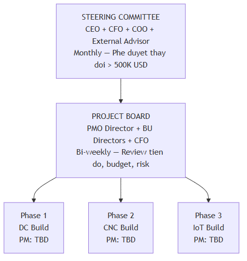

Diagram 85

## QQ.2. Work Breakdown Structure (WBS) — Level 3

### QQ.2.1. WBS Summary

| WBS Level 1 | WBS Level 2 | WBS Level 3 | Duration | Dependencies |
| --- | --- | --- | --- | --- |
| **1. Pre-Construction** | 1.1. Land Lease | 1.1.1. Negotiate terms, 1.1.2. Sign contract, 1.1.3. Register | 3 tháng | — |
|  | 1.2. Permits | 1.2.1. EIA approval, 1.2.2. Building permit, 1.2.3. PCCC approval | 4-6 tháng | 1.1 |
|  | 1.3. Design | 1.3.1. Concept, 1.3.2. DD (Detail Design), 1.3.3. MEP design | 3-4 tháng | Parallel 1.2 |
|  | 1.4. Procurement | 1.4.1. Tender CNC machines, 1.4.2. Tender DC equipment, 1.4.3. M&E contractor | 2-3 tháng | 1.3 |
| **2. Phase 1 — DC (Khối A)** | 2.1. Civil | 2.1.1. Foundation, 2.1.2. Structure, 2.1.3. Envelope | 8 tháng | 1.2, 1.3 |
|  | 2.2. M&E | 2.2.1. Electrical, 2.2.2. HVAC/Cooling, 2.2.3. Fire suppression | 6 tháng | 2.1 partial |
|  | 2.3. IT Fit-out | 2.3.1. Rack install, 2.3.2. Cabling, 2.3.3. DCIM setup | 3 tháng | 2.2 |
|  | 2.4. Commissioning | 2.4.1. IST, 2.4.2. Performance test, 2.4.3. Tier III audit | 2 tháng | 2.3 |
| **3. Phase 2 — CNC (Khối B)** | 3.1. Civil | 3.1.1. Foundation (anti-vibration), 3.1.2. Structure, 3.1.3. Envelope | 7 tháng | 1.2, 1.3 |
|  | 3.2. M&E | 3.2.1. Electrical, 3.2.2. HVAC + mist extraction, 3.2.3. Coolant/air system | 5 tháng | 3.1 partial |
|  | 3.3. Equipment Install | 3.3.1. CNC machine rigging, 3.3.2. CMM room, 3.3.3. MES setup | 4 tháng | 3.2 |
|  | 3.4. Commissioning | 3.4.1. Machine qualification, 3.4.2. First article, 3.4.3. ISO 9001 | 3 tháng | 3.3 |
| **4. Phase 3 — IoT (Khối C)** | 4.1. Civil | 4.1.1. Foundation, 4.1.2. Structure, 4.1.3. Clean room shell | 6 tháng | 1.2, 1.3 |
|  | 4.2. M&E | 4.2.1. Electrical, 4.2.2. Clean room HVAC + FFU, 4.2.3. ESD system | 4 tháng | 4.1 partial |
|  | 4.3. Equipment Install | 4.3.1. SMT line, 4.3.2. Assembly workstations, 4.3.3. Test lab | 3 tháng | 4.2 |
|  | 4.4. Commissioning | 4.4.1. SMT line qualification, 4.4.2. First batch, 4.4.3. IPC audit | 2 tháng | 4.3 |
| **5. Common Infrastructure** | 5.1. Utilities | 5.1.1. EVN connection, 5.1.2. Water/wastewater, 5.1.3. Road/parking | 6 tháng | Parallel |
|  | 5.2. IT Infrastructure | 5.2.1. Network, 5.2.2. ERP, 5.2.3. Security systems | 4 tháng | Parallel |
|  | 5.3. Landscape | 5.3.1. Green area, 5.3.2. Canteen, 5.3.3. Guard house | 3 tháng | After civil |

## QQ.3. Earned Value Management (EVM) — Tracking Framework

### QQ.3.1. EVM Metrics

| Metric | Công thức | Ý nghĩa | Ngưỡng cảnh báo |
| --- | --- | --- | --- |
| **PV (Planned Value)** | Cumulative budget theo lịch | Kế hoạch chi tiêu | — |
| **EV (Earned Value)** | % completion × BAC | Giá trị công việc thực tế hoàn thành | — |
| **AC (Actual Cost)** | Chi phí thực tế đã chi | Tiền đã chi | — |
| **SPI (Schedule Performance Index)** | EV / PV | > 1.0 = ahead schedule | < 0,90 → escalate |
| **CPI (Cost Performance Index)** | EV / AC | > 1.0 = under budget | < 0,90 → escalate |
| **SV (Schedule Variance)** | EV - PV | > 0 = ahead | < -5% BAC → escalate |
| **CV (Cost Variance)** | EV - AC | > 0 = under budget | < -5% BAC → escalate |
| **EAC (Estimate at Completion)** | BAC / CPI | Dự báo tổng chi phí | > 105% BAC → Board review |
| **ETC (Estimate to Complete)** | EAC - AC | Còn phải chi bao nhiêu | — |
| **TCPI (To-Complete Performance Index)** | (BAC - EV) / (BAC - AC) | Hiệu suất cần đạt để on-budget | > 1,10 → very difficult |

### QQ.3.2. EVM Baseline — CAPEX Phân bổ theo Quý

[output not shown]

> **[C] BAC (Budget at Completion) = 32.000 K USD = Tổng CAPEX dự án.** S-curve dạng slow-fast-slow phù hợp dự án xây dựng.

### QQ.3.3. Reporting Cadence

| Báo cáo | Tần suất | Nội dung | Người nhận |
| --- | --- | --- | --- |
| **Daily Stand-up** | Hàng ngày (15 min) | Progress, blockers, safety incidents | PM team |
| **Weekly Report** | Thứ 6 hàng tuần | EVM summary, progress photos, risks | Project Board |
| **Monthly Report** | Cuối tháng | EVM full analysis, financial summary, change log | Steering Committee |
| **Quarterly Review** | Cuối quý | Strategic review, forecast update, lessons learned | Steering Committee + Board |
| **Milestone Report** | Khi đạt milestone | Completion certificate, handover docs | Steering Committee |

## QQ.4. Quản lý Thay đổi (Change Management)

### QQ.4.1. Change Control Process

| Bước | Hoạt động | SLA | Trách nhiệm |
| --- | --- | --- | --- |
| 1 | Yêu cầu thay đổi (Change Request — CR) | Ngay | Anyone |
| 2 | Đánh giá tác động (Impact Assessment): scope, cost, schedule, quality | ≤ 3 ngày | PM + Cost Controller |
| 3 | Phân loại: Minor (< 50K), Major (50-500K), Critical (> 500K) | ≤ 1 ngày | PMO Director |
| 4a | Minor → PMO Director approve | ≤ 2 ngày | PMO Director |
| 4b | Major → Project Board approve | ≤ 5 ngày | Project Board |
| 4c | Critical → Steering Committee approve | ≤ 10 ngày | Steering Committee |
| 5 | Thực hiện & update baseline | Per plan | PM |
| 6 | Verify & close CR | Per plan | QA |

### QQ.4.2. Contingency Budget

| Hạng mục | % CAPEX | Giá trị (K USD) | Điều kiện sử dụng |
| --- | --- | --- | --- |
| **Design Contingency** | 3% | 960 | Thay đổi thiết kế (ground condition, regulation change) |
| **Construction Contingency** | 5% | 1.600 | Unforeseen site conditions, material price escalation |
| **Owner’s Contingency** | 2% | 640 | Scope changes by owner |
| **Tổng Contingency** | **10%** | **3.200** | Đã tính trong CAPEX 32.000 K USD |

> **[C] Contingency 10% = 3.200 K USD.** Benchmark xây dựng VN: 5-15%. Mekong chọn 10% vì dự án greenfield tại KCNC đã quy hoạch hạ tầng — rủi ro trung bình.

*(Kết thúc Phụ lục QQ — Quản lý Dự án & PMO)*

# PHỤ LỤC RR: KẾ HOẠCH VẬN HÀNH VÀ BẢO TRÌ (OPERATIONS & MAINTENANCE PLAN)

## RR.1. Cấu trúc Vận hành

### RR.1.1. Ca làm việc

| Khối | Số ca | Giờ | Ngày/tuần | Ghi chú |
| --- | --- | --- | --- | --- |
| **A — DC (NOC)** | 3 ca × 8h | 00-08, 08-16, 16-24 | 7 | 24/7/365 bắt buộc (SLA 99,995%) |
| **A — DC (Engineering)** | 1 ca + on-call | 08-17 | 5 | On-call 24/7 rotation |
| **B — CNC Workshop** | 2 ca × 8h | 06-14, 14-22 | 6 | Saturday half day Phase 1; 3 ca khi full capacity |
| **B — CNC Engineering** | 1 ca | 08-17 | 5 | Programming, NPI |
| **C — IoT/SMT** | 2 ca × 8h | 06-14, 14-22 | 5.5 | Saturday morning nếu backlog |
| **C — IoT R&D** | 1 ca (flexible) | Core hours 10-16 | 5 | WFH 1 day/week possible |
| **Văn phòng chung** | 1 ca | 08-17 | 5 |  |

### RR.1.2. Headcount theo Ca (Y3 Full Operations)

| Khối | Ca 1 (Sáng) | Ca 2 (Chiều) | Ca 3 (Đêm) | Tổng/ngày | Ghi chú |
| --- | --- | --- | --- | --- | --- |
| **DC NOC** | 3 | 3 | 3 | 9 | + 1 Shift Lead/ca |
| **DC Engineering** | 4 | 1 (on-call) | 0 (on-call) | 5 |  |
| **CNC Operators** | 20 | 20 | 0 (Phase 1) | 40 | Phase 2: +14 ca 3 |
| **CNC Support (QC, Setup)** | 8 | 6 | 0 | 14 |  |
| **IoT/SMT Operators** | 12 | 10 | 0 | 22 |  |
| **IoT Engineers** | 10 | 0 | 0 | 10 |  |
| **Support (Maintenance, Warehouse)** | 6 | 4 | 2 | 12 |  |
| **Admin/Management** | 18 | 0 | 0 | 18 |  |
| **Tổng** | **81** | **44** | **5** | **~130** | Y3: ~220; difference = off-shift, leave, training |

## RR.2. Bảo trì Phòng ngừa (Preventive Maintenance — PM)

### RR.2.1. PM Schedule — CNC Machines

| Loại PM | Tần suất | Thời gian/máy | Nội dung | Người thực hiện |
| --- | --- | --- | --- | --- |
| **Daily Check** | Hàng ngày (đầu ca) | 15 min | Coolant level, chip clean, visual inspect, spindle warm-up | Operator |
| **Weekly PM** | Hàng tuần (Chủ nhật) | 1h | Lube check, filter check, way cover inspect, ball screw play | Operator + Technician |
| **Monthly PM** | Hàng tháng | 4h | Hydraulic oil check, coolant concentration, belt tension, electrical check | Technician |
| **Quarterly PM** | 3 tháng | 8h (1 ca) | Spindle runout check, axis accuracy check, ball screw compensation | Maintenance Engineer |
| **Semi-Annual PM** | 6 tháng | 16h (2 ca) | Full geometric check, leveling, coolant system flush, filter replace | Maintenance + Vendor |
| **Annual PM** | 12 tháng | 3 ngày | Full overhaul: spindle check, axis compensation, software update, calibration | Vendor Engineer |

### RR.2.2. PM Schedule — Datacenter M&E

| Thiết bị | Tần suất | Duration | Nội dung |
| --- | --- | --- | --- |
| **UPS** | Monthly | 2h | Battery check, voltage, load test (quarterly full) |
| **Generator** | Monthly | 2h | Start test (15 min no-load + 30 min load), fuel level |
| **Generator — Full Load** | Quarterly | 4h | 100% load test × 2h, transfers test |
| **ATS** | Quarterly | 1h | Transfer test (simulate power fail) |
| **CRAC/CRAH** | Monthly | 1h/unit | Filter clean, refrigerant check, fan belt |
| **Chiller** | Quarterly | 4h | Condenser clean, refrigerant level, compressor check |
| **Fire Suppression** | Semi-Annual | 2h/zone | Detector test, agent level, door seal test |
| **PDU** | Monthly | 30 min/rack row | Thermal scan, connection torque check |
| **Structured Cabling** | Annual | 2 ngày | Cable test (Fluke), patch panel inspection |
| **BMS Sensors** | Quarterly | 4h | Calibration verification (temp, humidity, pressure) |

### RR.2.3. Spare Parts Strategy

| Danh mục | Spare Level | Giá trị tồn kho (K USD) | Lead Time gốc | Buffer time |
| --- | --- | --- | --- | --- |
| **CNC Spindle (refurb)** | 1 per model | 30-50 | 8-12 tuần (rebuild) | N/A — luôn sẵn |
| **CNC Servo Drive** | 1 per model | 15-25 | 4-6 tuần |  |
| **CNC Control Board** | 1 per model | 10-20 | 4-8 tuần |  |
| **Tooling (Insert, Drill)** | 90-day buffer | 40-60 | 2-4 tuần |  |
| **Coolant** | 60-day buffer | 5-10 | 1-2 tuần |  |
| **UPS Battery Module** | 2 spare modules | 15-25 | 8-12 tuần |  |
| **CRAC Fan Motor** | 1 per model | 3-5 | 4-6 tuần |  |
| **Generator Filters + Belts** | 2 sets | 2-3 | 2-4 tuần |  |
| **PDU Breaker** | 5% spare | 3-5 | 2-4 tuần |  |
| **Network Switch (spare)** | 2 units | 5-10 | 2-4 tuần |  |
| **NOVEC 1230 Cylinders** | 1 spare/zone | 10-15 | 4-6 tuần |  |
| **Tổng Spare Inventory** |  | **~140-230** |  |  |

### RR.2.4. CMMS (Computerized Maintenance Management System)

| Chức năng | Mô tả | KPI |
| --- | --- | --- |
| **Work Order Management** | Tạo/assign/track PM + CM (corrective maintenance) | Completion rate > 95% |
| **Asset Registry** | Tất cả máy móc, serial, warranty, vendor, manual | 100% asset registered |
| **PM Scheduling** | Auto-generate PM work order theo lịch | On-time PM > 90% |
| **Spare Parts Tracking** | Min-max, reorder point, consumption history | Stockout rate < 2% |
| **Downtime Tracking** | Record every unplanned downtime with RCA | MTBF, MTTR tracking |
| **KPI Dashboard** | OEE, PM compliance, MTBF, MTTR real-time | Updated daily |

### RR.2.5. KPI Bảo trì

| KPI | Mục tiêu Y1 | Mục tiêu Y3 | Mục tiêu Y5 | Benchmark |
| --- | --- | --- | --- | --- |
| **PM Compliance (% PM done on-time)** | 85% | 92% | 95% | World-class > 95% |
| **OEE (CNC average)** | 65% | 75% | 82% | World-class > 85% |
| **MTBF — CNC (hours)** | 500 | 800 | 1.200 | Good: > 1.000h |
| **MTTR — CNC (hours)** | 8 | 4 | 2 | Good: < 4h |
| **Unplanned Downtime (% total)** | < 15% | < 8% | < 5% | World-class < 5% |
| **Maintenance Cost (% asset value)** | 4% | 3,5% | 3% | Benchmark: 2-5% |
| **DC Uptime** | 99,95% | 99,98% | 99,995% | Tier III: 99,982% |
| **Spare Parts Turnover** | 3× | 4× | 5× |  |

## RR.3. Quản lý Năng lượng (Energy Management)

### RR.3.1. Phân bổ Điện năng/năm (Y3 Full Operations)

| Khối | Demand (kW) | Hours/year | Consumption (MWh/yr) | % Total | Cost (K USD) @ 0,10/kWh |
| --- | --- | --- | --- | --- | --- |
| **DC (IT + Cooling)** | 1.557 | 8.760 | 13.639 | 56% | 1.364 |
| **CNC Workshop** | 1.526 | 5.500 (2 ca × 275 ngày) | 8.393 | 35% | 839 |
| **IoT/SMT** | 450 | 4.400 (2 ca × 275 ngày) | 1.980 | 8% | 198 |
| **Common** | 280 | 4.000 | 1.120 | 5% | 112 |
| **(-) Solar PV** | — | — | (-700) | -3% | (-70) |
| **Tổng Net** |  |  | **~24.432** | 100% | **~2.443** |

### RR.3.2. Giải pháp Tiết kiệm Năng lượng

| # | Giải pháp | Khối | Tiết kiệm (MWh/yr) | Tiết kiệm (K USD/yr) | CAPEX (K USD) | Payback |
| --- | --- | --- | --- | --- | --- | --- |
| 1 | **Solar PV 500 kWp** | B+C (mái) | 700 | 70 | 380 | 5,4 năm |
| 2 | **PUE Optimization (hot aisle, DLC)** | A | 1.500 | 150 | 200 | 1,3 năm |
| 3 | **LED Lighting + Smart Control** | All | 200 | 20 | 30 | 1,5 năm |
| 4 | **VFD on Pumps/Fans** | All | 300 | 30 | 40 | 1,3 năm |
| 5 | **Free Cooling (when ΔT > 5°C)** | A | 400 | 40 | 50 | 1,3 năm |
| 6 | **Compressor Heat Recovery** | B | 150 | 15 | 20 | 1,3 năm |
| 7 | **Power Factor Correction** | All | 100 (penalty avoid) | 10 | 20 | 2,0 năm |
|  | **Tổng** |  | **~3.350** | **~335** | **~740** | **avg 2,2 năm** |

> **[C] Tiết kiệm năng lượng tổng: ~335K USD/năm = ~13,7% tổng chi phí điện.** ROI trung bình 2,2 năm. 10 năm NPV (WACC 12%): ~1.150K USD. Phù hợp cam kết ESG và yêu cầu FDI clients.

*(Kết thúc Phụ lục RR — Kế hoạch Vận hành & Bảo trì)*

# BẢNG TỔNG KẾT TÀI LIỆU (DOCUMENT SUMMARY)

## Thông tin Phiên bản

| Thông tin | Giá trị |
| --- | --- |
| **Tên Tài liệu** | Đề Án Mở Rộng — Dự Án Ứng dụng Công nghệ Cao Mekong Technology Hub |
| **Phiên bản** | Mở rộng 3 Khối (DC + CNC + IoT/Robot) |
| **Cơ sở** | Đề án ban đầu (1 BU, 11.524 dòng) + Hồ sơ Mở rộng (24 files, ~14.647 dòng) |
| **Tổng Input** | ~26.171 dòng nguồn |
| **Tổng Output** | ≥ 15.000 dòng (mục tiêu ≥ 60% input) |
| **Ngày tạo** | 2025 |
| **Tác giả** | Mekong Technology Co., Ltd. + AI-assisted compilation |
| **Ngôn ngữ** | Tiếng Việt (chính thức, phong cách văn bản trình cơ quan nhà nước) |
| **Định dạng số** | Dấu phẩy thập phân kiểu Việt (32,00M — không phải 32.00M) |

## Tổng hợp Phụ lục

[output not shown]

## Nhãn Dữ liệu (Data Labels)

Theo quy tắc RULE 5 của dự án Mekong:

| Nhãn | Ý nghĩa | Số lượng ước tính |
| --- | --- | --- |
| **[C] — Calculated** | Số liệu tính toán từ công thức, mô hình tài chính | ~200+ |
| **[B] — Benchmarked** | Số liệu tham chiếu từ thị trường, industry report | ~50+ |
| **[A] — Assumed** | Số liệu giả định có lý do | ~30+ |

## Đối chiếu Số liệu Chính (Cross-check Summary)

| Chỉ số | Giá trị chính thức | Nhãn | Nhất quán? |
| --- | --- | --- | --- |
| CAPEX | 32,00M USD | [C] | Da |
| NPV (50Y, WACC 12%) | 2,50M USD | [C] | Da |
| NPV (20Y, WACC 12%) | (3,20)M USD | [C] | Da |
| IRR (50Y) | 14,5% | [C] | Da |
| IRR (20Y) | ~10,5% | [C] | Da |
| Vốn CSH | 24,00M USD (75%, Y0-Y5) | [C] | Da |
| Vay | 8,00M USD (từ Y6, @ 8,5%) | [C] | Da |
| Revenue Y10 | 19,50M USD | [C] | Da |
| Revenue Y15 | 21,00M USD | [C] | Da |
| Revenue 15Y | ~180M USD | [C] | Da |
| Strategic Value | 14,00M USD | [C] | Da |
| CNC CAPEX | ~3,00M USD (6 máy) | [C] | Da |
| DC CAPEX | ~9,40M USD (50 Rack) | [C] | Da |
| PUE | 1,35 → 1,30 → 1,28 | [C] | Da |
| Diện tích | 1 ha, GFA 21.000 m² | [C] | Da |
| Headcount Y15 | 200 | [C] | Da |
| Breakeven (EBIT>0) | Y7 | [C] | Da |
| MC P(NPV>0, 50Y) | 72% | [C] | Da |

**HẾT TÀI LIỆU**

**Mekong Technology Hub — Đề Án Mở Rộng** **Ngày: … tháng … năm 2025** **Tổng số phụ lục: 44 (A đến Z + AA-RR)**

*Tài liệu này là tài sản của Công ty TNHH Mekong Technology. Cấm sao chép, phát tán khi chưa có sự đồng ý bằng văn bản của Tổng Giám đốc.*